# ROI on Hand Picked Stocks 2007-2020

Lets look at these charts on top of each other.

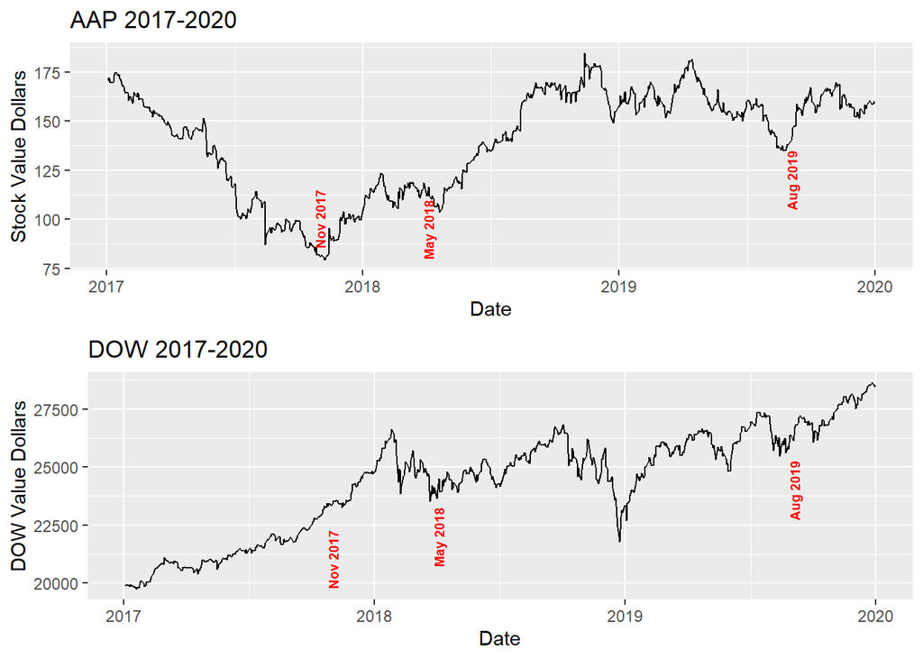

```r
grid.arrange(gg1, gg2, nrow = 2)
```

Lets see what happened in 2017 for AAP and in 2018 to cause it to decrease then increase respectively… just declining sales, plans to expand and open more stores, and public outcry on the sales declines of Advance Auto Parts. So, this could mean that because the DOW was doing great and increasing, investors thought to take their money out of the after market car parts stores, or maybe they thought they were hurting because of Amazon Prime taking their business. Those are some possibilities. When looking at stocks in the [DOW Jones industrial average](https://www.buyupside.com/sample_portfolios/djindustrialsstocks.php), AAP isn’t listed as one of these stocks, so it could be that people took their money out of the after markets car parts stock as it was declining and put it into any of the stocks that belong to the DOW, because it increased in value in 2017 while AAP decreased, then they both moved together around and after 2018.

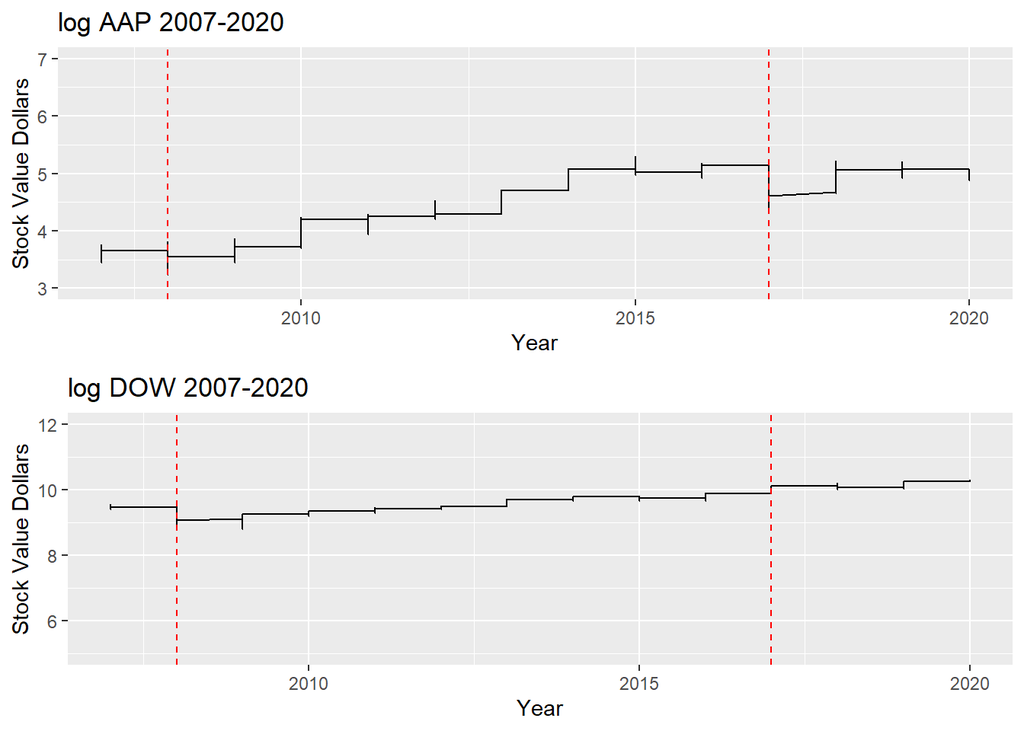

```r
aaplog <- aap
aaplog$logAAP <- log1p(aaplog$stockValue)
aaplog$logDOW <- log1p(aaplog$DOW_Close)

g1 <- ggplot(data = aaplog, aes(x=Year, y=logAAP)) +
      geom_line()+
      scale_y_continuous(limits=c(3,7))+
      scale_fill_brewer(palette="paired") +
      theme(legend.position="bottom")+
      geom_vline(xintercept=c(2008,2017), linetype='dashed', color='red')+
      ggtitle('log AAP 2007-2020')+
      ylab('Stock Value Dollars')
g2 <- ggplot(data = aaplog, aes(x=Year, y=logDOW)) +
      geom_line()+
      scale_y_continuous(limits=c(5,12))+
      scale_fill_brewer(palette="paired") +
      theme(legend.position="bottom")+
      geom_vline(xintercept=c(2008,2017), linetype='dashed', color='red')+
      ggtitle('log DOW 2007-2020')+
      ylab('Stock Value Dollars')
grid.arrange(g1, g2, nrow = 2)
```

The above chart shows the log scale of the value + 1 so that there aren’t any natural log errors in scaling. There is also an added few lines to show the years of 2008 and 2017 when AAP had decreasing years in stock value.

Lets look at the DOW over the years with the other 16 stocks in this portfolio of stocks that proved most profitable when the DOW was down and unemployment was up using the set of stocks with positive median values under those constraints.

```r
dROI17 <- Close17_dow %>% group_by(DOW_down_median) %>%
  summarise_at(vars(stockValue), mean)
colnames(dROI17)[2] <- 'avgStockValue'

start17 <- subset(Close17_dow, Close17_dow$Date=='2007-01-03')
final17 <- subset(Close17_dow, Close17_dow$Date=='2020-02-14')

start17 <- start17[order(start17$DOW_down_median),]
final17 <- final17[order(final17$DOW_down_median),]
dROI17 <- dROI17[order(dROI17$DOW_down_median),]

DOW_ROI <- as.data.frame(final17$DOW_Close/start17$DOW_Close)
colnames(DOW_ROI) <- 'DOW_ROI'

colnames(start17)[6] <- 'startValue'
colnames(final17)[6] <- 'finalValue'

dROI17$startValue <- start17$startValue
dROI17$finalValue <- final17$finalValue
dROI17$DOW_ROI <- DOW_ROI$DOW_ROI
dROI17$stock_ROI <- dROI17$finalValue/dROI17$startValue
dROI17
```

```
## # A tibble: 17 x 6
##    DOW_down_median avgStockValue startValue finalValue DOW_ROI stock_ROI
##    <chr>                   <dbl>      <dbl>      <dbl>   <dbl>     <dbl>
##  1 AAP                      97.3      35.6       134.     2.36     3.75
##  2 ADDYY                    58.4      25         156.     2.36     6.24
##  3 AMZN                    551.       38.7      2135.     2.36    55.2
##  4 COST                    123.       52.8       318.     2.36     6.02
##  5 DLTR                     52.8      10.2        88.7    2.36     8.67
##  6 FFIN                     14.7       7.00       34.6    2.36     4.94
##  7 GOOG                    559.      233.       1521.     2.36     6.53
##  8 HD                       90.9      41.1       245.     2.36     5.97
##  9 JNJ                      91.1      66.4       150.     2.36     2.26
## 10 NFLX                     92.4       3.80      380.     2.36   100.
## 11 NKE                      39.7      12.2       104.     2.36     8.48
## 12 PCG                      44.1      47.3        16.2    2.36     0.343
## 13 ROST                     40.8       7.62      122.     2.36    16.0
## 14 TEVA                     41.1      31.3        12.2    2.36     0.391
## 15 TJX                      26.0       7.17       63.4    2.36     8.84
## 16 WMT                      69.8      47.5       118.     2.36     2.48
## 17 XOM                      81.4      74.1        60.7    2.36     0.818
```

Netflix killed the return on investment with more than 100 fold profits. Lets look at Netflix to see the highs and lows of this stock since 2007 and through till 2020.

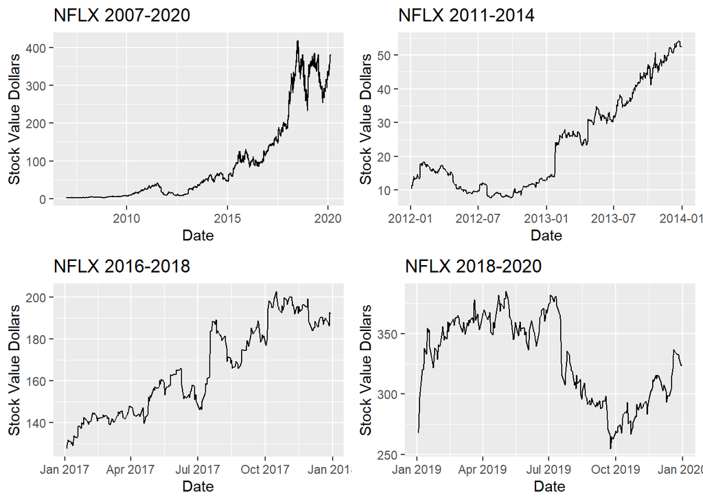

```r
nflx <- subset(Close17_dow, Close17_dow$DOW_down_median=='NFLX')
nflx1 <- subset(nflx, nflx$Year > 2011 & nflx$Year < 2014)
nflx2 <- subset(nflx, nflx$Year > 2016 & nflx$Year < 2018)
nflx3 <- subset(nflx, nflx$Year > 2018 & nflx$Year < 2020)

gg3 <- ggplot(data = nflx, aes(x=Date, y=stockValue)) +
       geom_line()+
       scale_y_continuous()+
       theme(legend.position="bottom")+
       ggtitle('NFLX 2007-2020')+
       ylab('Stock Value Dollars')
gg4 <- ggplot(data = nflx1, aes(x=Date, y=stockValue)) +
       geom_line()+
       scale_y_continuous()+
       theme(legend.position="bottom")+
       ggtitle('NFLX 2011-2014')+
       ylab('Stock Value Dollars')
gg5 <- ggplot(data = nflx2, aes(x=Date, y=stockValue)) +
       geom_line()+
       scale_y_continuous()+
       theme(legend.position="bottom")+
       ggtitle('NFLX 2016-2018')+
       ylab('Stock Value Dollars')
gg6 <- ggplot(data = nflx3, aes(x=Date, y=stockValue)) +
       geom_line()+
       scale_y_continuous()+
       theme(legend.position="bottom")+
       ggtitle('NFLX 2018-2020')+
       ylab('Stock Value Dollars')

grid.arrange(gg3, gg4, gg5,gg6, nrow = 2)
```

- Netflix was first heard from the author of this tutorial in 2003 when some roommate of a guy the author dated bragged about how awesome Netflix is to cost $7/month and you can rent new movies mailed to your home for no additional charge. This roommate also bought a flat screen tv for 7000 USD before they became ubiquitously priced from 200-500 USD five years later.
- The minimum wage for workers around CA in this time period was also about the cost of the Netflix monthly membership. Many tv shows started being options to rent from sources such as premium cable tv shows like Dexter around 2007 or so.
- I pulled the cord on cable due to high costs and got a Netflix membership for around 8-10 USD in about 2014. Which was also around the price of minimum wage at that time.
- cell phones became very great and needed personal items with fast wifi and internet streamings still at a cost that beat cable tv and home phone lines at this same time period.
- Netflix got more innovative, they started adding more Netflix produced shows in 2016 that made memes on instagram and facebook, the top social media platforms of the time in the 2010s like with ‘Orange is the New Black’ ( I couldn’t watch, but saw many memes on).

So, given what you know and what you scanned above, isn’t it no surprise that a stock that out competes alternative forms of entertainment, is low cost in price and able to be taken mobile or use anywhere and at any time for next to nothing in cost as an hour of a consumer’s 160-200 hour work month if working minimum wage and full time. Maybe its time to add another feature, like federal minimum wage rates to this data. We will in fact do this later, but for now we will add another feature that compares the ROI ration to that of the DOW Jones industrial average, and try to pull the most striking features out of that group.

```r
dROI17$stockBeatsDOW <- ifelse(dROI17$stock_ROI > dROI17$DOW_ROI, 'Yes', 'No')
dROI17[,c(1,7)]
```

```
## # A tibble: 17 x 2
##    DOW_down_median stockBeatsDOW
##    <chr>           <chr>
##  1 AAP             Yes
##  2 ADDYY           Yes
##  3 AMZN            Yes
##  4 COST            Yes
##  5 DLTR            Yes
##  6 FFIN            Yes
##  7 GOOG            Yes
##  8 HD              Yes
##  9 JNJ             No
## 10 NFLX            Yes
## 11 NKE             Yes
## 12 PCG             No
## 13 ROST            Yes
## 14 TEVA            No
## 15 TJX             Yes
## 16 WMT             Yes
## 17 XOM             No
```

Looking at the above chart of the stocks that beat the DOW in return on investment ratios of final stock value to initial stock value (2007-2020), Exxon Mobil, Johnson & Johnson, Teva Pharmaceuticals Industries, and Pacific Gas and Electric lossed money or had lower returns than that of the DOW. Of note, the pharmaceuticals might make you go on a wild tangent to know which company is supplying us with flu vaccines annually. If so, [Sanofi (SNY)](https://finance.yahoo.com/quote/SNY/) is the US’s largest supplier and they aren’t in this analysis. But it would be interesting to see when they make the most money, considering we have a CoV-19 flu contagion globally as of Feb. 2020. While, it is safe to say the companies that low income consumers love or live by did well, such as: Walmart, Adidas, Nike, Home Depot, Netflix, Amazon, Advance Auto Parts, TJ Maxx, Ross, Dollar Tree, and Costco. Costco is more of a middle class or small business store because you have to have cash, or used to have cash or money in your checking account to buy their goods and services with your atm card. They may have changed this. First Financial bank also did well, and it was selected because it was one of the banks available when hand picking these stocks. I don’t use it and don’t know anyone who does, and that is because I am on the West Coast, and this bank originates out of the East Coast. This could be an indicator that the East Coast is picking up in business and getting more home loans, business loans, etc. Than the more West Coast known banks like Citi, Chase, Bank of America, JP Morgan Chase. As these other banks did not perform well for median positive daily changes in stock prices during increasing unemployment and decreasing DOW values.

Lets plot those four stocks in this portfolio that did worse than the DOW.

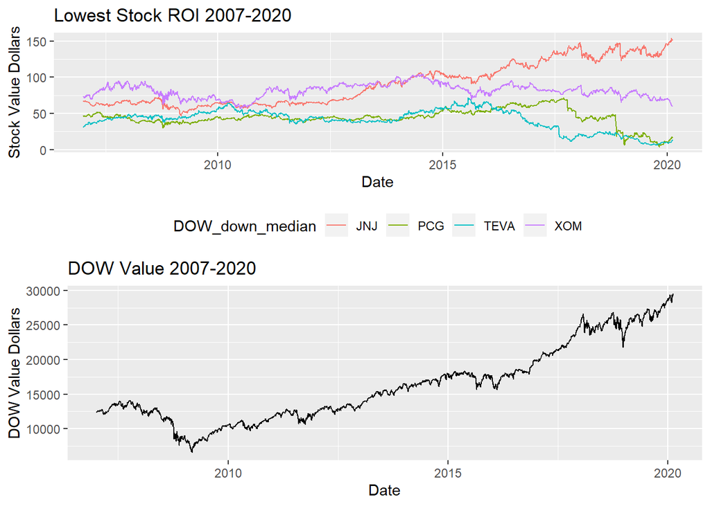

```r
low4 <- subset(Close17_dow, Close17_dow$DOW_down_median == 'JNJ'|
                  Close17_dow$DOW_down_median == 'PCG'|
                  Close17_dow$DOW_down_median == 'TEVA'|
                  Close17_dow$DOW_down_median == 'XOM')
gg7 <- ggplot(data = low4, aes(x=Date, y=stockValue, group=DOW_down_median)) +
       geom_line(aes(color=DOW_down_median))+
       scale_y_continuous()+
       scale_fill_brewer(palette="Spectral") +

       theme(legend.position="bottom")+
       ggtitle('Lowest Stock ROI 2007-2020')+
       ylab('Stock Value Dollars')
gg8 <- ggplot(data = low4, aes(x=Date, y=DOW_Close)) +
       geom_line()+
       scale_y_continuous()+
       theme(legend.position="bottom")+
       ggtitle('DOW Value 2007-2020')+
       ylab('DOW Value Dollars')

grid.arrange(gg7,gg8, nrow = 2)
```

From the above charts, It looks like Johnson & Johnson has started to move upward with the DOW starting around 2013. The TEVA stock seems to be negatively correlated with the DOW and Exxon Mobil was positively correlated with the DOW from 2007 to about 2015, then started moving in the opposite direction after 2015. Exxon supplies fuels to automobiles, while PCG supplies electricity to hybrid and electric vehicles in certain US regions. Yet, both started moving opposite directions with the DOW after 2015.

Lets now compare Costco and Walmart to each other and the DOW.

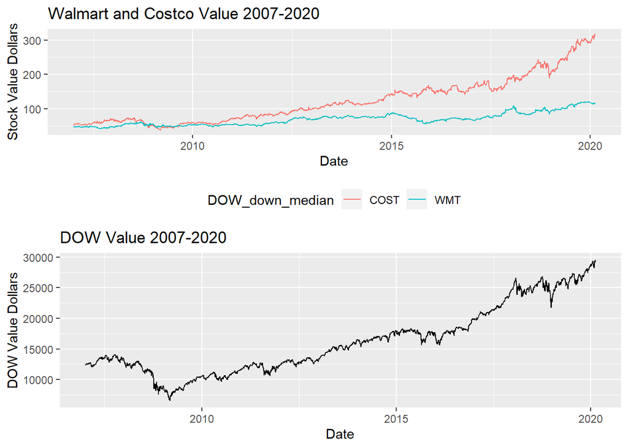

```r
wal_Cost <- subset(Close17_dow, Close17_dow$DOW_down_median=='WMT' |
                     Close17_dow$DOW_down_median=='COST')

gg9 <- ggplot(data = wal_Cost, aes(x=Date, y=stockValue, group=DOW_down_median)) +
       geom_line(aes(color=DOW_down_median))+
       scale_y_continuous()+
       theme(legend.position="bottom")+
       ggtitle('Walmart and Costco Value 2007-2020')+
       ylab('Stock Value Dollars')

grid.arrange(gg9,gg8, nrow = 2)
```

It is interesting to note that Costco and the DOW seem to be identical curves for the direction they move while Walmart seems also be increasing when the DOW does but at a much lower rate over time.

Lets now compare TJ Maxx, Ross, Nike, and Adidas to the DOW.

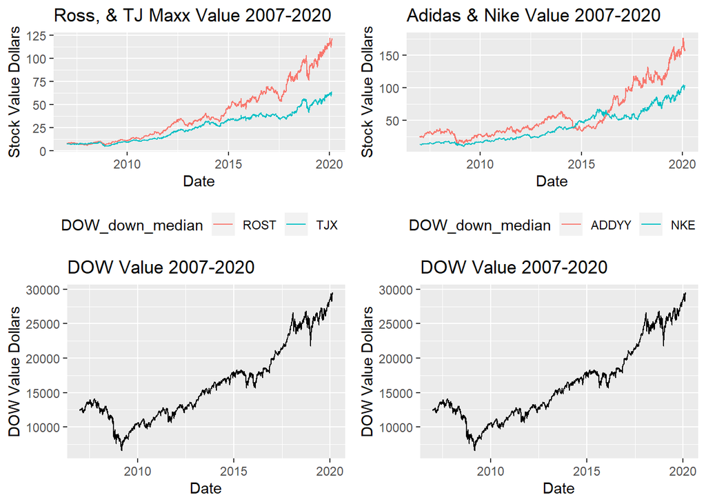

```r
Retail <- subset(Close17_dow, Close17_dow$DOW_down_median == 'TJX' |
                   Close17_dow$DOW_down_median == 'ROST' )

Shoes <- subset(Close17_dow, Close17_dow$DOW_down_median == 'NKE' |
                   Close17_dow$DOW_down_median == 'ADDYY' )


gg10 <- ggplot(data = Retail, aes(x=Date, y=stockValue, group=DOW_down_median)) +
       geom_line(aes(color=DOW_down_median))+
       scale_y_continuous()+
       theme(legend.position="bottom")+
       ggtitle('Ross, & TJ Maxx Value 2007-2020')+
       ylab('Stock Value Dollars')

gg11 <- ggplot(data = Shoes, aes(x=Date, y=stockValue, group=DOW_down_median)) +
       geom_line(aes(color=DOW_down_median))+
       scale_y_continuous()+
       theme(legend.position="bottom")+
       ggtitle('Adidas & Nike Value 2007-2020')+
       ylab('Stock Value Dollars')

grid.arrange(gg10, gg11, gg8, gg8, nrow =2)
```

The DOW is plotted below each of the two plots of either Ross & TJ Maxx, or Adidas & Nike. Both Ross and Adidas did better than TJ Maxx and Nike. Except, that Nike did do better than Adidas between 2015 and 2016.

Now, lets look at Dollar Tree and Amazon compared to each other and the DOW in this time span.

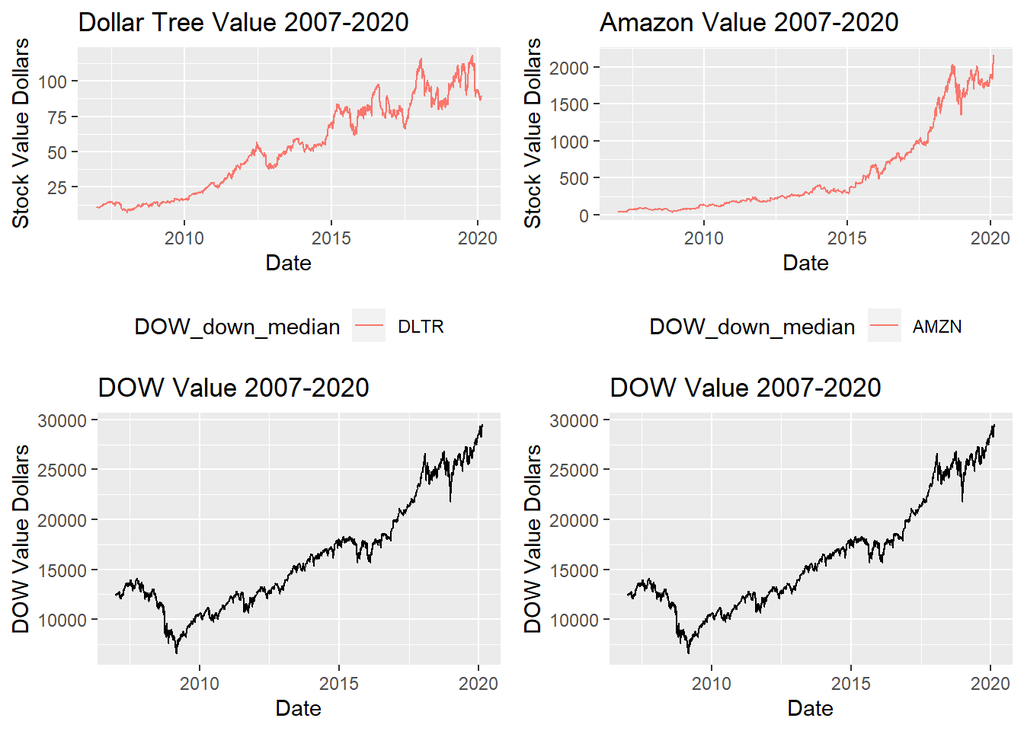

```r
DLRv <- subset(Close17_dow, Close17_dow$DOW_down_median == 'DLTR' )
AMZNv <- subset(Close17_dow, Close17_dow$DOW_down_median == 'AMZN' )


gg12 <- ggplot(data = DLRv, aes(x=Date, y=stockValue, group=DOW_down_median)) +
       geom_line(aes(color=DOW_down_median))+
       scale_y_continuous()+
       theme(legend.position="bottom")+
       ggtitle('Dollar Tree Value 2007-2020')+
       ylab('Stock Value Dollars')

gg13 <- ggplot(data = AMZNv, aes(x=Date, y=stockValue, group=DOW_down_median)) +
       geom_line(aes(color=DOW_down_median))+
       scale_y_continuous()+
       theme(legend.position="bottom")+
       ggtitle('Amazon Value 2007-2020')+
       ylab('Stock Value Dollars')

grid.arrange(gg12, gg13, gg8, gg8, nrow =2)
```

The above charts show Dollar Tree compared to Amazon and both compared to the DOW between 2007 and 2020. The Dollar Tree seems to be cyclical but overall increasing, while Amazon was a steady increase over the years except in 2018 where it had a decrease.

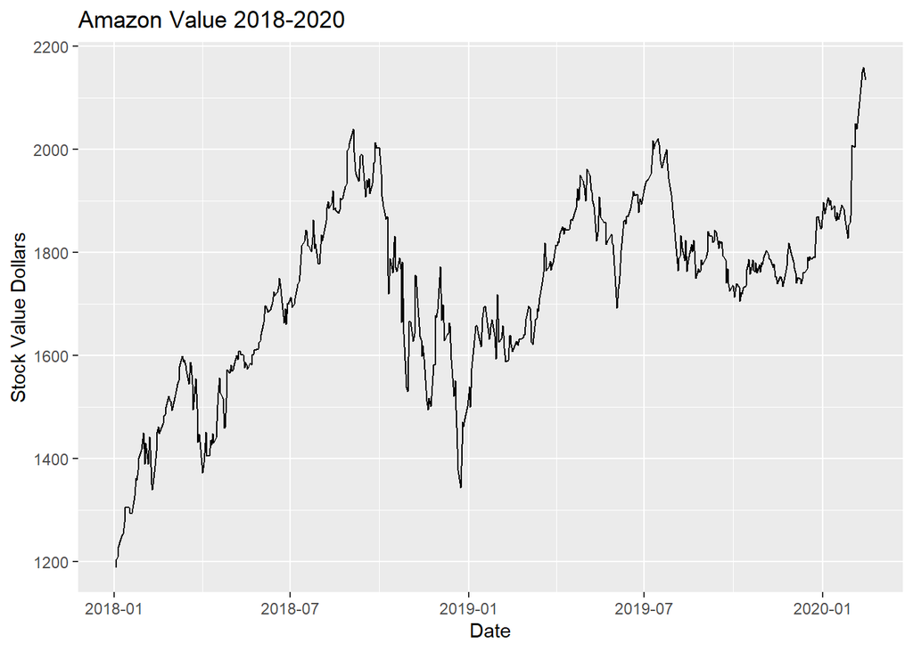

```r
AMZNv2 <- subset(Close17_dow, Close17_dow$Year > 2017 &
                   Close17_dow$DOW_down_median == 'AMZN')

gg14 <- ggplot(data = AMZNv2, aes(x=Date, y=stockValue)) +
       geom_line()+
       scale_y_continuous()+
       theme(legend.position="bottom")+
       ggtitle('Amazon Value 2018-2020')+
       ylab('Stock Value Dollars')
gg14
```

Lets look at Home Depot and Advance Auto parts now.

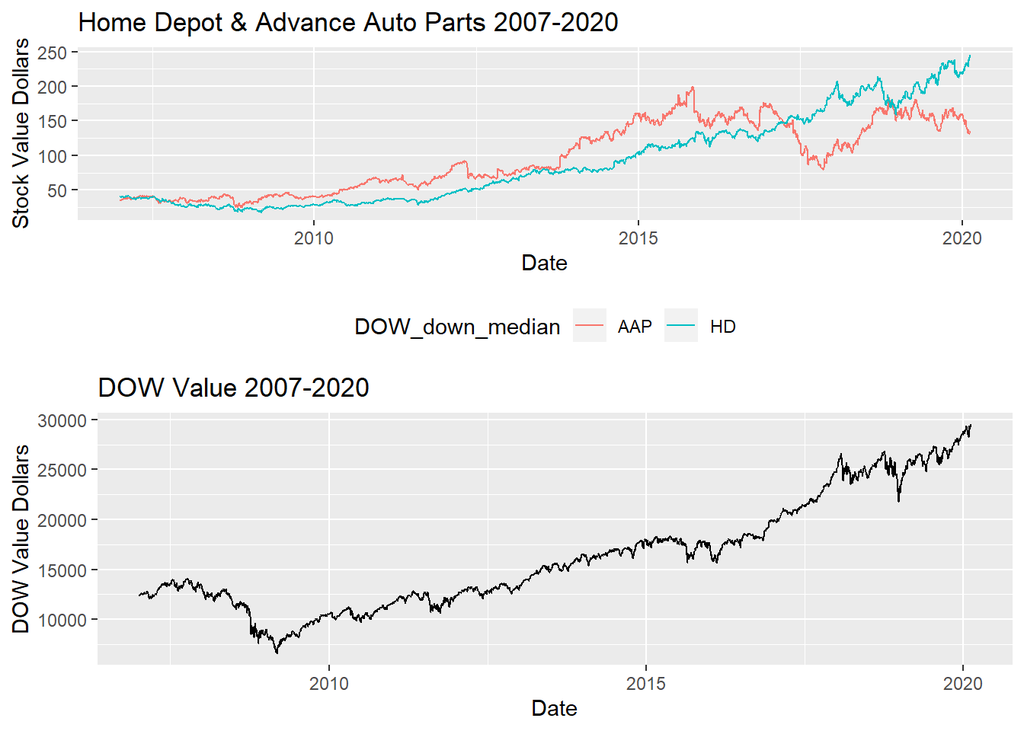

```r
HDv <- subset(Close17_dow, Close17_dow$DOW_down_median=='HD' |
                Close17_dow$DOW_down_median=='AAP')

gg15 <- ggplot(data = HDv, aes(x=Date, y=stockValue, group=DOW_down_median)) +
       geom_line(aes(color=DOW_down_median))+
       scale_y_continuous()+
       theme(legend.position="bottom")+
       ggtitle('Home Depot & Advance Auto Parts 2007-2020')+
       ylab('Stock Value Dollars')

grid.arrange(gg15, gg8, nrow =2)
```

Lets also look at Google and First Financial Bankshares.

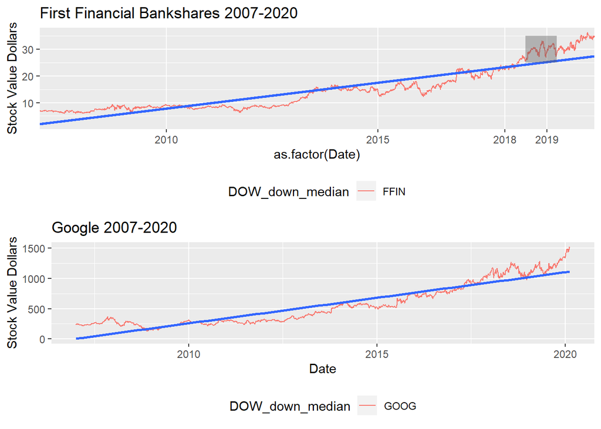

```r
ffin <- subset(Close17_dow, Close17_dow$DOW_down_median=='FFIN')
goog <- subset(Close17_dow, Close17_dow$DOW_down_median=='GOOG')

gg16 <- ggplot(data=ffin, aes(x=as.factor(Date), y=stockValue, group=DOW_down_median))+
        geom_line(aes(color=DOW_down_median))+
        geom_smooth(method = "lm")+
        annotate("rect", xmin = "2018-07-01", xmax = "2019-03-31", ymin = 25, ymax = 35,
        alpha = .4)+
        scale_x_discrete(breaks=c("2010-01-04","2015-01-02","2018-01-05",
                                  "2019-01-03"),
                         labels=c("2010","2015", "2018","2019"))+
        scale_y_continuous()+
        theme(legend.position="bottom")+
        ggtitle('First Financial Bankshares 2007-2020')+
        ylab('Stock Value Dollars')

gg17 <- ggplot(data = goog, aes(x=Date, y=stockValue, group=DOW_down_median)) +
       geom_line(aes(color=DOW_down_median))+
       geom_smooth(method = "lm")+
       scale_y_continuous()+
       theme(legend.position="bottom")+
       ggtitle('Google 2007-2020')+
       ylab('Stock Value Dollars')

grid.arrange(gg16, gg17,nrow =2)
```

The above chart shows Google and First Financial Bankshares from 2007-2020. First Financial has many highs and lows between 2015-2020 but is overall increasing, while Google is steadily increasing up till 2017 when it has a few highs and lows until 2020. Both have increased overall as indicated by the linear trendlines added to the two linear plots above for Google and First Financial Bankshares.

We know that some of these plots have time periods that are cyclical, but so far we know that overall, if we want to earn the most on our portfolios we would like to buy low and sell high. These stocks are increasing to rates higher than when they start a cyclical pattern. Lets examine the First Financial Bankshares stock when it sees these cyclical patterns further for some strategy development. There are three peaks or highs for FFIN after about 2017, so lets plot this.

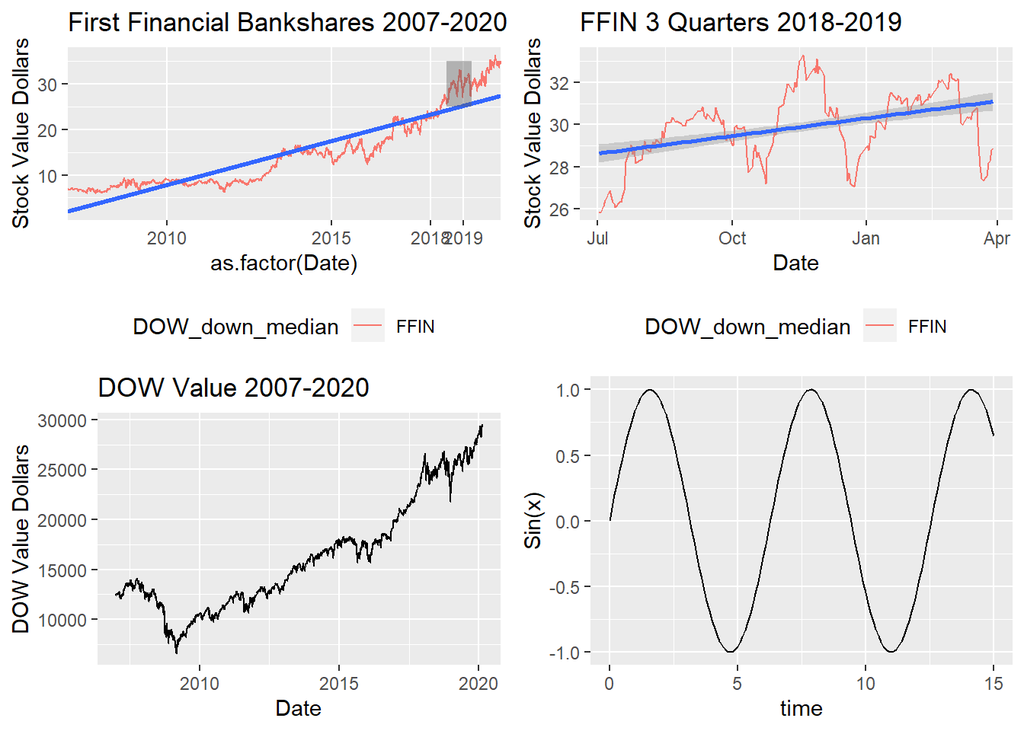

```r
ffin2 <- subset(ffin, ffin$Year==2018 & ffin$Month=='Jul'|
                  ffin$Year==2018 & ffin$Month=='Aug'|
                  ffin$Year==2018 & ffin$Month=='Sep'|
                  ffin$Year==2018 & ffin$Month=='Oct'|
                  ffin$Year==2018 & ffin$Month=='Nov'|
                  ffin$Year==2018 & ffin$Month=='Dec'|
                  ffin$Year==2019 & ffin$Month=='Jan'|
                  ffin$Year==2019 & ffin$Month=='Feb'|
                  ffin$Year==2019 & ffin$Month=='Mar')



t <- seq(0,15,0.1)
y <- sin(t)
ty <- qplot(t,y, geom='path', xlab='time', ylab='Sin(x)')

gg18 <- ggplot(data=ffin2, aes(x=Date, y=stockValue, group=DOW_down_median))+
        geom_line(aes(color=DOW_down_median))+
        geom_smooth(method = "lm")+
        scale_y_continuous()+
        theme(legend.position="bottom")+
        ggtitle('FFIN 3 Quarters 2018-2019')+
        ylab('Stock Value Dollars')

grid.arrange(gg16,gg18,gg8, ty,nrow=2)
```

The above chart shows the sine curve to illustrate the highs and lows of the daily value changes for the First Financial Bankshares linear plot. If the curve was distorted at certain time intervals startind in the 3rd quarter of 2018 and ending before the 2nd quarter of 2019, this sine curve would show the three waves this stock saw. We are interested in buying at the beginning of the 3rd quarter when the price is low, then selling before the start of the 4th quarter when the stock is high, then buying again when it sees a dip in price after about the 1st month of the 4th quarter, then selling in the middle of the 4th quarter when high, buying at the end of the 4th quarter when low, and selling when high in the middle of the 1st quarter of 2019, and buying when low at the end of the 1st quarter, to maximize profits.

These quick analysis of the stock that did well when the DOW was decreasing and unemployment was increasing was interesting to look at. But now, lets look at these stocks and find out if we can indicate when a stock is good by setting a threshold for the number of minimums the stock has and if it decreases by more than its value in the last quarter and also the last two quarters then compare this to the local maxima where it increases to more than a set threshold than it was valued at in the last quarter and also the last two quarters. Count the number of times this happens and compare to the data on the stock ROI. This will require adding in more columns to calculate the daily change compared to a median value of the stock in each quarter. We have the years, the months, and the stock values in the table we are currently using.

We can do this by using time lags with the dplyr package. We should already have this package loaded. We have been using for median and mean calculations when grouping by stock. The data set we should use could be this one, Close17_dow, or we could spread out the stock names back to being columns and add the stock lags for each stock for 7 days, 30 days, 90 days, and 180 days. Don’t get too excited, we have 53 stocks to do this for, or we could just do it with these 17 stocks that made the most profit from having positive median values when unemployment was increasing and the DOW was decreasing. I vote we do the 17. ***

We are going to create time lags of 7,30,60,90, 120, 150, and 180 days to see if there are any rolling stock values that could indicate when to buy or sell and pin point are threshold values and possibly work this into an automated program later with continuous uploads of these stocks in monitoring our portfolio of stock.

```r
Close17_dow <- Close17_dow[with(Close17_dow, order(DOW_down_median, Date)),]

Laap <- subset(Close17_dow, Close17_dow$DOW_down_median=='AAP')
Laddyy <- subset(Close17_dow, Close17_dow$DOW_down_median=='ADDYY')
Lamzn <- subset(Close17_dow, Close17_dow$DOW_down_median=='AMZN')
Lcost <- subset(Close17_dow, Close17_dow$DOW_down_median=='COST')
Ldltr <- subset(Close17_dow, Close17_dow$DOW_down_median=='DLTR')
Lffin <- subset(Close17_dow, Close17_dow$DOW_down_median=='FFIN')
Lgoog <- subset(Close17_dow, Close17_dow$DOW_down_median=='GOOG')
Lhd <- subset(Close17_dow, Close17_dow$DOW_down_median=='HD')
Ljnj <- subset(Close17_dow, Close17_dow$DOW_down_median=='JNJ')
Lnflx <- subset(Close17_dow, Close17_dow$DOW_down_median=='NFLX')
Lnke <- subset(Close17_dow, Close17_dow$DOW_down_median=='NKE')
Lpcg <- subset(Close17_dow, Close17_dow$DOW_down_median=='PCG')
Lrost <- subset(Close17_dow, Close17_dow$DOW_down_median=='ROST')
Lteva <- subset(Close17_dow, Close17_dow$DOW_down_median=='TEVA')
Ltjx <- subset(Close17_dow, Close17_dow$DOW_down_median=='TJX')
Lwmt <- subset(Close17_dow, Close17_dow$DOW_down_median=='WMT')
Lxom <- subset(Close17_dow, Close17_dow$DOW_down_median=='XOM')

aapL7 <- lag(Laap$stockValue,7)
addyyL7 <- lag(Laddyy$stockValue,7)
amznL7 <- lag(Lamzn$stockValue,7)
costL7 <- lag(Lcost$stockValue,7)
dltrL7 <- lag(Ldltr$stockValue,7)
ffinL7 <- lag(Lffin$stockValue,7)
googL7 <- lag(Lgoog$stockValue,7)
hdL7 <- lag(Lhd$stockValue,7)
jnjL7 <- lag(Ljnj$stockValue,7)
nflxL7 <- lag(Lnflx$stockValue,7)
nkeL7 <- lag(Lnke$stockValue,7)
pcgL7 <- lag(Lpcg$stockValue,7)
rostL7 <- lag(Lrost$stockValue,7)
tevaL7 <- lag(Lteva$stockValue,7)
tjxL7 <- lag(Ltjx$stockValue,7)
wmtL7 <- lag(Lwmt$stockValue,7)
xomL7 <- lag(Lxom$stockValue,7)

Close17_dow$lag7 <- c(aapL7,addyyL7,amznL7,costL7,dltrL7,ffinL7,googL7,
                                  hdL7,jnjL7,nflxL7,nkeL7,pcgL7,rostL7,tevaL7,
                                  tjxL7,wmtL7,xomL7)

aapL30 <- lag(Laap$stockValue,30)
addyyL30 <- lag(Laddyy$stockValue,30)
amznL30 <- lag(Lamzn$stockValue,30)
costL30 <- lag(Lcost$stockValue,30)
dltrL30 <- lag(Ldltr$stockValue,30)
ffinL30 <- lag(Lffin$stockValue,30)
googL30 <- lag(Lgoog$stockValue,30)
hdL30 <- lag(Lhd$stockValue,30)
jnjL30 <- lag(Ljnj$stockValue,30)
nflxL30 <- lag(Lnflx$stockValue,30)
nkeL30 <- lag(Lnke$stockValue,30)
pcgL30 <- lag(Lpcg$stockValue,30)
rostL30 <- lag(Lrost$stockValue,30)
tevaL30 <- lag(Lteva$stockValue,30)
tjxL30 <- lag(Ltjx$stockValue,30)
wmtL30 <- lag(Lwmt$stockValue,30)
xomL30 <- lag(Lxom$stockValue,30)

Close17_dow$lag30 <- c(aapL30,addyyL30,amznL30,costL30,dltrL30,ffinL30,googL30,
                                  hdL30,jnjL30,nflxL30,nkeL30,pcgL30,rostL30,tevaL30,
                                  tjxL30,wmtL30,xomL30)


aapL60 <- lag(Laap$stockValue,60)
addyyL60 <- lag(Laddyy$stockValue,60)
amznL60 <- lag(Lamzn$stockValue,60)
costL60 <- lag(Lcost$stockValue,60)
dltrL60 <- lag(Ldltr$stockValue,60)
ffinL60 <- lag(Lffin$stockValue,60)
googL60 <- lag(Lgoog$stockValue,60)
hdL60 <- lag(Lhd$stockValue,60)
jnjL60 <- lag(Ljnj$stockValue,60)
nflxL60 <- lag(Lnflx$stockValue,60)
nkeL60 <- lag(Lnke$stockValue,60)
pcgL60 <- lag(Lpcg$stockValue,60)
rostL60 <- lag(Lrost$stockValue,60)
tevaL60 <- lag(Lteva$stockValue,60)
tjxL60 <- lag(Ltjx$stockValue,60)
wmtL60 <- lag(Lwmt$stockValue,60)
xomL60 <- lag(Lxom$stockValue,60)

Close17_dow$lag60 <- c(aapL60,addyyL60,amznL60,costL60,dltrL60,ffinL60,googL60,
                                  hdL60,jnjL60,nflxL60,nkeL60,pcgL60,rostL60,tevaL60,
                                  tjxL60,wmtL60,xomL60)

aapL90 <- lag(Laap$stockValue,90)
addyyL90 <- lag(Laddyy$stockValue,90)
amznL90 <- lag(Lamzn$stockValue,90)
costL90 <- lag(Lcost$stockValue,90)
dltrL90 <- lag(Ldltr$stockValue,90)
ffinL90 <- lag(Lffin$stockValue,90)
googL90 <- lag(Lgoog$stockValue,90)
hdL90 <- lag(Lhd$stockValue,90)
jnjL90 <- lag(Ljnj$stockValue,90)
nflxL90 <- lag(Lnflx$stockValue,90)
nkeL90 <- lag(Lnke$stockValue,90)
pcgL90 <- lag(Lpcg$stockValue,90)
rostL90 <- lag(Lrost$stockValue,90)
tevaL90 <- lag(Lteva$stockValue,90)
tjxL90 <- lag(Ltjx$stockValue,90)
wmtL90 <- lag(Lwmt$stockValue,90)
xomL90 <- lag(Lxom$stockValue,90)

Close17_dow$lag90 <- c(aapL90,addyyL90,amznL90,costL90,dltrL90,ffinL90,googL90,
                                  hdL90,jnjL90,nflxL90,nkeL90,pcgL90,rostL90,tevaL90,
                                  tjxL90,wmtL90,xomL90)

aapL120 <- lag(Laap$stockValue,120)
addyyL120 <- lag(Laddyy$stockValue,120)
amznL120 <- lag(Lamzn$stockValue,120)
costL120 <- lag(Lcost$stockValue,120)
dltrL120 <- lag(Ldltr$stockValue,120)
ffinL120 <- lag(Lffin$stockValue,120)
googL120 <- lag(Lgoog$stockValue,120)
hdL120 <- lag(Lhd$stockValue,120)
jnjL120 <- lag(Ljnj$stockValue,120)
nflxL120 <- lag(Lnflx$stockValue,120)
nkeL120 <- lag(Lnke$stockValue,120)
pcgL120 <- lag(Lpcg$stockValue,120)
rostL120 <- lag(Lrost$stockValue,120)
tevaL120 <- lag(Lteva$stockValue,120)
tjxL120 <- lag(Ltjx$stockValue,120)
wmtL120 <- lag(Lwmt$stockValue,120)
xomL120 <- lag(Lxom$stockValue,120)

Close17_dow$lag120 <- c(aapL120,addyyL120,amznL120,costL120,dltrL120,ffinL120,googL120,
                                  hdL120,jnjL120,nflxL120,nkeL120,pcgL120,rostL120,tevaL120,
                                  tjxL120,wmtL120,xomL120)

aapL150 <- lag(Laap$stockValue,150)
addyyL150 <- lag(Laddyy$stockValue,150)
amznL150 <- lag(Lamzn$stockValue,150)
costL150 <- lag(Lcost$stockValue,150)
dltrL150 <- lag(Ldltr$stockValue,150)
ffinL150 <- lag(Lffin$stockValue,150)
googL150 <- lag(Lgoog$stockValue,150)
hdL150 <- lag(Lhd$stockValue,150)
jnjL150 <- lag(Ljnj$stockValue,150)
nflxL150 <- lag(Lnflx$stockValue,150)
nkeL150 <- lag(Lnke$stockValue,150)
pcgL150 <- lag(Lpcg$stockValue,150)
rostL150 <- lag(Lrost$stockValue,150)
tevaL150 <- lag(Lteva$stockValue,150)
tjxL150 <- lag(Ltjx$stockValue,150)
wmtL150 <- lag(Lwmt$stockValue,150)
xomL150 <- lag(Lxom$stockValue,150)

Close17_dow$lag150 <- c(aapL150,addyyL150,amznL150,costL150,dltrL150,ffinL150,googL150,
                                  hdL150,jnjL150,nflxL150,nkeL150,pcgL150,rostL150,tevaL150,
                                  tjxL150,wmtL150,xomL150)

aapL180 <- lag(Laap$stockValue,180)
addyyL180 <- lag(Laddyy$stockValue,180)
amznL180 <- lag(Lamzn$stockValue,180)
costL180 <- lag(Lcost$stockValue,180)
dltrL180 <- lag(Ldltr$stockValue,180)
ffinL180 <- lag(Lffin$stockValue,180)
googL180 <- lag(Lgoog$stockValue,180)
hdL180 <- lag(Lhd$stockValue,180)
jnjL180 <- lag(Ljnj$stockValue,180)
nflxL180 <- lag(Lnflx$stockValue,180)
nkeL180 <- lag(Lnke$stockValue,180)
pcgL180 <- lag(Lpcg$stockValue,180)
rostL180 <- lag(Lrost$stockValue,180)
tevaL180 <- lag(Lteva$stockValue,180)
tjxL180 <- lag(Ltjx$stockValue,180)
wmtL180 <- lag(Lwmt$stockValue,180)
xomL180 <- lag(Lxom$stockValue,180)

Close17_dow$lag180 <- c(aapL180,addyyL180,amznL180,costL180,dltrL180,ffinL180,googL180,
                                  hdL180,jnjL180,nflxL180,nkeL180,pcgL180,rostL180,tevaL180,
                                  tjxL180,wmtL180,xomL180)
```

```r
write.csv(Close17_dow, 'Close17_dow_lags.csv', row.names=FALSE)
```

```r
head(Close17_dow,10)
```

```
##           Date DOW_down_median Month Year UE_monthlyRate stockValue DOW_Close
## 1   2007-01-03             AAP   Jan 2007            4.6      35.58  12474.52
## 18  2007-01-04             AAP   Jan 2007            4.6      35.81  12480.69
## 35  2007-01-05             AAP   Jan 2007            4.6      35.02  12398.01
## 52  2007-01-08             AAP   Jan 2007            4.6      35.14  12423.49
## 69  2007-01-09             AAP   Jan 2007            4.6      35.44  12416.60
## 86  2007-01-10             AAP   Jan 2007            4.6      35.49  12442.16
## 103 2007-01-11             AAP   Jan 2007            4.6      36.40  12514.98
## 120 2007-01-12             AAP   Jan 2007            4.6      36.20  12556.08
## 137 2007-01-16             AAP   Jan 2007            4.6      36.20  12582.59
## 154 2007-01-17             AAP   Jan 2007            4.6      36.35  12577.15
##      lag7 lag30 lag60 lag90 lag120 lag150 lag180
## 1      NA    NA    NA    NA     NA     NA     NA
## 18     NA    NA    NA    NA     NA     NA     NA
## 35     NA    NA    NA    NA     NA     NA     NA
## 52     NA    NA    NA    NA     NA     NA     NA
## 69     NA    NA    NA    NA     NA     NA     NA
## 86     NA    NA    NA    NA     NA     NA     NA
## 103    NA    NA    NA    NA     NA     NA     NA
## 120 35.58    NA    NA    NA     NA     NA     NA
## 137 35.81    NA    NA    NA     NA     NA     NA
## 154 35.02    NA    NA    NA     NA     NA     NA
```

```r
tail(Close17_dow,10)
```

```
##             Date DOW_down_median Month Year UE_monthlyRate stockValue DOW_Close
## 55998 2020-02-03             XOM   Feb 2020             NA      60.73  28399.81
## 56015 2020-02-04             XOM   Feb 2020             NA      59.97  28807.63
## 56032 2020-02-05             XOM   Feb 2020             NA      62.73  29290.85
## 56049 2020-02-06             XOM   Feb 2020             NA      61.88  29379.77
## 56066 2020-02-07             XOM   Feb 2020             NA      61.47  29102.51
## 56083 2020-02-10             XOM   Feb 2020             NA      59.96  29276.82
## 56100 2020-02-11             XOM   Feb 2020             NA      60.53  29276.34
## 56117 2020-02-12             XOM   Feb 2020             NA      61.27  29551.42
## 56134 2020-02-13             XOM   Feb 2020             NA      60.93  29423.31
## 56151 2020-02-14             XOM   Feb 2020             NA      60.65  29398.08
##        lag7 lag30 lag60 lag90 lag120 lag150 lag180
## 55998 66.77 69.87 73.09 71.14  69.63  76.63  76.36
## 56015 66.32 69.39 71.49 71.35  70.49  76.56  75.91
## 56032 64.74 69.94 73.01 70.97  67.65  75.72  75.90
## 56049 64.65 70.29 70.77 71.48  67.25  76.44  76.25
## 56066 64.11 70.02 70.34 70.61  68.30  76.13  75.56
## 56083 64.79 70.13 69.37 68.95  69.45  76.48  73.79
## 56100 62.12 69.89 68.80 67.15  69.03  76.43  74.10
## 56117 60.73 69.48 68.50 67.98  69.72  77.51  72.61
## 56134 59.97 69.78 69.19 68.97  69.57  77.57  72.16
## 56151 62.73 70.90 68.52 68.02  67.49  77.63  71.97
```

Now create the ratios of current day’s stock value to the lag day stock value. This will allow us to see how these stocks compare to previous days, and get median and average fold change values or ratios.

```r
Close17_dow$today2lag7 <- Close17_dow$lag7/Close17_dow$stockValue
Close17_dow$today2lag30 <- Close17_dow$lag30/Close17_dow$stockValue
Close17_dow$today2lag60 <- Close17_dow$lag60/Close17_dow$stockValue
Close17_dow$today2lag90 <- Close17_dow$lag90/Close17_dow$stockValue
Close17_dow$today2lag120 <- Close17_dow$lag120/Close17_dow$stockValue
Close17_dow$today2lag150 <- Close17_dow$lag150/Close17_dow$stockValue
Close17_dow$today2lag180 <- Close17_dow$lag180/Close17_dow$stockValue
```

Group by the stock names in this table and add a median value for each lag value.

```r
median17today2lag7 <- Close17_dow %>% group_by(DOW_down_median) %>%
  summarise_at(vars(today2lag7), median, na.rm=T)
median17today2lag30 <- Close17_dow %>% group_by(DOW_down_median) %>%
  summarise_at(vars(today2lag30), median, na.rm=T)
median17today2lag60 <- Close17_dow %>% group_by(DOW_down_median) %>%
  summarise_at(vars(today2lag60), median, na.rm=T)
median17today2lag90 <- Close17_dow %>% group_by(DOW_down_median) %>%
  summarise_at(vars(today2lag90), median, na.rm=T)
median17today2lag120 <- Close17_dow %>% group_by(DOW_down_median) %>%
  summarise_at(vars(today2lag120), median, na.rm=T)
median17today2lag150 <- Close17_dow %>% group_by(DOW_down_median) %>%
  summarise_at(vars(today2lag150), median, na.rm=T)
median17today2lag180 <- Close17_dow %>% group_by(DOW_down_median) %>%
  summarise_at(vars(today2lag180), median, na.rm=T)

mediantoday2lags <- cbind(median17today2lag7, median17today2lag30[2], median17today2lag60[2], median17today2lag90[2],
                    median17today2lag120[2], median17today2lag150[2], median17today2lag180[2])
colnames(mediantoday2lags)[2:8] <- paste('median',colnames(mediantoday2lags)[2:8], sep='')
Close17_dow1 <- merge(Close17_dow, mediantoday2lags, by.x='DOW_down_median', by.y='DOW_down_median')
```

Group by the stock name and now add a mean value. This will be to gather our threshold values to possibly indicate when its good to buy or sell. We will compare this later to the true outcome of each stock.

```r
meantoday2lag7 <- Close17_dow %>% group_by(DOW_down_median) %>%
  summarise_at(vars(today2lag7),mean, na.rm=T)
meantoday2lag30 <- Close17_dow %>% group_by(DOW_down_median) %>%
  summarise_at(vars(today2lag30),mean, na.rm=T)
meantoday2lag60 <- Close17_dow %>% group_by(DOW_down_median) %>%
  summarise_at(vars(today2lag60),mean, na.rm=T)
meantoday2lag90 <- Close17_dow %>% group_by(DOW_down_median) %>%
  summarise_at(vars(today2lag90),mean, na.rm=T)
meantoday2lag120 <- Close17_dow %>% group_by(DOW_down_median) %>%
  summarise_at(vars(today2lag120),mean, na.rm=T)
meantoday2lag150 <- Close17_dow %>% group_by(DOW_down_median) %>%
  summarise_at(vars(today2lag150),mean, na.rm=T)
meantoday2lag180 <- Close17_dow %>% group_by(DOW_down_median) %>%
  summarise_at(vars(today2lag180),mean, na.rm=T)

meantoday2lags <- cbind(meantoday2lag7, meantoday2lag30[2], meantoday2lag60[2], meantoday2lag90[2],
                    meantoday2lag120[2], meantoday2lag150[2], meantoday2lag180[2])
colnames(meantoday2lags)[2:8] <- paste('mean',colnames(meantoday2lags)[2:8], sep='')
Close17_dow2 <- merge(Close17_dow1, meantoday2lags, by.x='DOW_down_median', by.y='DOW_down_median')
```

We should also get the min to know our local minimas in each today2lag.

```r
minimumtoday2lag7 <- Close17_dow %>% group_by(DOW_down_median) %>%
  summarise_at(vars(today2lag7),min, na.rm=T)
minimumtoday2lag30 <- Close17_dow %>% group_by(DOW_down_median) %>%
  summarise_at(vars(today2lag30),min, na.rm=T)
minimumtoday2lag60 <- Close17_dow %>% group_by(DOW_down_median) %>%
  summarise_at(vars(today2lag60),min, na.rm=T)
minimumtoday2lag90 <- Close17_dow %>% group_by(DOW_down_median) %>%
  summarise_at(vars(today2lag90),min, na.rm=T)
minimumtoday2lag120 <- Close17_dow %>% group_by(DOW_down_median) %>%
  summarise_at(vars(today2lag120),min, na.rm=T)
minimumtoday2lag150 <- Close17_dow %>% group_by(DOW_down_median) %>%
  summarise_at(vars(today2lag150),min, na.rm=T)
minimumtoday2lag180 <- Close17_dow %>% group_by(DOW_down_median) %>%
  summarise_at(vars(today2lag180),min, na.rm=T)

minimumtoday2lags <- cbind(minimumtoday2lag7, minimumtoday2lag30[2], minimumtoday2lag60[2], minimumtoday2lag90[2],
                    minimumtoday2lag120[2], minimumtoday2lag150[2], minimumtoday2lag180[2])
colnames(minimumtoday2lags)[2:8] <- paste('minimum',colnames(minimumtoday2lags)[2:8], sep='')
Close17_dow3 <- merge(Close17_dow2, minimumtoday2lags, by.x='DOW_down_median', by.y='DOW_down_median')
```

Lets also add our local maximas by getting the max values for each of these today2lags.

```r
maximumtoday2lag7 <- Close17_dow %>% group_by(DOW_down_median) %>%
  summarise_at(vars(today2lag7),max, na.rm=T)
maximumtoday2lag30 <- Close17_dow %>% group_by(DOW_down_median) %>%
  summarise_at(vars(today2lag30),max, na.rm=T)
maximumtoday2lag60 <- Close17_dow %>% group_by(DOW_down_median) %>%
  summarise_at(vars(today2lag60),max, na.rm=T)
maximumtoday2lag90 <- Close17_dow %>% group_by(DOW_down_median) %>%
  summarise_at(vars(today2lag90),max, na.rm=T)
maximumtoday2lag120 <- Close17_dow %>% group_by(DOW_down_median) %>%
  summarise_at(vars(today2lag120),max, na.rm=T)
maximumtoday2lag150 <- Close17_dow %>% group_by(DOW_down_median) %>%
  summarise_at(vars(today2lag150),max, na.rm=T)
maximumtoday2lag180 <- Close17_dow %>% group_by(DOW_down_median) %>%
  summarise_at(vars(today2lag180),max, na.rm=T)

maximumtoday2lags <- cbind(maximumtoday2lag7, maximumtoday2lag30[2], maximumtoday2lag60[2], maximumtoday2lag90[2],
                    maximumtoday2lag120[2], maximumtoday2lag150[2], maximumtoday2lag180[2])
colnames(maximumtoday2lags)[2:8] <- paste('maximum',colnames(maximumtoday2lags)[2:8], sep='')
Close17_dow4 <- merge(Close17_dow3, maximumtoday2lags, by.x='DOW_down_median', by.y='DOW_down_median')
```

Write to file

```r
write.csv(Close17_dow4, 'Close17_dow4_lagStats.csv', row.names=FALSE)
```

Smaller file of the above, you can rbind() the two together, after importing them if needed.

```r
Close17_dow4_a <- Close17_dow4[1:28500,]
Close17_dow4_b <- Close17_dow4[28501:56151,]
write.csv(Close17_dow4_a, 'Close17_dow4_lagStats_parta.csv', row.names=TRUE)
write.csv(Close17_dow4_b, 'Close17_dow4_lagStats_partb.csv', row.names=TRUE)
```

The fields for the median and mean ratios of todays value to the value 7,30,60,90,120,150, and 180 days prior give some useful information. The minimum and maximum fields give the minimum and maximum ratio values for each group and could also provide some useful information.

Lets get the median values of the 17 stock in terms of each median lag and mean lag ratio. Then compare. But lets get a summary of those fields first to see the quantiles, that could help us decide which stocks to categorize based on its behavior in time.

```r
summary(Close17_dow4[22:35])
```

```
##  mediantoday2lag7 mediantoday2lag30 mediantoday2lag60 mediantoday2lag90
##  Min.   :0.9897   Min.   :0.9452    Min.   :0.8916    Min.   :0.8493
##  1st Qu.:0.9937   1st Qu.:0.9742    1st Qu.:0.9511    1st Qu.:0.9348
##  Median :0.9947   Median :0.9787    Median :0.9570    Median :0.9412
##  Mean   :0.9951   Mean   :0.9791    Mean   :0.9599    Mean   :0.9454
##  3rd Qu.:0.9971   3rd Qu.:0.9893    3rd Qu.:0.9810    3rd Qu.:0.9681
##  Max.   :1.0001   Max.   :0.9996    Max.   :1.0061    Max.   :1.0089
##  mediantoday2lag120 mediantoday2lag150 mediantoday2lag180 meantoday2lag7
##  Min.   :0.8105     Min.   :0.7771     Min.   :0.7388     Min.   :0.9932
##  1st Qu.:0.9091     1st Qu.:0.8921     1st Qu.:0.8667     1st Qu.:0.9963
##  Median :0.9241     Median :0.9079     Median :0.8928     Median :0.9971
##  Mean   :0.9312     Mean   :0.9184     Mean   :0.9023     Mean   :0.9979
##  3rd Qu.:0.9630     3rd Qu.:0.9549     3rd Qu.:0.9455     3rd Qu.:0.9985
##  Max.   :1.0158     Max.   :1.0208     Max.   :1.0235     Max.   :1.0063
##  meantoday2lag30  meantoday2lag60  meantoday2lag90  meantoday2lag120
##  Min.   :0.9715   Min.   :0.9446   Min.   :0.9185   Min.   :0.8938
##  1st Qu.:0.9837   1st Qu.:0.9676   1st Qu.:0.9515   1st Qu.:0.9363
##  Median :0.9879   Median :0.9755   Median :0.9624   Median :0.9493
##  Mean   :0.9909   Mean   :0.9827   Mean   :0.9748   Mean   :0.9663
##  3rd Qu.:0.9935   3rd Qu.:0.9866   3rd Qu.:0.9798   3rd Qu.:0.9728
##  Max.   :1.0250   Max.   :1.0588   Max.   :1.0879   Max.   :1.1073
##  meantoday2lag150 meantoday2lag180
##  Min.   :0.8680   Min.   :0.8424
##  1st Qu.:0.9220   1st Qu.:0.9075
##  Median :0.9358   Median :0.9233
##  Mean   :0.9571   Mean   :0.9477
##  3rd Qu.:0.9657   3rd Qu.:0.9578
##  Max.   :1.1225   Max.   :1.1520
```

Lets recall which stocks were not returning profits and those that were. There were three stocks that didn’t return profits(XOM, TEVA, and PCG), and 14 that did. But only those three and one other stock didn’t beat the DOW (JNJ). The table with this information is dROI17.

```r
dROI17
```

```
## # A tibble: 17 x 7
##    DOW_down_median avgStockValue startValue finalValue DOW_ROI stock_ROI
##    <chr>                   <dbl>      <dbl>      <dbl>   <dbl>     <dbl>
##  1 AAP                      97.3      35.6       134.     2.36     3.75
##  2 ADDYY                    58.4      25         156.     2.36     6.24
##  3 AMZN                    551.       38.7      2135.     2.36    55.2
##  4 COST                    123.       52.8       318.     2.36     6.02
##  5 DLTR                     52.8      10.2        88.7    2.36     8.67
##  6 FFIN                     14.7       7.00       34.6    2.36     4.94
##  7 GOOG                    559.      233.       1521.     2.36     6.53
##  8 HD                       90.9      41.1       245.     2.36     5.97
##  9 JNJ                      91.1      66.4       150.     2.36     2.26
## 10 NFLX                     92.4       3.80      380.     2.36   100.
## 11 NKE                      39.7      12.2       104.     2.36     8.48
## 12 PCG                      44.1      47.3        16.2    2.36     0.343
## 13 ROST                     40.8       7.62      122.     2.36    16.0
## 14 TEVA                     41.1      31.3        12.2    2.36     0.391
## 15 TJX                      26.0       7.17       63.4    2.36     8.84
## 16 WMT                      69.8      47.5       118.     2.36     2.48
## 17 XOM                      81.4      74.1        60.7    2.36     0.818
## # … with 1 more variable: stockBeatsDOW <chr>
```

Lets get the median value of the stock_ROI from the dROI17 table.

```r
medianStockROI <- median(dROI17$stock_ROI)
medianStockROI
```

```
## [1] 6.024035
```

```r
listROI_middle <- dROI17[order(dROI17$stock_ROI)[7:11],]
listROI_middle$DOW_down_median
```

```
## [1] "FFIN"  "HD"    "COST"  "ADDYY" "GOOG"
```

The above shows us the median value of the return on investment on these 17 stocks is 6.02 or 600% from 2007-2020. The stocks in the middle of this list closest to the median value are the two before the middle and after the middle: FFIN, HD, COST, ADDYY, and GOOG.

```r
listROI_middle
```

```
## # A tibble: 5 x 7
##   DOW_down_median avgStockValue startValue finalValue DOW_ROI stock_ROI
##   <chr>                   <dbl>      <dbl>      <dbl>   <dbl>     <dbl>
## 1 FFIN                     14.7       7.00       34.6    2.36      4.94
## 2 HD                       90.9      41.1       245.     2.36      5.97
## 3 COST                    123.       52.8       318.     2.36      6.02
## 4 ADDYY                    58.4      25         156.     2.36      6.24
## 5 GOOG                    559.      233.       1521.     2.36      6.53
## # … with 1 more variable: stockBeatsDOW <chr>
```

Lets make count variables of these stock and get the values and counts for each time the stock went above or below its price 7, 30, 60, 90, 120, 150, and 180 days prior, and the same for the counts each stock was above those prices. Lets just use the Close17_dow, instead of the added median, mean, min, and max lag value ratios.

```r
FFIN <- subset(Close17_dow, Close17_dow$DOW_down_median=='FFIN')

ffin7 <- ifelse(FFIN$today2lag7>1, 1,0)
ffin30 <- ifelse(FFIN$today2lag30>1,1,0)
ffin60 <- ifelse(FFIN$today2lag60>1,1,0)
ffin90 <- ifelse(FFIN$today2lag90>1,1,0)
ffin120 <- ifelse(FFIN$today2lag120>1,1,0)
ffin150 <- ifelse(FFIN$today2lag150>1,1,0)
ffin180 <- ifelse(FFIN$today2lag180>1,1,0)

neg7 <- sum(ffin7==0, na.rm=T)
pos7 <- sum(ffin7==1, na.rm=T)

neg30 <- sum(ffin30==0, na.rm=T)
pos30 <- sum(ffin30==1, na.rm=T)

neg60 <- sum(ffin60==0, na.rm=T)
pos60 <- sum(ffin60==1, na.rm=T)

neg90 <- sum(ffin90==0, na.rm=T)
pos90 <- sum(ffin90==1, na.rm=T)

neg120 <- sum(ffin120==0, na.rm=T)
pos120 <- sum(ffin120==1, na.rm=T)

neg150 <- sum(ffin150==0, na.rm=T)
pos150 <- sum(ffin150==1, na.rm=T)

neg180 <- sum(ffin180==0, na.rm=T)
pos180 <- sum(ffin180==1, na.rm=T)

ffin_counts0 <- as.data.frame(c(neg7,neg30,neg60,neg90,neg120,neg150,neg180))
ffin_counts1  <- as.data.frame(c(pos7,pos30,pos60,pos90,pos120,pos150,pos180))
ffin_counts <- cbind(ffin_counts0, ffin_counts1)
row.names(ffin_counts) <- c('lag7','lag30','lag60','lag90','lag120','lag150','lag180')
colnames(ffin_counts) <- c('sum_neg_lags','sum_pos_lags')

ffin_counts
```

```
##        sum_neg_lags sum_pos_lags
## lag7           1786         1510
## lag30          1939         1334
## lag60          2069         1174
## lag90          2133         1080
## lag120         2096         1087
## lag150         2210          943
## lag180         2223          900
```

From the above chart on the number of days the current value was lower than 7, 30, 60, 90, 120, 150, or 180 days prior to todays’s stock value, there were more in each lag than in those days the stocks was higher. There are the fewest number of days the stock increases from 180 days prior’s stock value for FFIN stock shown above. This means you have more days to buy low and fewer to sell high.

We should add a cumulative field or make a cumulative sum variable for each of these seven groups of lags in stock value. This way we can know how many cumulative days there are for each positive or negative value. Are there more frequent days that the stock stays lower in value to its lag price before increasing and how many days does the stock increase before starting to decrease.

```r
length(ffin7)
```

```
## [1] 3303
```

```r
#rm nas or all nas as output from the today2lag7 stock ratio values
ffin7_a <- ffin7[-c(1:7)]

# get cumulative sum of the number of times today's stock increased from 7 days ago,
# the day will be repeated if it didn't increase. For example '10' is repeated 21 times, this
# counts the number of times the value decreased when setting the variable in the previous
# code block for ffin7 <- <- ifelse(FFIN$today2lag7>1, 1,0)
ffin7_ab <- cumsum(ffin7_a)

ffin7_abc <- as.data.frame(as.factor(ffin7_ab))
colnames(ffin7_abc) <- 'cSum'

# get the count of how many instances or days there are, the more counts, the more
# days that were decreasing stock values for today's value to 7 days prior value.
countFFIN <- ffin7_abc %>% group_by(cSum) %>% count(n=n())
countFFIN <- as.data.frame(countFFIN)
countFFIN <- countFFIN[,-3]

# remove this additional day, so that the number of days in a row decreasing is measured
countFFIN$decr_Days <- countFFIN$n-1
countFFIN <- countFFIN[,-2]

#this is a set of only those days decreasing at least one day in the lag 7 comparison
countFFIN2 <- subset(countFFIN, countFFIN$decr_Days>0)
summary(countFFIN2$decr_Days)
```

```
##    Min. 1st Qu.  Median    Mean 3rd Qu.    Max.
##   1.000   1.000   3.000   5.347   8.000  38.000
```

```r
# this table shows how many sets of cumulative days decreasing there were in lag 7
decr_Days_grouped <- countFFIN2 %>% group_by(decr_Days) %>% count(n=n())
decr_Days_grouped <- decr_Days_grouped[,-3]
```

The decr_Days_grouped table shows the number of days in a row the stock decreased from 2007-2020, and how many times the stock decreased that many days in a row.

```r
decr_Days_grouped
```

```
## # A tibble: 23 x 2
## # Groups:   decr_Days [23]
##    decr_Days     n
##        <dbl> <int>
##  1         1    96
##  2         2    54
##  3         3    28
##  4         4    22
##  5         5    11
##  6         6    13
##  7         7    20
##  8         8    21
##  9         9    10
## 10        10    12
## # … with 13 more rows
```

From the above chart on the FFIN stock from 2007-2020, it decreased for one day before increasing, exactly 96 times, and it had 10 consecutive days of decreasing exactly 12 times.

```r
median(decr_Days_grouped$decr_Days)
```

```
## [1] 12
```

Now, it would be nice to wrap a way around getting the number of consecutive days the FFIN stock value of each instance compared to the value seven days prior increased. So that we could compare number of days and sets of increasing days to that of the decreasing days. We should be able to do this by changing the original variable that assigned 1 to increasing and instead assigned 1 to decreasing to calculate the days increasing with the same method we used above.

```r
#assign a 1 to decreasing values
ffin7_b <- ifelse(FFIN$today2lag7>1, 0,1)

#rm NAs
ffin7_b1 <- ffin7_b[-c(1:7)]

#counts the
ffin7_b2 <- cumsum(ffin7_b1)

ffin7_b3 <- as.data.frame(as.factor(ffin7_b2))
colnames(ffin7_b3) <- 'cSum'

countFFIN1 <- ffin7_b3 %>% group_by(cSum) %>% count(n=n())
countFFIN1 <- as.data.frame(countFFIN1)
countFFIN1 <- countFFIN1[,-3]

countFFIN1$incr_Days <- countFFIN1$n-1
countFFIN1 <- countFFIN1[,-2]

countFFIN3 <- subset(countFFIN1, countFFIN1$incr_Days>0)
summary(countFFIN3$incr_Days)
```

```
##    Min. 1st Qu.  Median    Mean 3rd Qu.    Max.
##   1.000   1.000   3.000   4.504   7.000  26.000
```

```r
incr_Days_grouped <- countFFIN3 %>% group_by(incr_Days) %>% count(n=n())
incr_Days_grouped <- incr_Days_grouped[,-3]
```

There were 26 consecutive days that the stock compared to seven days prior increased, and the median number of consecutive days the stock increased was 3 days in a row. The number of groups or times in this times series from 2007-2020 for FFIN that the stock increased consecutively is shown next.

```r
incr_Days_grouped
```

```
## # A tibble: 21 x 2
## # Groups:   incr_Days [21]
##    incr_Days     n
##        <dbl> <int>
##  1         1   112
##  2         2    50
##  3         3    32
##  4         4    28
##  5         5    13
##  6         6    12
##  7         7    22
##  8         8    10
##  9         9    12
## 10        10    10
## # … with 11 more rows
```

The above chart shows that the stock had 21 sets of consecutive days it increased. FFIN had 10 consecutive days it increased compared to the value 7 days ago, and this happened ten times from 2007-2020.

```r
median(incr_Days_grouped$incr_Days)
```

```
## [1] 11
```

We can now do this for the other time lags and see if we gain any information by manually making rules to decide a stock’s predictability as selling, buying, short and long term returns on investment as profitable, not profitable, or break even. This is just for this stock FFIN, we have to examine the other stock from this table of fold change in today/lag7 stock value for HD, GOOG, ADDYY, and COST stocks. This will grab the useful features of the median return stocks in this portfolio, then we will use the same method on the lowest return stocks and then again on the highest return stock.

Eventually, we will answer:

- how many times did this stock increase compared to the last 7, 30, 60, 90, 120, 150, and 180 days?
- how many times did this stock decrease compared to the last 7, 30, 60, 90, 120, 150, and 180 days?
- what is the median stock value fold change of todays/lagN (where N is one of above values)?
- how many times was this stock below their median value for each lag, and above it?
- what threshold appears to be the absolute minimum or range of decrease or increase in fold change before the stock increases or decreases?
- how many times was it below the DOW in fold change by lag? Does the DOW being down or up seem to affect how many consecutive days this stock is up or down?
- was the DOW high or low when the stock had their max number of consecutive days increasing or decreasing for each lag? Does the DOW seem to impact the number of consecutive days of increase or decrease of the stock?
- what was the [federal minimum](https://bebusinessed.com/history/history-of-minimum-wage/) wage of this time period? Does it affect the number of consecutive days the stock increases/decreases? This will be added later if available for our time period.Since 2009 the above link says the minimum wage has been 7.25 USD, although we know some states have higher minimum wages. It was 5.85 USD in 2007 and 6.55 USD in 2008
- was unemployment increasing or decreasing when the stock increased, decreased, or had more consecutive days of increasing or decreasing value compared to each lag?
- more questions as they develop.

Lets look again at our 17 stock that were in the best performing subset with return on investment in dollars filtered by those that had positive median daily change stock values when the DOW was down and unemployment higher than the last month. This was in our dROI17 table.

```r
listROI <- dROI17[order(dROI17$stock_ROI),]

listROI_low <- listROI[1:6,]
listROI_middle <- listROI[7:11,]
listROI_high <- listROI[12:17,]

listROI
```

```
## # A tibble: 17 x 7
##    DOW_down_median avgStockValue startValue finalValue DOW_ROI stock_ROI
##    <chr>                   <dbl>      <dbl>      <dbl>   <dbl>     <dbl>
##  1 PCG                      44.1      47.3        16.2    2.36     0.343
##  2 TEVA                     41.1      31.3        12.2    2.36     0.391
##  3 XOM                      81.4      74.1        60.7    2.36     0.818
##  4 JNJ                      91.1      66.4       150.     2.36     2.26
##  5 WMT                      69.8      47.5       118.     2.36     2.48
##  6 AAP                      97.3      35.6       134.     2.36     3.75
##  7 FFIN                     14.7       7.00       34.6    2.36     4.94
##  8 HD                       90.9      41.1       245.     2.36     5.97
##  9 COST                    123.       52.8       318.     2.36     6.02
## 10 ADDYY                    58.4      25         156.     2.36     6.24
## 11 GOOG                    559.      233.       1521.     2.36     6.53
## 12 NKE                      39.7      12.2       104.     2.36     8.48
## 13 DLTR                     52.8      10.2        88.7    2.36     8.67
## 14 TJX                      26.0       7.17       63.4    2.36     8.84
## 15 ROST                     40.8       7.62      122.     2.36    16.0
## 16 AMZN                    551.       38.7      2135.     2.36    55.2
## 17 NFLX                     92.4       3.80      380.     2.36   100.
## # … with 1 more variable: stockBeatsDOW <chr>
```

The low median return on investment ratios of final/start values:

```r
listROI_low
```

```
## # A tibble: 6 x 7
##   DOW_down_median avgStockValue startValue finalValue DOW_ROI stock_ROI
##   <chr>                   <dbl>      <dbl>      <dbl>   <dbl>     <dbl>
## 1 PCG                      44.1       47.3       16.2    2.36     0.343
## 2 TEVA                     41.1       31.3       12.2    2.36     0.391
## 3 XOM                      81.4       74.1       60.7    2.36     0.818
## 4 JNJ                      91.1       66.4      150.     2.36     2.26
## 5 WMT                      69.8       47.5      118.     2.36     2.48
## 6 AAP                      97.3       35.6      134.     2.36     3.75
## # … with 1 more variable: stockBeatsDOW <chr>
```

The middle median return on investment ratios of final/start values that we only evaluated a seven day lag with for number of increasing and decreasing days in this time span of 2007-2020:

```r
listROI_middle
```

```
## # A tibble: 5 x 7
##   DOW_down_median avgStockValue startValue finalValue DOW_ROI stock_ROI
##   <chr>                   <dbl>      <dbl>      <dbl>   <dbl>     <dbl>
## 1 FFIN                     14.7       7.00       34.6    2.36      4.94
## 2 HD                       90.9      41.1       245.     2.36      5.97
## 3 COST                    123.       52.8       318.     2.36      6.02
## 4 ADDYY                    58.4      25         156.     2.36      6.24
## 5 GOOG                    559.      233.       1521.     2.36      6.53
## # … with 1 more variable: stockBeatsDOW <chr>
```

The high median return on investment ratios of final/start values:

```r
listROI_high
```

```
## # A tibble: 6 x 7
##   DOW_down_median avgStockValue startValue finalValue DOW_ROI stock_ROI
##   <chr>                   <dbl>      <dbl>      <dbl>   <dbl>     <dbl>
## 1 NKE                      39.7      12.2       104.     2.36      8.48
## 2 DLTR                     52.8      10.2        88.7    2.36      8.67
## 3 TJX                      26.0       7.17       63.4    2.36      8.84
## 4 ROST                     40.8       7.62      122.     2.36     16.0
## 5 AMZN                    551.       38.7      2135.     2.36     55.2
## 6 NFLX                     92.4       3.80      380.     2.36    100.
## # … with 1 more variable: stockBeatsDOW <chr>
```

Now we can add to these tables the number of increasing and decreasing days in this life cycle for each stock by their median number of increasing and decreasing days by lag 7. Lets do this only for lag 7. Later we will do this for lags 30-180 for each stock, to fill in some of those questions we wanted answers to for predicting the return on a stock based on those feature characteristics for each stock. We will know the return on investment and use the remaining stock in our 53 total stocks to categorize the return as low if at least the value of our median ROI of 6.02 as a ratio of final/start values. The other stocks above that value will be high. This will give two classes to predict if the stock will be a low or high stock return buy. For now, lets massage the data enough to get this additional data, then we can wrestle with it into our machine learning data model.

We need to now get the number of days that each of the other stock increased and decreased as a median value and for the 7 day lag.Lets make this table with default values set before adding each result as we get it for each stock. Lets also add the 3rd quantile to these stock for the top 75% of cumulative sums value in comparing lag 7 fold change of today’s stock value to 7 days ago.

```r
dROI17_lag7 <- dROI17
dROI17_lag7$medn_cSum_decr_L7 <- 'median cSum down L7'
dROI17_lag7$Q3_cSum_decr_L7 <- '3rd Qntl cSum down L7'
dROI17_lag7$max_cSum_decr_L7 <- 'max cSum down L7'
dROI17_lag7$medn_cSum_incr_L7 <- 'median cSum up L7'
dROI17_lag7$Q3_cSum_incr_L7 <- '3rd Qntl cSun up L7'
dROI17_lag7$max_cSum_incr_L7 <- 'max cSum up L7'
```

Lets run the FFIN (First Financial Bankshares) stock again, save the variables, grep it from the last table dROI17_lag7, fill in with our values, and find and replace the stock name with the new stock moving forward.

```r
FFIN <- subset(Close17_dow, Close17_dow$DOW_down_median=='FFIN')

#assign a 1 to increasing values
ffin7 <- ifelse(FFIN$today2lag7>1, 1,0)

ffin7_a <- na.omit(ffin7)

ffin7_ab <- cumsum(ffin7_a)

ffin7_abc <- as.data.frame(as.factor(ffin7_ab))
colnames(ffin7_abc) <- 'cSum'

# get the count of how many instances or days there are, the more counts, the more
# days that were decreasing stock values for today's value to 7 days prior value.
countFFIN <- ffin7_abc %>% group_by(cSum) %>% count(n=n())
countFFIN <- as.data.frame(countFFIN)
countFFIN <- countFFIN[,-3]

# remove this additional day, so that the number of days in a row decreasing is measured
countFFIN$decr_Days <- countFFIN$n-1
countFFIN <- countFFIN[,-2]

#this is a set of only those days decreasing at least one day in the lag 7 comparison
countFFIN1 <- subset(countFFIN, countFFIN$decr_Days>0)
summary(countFFIN1$decr_Days)
```

```
##    Min. 1st Qu.  Median    Mean 3rd Qu.    Max.
##   1.000   1.000   3.000   5.347   8.000  38.000
```

```r
mxffin_d <- max(countFFIN1$decr_Days)
mdnffin_d <- median(countFFIN1$decr_Days)
q3ffin_d <- as.numeric(as.character(summary(countFFIN1$decr_Days)["3rd Qu."]))
```

```r
#assign a 1 to decreasing values
ffin7_b <- ifelse(FFIN$today2lag7>1, 0,1)

#rm NAs
ffin7_b1 <- na.omit(ffin7_b)

#counts the
ffin7_b2 <- cumsum(ffin7_b1)

ffin7_b3 <- as.data.frame(as.factor(ffin7_b2))
colnames(ffin7_b3) <- 'cSum'

countFFIN2 <- ffin7_b3 %>% group_by(cSum) %>% count(n=n())
countFFIN2 <- as.data.frame(countFFIN2)
countFFIN2 <- countFFIN2[,-3]

countFFIN2$incr_Days <- countFFIN2$n-1
countFFIN2 <- countFFIN2[,-2]

countFFIN3 <- subset(countFFIN2, countFFIN2$incr_Days>0)
summary(countFFIN3$incr_Days)
```

```
##    Min. 1st Qu.  Median    Mean 3rd Qu.    Max.
##   1.000   1.000   3.000   4.504   7.000  26.000
```

```r
mxffin_i <- max(countFFIN3$incr_Days)
mdnffin_i <- median(countFFIN3$incr_Days)
q3ffin_i <- as.numeric(as.character(summary(countFFIN3$incr_Days)["3rd Qu."]))
```

Add these statistics to their respective stock instance in the dROI17_lag7 table.

```r
ffin_g <- grep('FFIN',dROI17_lag7$DOW_down_median)

dROI17_lag7[ffin_g,8:13] <- c(mdnffin_d,q3ffin_d,mxffin_d,mdnffin_i,q3ffin_i,mxffin_i)
```

GOOG (Google) stats:

```r
GOOG <- subset(Close17_dow, Close17_dow$DOW_down_median=='GOOG')

#assign a 1 to increasing values
goog7<- ifelse(GOOG$today2lag7>1, 1,0)

goog7_a <- na.omit(goog7)

goog7_ab <- cumsum(goog7_a)

goog7_abc <- as.data.frame(as.factor(goog7_ab))
colnames(goog7_abc) <- 'cSum'

# get the count of how many instances or days there are, the more counts, the more
# days that were decreasing stock values for today's value to 7 days prior value.
countGOOG <- goog7_abc %>% group_by(cSum) %>% count(n=n())
countGOOG <- as.data.frame(countGOOG)
countGOOG <- countGOOG[,-3]

# remove this additional day, so that the number of days in a row decreasing is measured
countGOOG$decr_Days <- countGOOG$n-1
countGOOG <- countGOOG[,-2]

#this is a set of only those days decreasing at least one day in the lag 7 comparison
countGOOG1 <- subset(countGOOG, countGOOG$decr_Days>0)
print('Decreasing Consecutive Days');summary(countGOOG1$decr_Days)
```

```
## [1] "Decreasing Consecutive Days"
```

```
##    Min. 1st Qu.  Median    Mean 3rd Qu.    Max.
##   1.000   2.000   6.500   7.576  11.000  39.000
```

```r
print('*****************************************************************')
```

```
## [1] "*****************************************************************"
```

```r
mxgoog_d <- max(countGOOG1$decr_Days)
mdngoog_d <- median(countGOOG1$decr_Days)
q3goog_d <- as.numeric(as.character(summary(countGOOG1$decr_Days)["3rd Qu."]))

#assign a 1 to decreasing values
goog7_b <- ifelse(GOOG$today2lag7>1, 0,1)

goog7_b1 <- na.omit(goog7_b)

#counts the
goog7_b2 <- cumsum(goog7_b1)

goog7_b3 <- as.data.frame(as.factor(goog7_b2))
colnames(goog7_b3) <- 'cSum'

countGOOG2 <- goog7_b3 %>% group_by(cSum) %>% count(n=n())
countGOOG2 <- as.data.frame(countGOOG2)
countGOOG2 <- countGOOG2[,-3]

countGOOG2$incr_Days <- countGOOG2$n-1
countGOOG2 <- countGOOG2[,-2]

countGOOG3 <- subset(countGOOG2, countGOOG2$incr_Days>0)
print('Increasing Consecutive Days');summary(countGOOG3$incr_Days)
```

```
## [1] "Increasing Consecutive Days"
```

```
##    Min. 1st Qu.  Median    Mean 3rd Qu.    Max.
##   1.000   2.000   4.000   5.627   8.000  28.000
```

```r
mxgoog_i <- max(countGOOG3$incr_Days)
mdngoog_i <- median(countGOOG3$incr_Days)
q3goog_i <- as.numeric(as.character(summary(countGOOG3$incr_Days)["3rd Qu."]))


goog_g <- grep('GOOG',dROI17_lag7$DOW_down_median)

dROI17_lag7[goog_g,8:13] <- c(mdngoog_d,q3goog_d,mxgoog_d,mdngoog_i,q3goog_i,mxgoog_i)
```

HD-Home Depot:

```r
HD <- subset(Close17_dow, Close17_dow$DOW_down_median=='HD')

#assign a 1 to increasing values
hd7<- ifelse(HD$today2lag7>1, 1,0)

hd7_a <- na.omit(hd7)

hd7_ab <- cumsum(hd7_a)

hd7_abc <- as.data.frame(as.factor(hd7_ab))
colnames(hd7_abc) <- 'cSum'

# get the count of how many instances or days there are, the more counts, the more
# days that were decreasing stock values for today's value to 7 days prior value.
countHD <- hd7_abc %>% group_by(cSum) %>% count(n=n())
countHD <- as.data.frame(countHD)
countHD <- countHD[,-3]

# remove this additional day, so that the number of days in a row decreasing is measured
countHD$decr_Days <- countHD$n-1
countHD <- countHD[,-2]

#this is a set of only those days decreasing at least one day in the lag 7 comparison
countHD1 <- subset(countHD, countHD$decr_Days>0)
print('Decreasing Consecutive Days');summary(countHD1$decr_Days)
```

```
## [1] "Decreasing Consecutive Days"
```

```
##    Min. 1st Qu.  Median    Mean 3rd Qu.    Max.
##   1.000   1.000   4.000   6.486  10.000  30.000
```

```r
print('*****************************************************************')
```

```
## [1] "*****************************************************************"
```

```r
mxhd_d <- max(countHD1$decr_Days)
mdnhd_d <- median(countHD1$decr_Days)
q3hd_d <- as.numeric(as.character(summary(countHD1$decr_Days)["3rd Qu."]))

#assign a 1 to decreasing values
hd7_b <- ifelse(HD$today2lag7>1, 0,1)

hd7_b1 <- na.omit(hd7_b)

#counts the
hd7_b2 <- cumsum(hd7_b1)

hd7_b3 <- as.data.frame(as.factor(hd7_b2))
colnames(hd7_b3) <- 'cSum'

countHD2 <- hd7_b3 %>% group_by(cSum) %>% count(n=n())
countHD2 <- as.data.frame(countHD2)
countHD2 <- countHD2[,-3]

countHD2$incr_Days <- countHD2$n-1
countHD2 <- countHD2[,-2]

countHD3 <- subset(countHD2, countHD2$incr_Days>0)
print('Increasing Consecutive Days');summary(countHD3$incr_Days)
```

```
## [1] "Increasing Consecutive Days"
```

```
##    Min. 1st Qu.  Median    Mean 3rd Qu.    Max.
##   1.000   1.000   3.000   5.035   8.000  28.000
```

```r
mxhd_i <- max(countHD3$incr_Days)
mdnhd_i <- median(countHD3$incr_Days)
q3hd_i <- as.numeric(as.character(summary(countHD3$incr_Days)["3rd Qu."]))


hd_g <- grep('HD',dROI17_lag7$DOW_down_median)

dROI17_lag7[hd_g,8:13] <- c(mdnhd_d,q3hd_d,mxhd_d,mdnhd_i,q3hd_i,mxhd_i)
```

JNJ, Johnson & Johnson:

```r
JNJ <- subset(Close17_dow, Close17_dow$DOW_down_median=='JNJ')

#assign a 1 to increasing values
jnj7<- ifelse(JNJ$today2lag7>1, 1,0)

jnj7_a <- na.omit(jnj7)

jnj7_ab <- cumsum(jnj7_a)

jnj7_abc <- as.data.frame(as.factor(jnj7_ab))
colnames(jnj7_abc) <- 'cSum'

# get the count of how many instances or days there are, the more counts, the more
# days that were decreasing stock values for today's value to 7 days prior value.
countJNJ <- jnj7_abc %>% group_by(cSum) %>% count(n=n())
countJNJ <- as.data.frame(countJNJ)
countJNJ <- countJNJ[,-3]

# remove this additional day, so that the number of days in a row decreasing is measured
countJNJ$decr_Days <- countJNJ$n-1
countJNJ <- countJNJ[,-2]

#this is a set of only those days decreasing at least one day in the lag 7 comparison
countJNJ1 <- subset(countJNJ, countJNJ$decr_Days>0)
print('Decreasing Consecutive Days');summary(countJNJ1$decr_Days)
```

```
## [1] "Decreasing Consecutive Days"
```

```
##    Min. 1st Qu.  Median    Mean 3rd Qu.    Max.
##   1.000   1.000   4.000   6.139   8.000  36.000
```

```r
print('*****************************************************************')
```

```
## [1] "*****************************************************************"
```

```r
mxjnj_d <- max(countJNJ1$decr_Days)
mdnjnj_d <- median(countJNJ1$decr_Days)
q3jnj_d <- as.numeric(as.character(summary(countJNJ1$decr_Days)["3rd Qu."]))

#assign a 1 to decreasing values
jnj7_b <- ifelse(JNJ$today2lag7>1, 0,1)

jnj7_b1 <- na.omit(jnj7_b)

#counts the
jnj7_b2 <- cumsum(jnj7_b1)

jnj7_b3 <- as.data.frame(as.factor(jnj7_b2))
colnames(jnj7_b3) <- 'cSum'

countJNJ2 <- jnj7_b3 %>% group_by(cSum) %>% count(n=n())
countJNJ2 <- as.data.frame(countJNJ2)
countJNJ2 <- countJNJ2[,-3]

countJNJ2$incr_Days <- countJNJ2$n-1
countJNJ2 <- countJNJ2[,-2]

countJNJ3 <- subset(countJNJ2, countJNJ2$incr_Days>0)
print('Increasing Consecutive Days');summary(countJNJ3$incr_Days)
```

```
## [1] "Increasing Consecutive Days"
```

```
##    Min. 1st Qu.  Median    Mean 3rd Qu.    Max.
##   1.000   1.000   3.000   5.051   7.000  33.000
```

```r
mxjnj_i <- max(countJNJ3$incr_Days)
mdnjnj_i <- median(countJNJ3$incr_Days)
q3jnj_i <- as.numeric(as.character(summary(countJNJ3$incr_Days)["3rd Qu."]))


jnj_g <- grep('JNJ',dROI17_lag7$DOW_down_median)

dROI17_lag7[jnj_g,8:13] <- c(mdnjnj_d,q3jnj_d,mxjnj_d,mdnjnj_i,q3jnj_i,mxjnj_i)
```

NFLX, Netflix stats:

```r
NFLX <- subset(Close17_dow, Close17_dow$DOW_down_median=='NFLX')

#assign a 1 to increasing values
nflx7<- ifelse(NFLX$today2lag7>1, 1,0)

nflx7_a <- na.omit(nflx7)

nflx7_ab <- cumsum(nflx7_a)

nflx7_abc <- as.data.frame(as.factor(nflx7_ab))
colnames(nflx7_abc) <- 'cSum'

# get the count of how many instances or days there are, the more counts, the more
# days that were decreasing stock values for today's value to 7 days prior value.
countNFLX <- nflx7_abc %>% group_by(cSum) %>% count(n=n())
countNFLX <- as.data.frame(countNFLX)
countNFLX <- countNFLX[,-3]

# remove this additional day, so that the number of days in a row decreasing is measured
countNFLX$decr_Days <- countNFLX$n-1
countNFLX <- countNFLX[,-2]

#this is a set of only those days decreasing at least one day in the lag 7 comparison
countNFLX1 <- subset(countNFLX, countNFLX$decr_Days>0)
print('Decreasing Consecutive Days');summary(countNFLX1$decr_Days)
```

```
## [1] "Decreasing Consecutive Days"
```

```
##    Min. 1st Qu.  Median    Mean 3rd Qu.    Max.
##   1.000   2.000   5.500   6.896  10.000  37.000
```

```r
print('*****************************************************************')
```

```
## [1] "*****************************************************************"
```

```r
mxnflx_d <- max(countNFLX1$decr_Days)
mdnnflx_d <- median(countNFLX1$decr_Days)
q3nflx_d <- as.numeric(as.character(summary(countNFLX1$decr_Days)["3rd Qu."]))

#assign a 1 to decreasing values
nflx7_b <- ifelse(NFLX$today2lag7>1, 0,1)

nflx7_b1 <- na.omit(nflx7_b)

#counts the
nflx7_b2 <- cumsum(nflx7_b1)

nflx7_b3 <- as.data.frame(as.factor(nflx7_b2))
colnames(nflx7_b3) <- 'cSum'

countNFLX2 <- nflx7_b3 %>% group_by(cSum) %>% count(n=n())
countNFLX2 <- as.data.frame(countNFLX2)
countNFLX2 <- countNFLX2[,-3]

countNFLX2$incr_Days <- countNFLX2$n-1
countNFLX2 <- countNFLX2[,-2]

countNFLX3 <- subset(countNFLX2, countNFLX2$incr_Days>0)
print('Increasing Consecutive Days');summary(countNFLX3$incr_Days)
```

```
## [1] "Increasing Consecutive Days"
```

```
##    Min. 1st Qu.  Median    Mean 3rd Qu.    Max.
##   1.000   1.000   4.000   5.307   7.750  25.000
```

```r
mxnflx_i <- max(countNFLX3$incr_Days)
mdnnflx_i <- median(countNFLX3$incr_Days)
q3nflx_i <- as.numeric(as.character(summary(countNFLX3$incr_Days)["3rd Qu."]))


nflx_g <- grep('NFLX',dROI17_lag7$DOW_down_median)

dROI17_lag7[nflx_g,8:13] <- c(mdnnflx_d,q3nflx_d,mxnflx_d,mdnnflx_i,q3nflx_i,mxnflx_i)
```

NKE, Nike stats:

```r
NKE <- subset(Close17_dow, Close17_dow$DOW_down_median=='NKE')

#assign a 1 to increasing values
nke7<- ifelse(NKE$today2lag7>1, 1,0)

nke7_a <- na.omit(nke7)

nke7_ab <- cumsum(nke7_a)

nke7_abc <- as.data.frame(as.factor(nke7_ab))
colnames(nke7_abc) <- 'cSum'

# get the count of how many instances or days there are, the more counts, the more
# days that were decreasing stock values for today's value to 7 days prior value.
countNKE <- nke7_abc %>% group_by(cSum) %>% count(n=n())
countNKE <- as.data.frame(countNKE)
countNKE <- countNKE[,-3]

# remove this additional day, so that the number of days in a row decreasing is measured
countNKE$decr_Days <- countNKE$n-1
countNKE <- countNKE[,-2]

#this is a set of only those days decreasing at least one day in the lag 7 comparison
countNKE1 <- subset(countNKE, countNKE$decr_Days>0)
print('Decreasing Consecutive Days');summary(countNKE1$decr_Days)
```

```
## [1] "Decreasing Consecutive Days"
```

```
##    Min. 1st Qu.  Median    Mean 3rd Qu.    Max.
##   1.000   1.000   4.000   6.375   9.000  40.000
```

```r
print('*****************************************************************')
```

```
## [1] "*****************************************************************"
```

```r
mxnke_d <- max(countNKE1$decr_Days)
mdnnke_d <- median(countNKE1$decr_Days)
q3nke_d <- as.numeric(as.character(summary(countNKE1$decr_Days)["3rd Qu."]))

#assign a 1 to decreasing values
nke7_b <- ifelse(NKE$today2lag7>1, 0,1)

nke7_b1 <- na.omit(nke7_b)

#counts the
nke7_b2 <- cumsum(nke7_b1)

nke7_b3 <- as.data.frame(as.factor(nke7_b2))
colnames(nke7_b3) <- 'cSum'

countNKE2 <- nke7_b3 %>% group_by(cSum) %>% count(n=n())
countNKE2 <- as.data.frame(countNKE2)
countNKE2 <- countNKE2[,-3]

countNKE2$incr_Days <- countNKE2$n-1
countNKE2 <- countNKE2[,-2]

countNKE3 <- subset(countNKE2, countNKE2$incr_Days>0)
print('Increasing Consecutive Days');summary(countNKE3$incr_Days)
```

```
## [1] "Increasing Consecutive Days"
```

```
##    Min. 1st Qu.  Median    Mean 3rd Qu.    Max.
##   1.000   1.000   3.000   4.773   7.000  22.000
```

```r
mxnke_i <- max(countNKE3$incr_Days)
mdnnke_i <- median(countNKE3$incr_Days)
q3nke_i <- as.numeric(as.character(summary(countNKE3$incr_Days)["3rd Qu."]))


nke_g <- grep('NKE',dROI17_lag7$DOW_down_median)

dROI17_lag7[nke_g,8:13] <- c(mdnnke_d,q3nke_d,mxnke_d,mdnnke_i,q3nke_i,mxnke_i)
```

PCG, Pacific Gas and Electric stats:

```r
PCG <- subset(Close17_dow, Close17_dow$DOW_down_median=='PCG')

#assign a 1 to increasing values
pcg7<- ifelse(PCG$today2lag7>1, 1,0)

pcg7_a <- na.omit(pcg7)

pcg7_ab <- cumsum(pcg7_a)

pcg7_abc <- as.data.frame(as.factor(pcg7_ab))
colnames(pcg7_abc) <- 'cSum'

# get the count of how many instances or days there are, the more counts, the more
# days that were decreasing stock values for today's value to 7 days prior value.
countPCG <- pcg7_abc %>% group_by(cSum) %>% count(n=n())
countPCG <- as.data.frame(countPCG)
countPCG <- countPCG[,-3]

# remove this additional day, so that the number of days in a row decreasing is measured
countPCG$decr_Days <- countPCG$n-1
countPCG <- countPCG[,-2]

#this is a set of only those days decreasing at least one day in the lag 7 comparison
countPCG1 <- subset(countPCG, countPCG$decr_Days>0)
print('Decreasing Consecutive Days');summary(countPCG1$decr_Days)
```

```
## [1] "Decreasing Consecutive Days"
```

```
##    Min. 1st Qu.  Median    Mean 3rd Qu.    Max.
##   1.000   1.000   3.000   5.488   7.000  34.000
```

```r
print('*****************************************************************')
```

```
## [1] "*****************************************************************"
```

```r
mxpcg_d <- max(countPCG1$decr_Days)
mdnpcg_d <- median(countPCG1$decr_Days)
q3pcg_d <- as.numeric(as.character(summary(countPCG1$decr_Days)["3rd Qu."]))

#assign a 1 to decreasing values
pcg7_b <- ifelse(PCG$today2lag7>1, 0,1)

pcg7_b1 <- na.omit(pcg7_b)

#counts the
pcg7_b2 <- cumsum(pcg7_b1)

pcg7_b3 <- as.data.frame(as.factor(pcg7_b2))
colnames(pcg7_b3) <- 'cSum'

countPCG2 <- pcg7_b3 %>% group_by(cSum) %>% count(n=n())
countPCG2 <- as.data.frame(countPCG2)
countPCG2 <- countPCG2[,-3]

countPCG2$incr_Days <- countPCG2$n-1
countPCG2 <- countPCG2[,-2]

countPCG3 <- subset(countPCG2, countPCG2$incr_Days>0)
print('Increasing Consecutive Days');summary(countPCG3$incr_Days)
```

```
## [1] "Increasing Consecutive Days"
```

```
##    Min. 1st Qu.  Median    Mean 3rd Qu.    Max.
##   1.000   1.000   3.000   4.731   7.000  27.000
```

```r
mxpcg_i <- max(countPCG3$incr_Days)
mdnpcg_i <- median(countPCG3$incr_Days)
q3pcg_i <- as.numeric(as.character(summary(countPCG3$incr_Days)["3rd Qu."]))


pcg_g <- grep('PCG',dROI17_lag7$DOW_down_median)

dROI17_lag7[pcg_g,8:13] <- c(mdnpcg_d,q3pcg_d,mxpcg_d,mdnpcg_i,q3pcg_i,mxpcg_i)
```

ROST, Ross stores stats:

```r
ROST <- subset(Close17_dow, Close17_dow$DOW_down_median=='ROST')

#assign a 1 to increasing values
rost7<- ifelse(ROST$today2lag7>1, 1,0)

rost7_a <- na.omit(rost7)

rost7_ab <- cumsum(rost7_a)

rost7_abc <- as.data.frame(as.factor(rost7_ab))
colnames(rost7_abc) <- 'cSum'

# get the count of how many instances or days there are, the more counts, the more
# days that were decreasing stock values for today's value to 7 days prior value.
countROST <- rost7_abc %>% group_by(cSum) %>% count(n=n())
countROST <- as.data.frame(countROST)
countROST <- countROST[,-3]

# remove this additional day, so that the number of days in a row decreasing is measured
countROST$decr_Days <- countROST$n-1
countROST <- countROST[,-2]

#this is a set of only those days decreasing at least one day in the lag 7 comparison
countROST1 <- subset(countROST, countROST$decr_Days>0)
print('Decreasing Consecutive Days');summary(countROST1$decr_Days)
```

```
## [1] "Decreasing Consecutive Days"
```

```
##    Min. 1st Qu.  Median    Mean 3rd Qu.    Max.
##   1.000   1.000   4.000   6.047   9.000  32.000
```

```r
print('*****************************************************************')
```

```
## [1] "*****************************************************************"
```

```r
mxrost_d <- max(countROST1$decr_Days)
mdnrost_d <- median(countROST1$decr_Days)
q3rost_d <- as.numeric(as.character(summary(countROST1$decr_Days)["3rd Qu."]))

#assign a 1 to decreasing values
rost7_b <- ifelse(ROST$today2lag7>1, 0,1)

rost7_b1 <- na.omit(rost7_b)

#counts the
rost7_b2 <- cumsum(rost7_b1)

rost7_b3 <- as.data.frame(as.factor(rost7_b2))
colnames(rost7_b3) <- 'cSum'

countROST2 <- rost7_b3 %>% group_by(cSum) %>% count(n=n())
countROST2 <- as.data.frame(countROST2)
countROST2 <- countROST2[,-3]

countROST2$incr_Days <- countROST2$n-1
countROST2 <- countROST2[,-2]

countROST3 <- subset(countROST2, countROST2$incr_Days>0)
print('Increasing Consecutive Days');summary(countROST3$incr_Days)
```

```
## [1] "Increasing Consecutive Days"
```

```
##    Min. 1st Qu.  Median    Mean 3rd Qu.    Max.
##   1.000   1.000   2.000   4.263   7.000  28.000
```

```r
mxrost_i <- max(countROST3$incr_Days)
mdnrost_i <- median(countROST3$incr_Days)
q3rost_i <- as.numeric(as.character(summary(countROST3$incr_Days)["3rd Qu."]))


rost_g <- grep('ROST',dROI17_lag7$DOW_down_median)

dROI17_lag7[rost_g,8:13] <- c(mdnrost_d,q3rost_d,mxrost_d,mdnrost_i,q3rost_i,mxrost_i)
```

TEVA, TEVA Pharmaceuticals stats:

```r
TEVA <- subset(Close17_dow, Close17_dow$DOW_down_median=='TEVA')

#assign a 1 to increasing values
teva7<- ifelse(TEVA$today2lag7>1, 1,0)

teva7_a <- na.omit(teva7)

teva7_ab <- cumsum(teva7_a)

teva7_abc <- as.data.frame(as.factor(teva7_ab))
colnames(teva7_abc) <- 'cSum'

# get the count of how many instances or days there are, the more counts, the more
# days that were decreasing stock values for today's value to 7 days prior value.
countTEVA <- teva7_abc %>% group_by(cSum) %>% count(n=n())
countTEVA <- as.data.frame(countTEVA)
countTEVA <- countTEVA[,-3]

# remove this additional day, so that the number of days in a row decreasing is measured
countTEVA$decr_Days <- countTEVA$n-1
countTEVA <- countTEVA[,-2]

#this is a set of only those days decreasing at least one day in the lag 7 comparison
countTEVA1 <- subset(countTEVA, countTEVA$decr_Days>0)
print('Decreasing Consecutive Days');summary(countTEVA1$decr_Days)
```

```
## [1] "Decreasing Consecutive Days"
```

```
##    Min. 1st Qu.  Median    Mean 3rd Qu.    Max.
##   1.000   1.000   4.000   5.583   8.000  30.000
```

```r
print('*****************************************************************')
```

```
## [1] "*****************************************************************"
```

```r
mxteva_d <- max(countTEVA1$decr_Days)
mdnteva_d <- median(countTEVA1$decr_Days)
q3teva_d <- as.numeric(as.character(summary(countTEVA1$decr_Days)["3rd Qu."]))

#assign a 1 to decreasing values
teva7_b <- ifelse(TEVA$today2lag7>1, 0,1)

teva7_b1 <- na.omit(teva7_b)

#counts the
teva7_b2 <- cumsum(teva7_b1)

teva7_b3 <- as.data.frame(as.factor(teva7_b2))
colnames(teva7_b3) <- 'cSum'

countTEVA2 <- teva7_b3 %>% group_by(cSum) %>% count(n=n())
countTEVA2 <- as.data.frame(countTEVA2)
countTEVA2 <- countTEVA2[,-3]

countTEVA2$incr_Days <- countTEVA2$n-1
countTEVA2 <- countTEVA2[,-2]

countTEVA3 <- subset(countTEVA2, countTEVA2$incr_Days>0)
print('Increasing Consecutive Days');summary(countTEVA3$incr_Days)
```

```
## [1] "Increasing Consecutive Days"
```

```
##    Min. 1st Qu.  Median    Mean 3rd Qu.    Max.
##   1.000   1.000   4.000   5.605   8.000  32.000
```

```r
mxteva_i <- max(countTEVA3$incr_Days)
mdnteva_i <- median(countTEVA3$incr_Days)
q3teva_i <- as.numeric(as.character(summary(countTEVA3$incr_Days)["3rd Qu."]))


teva_g <- grep('TEVA',dROI17_lag7$DOW_down_median)

dROI17_lag7[teva_g,8:13] <- c(mdnteva_d,q3teva_d,mxteva_d,mdnteva_i,q3teva_i,mxteva_i)
```

TJX, TJ Maxx stores stats:

```r
TJX <- subset(Close17_dow, Close17_dow$DOW_down_median=='TJX')

#assign a 1 to increasing values
tjx7<- ifelse(TJX$today2lag7>1, 1,0)

tjx7_a <- na.omit(tjx7)

tjx7_ab <- cumsum(tjx7_a)

tjx7_abc <- as.data.frame(as.factor(tjx7_ab))
colnames(tjx7_abc) <- 'cSum'

# get the count of how many instances or days there are, the more counts, the more
# days that were decreasing stock values for today's value to 7 days prior value.
countTJX <- tjx7_abc %>% group_by(cSum) %>% count(n=n())
countTJX <- as.data.frame(countTJX)
countTJX <- countTJX[,-3]

# remove this additional day, so that the number of days in a row decreasing is measured
countTJX$decr_Days <- countTJX$n-1
countTJX <- countTJX[,-2]

#this is a set of only those days decreasing at least one day in the lag 7 comparison
countTJX1 <- subset(countTJX, countTJX$decr_Days>0)
print('Decreasing Consecutive Days');summary(countTJX1$decr_Days)
```

```
## [1] "Decreasing Consecutive Days"
```

```
##    Min. 1st Qu.  Median    Mean 3rd Qu.    Max.
##    1.00    1.00    4.00    5.96    8.00   35.00
```

```r
print('*****************************************************************')
```

```
## [1] "*****************************************************************"
```

```r
mxtjx_d <- max(countTJX1$decr_Days)
mdntjx_d <- median(countTJX1$decr_Days)
q3tjx_d <- as.numeric(as.character(summary(countTJX1$decr_Days)["3rd Qu."]))

#assign a 1 to decreasing values
tjx7_b <- ifelse(TJX$today2lag7>1, 0,1)

tjx7_b1 <- na.omit(tjx7_b)

#counts the
tjx7_b2 <- cumsum(tjx7_b1)

tjx7_b3 <- as.data.frame(as.factor(tjx7_b2))
colnames(tjx7_b3) <- 'cSum'

countTJX2 <- tjx7_b3 %>% group_by(cSum) %>% count(n=n())
countTJX2 <- as.data.frame(countTJX2)
countTJX2 <- countTJX2[,-3]

countTJX2$incr_Days <- countTJX2$n-1
countTJX2 <- countTJX2[,-2]

countTJX3 <- subset(countTJX2, countTJX2$incr_Days>0)
print('Increasing Consecutive Days');summary(countTJX3$incr_Days)
```

```
## [1] "Increasing Consecutive Days"
```

```
##    Min. 1st Qu.  Median    Mean 3rd Qu.    Max.
##   1.000   1.000   2.000   4.319   7.000  32.000
```

```r
mxtjx_i <- max(countTJX3$incr_Days)
mdntjx_i <- median(countTJX3$incr_Days)
q3tjx_i <- as.numeric(as.character(summary(countTJX3$incr_Days)["3rd Qu."]))


tjx_g <- grep('TJX',dROI17_lag7$DOW_down_median)

dROI17_lag7[tjx_g,8:13] <- c(mdntjx_d,q3tjx_d,mxtjx_d,mdntjx_i,q3tjx_i,mxtjx_i)
```

WMT, Walmart Stores:

```r
WMT <- subset(Close17_dow, Close17_dow$DOW_down_median=='WMT')

#assign a 1 to increasing values
wmt7<- ifelse(WMT$today2lag7>1, 1,0)

wmt7_a <- na.omit(wmt7)

wmt7_ab <- cumsum(wmt7_a)

wmt7_abc <- as.data.frame(as.factor(wmt7_ab))
colnames(wmt7_abc) <- 'cSum'

# get the count of how many instances or days there are, the more counts, the more
# days that were decreasing stock values for today's value to 7 days prior value.
countWMT <- wmt7_abc %>% group_by(cSum) %>% count(n=n())
countWMT <- as.data.frame(countWMT)
countWMT <- countWMT[,-3]

# remove this additional day, so that the number of days in a row decreasing is measured
countWMT$decr_Days <- countWMT$n-1
countWMT <- countWMT[,-2]

#this is a set of only those days decreasing at least one day in the lag 7 comparison
countWMT1 <- subset(countWMT, countWMT$decr_Days>0)
print('Decreasing Consecutive Days');summary(countWMT1$decr_Days)
```

```
## [1] "Decreasing Consecutive Days"
```

```
##    Min. 1st Qu.  Median    Mean 3rd Qu.    Max.
##   1.000   1.000   4.000   6.163   8.000  33.000
```

```r
print('*****************************************************************')
```

```
## [1] "*****************************************************************"
```

```r
mxwmt_d <- max(countWMT1$decr_Days)
mdnwmt_d <- median(countWMT1$decr_Days)
q3wmt_d <- as.numeric(as.character(summary(countWMT1$decr_Days)["3rd Qu."]))

#assign a 1 to decreasing values
wmt7_b <- ifelse(WMT$today2lag7>1, 0,1)

wmt7_b1 <- na.omit(wmt7_b)

#counts the
wmt7_b2 <- cumsum(wmt7_b1)

wmt7_b3 <- as.data.frame(as.factor(wmt7_b2))
colnames(wmt7_b3) <- 'cSum'

countWMT2 <- wmt7_b3 %>% group_by(cSum) %>% count(n=n())
countWMT2 <- as.data.frame(countWMT2)
countWMT2 <- countWMT2[,-3]

countWMT2$incr_Days <- countWMT2$n-1
countWMT2 <- countWMT2[,-2]

countWMT3 <- subset(countWMT2, countWMT2$incr_Days>0)
print('Increasing Consecutive Days');summary(countWMT3$incr_Days)
```

```
## [1] "Increasing Consecutive Days"
```

```
##    Min. 1st Qu.  Median    Mean 3rd Qu.    Max.
##   1.000   1.000   3.000   5.061   7.000  31.000
```

```r
mxwmt_i <- max(countWMT3$incr_Days)
mdnwmt_i <- median(countWMT3$incr_Days)
q3wmt_i <- as.numeric(as.character(summary(countWMT3$incr_Days)["3rd Qu."]))


wmt_g <- grep('WMT',dROI17_lag7$DOW_down_median)

dROI17_lag7[wmt_g,8:13] <- c(mdnwmt_d,q3wmt_d,mxwmt_d,mdnwmt_i,q3wmt_i,mxwmt_i)
```

XOM, Exxon Mobile gas:

```r
XOM <- subset(Close17_dow, Close17_dow$DOW_down_median=='XOM')

#assign a 1 to increasing values
xom7<- ifelse(XOM$today2lag7>1, 1,0)

xom7_a <- na.omit(xom7)

xom7_ab <- cumsum(xom7_a)

xom7_abc <- as.data.frame(as.factor(xom7_ab))
colnames(xom7_abc) <- 'cSum'

# get the count of how many instances or days there are, the more counts, the more
# days that were decreasing stock values for today's value to 7 days prior value.
countXOM <- xom7_abc %>% group_by(cSum) %>% count(n=n())
countXOM <- as.data.frame(countXOM)
countXOM <- countXOM[,-3]

# remove this additional day, so that the number of days in a row decreasing is measured
countXOM$decr_Days <- countXOM$n-1
countXOM <- countXOM[,-2]

#this is a set of only those days decreasing at least one day in the lag 7 comparison
countXOM1 <- subset(countXOM, countXOM$decr_Days>0)
print('Decreasing Consecutive Days');summary(countXOM1$decr_Days)
```

```
## [1] "Decreasing Consecutive Days"
```

```
##    Min. 1st Qu.  Median    Mean 3rd Qu.    Max.
##   1.000   1.000   3.000   5.839   8.000  49.000
```

```r
print('*****************************************************************')
```

```
## [1] "*****************************************************************"
```

```r
mxxom_d <- max(countXOM1$decr_Days)
mdnxom_d <- median(countXOM1$decr_Days)
q3xom_d <- as.numeric(as.character(summary(countXOM1$decr_Days)["3rd Qu."]))

#assign a 1 to decreasing values
xom7_b <- ifelse(XOM$today2lag7>1, 0,1)

xom7_b1 <- na.omit(xom7_b)

#counts the
xom7_b2 <- cumsum(xom7_b1)

xom7_b3 <- as.data.frame(as.factor(xom7_b2))
colnames(xom7_b3) <- 'cSum'

countXOM2 <- xom7_b3 %>% group_by(cSum) %>% count(n=n())
countXOM2 <- as.data.frame(countXOM2)
countXOM2 <- countXOM2[,-3]

countXOM2$incr_Days <- countXOM2$n-1
countXOM2 <- countXOM2[,-2]

countXOM3 <- subset(countXOM2, countXOM2$incr_Days>0)
print('Increasing Consecutive Days');summary(countXOM3$incr_Days)
```

```
## [1] "Increasing Consecutive Days"
```

```
##    Min. 1st Qu.  Median    Mean 3rd Qu.    Max.
##   1.000   1.000   3.000   4.984   7.000  28.000
```

```r
mxxom_i <- max(countXOM3$incr_Days)
mdnxom_i <- median(countXOM3$incr_Days)
q3xom_i <- as.numeric(as.character(summary(countXOM3$incr_Days)["3rd Qu."]))


xom_g <- grep('XOM',dROI17_lag7$DOW_down_median)

dROI17_lag7[xom_g,8:13] <- c(mdnxom_d,q3xom_d,mxxom_d,mdnxom_i,q3xom_i,mxxom_i)
```

AAP, Advance Auto Parts:

```r
AAP <- subset(Close17_dow, Close17_dow$DOW_down_median=='AAP')

#assign a 1 to increasing values
aap7<- ifelse(AAP$today2lag7>1, 1,0)

aap7_a <- na.omit(aap7)

aap7_ab <- cumsum(aap7_a)

aap7_abc <- as.data.frame(as.factor(aap7_ab))
colnames(aap7_abc) <- 'cSum'

# get the count of how many instances or days there are, the more counts, the more
# days that were decreasing stock values for today's value to 7 days prior value.
countAAP <- aap7_abc %>% group_by(cSum) %>% count(n=n())
countAAP <- as.data.frame(countAAP)
countAAP <- countAAP[,-3]

# remove this additional day, so that the number of days in a row decreasing is measured
countAAP$decr_Days <- countAAP$n-1
countAAP <- countAAP[,-2]

#this is a set of only those days decreasing at least one day in the lag 7 comparison
countAAP1 <- subset(countAAP, countAAP$decr_Days>0)
print('Decreasing Consecutive Days');summary(countAAP1$decr_Days)
```

```
## [1] "Decreasing Consecutive Days"
```

```
##    Min. 1st Qu.  Median    Mean 3rd Qu.    Max.
##   1.000   1.000   3.000   6.092   9.000  44.000
```

```r
print('*****************************************************************')
```

```
## [1] "*****************************************************************"
```

```r
mxaap_d <- max(countAAP1$decr_Days)
mdnaap_d <- median(countAAP1$decr_Days)
q3aap_d <- as.numeric(as.character(summary(countAAP1$decr_Days)["3rd Qu."]))

#assign a 1 to decreasing values
aap7_b <- ifelse(AAP$today2lag7>1, 0,1)

aap7_b1 <- na.omit(aap7_b)

#counts the
aap7_b2 <- cumsum(aap7_b1)

aap7_b3 <- as.data.frame(as.factor(aap7_b2))
colnames(aap7_b3) <- 'cSum'

countAAP2 <- aap7_b3 %>% group_by(cSum) %>% count(n=n())
countAAP2 <- as.data.frame(countAAP2)
countAAP2 <- countAAP2[,-3]

countAAP2$incr_Days <- countAAP2$n-1
countAAP2 <- countAAP2[,-2]

countAAP3 <- subset(countAAP2, countAAP2$incr_Days>0)
print('Increasing Consecutive Days');summary(countAAP3$incr_Days)
```

```
## [1] "Increasing Consecutive Days"
```

```
##    Min. 1st Qu.  Median    Mean 3rd Qu.    Max.
##   1.000   1.000   3.000   5.154   7.000  30.000
```

```r
mxaap_i <- max(countAAP3$incr_Days)
mdnaap_i <- median(countAAP3$incr_Days)
q3aap_i <- as.numeric(as.character(summary(countAAP3$incr_Days)["3rd Qu."]))


aap_g <- grep('AAP',dROI17_lag7$DOW_down_median)

dROI17_lag7[aap_g,8:13] <- c(mdnaap_d,q3aap_d,mxaap_d,mdnaap_i,q3aap_i,mxaap_i)
```

ADDYY, Adidas Sports Attire and shoes:

```r
ADDYY <- subset(Close17_dow, Close17_dow$DOW_down_median=='ADDYY')

#assign a 1 to increasing values
addyy7<- ifelse(ADDYY$today2lag7>1, 1,0)

addyy7_a <- na.omit(addyy7)

addyy7_ab <- cumsum(addyy7_a)

addyy7_abc <- as.data.frame(as.factor(addyy7_ab))
colnames(addyy7_abc) <- 'cSum'

# get the count of how many instances or days there are, the more counts, the more
# days that were decreasing stock values for today's value to 7 days prior value.
countADDYY <- addyy7_abc %>% group_by(cSum) %>% count(n=n())
countADDYY <- as.data.frame(countADDYY)
countADDYY <- countADDYY[,-3]

# remove this additional day, so that the number of days in a row decreasing is measured
countADDYY$decr_Days <- countADDYY$n-1
countADDYY <- countADDYY[,-2]

#this is a set of only those days decreasing at least one day in the lag 7 comparison
countADDYY1 <- subset(countADDYY, countADDYY$decr_Days>0)
print('Decreasing Consecutive Days');summary(countADDYY1$decr_Days)
```

```
## [1] "Decreasing Consecutive Days"
```

```
##    Min. 1st Qu.  Median    Mean 3rd Qu.    Max.
##    1.00    1.75    5.00    6.67   10.00   35.00
```

```r
print('*****************************************************************')
```

```
## [1] "*****************************************************************"
```

```r
mxaddyy_d <- max(countADDYY1$decr_Days)
mdnaddyy_d <- median(countADDYY1$decr_Days)
q3addyy_d <- as.numeric(as.character(summary(countADDYY1$decr_Days)["3rd Qu."]))

#assign a 1 to decreasing values
addyy7_b <- ifelse(ADDYY$today2lag7>1, 0,1)

addyy7_b1 <- na.omit(addyy7_b)

#counts the
addyy7_b2 <- cumsum(addyy7_b1)

addyy7_b3 <- as.data.frame(as.factor(addyy7_b2))
colnames(addyy7_b3) <- 'cSum'

countADDYY2 <- addyy7_b3 %>% group_by(cSum) %>% count(n=n())
countADDYY2 <- as.data.frame(countADDYY2)
countADDYY2 <- countADDYY2[,-3]

countADDYY2$incr_Days <- countADDYY2$n-1
countADDYY2 <- countADDYY2[,-2]

countADDYY3 <- subset(countADDYY2, countADDYY2$incr_Days>0)
print('Increasing Consecutive Days');summary(countADDYY3$incr_Days)
```

```
## [1] "Increasing Consecutive Days"
```

```
##    Min. 1st Qu.  Median    Mean 3rd Qu.    Max.
##   1.000   1.000   3.000   5.249   8.000  25.000
```

```r
mxaddyy_i <- max(countADDYY3$incr_Days)
mdnaddyy_i <- median(countADDYY3$incr_Days)
q3addyy_i <- as.numeric(as.character(summary(countADDYY3$incr_Days)["3rd Qu."]))


addyy_g <- grep('ADDYY',dROI17_lag7$DOW_down_median)

dROI17_lag7[addyy_g,8:13] <- c(mdnaddyy_d,q3addyy_d,mxaddyy_d,mdnaddyy_i,q3addyy_i,mxaddyy_i)
```

AMZN, Amazon:

```r
AMZN <- subset(Close17_dow, Close17_dow$DOW_down_median=='AMZN')

#assign a 1 to increasing values
amzn7<- ifelse(AMZN$today2lag7>1, 1,0)

amzn7_a <- na.omit(amzn7)

amzn7_ab <- cumsum(amzn7_a)

amzn7_abc <- as.data.frame(as.factor(amzn7_ab))
colnames(amzn7_abc) <- 'cSum'

# get the count of how many instances or days there are, the more counts, the more
# days that were decreasing stock values for today's value to 7 days prior value.
countAMZN <- amzn7_abc %>% group_by(cSum) %>% count(n=n())
countAMZN <- as.data.frame(countAMZN)
countAMZN <- countAMZN[,-3]

# remove this additional day, so that the number of days in a row decreasing is measured
countAMZN$decr_Days <- countAMZN$n-1
countAMZN <- countAMZN[,-2]

#this is a set of only those days decreasing at least one day in the lag 7 comparison
countAMZN1 <- subset(countAMZN, countAMZN$decr_Days>0)
print('Decreasing Consecutive Days');summary(countAMZN1$decr_Days)
```

```
## [1] "Decreasing Consecutive Days"
```

```
##    Min. 1st Qu.  Median    Mean 3rd Qu.    Max.
##   1.000   1.000   5.000   6.989  11.000  31.000
```

```r
print('*****************************************************************')
```

```
## [1] "*****************************************************************"
```

```r
mxamzn_d <- max(countAMZN1$decr_Days)
mdnamzn_d <- median(countAMZN1$decr_Days)
q3amzn_d <- as.numeric(as.character(summary(countAMZN1$decr_Days)["3rd Qu."]))

#assign a 1 to decreasing values
amzn7_b <- ifelse(AMZN$today2lag7>1, 0,1)

amzn7_b1 <- na.omit(amzn7_b)

#counts the
amzn7_b2 <- cumsum(amzn7_b1)

amzn7_b3 <- as.data.frame(as.factor(amzn7_b2))
colnames(amzn7_b3) <- 'cSum'

countAMZN2 <- amzn7_b3 %>% group_by(cSum) %>% count(n=n())
countAMZN2 <- as.data.frame(countAMZN2)
countAMZN2 <- countAMZN2[,-3]

countAMZN2$incr_Days <- countAMZN2$n-1
countAMZN2 <- countAMZN2[,-2]

countAMZN3 <- subset(countAMZN2, countAMZN2$incr_Days>0)
print('Increasing Consecutive Days');summary(countAMZN3$incr_Days)
```

```
## [1] "Increasing Consecutive Days"
```

```
##    Min. 1st Qu.  Median    Mean 3rd Qu.    Max.
##   1.000   1.000   3.000   5.306   8.000  26.000
```

```r
mxamzn_i <- max(countAMZN3$incr_Days)
mdnamzn_i <- median(countAMZN3$incr_Days)
q3amzn_i <- as.numeric(as.character(summary(countAMZN3$incr_Days)["3rd Qu."]))


amzn_g <- grep('AMZN',dROI17_lag7$DOW_down_median)

dROI17_lag7[amzn_g,8:13] <- c(mdnamzn_d,q3amzn_d,mxamzn_d,mdnamzn_i,q3amzn_i,mxamzn_i)
```

COST, Costco Stores:

```r
COST <- subset(Close17_dow, Close17_dow$DOW_down_median=='COST')

#assign a 1 to increasing values
cost7<- ifelse(COST$today2lag7>1, 1,0)

cost7_a <- na.omit(cost7)

cost7_ab <- cumsum(cost7_a)

cost7_abc <- as.data.frame(as.factor(cost7_ab))
colnames(cost7_abc) <- 'cSum'

# get the count of how many instances or days there are, the more counts, the more
# days that were decreasing stock values for today's value to 7 days prior value.
countCOST <- cost7_abc %>% group_by(cSum) %>% count(n=n())
countCOST <- as.data.frame(countCOST)
countCOST <- countCOST[,-3]

# remove this additional day, so that the number of days in a row decreasing is measured
countCOST$decr_Days <- countCOST$n-1
countCOST <- countCOST[,-2]

#this is a set of only those days decreasing at least one day in the lag 7 comparison
countCOST1 <- subset(countCOST, countCOST$decr_Days>0)
print('Decreasing Consecutive Days');summary(countCOST1$decr_Days)
```

```
## [1] "Decreasing Consecutive Days"
```

```
##    Min. 1st Qu.  Median    Mean 3rd Qu.    Max.
##    1.00    1.00    4.00    6.41    9.00   40.00
```

```r
print('*****************************************************************')
```

```
## [1] "*****************************************************************"
```

```r
mxcost_d <- max(countCOST1$decr_Days)
mdncost_d <- median(countCOST1$decr_Days)
q3cost_d <- as.numeric(as.character(summary(countCOST1$decr_Days)["3rd Qu."]))

#assign a 1 to decreasing values
cost7_b <- ifelse(COST$today2lag7>1, 0,1)

cost7_b1 <- na.omit(cost7_b)

#counts the
cost7_b2 <- cumsum(cost7_b1)

cost7_b3 <- as.data.frame(as.factor(cost7_b2))
colnames(cost7_b3) <- 'cSum'

countCOST2 <- cost7_b3 %>% group_by(cSum) %>% count(n=n())
countCOST2 <- as.data.frame(countCOST2)
countCOST2 <- countCOST2[,-3]

countCOST2$incr_Days <- countCOST2$n-1
countCOST2 <- countCOST2[,-2]

countCOST3 <- subset(countCOST2, countCOST2$incr_Days>0)
print('Increasing Consecutive Days');summary(countCOST3$incr_Days)
```

```
## [1] "Increasing Consecutive Days"
```

```
##    Min. 1st Qu.  Median    Mean 3rd Qu.    Max.
##   1.000   1.000   3.000   4.776   7.000  45.000
```

```r
mxcost_i <- max(countCOST3$incr_Days)
mdncost_i <- median(countCOST3$incr_Days)
q3cost_i <- as.numeric(as.character(summary(countCOST3$incr_Days)["3rd Qu."]))


cost_g <- grep('COST',dROI17_lag7$DOW_down_median)

dROI17_lag7[cost_g,8:13] <- c(mdncost_d,q3cost_d,mxcost_d,mdncost_i,q3cost_i,mxcost_i)
```

DLTR, Dollar Tree Stores:

```r
DLTR <- subset(Close17_dow, Close17_dow$DOW_down_median=='DLTR')

#assign a 1 to increasing values
dltr7<- ifelse(DLTR$today2lag7>1, 1,0)

dltr7_a <- na.omit(dltr7)

dltr7_ab <- cumsum(dltr7_a)

dltr7_abc <- as.data.frame(as.factor(dltr7_ab))
colnames(dltr7_abc) <- 'cSum'

# get the count of how many instances or days there are, the more counts, the more
# days that were decreasing stock values for today's value to 7 days prior value.
countDLTR <- dltr7_abc %>% group_by(cSum) %>% count(n=n())
countDLTR <- as.data.frame(countDLTR)
countDLTR <- countDLTR[,-3]

# remove this additional day, so that the number of days in a row decreasing is measured
countDLTR$decr_Days <- countDLTR$n-1
countDLTR <- countDLTR[,-2]

#this is a set of only those days decreasing at least one day in the lag 7 comparison
countDLTR1 <- subset(countDLTR, countDLTR$decr_Days>0)
print('Decreasing Consecutive Days');summary(countDLTR1$decr_Days)
```

```
## [1] "Decreasing Consecutive Days"
```

```
##    Min. 1st Qu.  Median    Mean 3rd Qu.    Max.
##     1.0     1.0     4.0     6.5     9.0    33.0
```

```r
print('*****************************************************************')
```

```
## [1] "*****************************************************************"
```

```r
mxdltr_d <- max(countDLTR1$decr_Days)
mdndltr_d <- median(countDLTR1$decr_Days)
q3dltr_d <- as.numeric(as.character(summary(countDLTR1$decr_Days)["3rd Qu."]))

#assign a 1 to decreasing values
dltr7_b <- ifelse(DLTR$today2lag7>1, 0,1)

dltr7_b1 <- na.omit(dltr7_b)

#counts the
dltr7_b2 <- cumsum(dltr7_b1)

dltr7_b3 <- as.data.frame(as.factor(dltr7_b2))
colnames(dltr7_b3) <- 'cSum'

countDLTR2 <- dltr7_b3 %>% group_by(cSum) %>% count(n=n())
countDLTR2 <- as.data.frame(countDLTR2)
countDLTR2 <- countDLTR2[,-3]

countDLTR2$incr_Days <- countDLTR2$n-1
countDLTR2 <- countDLTR2[,-2]

countDLTR3 <- subset(countDLTR2, countDLTR2$incr_Days>0)
print('Increasing Consecutive Days');summary(countDLTR3$incr_Days)
```

```
## [1] "Increasing Consecutive Days"
```

```
##    Min. 1st Qu.  Median    Mean 3rd Qu.    Max.
##   1.000   1.000   3.000   4.941   7.000  38.000
```

```r
mxdltr_i <- max(countDLTR3$incr_Days)
mdndltr_i <- median(countDLTR3$incr_Days)
q3dltr_i <- as.numeric(as.character(summary(countDLTR3$incr_Days)["3rd Qu."]))


dltr_g <- grep('DLTR',dROI17_lag7$DOW_down_median)

dROI17_lag7[dltr_g,8:13] <- c(mdndltr_d,q3dltr_d,mxdltr_d,mdndltr_i,q3dltr_i,mxdltr_i)
```

Now that we have our cumulative number of days in lag7 stock value prices that the stock decreases or increases in our best performing stock portfolio of 17 stocks that had positive median stock values when the DOW was down and unemployment up, lets add a field to classify whether the stock is low or high based on the Costco stock ROI of 6.02, which was the median stock ROI of this portfolio.

```r
dROI17_lag7$ROI_Low_High <- ifelse(dROI17_lag7$stock_ROI <= 6.02, 'Low', 'High')
dROI17_lag7
```

```
## # A tibble: 17 x 14
##    DOW_down_median avgStockValue startValue finalValue DOW_ROI stock_ROI
##    <chr>                   <dbl>      <dbl>      <dbl>   <dbl>     <dbl>
##  1 AAP                      97.3      35.6       134.     2.36     3.75
##  2 ADDYY                    58.4      25         156.     2.36     6.24
##  3 AMZN                    551.       38.7      2135.     2.36    55.2
##  4 COST                    123.       52.8       318.     2.36     6.02
##  5 DLTR                     52.8      10.2        88.7    2.36     8.67
##  6 FFIN                     14.7       7.00       34.6    2.36     4.94
##  7 GOOG                    559.      233.       1521.     2.36     6.53
##  8 HD                       90.9      41.1       245.     2.36     5.97
##  9 JNJ                      91.1      66.4       150.     2.36     2.26
## 10 NFLX                     92.4       3.80      380.     2.36   100.
## 11 NKE                      39.7      12.2       104.     2.36     8.48
## 12 PCG                      44.1      47.3        16.2    2.36     0.343
## 13 ROST                     40.8       7.62      122.     2.36    16.0
## 14 TEVA                     41.1      31.3        12.2    2.36     0.391
## 15 TJX                      26.0       7.17       63.4    2.36     8.84
## 16 WMT                      69.8      47.5       118.     2.36     2.48
## 17 XOM                      81.4      74.1        60.7    2.36     0.818
## # … with 8 more variables: stockBeatsDOW <chr>, medn_cSum_decr_L7 <chr>,
## #   Q3_cSum_decr_L7 <chr>, max_cSum_decr_L7 <chr>, medn_cSum_incr_L7 <chr>,
## #   Q3_cSum_incr_L7 <chr>, max_cSum_incr_L7 <chr>, ROI_Low_High <chr>
```

The table we extracted these stock is from the Close2 table.

```r
colnames(Close2)
```

```
##  [1] "MonthYear"                  "TGT.Close"
##  [3] "FTR.Close"                  "UBSI.Close"
##  [5] "HD.Close"                   "JPM.Close"
##  [7] "XOM.Close"                  "CVX.Close"
##  [9] "NSANY.Close"                "MGM.Close"
## [11] "TEVA.Close"                 "HST.Close"
## [13] "WFC.Close"                  "WWE.Close"
## [15] "INO.Close"                  "SCE.PB.Close"
## [17] "FFIN.Close"                 "GOOG.Close"
## [19] "WM.Close"                   "ONCY.Close"
## [21] "S.Close"                    "F.Close"
## [23] "ARWR.Close"                 "COST.Close"
## [25] "AAL.Close"                  "JWN.Close"
## [27] "NUS.Close"                  "ADDYY.Close"
## [29] "KSS.Close"                  "MSFT.Close"
```

[output cut: 17 more lines]

There are 36 more stock in our entire portfolio of stocks with values from 2007-2020 that we could also get these feature characteristics for. But for now lets just add a field to the table we derived these 17 stock from by stock closing value, take the overall return on investment for each of the remaining 36 stocks, and add in the ROI class of ‘Low’ or ‘High’ to that table. Then separate into training and testing sets and use machine learning to predict the outcome of the stock being low or high in ROI ratio of start value to final value of the stock according to the initial and final prices of each stock in our time series.

Lets keep only the date field and all the stocks in our Close2 table.

```r
Close53 <- Close2[,-c(1,55:58,60:63)]

colnames(Close53) <- gsub('.Close','', colnames(Close53))
colnames(Close53) <- gsub('.PB', '', colnames(Close53))
colnames(Close53)
```

```
##  [1] "TGT"   "FTR"   "UBSI"  "HD"    "JPM"   "XOM"   "CVX"   "NSANY" "MGM"
## [10] "TEVA"  "HST"   "WFC"   "WWE"   "INO"   "SCE"   "FFIN"  "GOOG"  "WM"
## [19] "ONCY"  "S"     "F"     "ARWR"  "COST"  "AAL"   "JWN"   "NUS"   "ADDYY"
## [28] "KSS"   "MSFT"  "LUV"   "HMC"   "PCG"   "DLTR"  "KGJI"  "NKE"   "AMZN"
## [37] "ROST"  "WMT"   "TJX"   "TM"    "T"     "JNJ"   "C"     "EPD"   "VZ"
## [46] "HRB"   "NFLX"  "AAP"   "HOFT"  "SIG"   "RRGB"  "M"     "JBLU"  "Date"
```

Make a mini table of start and final values to get our ROI for each stock.

```r
Close53_roi <- subset(Close53, Close53$Date=='2007-01-03' |
                        Close53$Date=='2020-02-14')
Close53_roi_t <- as.data.frame(t(Close53_roi[1:53]))
Close53_roi_t$stock_ROI_2007_2020 <- round(Close53_roi_t$`2020-02-14`/Close53_roi_t$`2007-01-03`,2)
Close53_roi_t$ROI_Low_High_2007_2020 <- ifelse(Close53_roi_t$stock_ROI_2007_2020 <= 6.02, 'Low', 'High')
Close53_roi_t$stockName <- as.factor(row.names(Close53_roi_t))
Close53_b <- Close53_roi_t[,-c(1:2)]
Close53_g <- gather(Close53, 'stockName','stockDayValue',1:53)
Close53_g$stockName <- as.factor(Close53_g$stockName)

Close53_r <- merge(Close53_g, Close53_b, by.x='stockName', by.y='stockName')
```

We now have a table of the stock from 2007-2020, with the outcome class on the stock based on its daily value in this time period as ‘Low’ or ‘High’ ratio of start to final stock value. This measure or threshold was selected by picking the median ROI ratio of the best portfolio of stocks that included 17 of the stocks in our set. That threshold was 6.02 as the ROI of Costco from 2007-2020. Lets put together our data and make two separate data tables for the portfolio of best performing stock in the dROI17_lag7 and the Close53_r data tables. We can subset the Close53_r table by date to see how well any given year of stock information can predict the stock ROI as being low or high.

Change the data types from char to numeric for the stat fields, as this wasn’t noticed earlier, and is easier to do this now, then go back to 17 separate coding areas of this script by backtracking.

```r
dROI17_lag7$medn_cSum_decr_L7 <- as.numeric(dROI17_lag7$medn_cSum_decr_L7)
dROI17_lag7$Q3_cSum_decr_L7 <- as.numeric(dROI17_lag7$Q3_cSum_decr_L7)
dROI17_lag7$max_cSum_decr_L7 <- as.numeric(dROI17_lag7$max_cSum_decr_L7)
dROI17_lag7$medn_cSum_incr_L7 <- as.numeric(dROI17_lag7$medn_cSum_incr_L7)
dROI17_lag7$Q3_cSum_incr_L7 <- as.numeric(dROI17_lag7$Q3_cSum_incr_L7)
dROI17_lag7$max_cSum_incr_L7 <- as.numeric(dROI17_lag7$max_cSum_incr_L7)

dROI17_lag7$DOW_down_median <- as.factor(dROI17_lag7$DOW_down_median)
dROI17_lag7$ROI_Low_High <- as.factor(dROI17_lag7$ROI_Low_High)
```

This is a mixed data table of numeric and factor features. Lets remove the stockBeatsDow feature.

```r
dROI17_lag7_b <- dROI17_lag7[,-7]
dROI17_lag7_b
```

```
## # A tibble: 17 x 13
##    DOW_down_median avgStockValue startValue finalValue DOW_ROI stock_ROI
##    <fct>                   <dbl>      <dbl>      <dbl>   <dbl>     <dbl>
##  1 AAP                      97.3      35.6       134.     2.36     3.75
##  2 ADDYY                    58.4      25         156.     2.36     6.24
##  3 AMZN                    551.       38.7      2135.     2.36    55.2
##  4 COST                    123.       52.8       318.     2.36     6.02
##  5 DLTR                     52.8      10.2        88.7    2.36     8.67
##  6 FFIN                     14.7       7.00       34.6    2.36     4.94
##  7 GOOG                    559.      233.       1521.     2.36     6.53
##  8 HD                       90.9      41.1       245.     2.36     5.97
##  9 JNJ                      91.1      66.4       150.     2.36     2.26
## 10 NFLX                     92.4       3.80      380.     2.36   100.
## 11 NKE                      39.7      12.2       104.     2.36     8.48
## 12 PCG                      44.1      47.3        16.2    2.36     0.343
## 13 ROST                     40.8       7.62      122.     2.36    16.0
## 14 TEVA                     41.1      31.3        12.2    2.36     0.391
## 15 TJX                      26.0       7.17       63.4    2.36     8.84
## 16 WMT                      69.8      47.5       118.     2.36     2.48
## 17 XOM                      81.4      74.1        60.7    2.36     0.818
## # … with 7 more variables: medn_cSum_decr_L7 <dbl>, Q3_cSum_decr_L7 <dbl>,
## #   max_cSum_decr_L7 <dbl>, medn_cSum_incr_L7 <dbl>, Q3_cSum_incr_L7 <dbl>,
## #   max_cSum_incr_L7 <dbl>, ROI_Low_High <fct>
```

Lets make the row names of the dROI17_lag7_b table the DOW_down_median factor type feature, then remove that field from the table.

```r
names <- as.character(dROI17_lag7_b$DOW_down_median)
dROI17_lag7_c <- dROI17_lag7_b[,-1]
row.names(dROI17_lag7_c) <- names

dROI17_lag7_d <- round(dROI17_lag7_c[1:11],2)
row.names(dROI17_lag7_d) <- names
ROI_17 <- cbind(dROI17_lag7_d, dROI17_lag7_c[12])
ROI_17
```

```
##       avgStockValue startValue finalValue DOW_ROI stock_ROI medn_cSum_decr_L7
## AAP           97.31      35.58     133.59    2.36      3.75               3.0
## ADDYY         58.44      25.00     156.11    2.36      6.24               5.0
## AMZN         550.53      38.70    2134.87    2.36     55.16               5.0
## COST         123.21      52.84     318.31    2.36      6.02               4.0
## DLTR          52.83      10.23      88.68    2.36      8.67               4.0
## FFIN          14.71       7.00      34.58    2.36      4.94               3.0
## GOOG         558.98     232.92    1520.74    2.36      6.53               6.5
## HD            90.93      41.07     245.03    2.36      5.97               4.0
## JNJ           91.07      66.40     150.13    2.36      2.26               4.0
## NFLX          92.39       3.80     380.40    2.36    100.07               5.5
## NKE           39.66      12.21     103.54    2.36      8.48               4.0
## PCG           44.14      47.27      16.20    2.36      0.34               3.0
## ROST          40.77       7.62     121.78    2.36     15.98               4.0
## TEVA          41.06      31.26      12.22    2.36      0.39               4.0
## TJX           25.96       7.17      63.38    2.36      8.84               4.0
## WMT           69.78      47.55     117.89    2.36      2.48               4.0
## XOM           81.42      74.11      60.65    2.36      0.82               3.0
##       Q3_cSum_decr_L7 max_cSum_decr_L7 medn_cSum_incr_L7 Q3_cSum_incr_L7
## AAP                 9               44                 3            7.00
## ADDYY              10               35                 3            8.00
## AMZN               11               31                 3            8.00
## COST                9               40                 3            7.00
## DLTR                9               33                 3            7.00
## FFIN                8               38                 3            7.00
## GOOG               11               39                 4            8.00
## HD                 10               30                 3            8.00
## JNJ                 8               36                 3            7.00
## NFLX               10               37                 4            7.75
## NKE                 9               40                 3            7.00
## PCG                 7               34                 3            7.00
## ROST                9               32                 2            7.00
## TEVA                8               30                 4            8.00
## TJX                 8               35                 2            7.00
## WMT                 8               33                 3            7.00
## XOM                 8               49                 3            7.00
##       max_cSum_incr_L7 ROI_Low_High
## AAP                 30          Low
## ADDYY               25         High
## AMZN                26         High
## COST                45         High
## DLTR                38         High
## FFIN                26          Low
## GOOG                28         High
## HD                  28          Low
## JNJ                 33          Low
## NFLX                25         High
## NKE                 22         High
## PCG                 27          Low
## ROST                28         High
## TEVA                32          Low
## TJX                 32         High
## WMT                 31          Low
## XOM                 28          Low
```

```r
write.csv(ROI_17, 'ROI_17_ML.csv', row.names=TRUE)
```

We have the machine learning ready table from above for the 17 stocks belonging to the best portfolio of stocks. The other table of the low or high return values on table Close53_r wouldn’t be much use to use machine learning on, since the name of the stock is already tied to the class, with the return on investment ratio. The individual stock lags, ratios of today’s stock value to the lag value, and the additional stock statistics for cumulative days of increasing and decreasing counts as well as the median, max, and 3rd quantile of each of those cumulative days by lag period to get a bigger picture. This will take twice as many lines of code as already has been produced for these 17, with the 36 other stock in the portfolio of stocks with values between 2007-2020.

Lets get started with testing out some machine learning on this small subset of stocks to see how well it can predict a high or low return on investment from 70% training on the remaining 30% testing set of these stocks as samples. We will keep all the variables even if they are redundant and make it easier for the algorithm to predict the class.

```r
set.seed(12356789)

inTrain <- createDataPartition(y=ROI_17$ROI_Low_High, p=0.7, list=FALSE)

trainingSet <- ROI_17[inTrain,]
testingSet <- ROI_17[-inTrain,]
```

```r
rfMod <- train(ROI_Low_High~., method='rf', data=(trainingSet),
               trControl=trainControl(method='cv'), number=5)
```

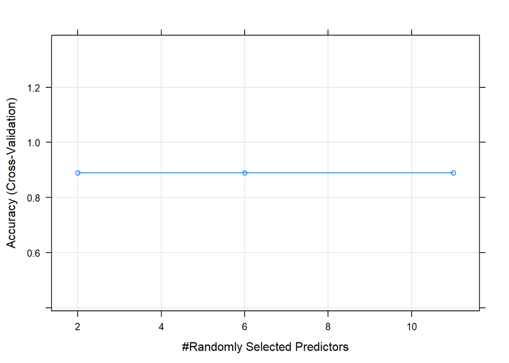

```r
plot(rfMod)
```

```r
predRF <- predict(rfMod, testingSet)

predDF <- data.frame(predRF, type=testingSet$ROI_Low_High)
predDF
```

```
##   predRF type
## 1   High High
## 2   High  Low
## 3   High  Low
## 4   High High
```

```r
sum <- sum(predRF==testingSet$ROI_Low_High)
length <- length(testingSet$ROI_Low_High)
accuracy_rfMod <- (sum/length)
accuracy_rfMod
```

```
## [1] 0.5
```

```r
results <- c(round(accuracy_rfMod,2), round(100,2))
results <- as.factor(results)
results <- t(data.frame(results))

colnames(results) <- colnames(predDF)
Results <- rbind(predDF, results)
Results
```

```
##         predRF type
## 1         High High
## 2         High  Low
## 3         High  Low
## 4         High High
## results    0.5  100
```

```r
knnMod <- train(ROI_Low_High ~ .,
                method='knn', preProcess=c('center','scale'),
                tuneLength=10, trControl=trainControl(method='cv'), data=trainingSet)
```

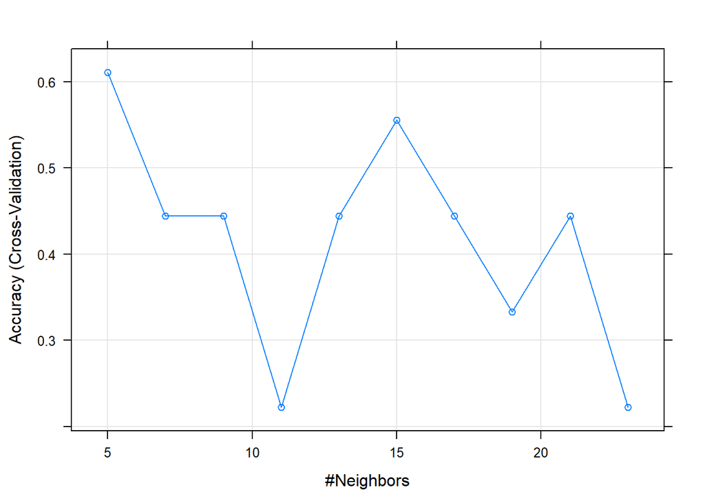

```r
plot(knnMod)
```

```r
rpartMod <- train(ROI_Low_High ~ ., method='rpart', tuneLength=7, data=trainingSet)
```

```r
glmMod <- train(ROI_Low_High ~ .,
                method='glm', data=trainingSet)
```

```r
predKNN <- predict(knnMod, testingSet)
predRPART <- predict(rpartMod, testingSet)
predGLM <- predict(glmMod, testingSet)
length=length(testingSet$ROI_Low_High)

sumKNN <- sum(predKNN==testingSet$ROI_Low_High)
sumRPart <- sum(predRPART==testingSet$ROI_Low_High)
sumGLM <- sum(predGLM==testingSet$ROI_Low_High)
```

```r
accuracy_KNN <- sumKNN/length
accuracy_RPART <- sumRPart/length
accuracy_GLM <- sumGLM/length
```

```r
predDF2 <- data.frame(predRF,predKNN,predRPART,predGLM,
                      TYPE=testingSet$ROI_Low_High)
colnames(predDF2) <- c('RandomForest','KNN','Rpart','GLM','TrueValue')

results <- c(round(accuracy_rfMod,2),
             round(accuracy_KNN,2),
             round(accuracy_RPART,2),
             round(accuracy_GLM,2),
             round(100,2))

results <- as.factor(results)
results <- t(data.frame(results))
colnames(results) <- c('RandomForest','KNN','Rpart','GLM','TrueValue')
Results <- rbind(predDF2, results)
Results
```

```
##         RandomForest  KNN Rpart  GLM TrueValue
## 1               High High  High High      High
## 2               High  Low  High High       Low
## 3               High High  High High       Low
## 4               High  Low  High  Low      High
## results          0.5  0.5   0.5 0.25       100
```

The above algorithms of machine learning using the default settings didn’t give very accurate predictions. There were only 13 samples to train on, and 4 to test on and the data fluctuates. There are just as many features as samples in the training set and more so in the testing set. What if we remove some of the features? Lets do this and remove the first five features.

```r
set.seed(12356789)

ROI_17b <- ROI_17[,-c(1:5)]
inTrain <- createDataPartition(y=ROI_17b$ROI_Low_High, p=0.7, list=FALSE)

trainingSet <- ROI_17b[inTrain,]
testingSet <- ROI_17b[-inTrain,]
```

```r
rfMod <- train(ROI_Low_High~., method='rf', data=(trainingSet),
               trControl=trainControl(method='cv'), number=5)
```

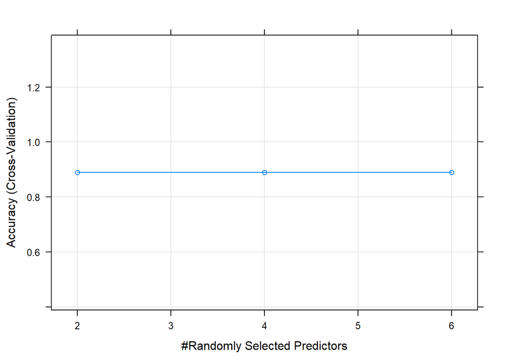

```r
plot(rfMod)
```

```r
predRF <- predict(rfMod, testingSet)

predDF <- data.frame(predRF, type=testingSet$ROI_Low_High)
predDF
```

```
##   predRF type
## 1   High High
## 2    Low  Low
## 3   High  Low
## 4    Low High
```

```r
sum <- sum(predRF==testingSet$ROI_Low_High)
length <- length(testingSet$ROI_Low_High)
accuracy_rfMod <- (sum/length)
accuracy_rfMod
```

```
## [1] 0.5
```

```r
results <- c(round(accuracy_rfMod,2), round(100,2))
results <- as.factor(results)
results <- t(data.frame(results))

colnames(results) <- colnames(predDF)
Results <- rbind(predDF, results)
Results
```

```
##         predRF type
## 1         High High
## 2          Low  Low
## 3         High  Low
## 4          Low High
## results    0.5  100
```

```r
knnMod <- train(ROI_Low_High ~ .,
                method='knn', preProcess=c('center','scale'),
                tuneLength=10, trControl=trainControl(method='cv'), data=trainingSet)
```

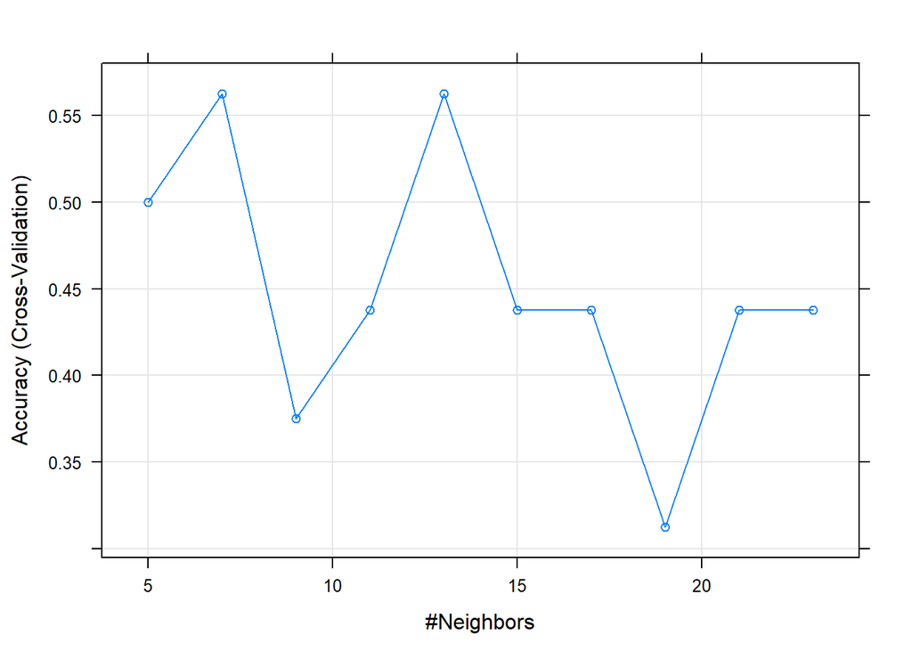

```r
plot(knnMod)
```

```r
rpartMod <- train(ROI_Low_High ~ ., method='rpart', tuneLength=7, data=trainingSet)
```

```r
glmMod <- train(ROI_Low_High ~ .,
                method='glm', data=trainingSet)
```

```r
predKNN <- predict(knnMod, testingSet)
predRPART <- predict(rpartMod, testingSet)
predGLM <- predict(glmMod, testingSet)
```

```r
length=length(testingSet$ROI_Low_High)

sumKNN <- sum(predKNN==testingSet$ROI_Low_High)
sumRPart <- sum(predRPART==testingSet$ROI_Low_High)
sumGLM <- sum(predGLM==testingSet$ROI_Low_High)
```

```r
accuracy_KNN <- sumKNN/length
accuracy_RPART <- sumRPart/length
accuracy_GLM <- sumGLM/length
```

```r
predDF2 <- data.frame(predRF,predKNN,predRPART,predGLM,
                      TYPE=testingSet$ROI_Low_High)
colnames(predDF2) <- c('RandomForest','KNN','Rpart','GLM','TrueValue')

results <- c(round(accuracy_rfMod,2),
             round(accuracy_KNN,2),
             round(accuracy_RPART,2),
             round(accuracy_GLM,2),
             round(100,2))

results <- as.factor(results)
results <- t(data.frame(results))
colnames(results) <- c('RandomForest','KNN','Rpart','GLM','TrueValue')
Results <- rbind(predDF2, results)
Results
```

```
##         RandomForest  KNN Rpart  GLM TrueValue
## 1               High High  High High      High
## 2                Low High  High  Low       Low
## 3               High High  High  Low       Low
## 4                Low High  High High      High
## results          0.5  0.5   0.5    1       100
```

The feature removal was better in accuracy than the original data. Based on the number of times the ratio of today’s stock values by date to the value seven days ago as increasing, decreasing, the added statistics of max, median, and 3rd quantile all added more information and got rid of noise so that there was one model that scored 100% accuracy and the others only got half right. In the other set, with the average stock values, DOW ROI, and start and final values for the time span 2007-2020, there was one that scored 1/4 and the others got half right. In this case, the GLM or generalized linear model based on linear and logistic regression performed better than the others and got all predictions of the four samples right.

This could mean having these statistics is powerful in predicting the value of the stock as high or low, or that the GLM notices that there is information in the statistical lag information that was used to classify the stock as a high or low return, or both.

These questions can be answered if making an app where a person asks what stock to predict, the app pulls the data from the internet, for the specified time. The app then gathers the seven day lag information of the stock, gets the fold change of the daily stock values of the stock to the seven day lag, counts the number of times the stock has cumulative days of increasing and decreasing, gets the median value of that range, compares the number of days the stock was increasing last, compared with the last few days ratios to indicate what the set of increase or decrease count is, then returns whether to buy or sell, based on whether the set of days is reaching the median value of days(or 3rd quartile and/or beyond the previous max cumulative days increasing/decreasing) that increase or decrease for a short run profit, figuratively.

A way to see of Naive Bayes, a GLM model, algorithm to calculate the probabilities of the stock continuing to increase or decrease based on the previous days increase, possibly the day of the month, quarter of the year, and so on, that could return the best probability for continuing to decrease, or continuing to increase. The features would again have to be limited for the best results, but there could be algorithms for all of these questions inside a stock forecast app.

What remains is to add in the other 36 stock lag information and test this same series of machine learning default setting algorithms on that data to see if results improve. And do this for all the lag information of the 30-60-90-120-150-180 lags. Bunch more coding but the methods are above, with time consuming find and replace carefully done.

To test how well this works for any given quarter year, month, year, etc., these same steps would have to be done to smaller subsets. ***

Lets start by making a list of those stocks we already have lag values for.

```r
colnames(Close53)
```

```
##  [1] "TGT"   "FTR"   "UBSI"  "HD"    "JPM"   "XOM"   "CVX"   "NSANY" "MGM"
## [10] "TEVA"  "HST"   "WFC"   "WWE"   "INO"   "SCE"   "FFIN"  "GOOG"  "WM"
## [19] "ONCY"  "S"     "F"     "ARWR"  "COST"  "AAL"   "JWN"   "NUS"   "ADDYY"
## [28] "KSS"   "MSFT"  "LUV"   "HMC"   "PCG"   "DLTR"  "KGJI"  "NKE"   "AMZN"
## [37] "ROST"  "WMT"   "TJX"   "TM"    "T"     "JNJ"   "C"     "EPD"   "VZ"
## [46] "HRB"   "NFLX"  "AAP"   "HOFT"  "SIG"   "RRGB"  "M"     "JBLU"  "Date"
```

```r
row.names(dROI17_lag7_d)
```

```
##  [1] "AAP"   "ADDYY" "AMZN"  "COST"  "DLTR"  "FFIN"  "GOOG"  "HD"    "JNJ"
## [10] "NFLX"  "NKE"   "PCG"   "ROST"  "TEVA"  "TJX"   "WMT"   "XOM"
```

The remaining stocks we need to add lagfields to, and then get the lag7 information for each stock as we did above on our machine learning data set of the 17 stocks in the best performing portfolio of stocks that had positive median daily value changes when the DOW was down and unemployment was up from the previous month.

```r
remaining <- colnames(Close53)[c(1:3,5,7:9,11:15,18:22,24:26,28:31,34,40,41,43:46,49:53)]
remaining
```

```
##  [1] "TGT"   "FTR"   "UBSI"  "JPM"   "CVX"   "NSANY" "MGM"   "HST"   "WFC"
## [10] "WWE"   "INO"   "SCE"   "WM"    "ONCY"  "S"     "F"     "ARWR"  "AAL"
## [19] "JWN"   "NUS"   "KSS"   "MSFT"  "LUV"   "HMC"   "KGJI"  "TM"    "T"
## [28] "C"     "EPD"   "VZ"    "HRB"   "HOFT"  "SIG"   "RRGB"  "M"     "JBLU"
```

```r
#this is the list of stocks that we need, and we need to drop the 17 we already analyzed
Remaining <- as.data.frame(remaining)
colnames(Remaining) <- 'stockName'

#make all the stock name columns one field of stock names
df36 <- gather(Close53, 'stockName','stockDayValue',1:53)

#merge the names of the remaining stock and the total stocks to keep only the ones needed
DF_36 <- merge(Remaining,df36, by.x='stockName', by.y='stockName')

#spread out the stock names into columns after getting only the stocks needed for adding stats
#from the 53 total, and 17 completed.
remaining36 <- spread(DF_36,'stockName','stockDayValue')

#order by date
remaining36 <- remaining36[order(remaining36$Date),]
```

```r
write.csv(remaining36,'remaining36.csv', row.names=FALSE)
```

Add the 7 day lag then add the ratio of each day’s stock value to the lag. Then get the counts of cumulative days the ratio increased and decreased. Then add the max, median, and 3rd quantile stats of those cumulative day counts for increased and decreased.

```r
remaining36_g <- gather(remaining36, 'stockName','stockDayValue',2:37)
```

```r
remaining36_g <- remaining36_g[with(remaining36_g, order(stockName, Date)),]

Laal <- subset(remaining36_g, remaining36_g$stockName=='AAL')
Larwr <- subset(remaining36_g, remaining36_g$stockName=='ARWR')
Lc <- subset(remaining36_g, remaining36_g$stockName=='C')
Lcvx <- subset(remaining36_g, remaining36_g$stockName=='CVX')
Lepd <- subset(remaining36_g, remaining36_g$stockName=='EPD')
Lf <- subset(remaining36_g, remaining36_g$stockName=='F')
Lftr <- subset(remaining36_g, remaining36_g$stockName=='FTR')
Lhmc <- subset(remaining36_g, remaining36_g$stockName=='HMC')
Lhoft <- subset(remaining36_g, remaining36_g$stockName=='HOFT')
Lhrb <- subset(remaining36_g, remaining36_g$stockName=='HRB')
Lhst <- subset(remaining36_g, remaining36_g$stockName=='HST')
Lino <- subset(remaining36_g, remaining36_g$stockName=='INO')
Ljblu <- subset(remaining36_g, remaining36_g$stockName=='JBLU')
Ljpm <- subset(remaining36_g, remaining36_g$stockName=='JPM')
Ljwn <- subset(remaining36_g, remaining36_g$stockName=='JWN')
Lkgji <- subset(remaining36_g, remaining36_g$stockName=='KGJI')
Lkss <- subset(remaining36_g, remaining36_g$stockName=='KSS')
Lluv <- subset(remaining36_g, remaining36_g$stockName=='LUV')
Lm <- subset(remaining36_g, remaining36_g$stockName=='M')
Lmgm <- subset(remaining36_g, remaining36_g$stockName=='MGM')
Lmsft <- subset(remaining36_g, remaining36_g$stockName=='MSFT')
Lnsany <- subset(remaining36_g, remaining36_g$stockName=='NSANY')
Lnus <- subset(remaining36_g, remaining36_g$stockName=='NUS')
Loncy <- subset(remaining36_g, remaining36_g$stockName=='ONCY')
Lrrgb <- subset(remaining36_g, remaining36_g$stockName=='RRGB')
Ls <- subset(remaining36_g, remaining36_g$stockName=='S')
Lsce <- subset(remaining36_g, remaining36_g$stockName=='SCE')
Lsig <- subset(remaining36_g, remaining36_g$stockName=='SIG')
Lt <- subset(remaining36_g, remaining36_g$stockName=='T')
Ltgt <- subset(remaining36_g, remaining36_g$stockName=='TGT')
Ltm <- subset(remaining36_g, remaining36_g$stockName=='TM')
Lubsi <- subset(remaining36_g, remaining36_g$stockName=='UBSI')
Lvz <- subset(remaining36_g, remaining36_g$stockName=='VZ')
Lwfc <- subset(remaining36_g, remaining36_g$stockName=='WFC')
Lwm <- subset(remaining36_g, remaining36_g$stockName=='WM')
Lwwe <- subset(remaining36_g, remaining36_g$stockName=='WWE')

aalL7 <- lag(Laal$stockDayValue,7)
arwrL7 <- lag(Larwr$stockDayValue,7)
cL7 <- lag(Lc$stockDayValue,7)
cvxL7 <- lag(Lcvx$stockDayValue,7)
epdL7 <- lag(Lepd$stockDayValue,7)
fL7 <- lag(Lf$stockDayValue,7)
ftrL7 <- lag(Lftr$stockDayValue,7)
hmcL7 <- lag(Lhmc$stockDayValue,7)
hoftL7 <- lag(Lhoft$stockDayValue,7)
hrbL7 <- lag(Lhrb$stockDayValue,7)
hstL7 <- lag(Lhst$stockDayValue,7)
inoL7 <- lag(Lino$stockDayValue,7)
jbluL7 <- lag(Ljblu$stockDayValue,7)
jpmL7 <- lag(Ljpm$stockDayValue,7)
jwnL7 <- lag(Ljwn$stockDayValue,7)
kgjiL7 <- lag(Lkgji$stockDayValue,7)
kssL7 <- lag(Lkss$stockDayValue,7)
luvL7 <- lag(Lluv$stockDayValue,7)
mL7 <- lag(Lm$stockDayValue,7)
mgmL7 <- lag(Lmgm$stockDayValue,7)
msftL7 <- lag(Lmsft$stockDayValue,7)
nsanyL7 <- lag(Lnsany$stockDayValue,7)
nusL7 <- lag(Lnus$stockDayValue,7)
oncyL7 <- lag(Loncy$stockDayValue,7)
rrgbL7 <- lag(Lrrgb$stockDayValue,7)
sL7 <- lag(Ls$stockDayValue,7)
sceL7 <- lag(Lsce$stockDayValue,7)
sigL7 <- lag(Lsig$stockDayValue,7)
tL7 <- lag(Lt$stockDayValue,7)
tgtL7 <- lag(Ltgt$stockDayValue,7)
tmL7 <- lag(Ltm$stockDayValue,7)
ubsiL7 <- lag(Lubsi$stockDayValue,7)
vzL7 <- lag(Lvz$stockDayValue,7)
wfcL7 <- lag(Lwfc$stockDayValue,7)
wmL7 <- lag(Lwm$stockDayValue,7)
wweL7 <- lag(Lwwe$stockDayValue,7)

remaining36_g$lag7 <- c(aalL7,arwrL7,cL7,cvxL7,epdL7,fL7,ftrL7,
                                  hmcL7,hoftL7,hrbL7,hstL7,inoL7,jbluL7,jpmL7,
                                  jwnL7,kgjiL7,kssL7,luvL7,mL7,mgmL7,msftL7,nsanyL7,nusL7,oncyL7,
                                  rrgbL7,sL7,sceL7,sigL7,tL7,tgtL7,tmL7,
                                  ubsiL7,vzL7,wfcL7,wmL7,wweL7)
#the dataset is ordered by stock then by date, so this works with matching,
#NAs are present when no data in dataset before that date, and the today2lag7
#will also have NAs in those instances
remaining36_g$today2lag7 <- remaining36_g$lag7/remaining36_g$stockDayValue
```

```r
AAL <- subset(remaining36_g, remaining36_g$stockName=='AAL')

AAL <- AAL[complete.cases(AAL),]

aal7_a <- ifelse(AAL$today2lag7>1, 1,0)

# get cumulative sum of the number of times today's stock increased from 7 days ago,
# the day will be repeated if it didn't increase. For example '10' is repeated 21 times, this
# counts the number of times the value decreased when setting the variable in the previous
# code block for aal7 <- <- ifelse(AAL$today2lag7>1, 1,0)
aal7_ab <- cumsum(aal7_a)

aal7_abc <- as.data.frame(as.factor(aal7_ab))
colnames(aal7_abc) <- 'cSum'

# get the count of how many instances or days there are, the more counts, the more
# days that were decreasing stock values for today's value to 7 days prior value.
countAAL <- aal7_abc %>% group_by(cSum) %>% count(n=n())
countAAL <- as.data.frame(countAAL)
countAAL <- countAAL[,-3]

# remove this additional day, so that the number of days in a row decreasing is measured
countAAL$aal7_decr_Days <- countAAL$n-1
countAAL <- countAAL[,-2]

#this is a set of only those days decreasing at least one day in the lag 7 comparison
countAAL2 <- subset(countAAL, countAAL$aal7_decr_Days>0)
summary(countAAL2$aal7_decr_Days)
```

```
##    Min. 1st Qu.  Median    Mean 3rd Qu.    Max.
##   1.000   1.000   4.000   6.622  10.000  32.000
```

```r
# this table shows how many sets of cumulative days decreasing there were in lag 7
aal7_decr_Days_grouped <- countAAL2 %>% group_by(aal7_decr_Days) %>% count(n=n())
aal7_decr_Days_grouped <- aal7_decr_Days_grouped[,-3]
```

```r
aal7_decr_Days_grouped
```

```
## # A tibble: 28 x 2
## # Groups:   aal7_decr_Days [28]
##    aal7_decr_Days     n
##             <dbl> <int>
##  1              1    71
##  2              2    28
##  3              3    20
##  4              4    12
##  5              5     9
##  6              6     8
##  7              7    21
##  8              8     9
##  9              9     9
## 10             10     8
## # … with 18 more rows
```

```r
median(aal7_decr_Days_grouped$aal7_decr_Days)
```

```
## [1] 14.5
```

```r
#assign a 1 to decreasing values
aal7_b1 <- ifelse(AAL$today2lag7>1, 0,1)


aal7_b2 <- cumsum(aal7_b1)

aal7_b3 <- as.data.frame(as.factor(aal7_b2))
colnames(aal7_b3) <- 'cSum'

countAAL1 <- aal7_b3 %>% group_by(cSum) %>% count(n=n())
countAAL1 <- as.data.frame(countAAL1)
countAAL1 <- countAAL1[,-3]

countAAL1$aal7_incr_Days <- countAAL1$n-1
countAAL1 <- countAAL1[,-2]

countAAL3 <- subset(countAAL1, countAAL1$aal7_incr_Days>0)
summary(countAAL3$aal7_incr_Days)
```

```
##    Min. 1st Qu.  Median    Mean 3rd Qu.    Max.
##   1.000   2.000   5.000   6.375   9.000  30.000
```

```r
aal7_incr_Days_grouped <- countAAL3 %>% group_by(aal7_incr_Days) %>% count(n=n())
aal7_incr_Days_grouped <- aal7_incr_Days_grouped[,-3]
```

```r
aal7_incr_Days_grouped
```

```
## # A tibble: 23 x 2
## # Groups:   aal7_incr_Days [23]
##    aal7_incr_Days     n
##             <dbl> <int>
##  1              1    62
##  2              2    31
##  3              3    23
##  4              4     7
##  5              5    13
##  6              6     7
##  7              7    25
##  8              8    12
##  9              9    14
## 10             10    14
## # … with 13 more rows
```

```r
median(aal7_incr_Days_grouped$aal7_incr_Days)
```

```
## [1] 12
```

```r
ARWR <- subset(remaining36_g, remaining36_g$stockName=='ARWR')

ARWR <- ARWR[complete.cases(ARWR),]

arwr7_a <- ifelse(ARWR$today2lag7>1, 1,0)

# get cumulative sum of the number of times today's stock increased from 7 days ago,
# the day will be repeated if it didn't increase. For example '10' is repeated 21 times, this
# counts the number of times the value decreased when setting the variable in the previous
# code block for arwr7 <- <- ifelse(ARWR$today2lag7>1, 1,0)
arwr7_ab <- cumsum(arwr7_a)

arwr7_abc <- as.data.frame(as.factor(arwr7_ab))
colnames(arwr7_abc) <- 'cSum'

# get the count of how many instances or days there are, the more counts, the more
# days that were decreasing stock values for today's value to 7 days prior value.
countARWR <- arwr7_abc %>% group_by(cSum) %>% count(n=n())
countARWR <- as.data.frame(countARWR)
countARWR <- countARWR[,-3]

# remove this additional day, so that the number of days in a row decreasing is measured
countARWR$arwr7_decr_Days <- countARWR$n-1
countARWR <- countARWR[,-2]

#this is a set of only those days decreasing at least one day in the lag 7 comparison
countARWR2 <- subset(countARWR, countARWR$arwr7_decr_Days>0)
summary(countARWR2$arwr7_decr_Days)
```

```
##    Min. 1st Qu.  Median    Mean 3rd Qu.    Max.
##   1.000   1.000   4.000   5.974   8.000  33.000
```

```r
# this table shows how many sets of cumulative days decreasing there were in lag 7
arwr7_decr_Days_grouped <- countARWR2 %>% group_by(arwr7_decr_Days) %>% count(n=n())
arwr7_decr_Days_grouped <- arwr7_decr_Days_grouped[,-3]
```

```r
arwr7_decr_Days_grouped
```

```
## # A tibble: 24 x 2
## # Groups:   arwr7_decr_Days [24]
##    arwr7_decr_Days     n
##              <dbl> <int>
##  1               1    74
##  2               2    35
##  3               3    25
##  4               4    19
##  5               5     7
##  6               6    12
##  7               7    19
##  8               8    14
##  9               9    14
## 10              10     7
## # … with 14 more rows
```

```r
median(arwr7_decr_Days_grouped$arwr7_decr_Days)
```

```
## [1] 12.5
```

```r
#assign a 1 to decreasing values
arwr7_b1 <- ifelse(ARWR$today2lag7>1, 0,1)


arwr7_b2 <- cumsum(arwr7_b1)

arwr7_b3 <- as.data.frame(as.factor(arwr7_b2))
colnames(arwr7_b3) <- 'cSum'

countARWR1 <- arwr7_b3 %>% group_by(cSum) %>% count(n=n())
countARWR1 <- as.data.frame(countARWR1)
countARWR1 <- countARWR1[,-3]

countARWR1$arwr7_incr_Days <- countARWR1$n-1
countARWR1 <- countARWR1[,-2]

countARWR3 <- subset(countARWR1, countARWR1$arwr7_incr_Days>0)
summary(countARWR3$arwr7_incr_Days)
```

```
##    Min. 1st Qu.  Median    Mean 3rd Qu.    Max.
##   1.000   1.000   4.000   6.117   9.000  40.000
```

```r
arwr7_incr_Days_grouped <- countARWR3 %>% group_by(arwr7_incr_Days) %>% count(n=n())
arwr7_incr_Days_grouped <- arwr7_incr_Days_grouped[,-3]
```

```r
arwr7_incr_Days_grouped
```

```
## # A tibble: 24 x 2
## # Groups:   arwr7_incr_Days [24]
##    arwr7_incr_Days     n
##              <dbl> <int>
##  1               1    70
##  2               2    32
##  3               3    24
##  4               4    20
##  5               5    14
##  6               6     6
##  7               7    17
##  8               8    17
##  9               9    17
## 10              10     4
## # … with 14 more rows
```

```r
median(arwr7_incr_Days_grouped$arwr7_incr_Days)
```

```
## [1] 12.5
```

```r
C <- subset(remaining36_g, remaining36_g$stockName=='C')

C <- C[complete.cases(C),]

c7_a <- ifelse(C$today2lag7>1, 1,0)

# get cumulative sum of the number of times today's stock increased from 7 days ago,
# the day will be repeated if it didn't increase. For example '10' is repeated 21 times, this
# counts the number of times the value decreased when setting the variable in the previous
# code block for c7 <- <- ifelse(C$today2lag7>1, 1,0)
c7_ab <- cumsum(c7_a)

c7_abc <- as.data.frame(as.factor(c7_ab))
colnames(c7_abc) <- 'cSum'

# get the count of how many instances or days there are, the more counts, the more
# days that were decreasing stock values for today's value to 7 days prior value.
countC <- c7_abc %>% group_by(cSum) %>% count(n=n())
countC <- as.data.frame(countC)
countC <- countC[,-3]

# remove this additional day, so that the number of days in a row decreasing is measured
countC$c7_decr_Days <- countC$n-1
countC <- countC[,-2]

#this is a set of only those days decreasing at least one day in the lag 7 comparison
countC2 <- subset(countC, countC$c7_decr_Days>0)
summary(countC2$c7_decr_Days)
```

```
##    Min. 1st Qu.  Median    Mean 3rd Qu.    Max.
##   1.000   1.000   4.000   5.916   8.000  26.000
```

```r
# this table shows how many sets of cumulative days decreasing there were in lag 7
c7_decr_Days_grouped <- countC2 %>% group_by(c7_decr_Days) %>% count(n=n())
c7_decr_Days_grouped <- c7_decr_Days_grouped[,-3]
```

```r
c7_decr_Days_grouped
```

```
## # A tibble: 24 x 2
## # Groups:   c7_decr_Days [24]
##    c7_decr_Days     n
##           <dbl> <int>
##  1            1    87
##  2            2    28
##  3            3    15
##  4            4    19
##  5            5    12
##  6            6    11
##  7            7    25
##  8            8    17
##  9            9    11
## 10           10     5
## # … with 14 more rows
```

```r
median(c7_decr_Days_grouped$c7_decr_Days)
```

```
## [1] 12.5
```

```r
#assign a 1 to decreasing values
c7_b1 <- ifelse(C$today2lag7>1, 0,1)


c7_b2 <- cumsum(c7_b1)

c7_b3 <- as.data.frame(as.factor(c7_b2))
colnames(c7_b3) <- 'cSum'

countC1 <- c7_b3 %>% group_by(cSum) %>% count(n=n())
countC1 <- as.data.frame(countC1)
countC1 <- countC1[,-3]

countC1$c7_incr_Days <- countC1$n-1
countC1 <- countC1[,-2]

countC3 <- subset(countC1, countC1$c7_incr_Days>0)
summary(countC3$c7_incr_Days)
```

```
##    Min. 1st Qu.  Median    Mean 3rd Qu.    Max.
##   1.000   1.000   4.000   5.626   8.000  27.000
```

```r
c7_incr_Days_grouped <- countC3 %>% group_by(c7_incr_Days) %>% count(n=n())
c7_incr_Days_grouped <- c7_incr_Days_grouped[,-3]
```

```r
c7_incr_Days_grouped
```

```
## # A tibble: 23 x 2
## # Groups:   c7_incr_Days [23]
##    c7_incr_Days     n
##           <dbl> <int>
##  1            1    88
##  2            2    36
##  3            3    18
##  4            4    21
##  5            5    10
##  6            6     8
##  7            7    29
##  8            8    13
##  9            9     8
## 10           10     7
## # … with 13 more rows
```

```r
median(c7_incr_Days_grouped$c7_incr_Days)
```

```
## [1] 12
```

```r
CVX <- subset(remaining36_g, remaining36_g$stockName=='CVX')

CVX <- CVX[complete.cases(CVX),]

cvx7_a <- ifelse(CVX$today2lag7>1, 1,0)

# get cumulative sum of the number of times today's stock increased from 7 days ago,
# the day will be repeated if it didn't increase. For example '10' is repeated 21 times, this
# counts the number of times the value decreased when setting the variable in the previous
# code block for cvx7 <- <- ifelse(CVX$today2lag7>1, 1,0)
cvx7_ab <- cumsum(cvx7_a)

cvx7_abc <- as.data.frame(as.factor(cvx7_ab))
colnames(cvx7_abc) <- 'cSum'

# get the count of how many instances or days there are, the more counts, the more
# days that were decreasing stock values for today's value to 7 days prior value.
countCVX <- cvx7_abc %>% group_by(cSum) %>% count(n=n())
countCVX <- as.data.frame(countCVX)
countCVX <- countCVX[,-3]

# remove this additional day, so that the number of days in a row decreasing is measured
countCVX$cvx7_decr_Days <- countCVX$n-1
countCVX <- countCVX[,-2]

#this is a set of only those days decreasing at least one day in the lag 7 comparison
countCVX2 <- subset(countCVX, countCVX$cvx7_decr_Days>0)
summary(countCVX2$cvx7_decr_Days)
```

```
##    Min. 1st Qu.  Median    Mean 3rd Qu.    Max.
##   1.000   1.000   3.000   5.867   8.000  42.000
```

```r
# this table shows how many sets of cumulative days decreasing there were in lag 7
cvx7_decr_Days_grouped <- countCVX2 %>% group_by(cvx7_decr_Days) %>% count(n=n())
cvx7_decr_Days_grouped <- cvx7_decr_Days_grouped[,-3]
```

```r
cvx7_decr_Days_grouped
```

```
## # A tibble: 27 x 2
## # Groups:   cvx7_decr_Days [27]
##    cvx7_decr_Days     n
##             <dbl> <int>
##  1              1   100
##  2              2    36
##  3              3    23
##  4              4    17
##  5              5    10
##  6              6    12
##  7              7    17
##  8              8    17
##  9              9     7
## 10             10     9
## # … with 17 more rows
```

```r
median(cvx7_decr_Days_grouped$cvx7_decr_Days)
```

```
## [1] 14
```

```r
#assign a 1 to decreasing values
cvx7_b1 <- ifelse(CVX$today2lag7>1, 0,1)


cvx7_b2 <- cumsum(cvx7_b1)

cvx7_b3 <- as.data.frame(as.factor(cvx7_b2))
colnames(cvx7_b3) <- 'cSum'

countCVX1 <- cvx7_b3 %>% group_by(cSum) %>% count(n=n())
countCVX1 <- as.data.frame(countCVX1)
countCVX1 <- countCVX1[,-3]

countCVX1$cvx7_incr_Days <- countCVX1$n-1
countCVX1 <- countCVX1[,-2]

countCVX3 <- subset(countCVX1, countCVX1$cvx7_incr_Days>0)
summary(countCVX3$cvx7_incr_Days)
```

```
##    Min. 1st Qu.  Median    Mean 3rd Qu.    Max.
##   1.000   1.000   3.000   5.063   8.000  25.000
```

```r
cvx7_incr_Days_grouped <- countCVX3 %>% group_by(cvx7_incr_Days) %>% count(n=n())
cvx7_incr_Days_grouped <- cvx7_incr_Days_grouped[,-3]
```

```r
cvx7_incr_Days_grouped
```

```
## # A tibble: 23 x 2
## # Groups:   cvx7_incr_Days [23]
##    cvx7_incr_Days     n
##             <dbl> <int>
##  1              1   101
##  2              2    43
##  3              3    25
##  4              4    18
##  5              5    10
##  6              6     7
##  7              7    17
##  8              8    12
##  9              9    17
## 10             10    10
## # … with 13 more rows
```

```r
median(cvx7_incr_Days_grouped$cvx7_incr_Days)
```

```
## [1] 12
```

```r
EPD <- subset(remaining36_g, remaining36_g$stockName=='EPD')

EPD <- EPD[complete.cases(EPD),]

epd7_a <- ifelse(EPD$today2lag7>1, 1,0)

# get cumulative sum of the number of times today's stock increased from 7 days ago,
# the day will be repeated if it didn't increase. For example '10' is repeated 21 times, this
# counts the number of times the value decreased when setting the variable in the previous
# code block for epd7 <- <- ifelse(EPD$today2lag7>1, 1,0)
epd7_ab <- cumsum(epd7_a)

epd7_abc <- as.data.frame(as.factor(epd7_ab))
colnames(epd7_abc) <- 'cSum'

# get the count of how many instances or days there are, the more counts, the more
# days that were decreasing stock values for today's value to 7 days prior value.
countEPD <- epd7_abc %>% group_by(cSum) %>% count(n=n())
countEPD <- as.data.frame(countEPD)
countEPD <- countEPD[,-3]

# remove this additional day, so that the number of days in a row decreasing is measured
countEPD$epd7_decr_Days <- countEPD$n-1
countEPD <- countEPD[,-2]

#this is a set of only those days decreasing at least one day in the lag 7 comparison
countEPD2 <- subset(countEPD, countEPD$epd7_decr_Days>0)
summary(countEPD2$epd7_decr_Days)
```

```
##    Min. 1st Qu.  Median    Mean 3rd Qu.    Max.
##     1.0     1.0     5.0     6.2     8.0    42.0
```

```r
# this table shows how many sets of cumulative days decreasing there were in lag 7
epd7_decr_Days_grouped <- countEPD2 %>% group_by(epd7_decr_Days) %>% count(n=n())
epd7_decr_Days_grouped <- epd7_decr_Days_grouped[,-3]
```

```r
epd7_decr_Days_grouped
```

```
## # A tibble: 27 x 2
## # Groups:   epd7_decr_Days [27]
##    epd7_decr_Days     n
##             <dbl> <int>
##  1              1    79
##  2              2    29
##  3              3    20
##  4              4    13
##  5              5    16
##  6              6    18
##  7              7    24
##  8              8    15
##  9              9    10
## 10             10    15
## # … with 17 more rows
```

```r
median(epd7_decr_Days_grouped$epd7_decr_Days)
```

```
## [1] 14
```

```r
#assign a 1 to decreasing values
epd7_b1 <- ifelse(EPD$today2lag7>1, 0,1)


epd7_b2 <- cumsum(epd7_b1)

epd7_b3 <- as.data.frame(as.factor(epd7_b2))
colnames(epd7_b3) <- 'cSum'

countEPD1 <- epd7_b3 %>% group_by(cSum) %>% count(n=n())
countEPD1 <- as.data.frame(countEPD1)
countEPD1 <- countEPD1[,-3]

countEPD1$epd7_incr_Days <- countEPD1$n-1
countEPD1 <- countEPD1[,-2]

countEPD3 <- subset(countEPD1, countEPD1$epd7_incr_Days>0)
summary(countEPD3$epd7_incr_Days)
```

```
##    Min. 1st Qu.  Median    Mean 3rd Qu.    Max.
##   1.000   1.000   4.000   5.361   8.000  26.000
```

```r
epd7_incr_Days_grouped <- countEPD3 %>% group_by(epd7_incr_Days) %>% count(n=n())
epd7_incr_Days_grouped <- epd7_incr_Days_grouped[,-3]
```

```r
epd7_incr_Days_grouped
```

```
## # A tibble: 22 x 2
## # Groups:   epd7_incr_Days [22]
##    epd7_incr_Days     n
##             <dbl> <int>
##  1              1    86
##  2              2    42
##  3              3    13
##  4              4    15
##  5              5    20
##  6              6    14
##  7              7    21
##  8              8    11
##  9              9    14
## 10             10     5
## # … with 12 more rows
```

```r
median(epd7_incr_Days_grouped$epd7_incr_Days)
```

```
## [1] 11.5
```

```r
F <- subset(remaining36_g, remaining36_g$stockName=='F')

F <- F[complete.cases(F),]

f7_a <- ifelse(F$today2lag7>1, 1,0)

# get cumulative sum of the number of times today's stock increased from 7 days ago,
# the day will be repeated if it didn't increase. For example '10' is repeated 21 times, this
# counts the number of times the value decreased when setting the variable in the previous
# code block for f7 <- <- ifelse(F$today2lag7>1, 1,0)
f7_ab <- cumsum(f7_a)

f7_abc <- as.data.frame(as.factor(f7_ab))
colnames(f7_abc) <- 'cSum'

# get the count of how many instances or days there are, the more counts, the more
# days that were decreasing stock values for today's value to 7 days prior value.
countF <- f7_abc %>% group_by(cSum) %>% count(n=n())
countF <- as.data.frame(countF)
countF <- countF[,-3]

# remove this additional day, so that the number of days in a row decreasing is measured
countF$f7_decr_Days <- countF$n-1
countF <- countF[,-2]

#this is a set of only those days decreasing at least one day in the lag 7 comparison
countF2 <- subset(countF, countF$f7_decr_Days>0)
summary(countF2$f7_decr_Days)
```

```
##    Min. 1st Qu.  Median    Mean 3rd Qu.    Max.
##   1.000   1.000   4.000   6.139   9.000  33.000
```

```r
# this table shows how many sets of cumulative days decreasing there were in lag 7
f7_decr_Days_grouped <- countF2 %>% group_by(f7_decr_Days) %>% count(n=n())
f7_decr_Days_grouped <- f7_decr_Days_grouped[,-3]
```

```r
f7_decr_Days_grouped
```

```
## # A tibble: 26 x 2
## # Groups:   f7_decr_Days [26]
##    f7_decr_Days     n
##           <dbl> <int>
##  1            1    73
##  2            2    39
##  3            3    17
##  4            4    15
##  5            5    13
##  6            6     8
##  7            7    21
##  8            8    10
##  9            9    12
## 10           10     8
## # … with 16 more rows
```

```r
median(f7_decr_Days_grouped$f7_decr_Days)
```

```
## [1] 13.5
```

```r
#assign a 1 to decreasing values
f7_b1 <- ifelse(F$today2lag7>1, 0,1)


f7_b2 <- cumsum(f7_b1)

f7_b3 <- as.data.frame(as.factor(f7_b2))
colnames(f7_b3) <- 'cSum'

countF1 <- f7_b3 %>% group_by(cSum) %>% count(n=n())
countF1 <- as.data.frame(countF1)
countF1 <- countF1[,-3]

countF1$f7_incr_Days <- countF1$n-1
countF1 <- countF1[,-2]

countF3 <- subset(countF1, countF1$f7_incr_Days>0)
summary(countF3$f7_incr_Days)
```

```
##    Min. 1st Qu.  Median    Mean 3rd Qu.    Max.
##   1.000   1.500   5.000   6.202   9.000  32.000
```

```r
f7_incr_Days_grouped <- countF3 %>% group_by(f7_incr_Days) %>% count(n=n())
f7_incr_Days_grouped <- f7_incr_Days_grouped[,-3]
```

```r
f7_incr_Days_grouped
```

```
## # A tibble: 24 x 2
## # Groups:   f7_incr_Days [24]
##    f7_incr_Days     n
##           <dbl> <int>
##  1            1    67
##  2            2    27
##  3            3    18
##  4            4    13
##  5            5    13
##  6            6    10
##  7            7    25
##  8            8    21
##  9            9    14
## 10           10    10
## # … with 14 more rows
```

```r
median(f7_incr_Days_grouped$f7_incr_Days)
```

```
## [1] 12.5
```

```r
FTR <- subset(remaining36_g, remaining36_g$stockName=='FTR')

FTR <- FTR[complete.cases(FTR),]

ftr7_a <- ifelse(FTR$today2lag7>1, 1,0)

# get cumulative sum of the number of times today's stock increased from 7 days ago,
# the day will be repeated if it didn't increase. For example '10' is repeated 21 times, this
# counts the number of times the value decreased when setting the variable in the previous
# code block for ftr7 <- <- ifelse(FTR$today2lag7>1, 1,0)
ftr7_ab <- cumsum(ftr7_a)

ftr7_abc <- as.data.frame(as.factor(ftr7_ab))
colnames(ftr7_abc) <- 'cSum'

# get the count of how many instances or days there are, the more counts, the more
# days that were decreasing stock values for today's value to 7 days prior value.
countFTR <- ftr7_abc %>% group_by(cSum) %>% count(n=n())
countFTR <- as.data.frame(countFTR)
countFTR <- countFTR[,-3]

# remove this additional day, so that the number of days in a row decreasing is measured
countFTR$ftr7_decr_Days <- countFTR$n-1
countFTR <- countFTR[,-2]

#this is a set of only those days decreasing at least one day in the lag 7 comparison
countFTR2 <- subset(countFTR, countFTR$ftr7_decr_Days>0)
summary(countFTR2$ftr7_decr_Days)
```

```
##    Min. 1st Qu.  Median    Mean 3rd Qu.    Max.
##     1.0     1.0     4.0     5.4     8.0    28.0
```

```r
# this table shows how many sets of cumulative days decreasing there were in lag 7
ftr7_decr_Days_grouped <- countFTR2 %>% group_by(ftr7_decr_Days) %>% count(n=n())
ftr7_decr_Days_grouped <- ftr7_decr_Days_grouped[,-3]
```

```r
ftr7_decr_Days_grouped
```

```
## # A tibble: 22 x 2
## # Groups:   ftr7_decr_Days [22]
##    ftr7_decr_Days     n
##             <dbl> <int>
##  1              1    79
##  2              2    37
##  3              3    27
##  4              4    22
##  5              5    14
##  6              6     9
##  7              7    22
##  8              8    15
##  9              9    11
## 10             10    10
## # … with 12 more rows
```

```r
median(ftr7_decr_Days_grouped$ftr7_decr_Days)
```

```
## [1] 11.5
```

```r
#assign a 1 to decreasing values
ftr7_b1 <- ifelse(FTR$today2lag7>1, 0,1)


ftr7_b2 <- cumsum(ftr7_b1)

ftr7_b3 <- as.data.frame(as.factor(ftr7_b2))
colnames(ftr7_b3) <- 'cSum'

countFTR1 <- ftr7_b3 %>% group_by(cSum) %>% count(n=n())
countFTR1 <- as.data.frame(countFTR1)
countFTR1 <- countFTR1[,-3]

countFTR1$ftr7_incr_Days <- countFTR1$n-1
countFTR1 <- countFTR1[,-2]

countFTR3 <- subset(countFTR1, countFTR1$ftr7_incr_Days>0)
summary(countFTR3$ftr7_incr_Days)
```

```
##    Min. 1st Qu.  Median    Mean 3rd Qu.    Max.
##   1.000   1.000   4.000   5.983   9.000  25.000
```

```r
ftr7_incr_Days_grouped <- countFTR3 %>% group_by(ftr7_incr_Days) %>% count(n=n())
ftr7_incr_Days_grouped <- ftr7_incr_Days_grouped[,-3]
```

```r
ftr7_incr_Days_grouped
```

```
## # A tibble: 23 x 2
## # Groups:   ftr7_incr_Days [23]
##    ftr7_incr_Days     n
##             <dbl> <int>
##  1              1    82
##  2              2    42
##  3              3    18
##  4              4    11
##  5              5    13
##  6              6     7
##  7              7    15
##  8              8    14
##  9              9    19
## 10             10     9
## # … with 13 more rows
```

```r
median(ftr7_incr_Days_grouped$ftr7_incr_Days)
```

```
## [1] 12
```

```r
HMC <- subset(remaining36_g, remaining36_g$stockName=='HMC')

HMC <- HMC[complete.cases(HMC),]

hmc7_a <- ifelse(HMC$today2lag7>1, 1,0)

# get cumulative sum of the number of times today's stock increased from 7 days ago,
# the day will be repeated if it didn't increase. For example '10' is repeated 21 times, this
# counts the number of times the value decreased when setting the variable in the previous
# code block for hmc7 <- <- ifelse(HMC$today2lag7>1, 1,0)
hmc7_ab <- cumsum(hmc7_a)

hmc7_abc <- as.data.frame(as.factor(hmc7_ab))
colnames(hmc7_abc) <- 'cSum'

# get the count of how many instances or days there are, the more counts, the more
# days that were decreasing stock values for today's value to 7 days prior value.
countHMC <- hmc7_abc %>% group_by(cSum) %>% count(n=n())
countHMC <- as.data.frame(countHMC)
countHMC <- countHMC[,-3]

# remove this additional day, so that the number of days in a row decreasing is measured
countHMC$hmc7_decr_Days <- countHMC$n-1
countHMC <- countHMC[,-2]

#this is a set of only those days decreasing at least one day in the lag 7 comparison
countHMC2 <- subset(countHMC, countHMC$hmc7_decr_Days>0)
summary(countHMC2$hmc7_decr_Days)
```

```
##    Min. 1st Qu.  Median    Mean 3rd Qu.    Max.
##   1.000   1.000   4.000   5.819   8.000  37.000
```

```r
# this table shows how many sets of cumulative days decreasing there were in lag 7
hmc7_decr_Days_grouped <- countHMC2 %>% group_by(hmc7_decr_Days) %>% count(n=n())
hmc7_decr_Days_grouped <- hmc7_decr_Days_grouped[,-3]
```

```r
hmc7_decr_Days_grouped
```

```
## # A tibble: 26 x 2
## # Groups:   hmc7_decr_Days [26]
##    hmc7_decr_Days     n
##             <dbl> <int>
##  1              1    73
##  2              2    38
##  3              3    17
##  4              4    18
##  5              5    17
##  6              6    11
##  7              7    27
##  8              8    14
##  9              9    14
## 10             10    16
## # … with 16 more rows
```

```r
median(hmc7_decr_Days_grouped$hmc7_decr_Days)
```

```
## [1] 13.5
```

```r
#assign a 1 to decreasing values
hmc7_b1 <- ifelse(HMC$today2lag7>1, 0,1)


hmc7_b2 <- cumsum(hmc7_b1)

hmc7_b3 <- as.data.frame(as.factor(hmc7_b2))
colnames(hmc7_b3) <- 'cSum'

countHMC1 <- hmc7_b3 %>% group_by(cSum) %>% count(n=n())
countHMC1 <- as.data.frame(countHMC1)
countHMC1 <- countHMC1[,-3]

countHMC1$hmc7_incr_Days <- countHMC1$n-1
countHMC1 <- countHMC1[,-2]

countHMC3 <- subset(countHMC1, countHMC1$hmc7_incr_Days>0)
summary(countHMC3$hmc7_incr_Days)
```

```
##    Min. 1st Qu.  Median    Mean 3rd Qu.    Max.
##   1.000   1.000   4.000   5.865   8.750  31.000
```

```r
hmc7_incr_Days_grouped <- countHMC3 %>% group_by(hmc7_incr_Days) %>% count(n=n())
hmc7_incr_Days_grouped <- hmc7_incr_Days_grouped[,-3]
```

```r
hmc7_incr_Days_grouped
```

```
## # A tibble: 27 x 2
## # Groups:   hmc7_incr_Days [27]
##    hmc7_incr_Days     n
##             <dbl> <int>
##  1              1    86
##  2              2    28
##  3              3    25
##  4              4    16
##  5              5    10
##  6              6     7
##  7              7    27
##  8              8    12
##  9              9    11
## 10             10    11
## # … with 17 more rows
```

```r
median(hmc7_incr_Days_grouped$hmc7_incr_Days)
```

```
## [1] 14
```

```r
HOFT <- subset(remaining36_g, remaining36_g$stockName=='HOFT')

HOFT <- HOFT[complete.cases(HOFT),]

hoft7_a <- ifelse(HOFT$today2lag7>1, 1,0)

# get cumulative sum of the number of times today's stock increased from 7 days ago,
# the day will be repeated if it didn't increase. For example '10' is repeated 21 times, this
# counts the number of times the value decreased when setting the variable in the previous
# code block for hoft7 <- <- ifelse(HOFT$today2lag7>1, 1,0)
hoft7_ab <- cumsum(hoft7_a)

hoft7_abc <- as.data.frame(as.factor(hoft7_ab))
colnames(hoft7_abc) <- 'cSum'

# get the count of how many instances or days there are, the more counts, the more
# days that were decreasing stock values for today's value to 7 days prior value.
countHOFT <- hoft7_abc %>% group_by(cSum) %>% count(n=n())
countHOFT <- as.data.frame(countHOFT)
countHOFT <- countHOFT[,-3]

# remove this additional day, so that the number of days in a row decreasing is measured
countHOFT$hoft7_decr_Days <- countHOFT$n-1
countHOFT <- countHOFT[,-2]

#this is a set of only those days decreasing at least one day in the lag 7 comparison
countHOFT2 <- subset(countHOFT, countHOFT$hoft7_decr_Days>0)
summary(countHOFT2$hoft7_decr_Days)
```

```
##    Min. 1st Qu.  Median    Mean 3rd Qu.    Max.
##   1.000   1.000   3.000   5.408   8.000  33.000
```

```r
# this table shows how many sets of cumulative days decreasing there were in lag 7
hoft7_decr_Days_grouped <- countHOFT2 %>% group_by(hoft7_decr_Days) %>% count(n=n())
hoft7_decr_Days_grouped <- hoft7_decr_Days_grouped[,-3]
```

```r
hoft7_decr_Days_grouped
```

```
## # A tibble: 24 x 2
## # Groups:   hoft7_decr_Days [24]
##    hoft7_decr_Days     n
##              <dbl> <int>
##  1               1    93
##  2               2    55
##  3               3    20
##  4               4    21
##  5               5    13
##  6               6    12
##  7               7    24
##  8               8    16
##  9               9     9
## 10              10     9
## # … with 14 more rows
```

```r
median(hoft7_decr_Days_grouped$hoft7_decr_Days)
```

```
## [1] 12.5
```

```r
#assign a 1 to decreasing values
hoft7_b1 <- ifelse(HOFT$today2lag7>1, 0,1)


hoft7_b2 <- cumsum(hoft7_b1)

hoft7_b3 <- as.data.frame(as.factor(hoft7_b2))
colnames(hoft7_b3) <- 'cSum'

countHOFT1 <- hoft7_b3 %>% group_by(cSum) %>% count(n=n())
countHOFT1 <- as.data.frame(countHOFT1)
countHOFT1 <- countHOFT1[,-3]

countHOFT1$hoft7_incr_Days <- countHOFT1$n-1
countHOFT1 <- countHOFT1[,-2]

countHOFT3 <- subset(countHOFT1, countHOFT1$hoft7_incr_Days>0)
summary(countHOFT3$hoft7_incr_Days)
```

```
##    Min. 1st Qu.  Median    Mean 3rd Qu.    Max.
##   1.000   1.000   3.000   4.857   7.000  28.000
```

```r
hoft7_incr_Days_grouped <- countHOFT3 %>% group_by(hoft7_incr_Days) %>% count(n=n())
hoft7_incr_Days_grouped <- hoft7_incr_Days_grouped[,-3]
```

```r
hoft7_incr_Days_grouped
```

```
## # A tibble: 23 x 2
## # Groups:   hoft7_incr_Days [23]
##    hoft7_incr_Days     n
##              <dbl> <int>
##  1               1   106
##  2               2    41
##  3               3    25
##  4               4    22
##  5               5    14
##  6               6    11
##  7               7    31
##  8               8    12
##  9               9    14
## 10              10     9
## # … with 13 more rows
```

```r
median(hoft7_incr_Days_grouped$hoft7_incr_Days)
```

```
## [1] 12
```

```r
HRB <- subset(remaining36_g, remaining36_g$stockName=='HRB')

HRB <- HRB[complete.cases(HRB),]

hrb7_a <- ifelse(HRB$today2lag7>1, 1,0)

# get cumulative sum of the number of times today's stock increased from 7 days ago,
# the day will be repeated if it didn't increase. For example '10' is repeated 21 times, this
# counts the number of times the value decreased when setting the variable in the previous
# code block for hrb7 <- <- ifelse(HRB$today2lag7>1, 1,0)
hrb7_ab <- cumsum(hrb7_a)

hrb7_abc <- as.data.frame(as.factor(hrb7_ab))
colnames(hrb7_abc) <- 'cSum'

# get the count of how many instances or days there are, the more counts, the more
# days that were decreasing stock values for today's value to 7 days prior value.
countHRB <- hrb7_abc %>% group_by(cSum) %>% count(n=n())
countHRB <- as.data.frame(countHRB)
countHRB <- countHRB[,-3]

# remove this additional day, so that the number of days in a row decreasing is measured
countHRB$hrb7_decr_Days <- countHRB$n-1
countHRB <- countHRB[,-2]

#this is a set of only those days decreasing at least one day in the lag 7 comparison
countHRB2 <- subset(countHRB, countHRB$hrb7_decr_Days>0)
summary(countHRB2$hrb7_decr_Days)
```

```
##    Min. 1st Qu.  Median    Mean 3rd Qu.    Max.
##   1.000   1.000   3.000   6.052   8.000  39.000
```

```r
# this table shows how many sets of cumulative days decreasing there were in lag 7
hrb7_decr_Days_grouped <- countHRB2 %>% group_by(hrb7_decr_Days) %>% count(n=n())
hrb7_decr_Days_grouped <- hrb7_decr_Days_grouped[,-3]
```

```r
hrb7_decr_Days_grouped
```

```
## # A tibble: 28 x 2
## # Groups:   hrb7_decr_Days [28]
##    hrb7_decr_Days     n
##             <dbl> <int>
##  1              1    89
##  2              2    36
##  3              3    22
##  4              4    12
##  5              5    17
##  6              6    16
##  7              7    13
##  8              8    13
##  9              9     9
## 10             10     6
## # … with 18 more rows
```

```r
median(hrb7_decr_Days_grouped$hrb7_decr_Days)
```

```
## [1] 14.5
```

```r
#assign a 1 to decreasing values
hrb7_b1 <- ifelse(HRB$today2lag7>1, 0,1)


hrb7_b2 <- cumsum(hrb7_b1)

hrb7_b3 <- as.data.frame(as.factor(hrb7_b2))
colnames(hrb7_b3) <- 'cSum'

countHRB1 <- hrb7_b3 %>% group_by(cSum) %>% count(n=n())
countHRB1 <- as.data.frame(countHRB1)
countHRB1 <- countHRB1[,-3]

countHRB1$hrb7_incr_Days <- countHRB1$n-1
countHRB1 <- countHRB1[,-2]

countHRB3 <- subset(countHRB1, countHRB1$hrb7_incr_Days>0)
summary(countHRB3$hrb7_incr_Days)
```

```
##    Min. 1st Qu.  Median    Mean 3rd Qu.    Max.
##    1.00    1.00    3.00    5.31    7.00   42.00
```

```r
hrb7_incr_Days_grouped <- countHRB3 %>% group_by(hrb7_incr_Days) %>% count(n=n())
hrb7_incr_Days_grouped <- hrb7_incr_Days_grouped[,-3]
```

```r
hrb7_incr_Days_grouped
```

```
## # A tibble: 23 x 2
## # Groups:   hrb7_incr_Days [23]
##    hrb7_incr_Days     n
##             <dbl> <int>
##  1              1    86
##  2              2    43
##  3              3    19
##  4              4    15
##  5              5    15
##  6              6    13
##  7              7    27
##  8              8    11
##  9              9    13
## 10             10     8
## # … with 13 more rows
```

```r
median(hrb7_incr_Days_grouped$hrb7_incr_Days)
```

```
## [1] 12
```

```r
HST <- subset(remaining36_g, remaining36_g$stockName=='HST')

HST <- HST[complete.cases(HST),]

hst7_a <- ifelse(HST$today2lag7>1, 1,0)

# get cumulative sum of the number of times today's stock increased from 7 days ago,
# the day will be repeated if it didn't increase. For example '10' is repeated 21 times, this
# counts the number of times the value decreased when setting the variable in the previous
# code block for hst7 <- <- ifelse(HST$today2lag7>1, 1,0)
hst7_ab <- cumsum(hst7_a)

hst7_abc <- as.data.frame(as.factor(hst7_ab))
colnames(hst7_abc) <- 'cSum'

# get the count of how many instances or days there are, the more counts, the more
# days that were decreasing stock values for today's value to 7 days prior value.
countHST <- hst7_abc %>% group_by(cSum) %>% count(n=n())
countHST <- as.data.frame(countHST)
countHST <- countHST[,-3]

# remove this additional day, so that the number of days in a row decreasing is measured
countHST$hst7_decr_Days <- countHST$n-1
countHST <- countHST[,-2]

#this is a set of only those days decreasing at least one day in the lag 7 comparison
countHST2 <- subset(countHST, countHST$hst7_decr_Days>0)
summary(countHST2$hst7_decr_Days)
```

```
##    Min. 1st Qu.  Median    Mean 3rd Qu.    Max.
##   1.000   1.000   4.000   5.799   8.000  32.000
```

```r
# this table shows how many sets of cumulative days decreasing there were in lag 7
hst7_decr_Days_grouped <- countHST2 %>% group_by(hst7_decr_Days) %>% count(n=n())
hst7_decr_Days_grouped <- hst7_decr_Days_grouped[,-3]
```

```r
hst7_decr_Days_grouped
```

```
## # A tibble: 25 x 2
## # Groups:   hst7_decr_Days [25]
##    hst7_decr_Days     n
##             <dbl> <int>
##  1              1    87
##  2              2    38
##  3              3    17
##  4              4    14
##  5              5    13
##  6              6    17
##  7              7    21
##  8              8    16
##  9              9    14
## 10             10     7
## # … with 15 more rows
```

```r
median(hst7_decr_Days_grouped$hst7_decr_Days)
```

```
## [1] 13
```

```r
#assign a 1 to decreasing values
hst7_b1 <- ifelse(HST$today2lag7>1, 0,1)


hst7_b2 <- cumsum(hst7_b1)

hst7_b3 <- as.data.frame(as.factor(hst7_b2))
colnames(hst7_b3) <- 'cSum'

countHST1 <- hst7_b3 %>% group_by(cSum) %>% count(n=n())
countHST1 <- as.data.frame(countHST1)
countHST1 <- countHST1[,-3]

countHST1$hst7_incr_Days <- countHST1$n-1
countHST1 <- countHST1[,-2]

countHST3 <- subset(countHST1, countHST1$hst7_incr_Days>0)
summary(countHST3$hst7_incr_Days)
```

```
##    Min. 1st Qu.  Median    Mean 3rd Qu.    Max.
##   1.000   1.000   3.000   5.447   8.000  40.000
```

```r
hst7_incr_Days_grouped <- countHST3 %>% group_by(hst7_incr_Days) %>% count(n=n())
hst7_incr_Days_grouped <- hst7_incr_Days_grouped[,-3]
```

```r
hst7_incr_Days_grouped
```

```
## # A tibble: 24 x 2
## # Groups:   hst7_incr_Days [24]
##    hst7_incr_Days     n
##             <dbl> <int>
##  1              1    93
##  2              2    30
##  3              3    34
##  4              4    18
##  5              5    13
##  6              6     9
##  7              7    20
##  8              8    13
##  9              9     9
## 10             10     8
## # … with 14 more rows
```

```r
median(hst7_incr_Days_grouped$hst7_incr_Days)
```

```
## [1] 12.5
```

```r
INO <- subset(remaining36_g, remaining36_g$stockName=='INO')

INO <- INO[complete.cases(INO),]

ino7_a <- ifelse(INO$today2lag7>1, 1,0)

# get cumulative sum of the number of times today's stock increased from 7 days ago,
# the day will be repeated if it didn't increase. For example '10' is repeated 21 times, this
# counts the number of times the value decreased when setting the variable in the previous
# code block for ino7 <- <- ifelse(INO$today2lag7>1, 1,0)
ino7_ab <- cumsum(ino7_a)

ino7_abc <- as.data.frame(as.factor(ino7_ab))
colnames(ino7_abc) <- 'cSum'

# get the count of how many instances or days there are, the more counts, the more
# days that were decreasing stock values for today's value to 7 days prior value.
countINO <- ino7_abc %>% group_by(cSum) %>% count(n=n())
countINO <- as.data.frame(countINO)
countINO <- countINO[,-3]

# remove this additional day, so that the number of days in a row decreasing is measured
countINO$ino7_decr_Days <- countINO$n-1
countINO <- countINO[,-2]

#this is a set of only those days decreasing at least one day in the lag 7 comparison
countINO2 <- subset(countINO, countINO$ino7_decr_Days>0)
summary(countINO2$ino7_decr_Days)
```

```
##    Min. 1st Qu.  Median    Mean 3rd Qu.    Max.
##   1.000   1.000   3.000   5.342   8.000  24.000
```

```r
# this table shows how many sets of cumulative days decreasing there were in lag 7
ino7_decr_Days_grouped <- countINO2 %>% group_by(ino7_decr_Days) %>% count(n=n())
ino7_decr_Days_grouped <- ino7_decr_Days_grouped[,-3]
```

```r
ino7_decr_Days_grouped
```

```
## # A tibble: 20 x 2
## # Groups:   ino7_decr_Days [20]
##    ino7_decr_Days     n
##             <dbl> <int>
##  1              1    82
##  2              2    41
##  3              3    25
##  4              4    18
##  5              5     7
##  6              6     5
##  7              7    29
##  8              8    19
##  9              9    17
## 10             10    10
## 11             11     5
## 12             12    10
## 13             13     7
## 14             14     7
## 15             15     4
## 16             16     1
## 17             17     3
## 18             18     3
## 19             23     1
## 20             24     1
```

```r
median(ino7_decr_Days_grouped$ino7_decr_Days)
```

```
## [1] 10.5
```

```r
#assign a 1 to decreasing values
ino7_b1 <- ifelse(INO$today2lag7>1, 0,1)


ino7_b2 <- cumsum(ino7_b1)

ino7_b3 <- as.data.frame(as.factor(ino7_b2))
colnames(ino7_b3) <- 'cSum'

countINO1 <- ino7_b3 %>% group_by(cSum) %>% count(n=n())
countINO1 <- as.data.frame(countINO1)
countINO1 <- countINO1[,-3]

countINO1$ino7_incr_Days <- countINO1$n-1
countINO1 <- countINO1[,-2]

countINO3 <- subset(countINO1, countINO1$ino7_incr_Days>0)
summary(countINO3$ino7_incr_Days)
```

```
##    Min. 1st Qu.  Median    Mean 3rd Qu.    Max.
##   1.000   1.000   4.000   5.847   8.750  34.000
```

```r
ino7_incr_Days_grouped <- countINO3 %>% group_by(ino7_incr_Days) %>% count(n=n())
ino7_incr_Days_grouped <- ino7_incr_Days_grouped[,-3]
```

```r
ino7_incr_Days_grouped
```

```
## # A tibble: 28 x 2
## # Groups:   ino7_incr_Days [28]
##    ino7_incr_Days     n
##             <dbl> <int>
##  1              1    85
##  2              2    38
##  3              3    22
##  4              4    17
##  5              5    14
##  6              6    12
##  7              7    15
##  8              8    17
##  9              9    14
## 10             10    11
## # … with 18 more rows
```

```r
median(ino7_incr_Days_grouped$ino7_incr_Days)
```

```
## [1] 14.5
```

```r
JBLU <- subset(remaining36_g, remaining36_g$stockName=='JBLU')

JBLU <- JBLU[complete.cases(JBLU),]

jblu7_a <- ifelse(JBLU$today2lag7>1, 1,0)

# get cumulative sum of the number of times today's stock increased from 7 days ago,
# the day will be repeated if it didn't increase. For example '10' is repeated 21 times, this
# counts the number of times the value decreased when setting the variable in the previous
# code block for jblu7 <- <- ifelse(JBLU$today2lag7>1, 1,0)
jblu7_ab <- cumsum(jblu7_a)

jblu7_abc <- as.data.frame(as.factor(jblu7_ab))
colnames(jblu7_abc) <- 'cSum'

# get the count of how many instances or days there are, the more counts, the more
# days that were decreasing stock values for today's value to 7 days prior value.
countJBLU <- jblu7_abc %>% group_by(cSum) %>% count(n=n())
countJBLU <- as.data.frame(countJBLU)
countJBLU <- countJBLU[,-3]

# remove this additional day, so that the number of days in a row decreasing is measured
countJBLU$jblu7_decr_Days <- countJBLU$n-1
countJBLU <- countJBLU[,-2]

#this is a set of only those days decreasing at least one day in the lag 7 comparison
countJBLU2 <- subset(countJBLU, countJBLU$jblu7_decr_Days>0)
summary(countJBLU2$jblu7_decr_Days)
```

```
##    Min. 1st Qu.  Median    Mean 3rd Qu.    Max.
##    1.00    1.00    4.00    5.67    8.00   30.00
```

```r
# this table shows how many sets of cumulative days decreasing there were in lag 7
jblu7_decr_Days_grouped <- countJBLU2 %>% group_by(jblu7_decr_Days) %>% count(n=n())
jblu7_decr_Days_grouped <- jblu7_decr_Days_grouped[,-3]
```

```r
jblu7_decr_Days_grouped
```

```
## # A tibble: 24 x 2
## # Groups:   jblu7_decr_Days [24]
##    jblu7_decr_Days     n
##              <dbl> <int>
##  1               1    84
##  2               2    44
##  3               3    17
##  4               4    22
##  5               5    11
##  6               6     9
##  7               7    29
##  8               8    11
##  9               9    12
## 10              10    12
## # … with 14 more rows
```

```r
median(jblu7_decr_Days_grouped$jblu7_decr_Days)
```

```
## [1] 12.5
```

```r
#assign a 1 to decreasing values
jblu7_b1 <- ifelse(JBLU$today2lag7>1, 0,1)


jblu7_b2 <- cumsum(jblu7_b1)

jblu7_b3 <- as.data.frame(as.factor(jblu7_b2))
colnames(jblu7_b3) <- 'cSum'

countJBLU1 <- jblu7_b3 %>% group_by(cSum) %>% count(n=n())
countJBLU1 <- as.data.frame(countJBLU1)
countJBLU1 <- countJBLU1[,-3]

countJBLU1$jblu7_incr_Days <- countJBLU1$n-1
countJBLU1 <- countJBLU1[,-2]

countJBLU3 <- subset(countJBLU1, countJBLU1$jblu7_incr_Days>0)
summary(countJBLU3$jblu7_incr_Days)
```

```
##    Min. 1st Qu.  Median    Mean 3rd Qu.    Max.
##   1.000   1.000   3.000   5.331   8.000  29.000
```

```r
jblu7_incr_Days_grouped <- countJBLU3 %>% group_by(jblu7_incr_Days) %>% count(n=n())
jblu7_incr_Days_grouped <- jblu7_incr_Days_grouped[,-3]
```

```r
jblu7_incr_Days_grouped
```

```
## # A tibble: 23 x 2
## # Groups:   jblu7_incr_Days [23]
##    jblu7_incr_Days     n
##              <dbl> <int>
##  1               1    88
##  2               2    43
##  3               3    29
##  4               4    17
##  5               5    17
##  6               6     7
##  7               7    17
##  8               8    15
##  9               9    10
## 10              10     9
## # … with 13 more rows
```

```r
median(jblu7_incr_Days_grouped$jblu7_incr_Days)
```

```
## [1] 12
```

```r
JPM <- subset(remaining36_g, remaining36_g$stockName=='JPM')

JPM <- JPM[complete.cases(JPM),]

jpm7_a <- ifelse(JPM$today2lag7>1, 1,0)

# get cumulative sum of the number of times today's stock increased from 7 days ago,
# the day will be repeated if it didn't increase. For example '10' is repeated 21 times, this
# counts the number of times the value decreased when setting the variable in the previous
# code block for jpm7 <- <- ifelse(JPM$today2lag7>1, 1,0)
jpm7_ab <- cumsum(jpm7_a)

jpm7_abc <- as.data.frame(as.factor(jpm7_ab))
colnames(jpm7_abc) <- 'cSum'

# get the count of how many instances or days there are, the more counts, the more
# days that were decreasing stock values for today's value to 7 days prior value.
countJPM <- jpm7_abc %>% group_by(cSum) %>% count(n=n())
countJPM <- as.data.frame(countJPM)
countJPM <- countJPM[,-3]

# remove this additional day, so that the number of days in a row decreasing is measured
countJPM$jpm7_decr_Days <- countJPM$n-1
countJPM <- countJPM[,-2]

#this is a set of only those days decreasing at least one day in the lag 7 comparison
countJPM2 <- subset(countJPM, countJPM$jpm7_decr_Days>0)
summary(countJPM2$jpm7_decr_Days)
```

```
##    Min. 1st Qu.  Median    Mean 3rd Qu.    Max.
##   1.000   1.000   4.000   6.464   9.000  43.000
```

```r
# this table shows how many sets of cumulative days decreasing there were in lag 7
jpm7_decr_Days_grouped <- countJPM2 %>% group_by(jpm7_decr_Days) %>% count(n=n())
jpm7_decr_Days_grouped <- jpm7_decr_Days_grouped[,-3]
```

```r
jpm7_decr_Days_grouped
```

```
## # A tibble: 26 x 2
## # Groups:   jpm7_decr_Days [26]
##    jpm7_decr_Days     n
##             <dbl> <int>
##  1              1    76
##  2              2    37
##  3              3    20
##  4              4    13
##  5              5     9
##  6              6    11
##  7              7    22
##  8              8    15
##  9              9    11
## 10             10     9
## # … with 16 more rows
```

```r
median(jpm7_decr_Days_grouped$jpm7_decr_Days)
```

```
## [1] 13.5
```

```r
#assign a 1 to decreasing values
jpm7_b1 <- ifelse(JPM$today2lag7>1, 0,1)


jpm7_b2 <- cumsum(jpm7_b1)

jpm7_b3 <- as.data.frame(as.factor(jpm7_b2))
colnames(jpm7_b3) <- 'cSum'

countJPM1 <- jpm7_b3 %>% group_by(cSum) %>% count(n=n())
countJPM1 <- as.data.frame(countJPM1)
countJPM1 <- countJPM1[,-3]

countJPM1$jpm7_incr_Days <- countJPM1$n-1
countJPM1 <- countJPM1[,-2]

countJPM3 <- subset(countJPM1, countJPM1$jpm7_incr_Days>0)
summary(countJPM3$jpm7_incr_Days)
```

```
##    Min. 1st Qu.  Median    Mean 3rd Qu.    Max.
##   1.000   1.000   4.000   5.304   8.000  29.000
```

```r
jpm7_incr_Days_grouped <- countJPM3 %>% group_by(jpm7_incr_Days) %>% count(n=n())
jpm7_incr_Days_grouped <- jpm7_incr_Days_grouped[,-3]
```

```r
jpm7_incr_Days_grouped
```

```
## # A tibble: 23 x 2
## # Groups:   jpm7_incr_Days [23]
##    jpm7_incr_Days     n
##             <dbl> <int>
##  1              1    82
##  2              2    38
##  3              3    17
##  4              4    17
##  5              5    16
##  6              6    13
##  7              7    23
##  8              8    15
##  9              9    13
## 10             10    11
## # … with 13 more rows
```

```r
median(jpm7_incr_Days_grouped$jpm7_incr_Days)
```

```
## [1] 12
```

```r
JWN <- subset(remaining36_g, remaining36_g$stockName=='JWN')

JWN <- JWN[complete.cases(JWN),]

jwn7_a <- ifelse(JWN$today2lag7>1, 1,0)

# get cumulative sum of the number of times today's stock increased from 7 days ago,
# the day will be repeated if it didn't increase. For example '10' is repeated 21 times, this
# counts the number of times the value decreased when setting the variable in the previous
# code block for jwn7 <- <- ifelse(JWN$today2lag7>1, 1,0)
jwn7_ab <- cumsum(jwn7_a)

jwn7_abc <- as.data.frame(as.factor(jwn7_ab))
colnames(jwn7_abc) <- 'cSum'

# get the count of how many instances or days there are, the more counts, the more
# days that were decreasing stock values for today's value to 7 days prior value.
countJWN <- jwn7_abc %>% group_by(cSum) %>% count(n=n())
countJWN <- as.data.frame(countJWN)
countJWN <- countJWN[,-3]

# remove this additional day, so that the number of days in a row decreasing is measured
countJWN$jwn7_decr_Days <- countJWN$n-1
countJWN <- countJWN[,-2]

#this is a set of only those days decreasing at least one day in the lag 7 comparison
countJWN2 <- subset(countJWN, countJWN$jwn7_decr_Days>0)
summary(countJWN2$jwn7_decr_Days)
```

```
##    Min. 1st Qu.  Median    Mean 3rd Qu.    Max.
##   1.000   2.000   4.000   5.779   8.000  32.000
```

```r
# this table shows how many sets of cumulative days decreasing there were in lag 7
jwn7_decr_Days_grouped <- countJWN2 %>% group_by(jwn7_decr_Days) %>% count(n=n())
jwn7_decr_Days_grouped <- jwn7_decr_Days_grouped[,-3]
```

```r
jwn7_decr_Days_grouped
```

```
## # A tibble: 27 x 2
## # Groups:   jwn7_decr_Days [27]
##    jwn7_decr_Days     n
##             <dbl> <int>
##  1              1    65
##  2              2    37
##  3              3    36
##  4              4    19
##  5              5    22
##  6              6    11
##  7              7    24
##  8              8    21
##  9              9    11
## 10             10     8
## # … with 17 more rows
```

```r
median(jwn7_decr_Days_grouped$jwn7_decr_Days)
```

```
## [1] 14
```

```r
#assign a 1 to decreasing values
jwn7_b1 <- ifelse(JWN$today2lag7>1, 0,1)


jwn7_b2 <- cumsum(jwn7_b1)

jwn7_b3 <- as.data.frame(as.factor(jwn7_b2))
colnames(jwn7_b3) <- 'cSum'

countJWN1 <- jwn7_b3 %>% group_by(cSum) %>% count(n=n())
countJWN1 <- as.data.frame(countJWN1)
countJWN1 <- countJWN1[,-3]

countJWN1$jwn7_incr_Days <- countJWN1$n-1
countJWN1 <- countJWN1[,-2]

countJWN3 <- subset(countJWN1, countJWN1$jwn7_incr_Days>0)
summary(countJWN3$jwn7_incr_Days)
```

```
##    Min. 1st Qu.  Median    Mean 3rd Qu.    Max.
##   1.000   1.000   3.000   5.241   8.000  40.000
```

```r
jwn7_incr_Days_grouped <- countJWN3 %>% group_by(jwn7_incr_Days) %>% count(n=n())
jwn7_incr_Days_grouped <- jwn7_incr_Days_grouped[,-3]
```

```r
jwn7_incr_Days_grouped
```

```
## # A tibble: 22 x 2
## # Groups:   jwn7_incr_Days [22]
##    jwn7_incr_Days     n
##             <dbl> <int>
##  1              1    91
##  2              2    37
##  3              3    25
##  4              4    13
##  5              5    15
##  6              6    13
##  7              7    28
##  8              8    14
##  9              9    18
## 10             10     5
## # … with 12 more rows
```

```r
median(jwn7_incr_Days_grouped$jwn7_incr_Days)
```

```
## [1] 11.5
```

```r
KGJI <- subset(remaining36_g, remaining36_g$stockName=='KGJI')

KGJI <- KGJI[complete.cases(KGJI),]

kgji7_a <- ifelse(KGJI$today2lag7>1, 1,0)

# get cumulative sum of the number of times today's stock increased from 7 days ago,
# the day will be repeated if it didn't increase. For example '10' is repeated 21 times, this
# counts the number of times the value decreased when setting the variable in the previous
# code block for kgji7 <- <- ifelse(KGJI$today2lag7>1, 1,0)
kgji7_ab <- cumsum(kgji7_a)

kgji7_abc <- as.data.frame(as.factor(kgji7_ab))
colnames(kgji7_abc) <- 'cSum'

# get the count of how many instances or days there are, the more counts, the more
# days that were decreasing stock values for today's value to 7 days prior value.
countKGJI <- kgji7_abc %>% group_by(cSum) %>% count(n=n())
countKGJI <- as.data.frame(countKGJI)
countKGJI <- countKGJI[,-3]

# remove this additional day, so that the number of days in a row decreasing is measured
countKGJI$kgji7_decr_Days <- countKGJI$n-1
countKGJI <- countKGJI[,-2]

#this is a set of only those days decreasing at least one day in the lag 7 comparison
countKGJI2 <- subset(countKGJI, countKGJI$kgji7_decr_Days>0)
summary(countKGJI2$kgji7_decr_Days)
```

```
##    Min. 1st Qu.  Median    Mean 3rd Qu.    Max.
##   1.000   1.000   3.000   6.179   7.250  83.000
```

```r
# this table shows how many sets of cumulative days decreasing there were in lag 7
kgji7_decr_Days_grouped <- countKGJI2 %>% group_by(kgji7_decr_Days) %>% count(n=n())
kgji7_decr_Days_grouped <- kgji7_decr_Days_grouped[,-3]
```

```r
kgji7_decr_Days_grouped
```

```
## # A tibble: 28 x 2
## # Groups:   kgji7_decr_Days [28]
##    kgji7_decr_Days     n
##              <dbl> <int>
##  1               1    76
##  2               2    43
##  3               3    36
##  4               4    21
##  5               5    11
##  6               6     6
##  7               7    29
##  8               8    12
##  9               9    10
## 10              10    10
## # … with 18 more rows
```

```r
median(kgji7_decr_Days_grouped$kgji7_decr_Days)
```

```
## [1] 14.5
```

```r
#assign a 1 to decreasing values
kgji7_b1 <- ifelse(KGJI$today2lag7>1, 0,1)


kgji7_b2 <- cumsum(kgji7_b1)

kgji7_b3 <- as.data.frame(as.factor(kgji7_b2))
colnames(kgji7_b3) <- 'cSum'

countKGJI1 <- kgji7_b3 %>% group_by(cSum) %>% count(n=n())
countKGJI1 <- as.data.frame(countKGJI1)
countKGJI1 <- countKGJI1[,-3]

countKGJI1$kgji7_incr_Days <- countKGJI1$n-1
countKGJI1 <- countKGJI1[,-2]

countKGJI3 <- subset(countKGJI1, countKGJI1$kgji7_incr_Days>0)
summary(countKGJI3$kgji7_incr_Days)
```

```
##    Min. 1st Qu.  Median    Mean 3rd Qu.    Max.
##   1.000   1.000   3.000   4.953   7.000  27.000
```

```r
kgji7_incr_Days_grouped <- countKGJI3 %>% group_by(kgji7_incr_Days) %>% count(n=n())
kgji7_incr_Days_grouped <- kgji7_incr_Days_grouped[,-3]
```

```r
kgji7_incr_Days_grouped
```

```
## # A tibble: 22 x 2
## # Groups:   kgji7_incr_Days [22]
##    kgji7_incr_Days     n
##              <dbl> <int>
##  1               1    93
##  2               2    41
##  3               3    30
##  4               4    18
##  5               5    11
##  6               6     7
##  7               7    33
##  8               8     9
##  9               9     6
## 10              10    10
## # … with 12 more rows
```

```r
median(kgji7_incr_Days_grouped$kgji7_incr_Days)
```

```
## [1] 11.5
```

```r
KSS <- subset(remaining36_g, remaining36_g$stockName=='KSS')

KSS <- KSS[complete.cases(KSS),]

kss7_a <- ifelse(KSS$today2lag7>1, 1,0)

# get cumulative sum of the number of times today's stock increased from 7 days ago,
# the day will be repeated if it didn't increase. For example '10' is repeated 21 times, this
# counts the number of times the value decreased when setting the variable in the previous
# code block for kss7 <- <- ifelse(KSS$today2lag7>1, 1,0)
kss7_ab <- cumsum(kss7_a)

kss7_abc <- as.data.frame(as.factor(kss7_ab))
colnames(kss7_abc) <- 'cSum'

# get the count of how many instances or days there are, the more counts, the more
# days that were decreasing stock values for today's value to 7 days prior value.
countKSS <- kss7_abc %>% group_by(cSum) %>% count(n=n())
countKSS <- as.data.frame(countKSS)
countKSS <- countKSS[,-3]

# remove this additional day, so that the number of days in a row decreasing is measured
countKSS$kss7_decr_Days <- countKSS$n-1
countKSS <- countKSS[,-2]

#this is a set of only those days decreasing at least one day in the lag 7 comparison
countKSS2 <- subset(countKSS, countKSS$kss7_decr_Days>0)
summary(countKSS2$kss7_decr_Days)
```

```
##    Min. 1st Qu.  Median    Mean 3rd Qu.    Max.
##   1.000   1.000   4.000   5.528   8.000  33.000
```

```r
# this table shows how many sets of cumulative days decreasing there were in lag 7
kss7_decr_Days_grouped <- countKSS2 %>% group_by(kss7_decr_Days) %>% count(n=n())
kss7_decr_Days_grouped <- kss7_decr_Days_grouped[,-3]
```

```r
kss7_decr_Days_grouped
```

```
## # A tibble: 25 x 2
## # Groups:   kss7_decr_Days [25]
##    kss7_decr_Days     n
##             <dbl> <int>
##  1              1    90
##  2              2    36
##  3              3    23
##  4              4    20
##  5              5    15
##  6              6    16
##  7              7    18
##  8              8    20
##  9              9    13
## 10             10     8
## # … with 15 more rows
```

```r
median(kss7_decr_Days_grouped$kss7_decr_Days)
```

```
## [1] 13
```

```r
#assign a 1 to decreasing values
kss7_b1 <- ifelse(KSS$today2lag7>1, 0,1)


kss7_b2 <- cumsum(kss7_b1)

kss7_b3 <- as.data.frame(as.factor(kss7_b2))
colnames(kss7_b3) <- 'cSum'

countKSS1 <- kss7_b3 %>% group_by(cSum) %>% count(n=n())
countKSS1 <- as.data.frame(countKSS1)
countKSS1 <- countKSS1[,-3]

countKSS1$kss7_incr_Days <- countKSS1$n-1
countKSS1 <- countKSS1[,-2]

countKSS3 <- subset(countKSS1, countKSS1$kss7_incr_Days>0)
summary(countKSS3$kss7_incr_Days)
```

```
##    Min. 1st Qu.  Median    Mean 3rd Qu.    Max.
##   1.000   1.000   3.000   5.347   8.000  40.000
```

```r
kss7_incr_Days_grouped <- countKSS3 %>% group_by(kss7_incr_Days) %>% count(n=n())
kss7_incr_Days_grouped <- kss7_incr_Days_grouped[,-3]
```

```r
kss7_incr_Days_grouped
```

```
## # A tibble: 22 x 2
## # Groups:   kss7_incr_Days [22]
##    kss7_incr_Days     n
##             <dbl> <int>
##  1              1    84
##  2              2    45
##  3              3    26
##  4              4    20
##  5              5    11
##  6              6    10
##  7              7    22
##  8              8    23
##  9              9     7
## 10             10     9
## # … with 12 more rows
```

```r
median(kss7_incr_Days_grouped$kss7_incr_Days)
```

```
## [1] 11.5
```

```r
LUV <- subset(remaining36_g, remaining36_g$stockName=='LUV')

LUV <- LUV[complete.cases(LUV),]

luv7_a <- ifelse(LUV$today2lag7>1, 1,0)

# get cumulative sum of the number of times today's stock increased from 7 days ago,
# the day will be repeated if it didn't increase. For example '10' is repeated 21 times, this
# counts the number of times the value decreased when setting the variable in the previous
# code block for luv7 <- <- ifelse(LUV$today2lag7>1, 1,0)
luv7_ab <- cumsum(luv7_a)

luv7_abc <- as.data.frame(as.factor(luv7_ab))
colnames(luv7_abc) <- 'cSum'

# get the count of how many instances or days there are, the more counts, the more
# days that were decreasing stock values for today's value to 7 days prior value.
countLUV <- luv7_abc %>% group_by(cSum) %>% count(n=n())
countLUV <- as.data.frame(countLUV)
countLUV <- countLUV[,-3]

# remove this additional day, so that the number of days in a row decreasing is measured
countLUV$luv7_decr_Days <- countLUV$n-1
countLUV <- countLUV[,-2]

#this is a set of only those days decreasing at least one day in the lag 7 comparison
countLUV2 <- subset(countLUV, countLUV$luv7_decr_Days>0)
summary(countLUV2$luv7_decr_Days)
```

```
##    Min. 1st Qu.  Median    Mean 3rd Qu.    Max.
##   1.000   1.000   4.000   6.498   9.000  61.000
```

```r
# this table shows how many sets of cumulative days decreasing there were in lag 7
luv7_decr_Days_grouped <- countLUV2 %>% group_by(luv7_decr_Days) %>% count(n=n())
luv7_decr_Days_grouped <- luv7_decr_Days_grouped[,-3]
```

```r
luv7_decr_Days_grouped
```

```
## # A tibble: 32 x 2
## # Groups:   luv7_decr_Days [32]
##    luv7_decr_Days     n
##             <dbl> <int>
##  1              1    83
##  2              2    33
##  3              3    20
##  4              4    17
##  5              5    16
##  6              6     8
##  7              7    21
##  8              8     8
##  9              9    18
## 10             10     8
## # … with 22 more rows
```

```r
median(luv7_decr_Days_grouped$luv7_decr_Days)
```

```
## [1] 16.5
```

```r
#assign a 1 to decreasing values
luv7_b1 <- ifelse(LUV$today2lag7>1, 0,1)


luv7_b2 <- cumsum(luv7_b1)

luv7_b3 <- as.data.frame(as.factor(luv7_b2))
colnames(luv7_b3) <- 'cSum'

countLUV1 <- luv7_b3 %>% group_by(cSum) %>% count(n=n())
countLUV1 <- as.data.frame(countLUV1)
countLUV1 <- countLUV1[,-3]

countLUV1$luv7_incr_Days <- countLUV1$n-1
countLUV1 <- countLUV1[,-2]

countLUV3 <- subset(countLUV1, countLUV1$luv7_incr_Days>0)
summary(countLUV3$luv7_incr_Days)
```

```
##    Min. 1st Qu.  Median    Mean 3rd Qu.    Max.
##   1.000   1.000   3.000   5.246   7.000  37.000
```

```r
luv7_incr_Days_grouped <- countLUV3 %>% group_by(luv7_incr_Days) %>% count(n=n())
luv7_incr_Days_grouped <- luv7_incr_Days_grouped[,-3]
```

```r
luv7_incr_Days_grouped
```

```
## # A tibble: 25 x 2
## # Groups:   luv7_incr_Days [25]
##    luv7_incr_Days     n
##             <dbl> <int>
##  1              1   101
##  2              2    34
##  3              3    21
##  4              4    14
##  5              5     8
##  6              6    17
##  7              7    21
##  8              8    11
##  9              9     4
## 10             10     8
## # … with 15 more rows
```

```r
median(luv7_incr_Days_grouped$luv7_incr_Days)
```

```
## [1] 13
```

```r
M <- subset(remaining36_g, remaining36_g$stockName=='M')

M <- M[complete.cases(M),]

m7_a <- ifelse(M$today2lag7>1, 1,0)

# get cumulative sum of the number of times today's stock increased from 7 days ago,
# the day will be repeated if it didn't increase. For example '10' is repeated 21 times, this
# counts the number of times the value decreased when setting the variable in the previous
# code block for m7 <- <- ifelse(M$today2lag7>1, 1,0)
m7_ab <- cumsum(m7_a)

m7_abc <- as.data.frame(as.factor(m7_ab))
colnames(m7_abc) <- 'cSum'

# get the count of how many instances or days there are, the more counts, the more
# days that were decreasing stock values for today's value to 7 days prior value.
countM <- m7_abc %>% group_by(cSum) %>% count(n=n())
countM <- as.data.frame(countM)
countM <- countM[,-3]

# remove this additional day, so that the number of days in a row decreasing is measured
countM$m7_decr_Days <- countM$n-1
countM <- countM[,-2]

#this is a set of only those days decreasing at least one day in the lag 7 comparison
countM2 <- subset(countM, countM$m7_decr_Days>0)
summary(countM2$m7_decr_Days)
```

```
##    Min. 1st Qu.  Median    Mean 3rd Qu.    Max.
##    1.00    2.00    4.00    6.21    8.00   38.00
```

```r
# this table shows how many sets of cumulative days decreasing there were in lag 7
m7_decr_Days_grouped <- countM2 %>% group_by(m7_decr_Days) %>% count(n=n())
m7_decr_Days_grouped <- m7_decr_Days_grouped[,-3]
```

```r
m7_decr_Days_grouped
```

```
## # A tibble: 28 x 2
## # Groups:   m7_decr_Days [28]
##    m7_decr_Days     n
##           <dbl> <int>
##  1            1    65
##  2            2    39
##  3            3    28
##  4            4    16
##  5            5    12
##  6            6    12
##  7            7    26
##  8            8    11
##  9            9     7
## 10           10     5
## # … with 18 more rows
```

```r
median(m7_decr_Days_grouped$m7_decr_Days)
```

```
## [1] 14.5
```

```r
#assign a 1 to decreasing values
m7_b1 <- ifelse(M$today2lag7>1, 0,1)


m7_b2 <- cumsum(m7_b1)

m7_b3 <- as.data.frame(as.factor(m7_b2))
colnames(m7_b3) <- 'cSum'

countM1 <- m7_b3 %>% group_by(cSum) %>% count(n=n())
countM1 <- as.data.frame(countM1)
countM1 <- countM1[,-3]

countM1$m7_incr_Days <- countM1$n-1
countM1 <- countM1[,-2]

countM3 <- subset(countM1, countM1$m7_incr_Days>0)
summary(countM3$m7_incr_Days)
```

```
##    Min. 1st Qu.  Median    Mean 3rd Qu.    Max.
##   1.000   1.000   4.000   5.904   8.000  28.000
```

```r
m7_incr_Days_grouped <- countM3 %>% group_by(m7_incr_Days) %>% count(n=n())
m7_incr_Days_grouped <- m7_incr_Days_grouped[,-3]
```

```r
m7_incr_Days_grouped
```

```
## # A tibble: 25 x 2
## # Groups:   m7_incr_Days [25]
##    m7_incr_Days     n
##           <dbl> <int>
##  1            1    69
##  2            2    35
##  3            3    27
##  4            4    13
##  5            5    12
##  6            6    17
##  7            7    27
##  8            8     9
##  9            9     9
## 10           10     9
## # … with 15 more rows
```

```r
median(m7_incr_Days_grouped$m7_incr_Days)
```

```
## [1] 13
```

```r
MGM <- subset(remaining36_g, remaining36_g$stockName=='MGM')

MGM <- MGM[complete.cases(MGM),]

mgm7_a <- ifelse(MGM$today2lag7>1, 1,0)

# get cumulative sum of the number of times today's stock increased from 7 days ago,
# the day will be repeated if it didn't increase. For example '10' is repeated 21 times, this
# counts the number of times the value decreased when setting the variable in the previous
# code block for mgm7 <- <- ifelse(MGM$today2lag7>1, 1,0)
mgm7_ab <- cumsum(mgm7_a)

mgm7_abc <- as.data.frame(as.factor(mgm7_ab))
colnames(mgm7_abc) <- 'cSum'

# get the count of how many instances or days there are, the more counts, the more
# days that were decreasing stock values for today's value to 7 days prior value.
countMGM <- mgm7_abc %>% group_by(cSum) %>% count(n=n())
countMGM <- as.data.frame(countMGM)
countMGM <- countMGM[,-3]

# remove this additional day, so that the number of days in a row decreasing is measured
countMGM$mgm7_decr_Days <- countMGM$n-1
countMGM <- countMGM[,-2]

#this is a set of only those days decreasing at least one day in the lag 7 comparison
countMGM2 <- subset(countMGM, countMGM$mgm7_decr_Days>0)
summary(countMGM2$mgm7_decr_Days)
```

```
##    Min. 1st Qu.  Median    Mean 3rd Qu.    Max.
##   1.000   1.000   4.000   6.083   9.000  38.000
```

```r
# this table shows how many sets of cumulative days decreasing there were in lag 7
mgm7_decr_Days_grouped <- countMGM2 %>% group_by(mgm7_decr_Days) %>% count(n=n())
mgm7_decr_Days_grouped <- mgm7_decr_Days_grouped[,-3]
```

```r
mgm7_decr_Days_grouped
```

```
## # A tibble: 26 x 2
## # Groups:   mgm7_decr_Days [26]
##    mgm7_decr_Days     n
##             <dbl> <int>
##  1              1    79
##  2              2    36
##  3              3    17
##  4              4    16
##  5              5    11
##  6              6     5
##  7              7    27
##  8              8    14
##  9              9     5
## 10             10    13
## # … with 16 more rows
```

```r
median(mgm7_decr_Days_grouped$mgm7_decr_Days)
```

```
## [1] 13.5
```

```r
#assign a 1 to decreasing values
mgm7_b1 <- ifelse(MGM$today2lag7>1, 0,1)


mgm7_b2 <- cumsum(mgm7_b1)

mgm7_b3 <- as.data.frame(as.factor(mgm7_b2))
colnames(mgm7_b3) <- 'cSum'

countMGM1 <- mgm7_b3 %>% group_by(cSum) %>% count(n=n())
countMGM1 <- as.data.frame(countMGM1)
countMGM1 <- countMGM1[,-3]

countMGM1$mgm7_incr_Days <- countMGM1$n-1
countMGM1 <- countMGM1[,-2]

countMGM3 <- subset(countMGM1, countMGM1$mgm7_incr_Days>0)
summary(countMGM3$mgm7_incr_Days)
```

```
##    Min. 1st Qu.  Median    Mean 3rd Qu.    Max.
##    1.00    1.00    4.00    5.77    8.00   41.00
```

```r
mgm7_incr_Days_grouped <- countMGM3 %>% group_by(mgm7_incr_Days) %>% count(n=n())
mgm7_incr_Days_grouped <- mgm7_incr_Days_grouped[,-3]
```

```r
mgm7_incr_Days_grouped
```

```
## # A tibble: 24 x 2
## # Groups:   mgm7_incr_Days [24]
##    mgm7_incr_Days     n
##             <dbl> <int>
##  1              1    74
##  2              2    36
##  3              3    25
##  4              4    18
##  5              5    10
##  6              6     9
##  7              7    23
##  8              8    16
##  9              9    11
## 10             10    13
## # … with 14 more rows
```

```r
median(mgm7_incr_Days_grouped$mgm7_incr_Days)
```

```
## [1] 12.5
```

```r
MSFT <- subset(remaining36_g, remaining36_g$stockName=='MSFT')

MSFT <- MSFT[complete.cases(MSFT),]

msft7_a <- ifelse(MSFT$today2lag7>1, 1,0)

# get cumulative sum of the number of times today's stock increased from 7 days ago,
# the day will be repeated if it didn't increase. For example '10' is repeated 21 times, this
# counts the number of times the value decreased when setting the variable in the previous
# code block for msft7 <- <- ifelse(MSFT$today2lag7>1, 1,0)
msft7_ab <- cumsum(msft7_a)

msft7_abc <- as.data.frame(as.factor(msft7_ab))
colnames(msft7_abc) <- 'cSum'

# get the count of how many instances or days there are, the more counts, the more
# days that were decreasing stock values for today's value to 7 days prior value.
countMSFT <- msft7_abc %>% group_by(cSum) %>% count(n=n())
countMSFT <- as.data.frame(countMSFT)
countMSFT <- countMSFT[,-3]

# remove this additional day, so that the number of days in a row decreasing is measured
countMSFT$msft7_decr_Days <- countMSFT$n-1
countMSFT <- countMSFT[,-2]

#this is a set of only those days decreasing at least one day in the lag 7 comparison
countMSFT2 <- subset(countMSFT, countMSFT$msft7_decr_Days>0)
summary(countMSFT2$msft7_decr_Days)
```

```
##    Min. 1st Qu.  Median    Mean 3rd Qu.    Max.
##   1.000   2.000   4.000   6.273   9.000  33.000
```

```r
# this table shows how many sets of cumulative days decreasing there were in lag 7
msft7_decr_Days_grouped <- countMSFT2 %>% group_by(msft7_decr_Days) %>% count(n=n())
msft7_decr_Days_grouped <- msft7_decr_Days_grouped[,-3]
```

```r
msft7_decr_Days_grouped
```

```
## # A tibble: 28 x 2
## # Groups:   msft7_decr_Days [28]
##    msft7_decr_Days     n
##              <dbl> <int>
##  1               1    74
##  2               2    33
##  3               3    24
##  4               4    30
##  5               5     6
##  6               6    13
##  7               7    28
##  8               8    13
##  9               9    10
## 10              10    13
## # … with 18 more rows
```

```r
median(msft7_decr_Days_grouped$msft7_decr_Days)
```

```
## [1] 14.5
```

```r
#assign a 1 to decreasing values
msft7_b1 <- ifelse(MSFT$today2lag7>1, 0,1)


msft7_b2 <- cumsum(msft7_b1)

msft7_b3 <- as.data.frame(as.factor(msft7_b2))
colnames(msft7_b3) <- 'cSum'

countMSFT1 <- msft7_b3 %>% group_by(cSum) %>% count(n=n())
countMSFT1 <- as.data.frame(countMSFT1)
countMSFT1 <- countMSFT1[,-3]

countMSFT1$msft7_incr_Days <- countMSFT1$n-1
countMSFT1 <- countMSFT1[,-2]

countMSFT3 <- subset(countMSFT1, countMSFT1$msft7_incr_Days>0)
summary(countMSFT3$msft7_incr_Days)
```

```
##    Min. 1st Qu.  Median    Mean 3rd Qu.    Max.
##   1.000   1.000   3.000   4.726   7.000  29.000
```

```r
msft7_incr_Days_grouped <- countMSFT3 %>% group_by(msft7_incr_Days) %>% count(n=n())
msft7_incr_Days_grouped <- msft7_incr_Days_grouped[,-3]
```

```r
msft7_incr_Days_grouped
```

```
## # A tibble: 21 x 2
## # Groups:   msft7_incr_Days [21]
##    msft7_incr_Days     n
##              <dbl> <int>
##  1               1    92
##  2               2    42
##  3               3    25
##  4               4    18
##  5               5    18
##  6               6    11
##  7               7    32
##  8               8    16
##  9               9     9
## 10              10     9
## # … with 11 more rows
```

```r
median(msft7_incr_Days_grouped$msft7_incr_Days)
```

```
## [1] 11
```

```r
NSANY <- subset(remaining36_g, remaining36_g$stockName=='NSANY')

NSANY <- NSANY[complete.cases(NSANY),]

nsany7_a <- ifelse(NSANY$today2lag7>1, 1,0)

# get cumulative sum of the number of times today's stock increased from 7 days ago,
# the day will be repeated if it didn't increase. For example '10' is repeated 21 times, this
# counts the number of times the value decreased when setting the variable in the previous
# code block for nsany7 <- <- ifelse(NSANY$today2lag7>1, 1,0)
nsany7_ab <- cumsum(nsany7_a)

nsany7_abc <- as.data.frame(as.factor(nsany7_ab))
colnames(nsany7_abc) <- 'cSum'

# get the count of how many instances or days there are, the more counts, the more
# days that were decreasing stock values for today's value to 7 days prior value.
countNSANY <- nsany7_abc %>% group_by(cSum) %>% count(n=n())
countNSANY <- as.data.frame(countNSANY)
countNSANY <- countNSANY[,-3]

# remove this additional day, so that the number of days in a row decreasing is measured
countNSANY$nsany7_decr_Days <- countNSANY$n-1
countNSANY <- countNSANY[,-2]

#this is a set of only those days decreasing at least one day in the lag 7 comparison
countNSANY2 <- subset(countNSANY, countNSANY$nsany7_decr_Days>0)
summary(countNSANY2$nsany7_decr_Days)
```

```
##    Min. 1st Qu.  Median    Mean 3rd Qu.    Max.
##   1.000   1.000   3.000   5.579   8.750  35.000
```

```r
# this table shows how many sets of cumulative days decreasing there were in lag 7
nsany7_decr_Days_grouped <- countNSANY2 %>% group_by(nsany7_decr_Days) %>% count(n=n())
nsany7_decr_Days_grouped <- nsany7_decr_Days_grouped[,-3]
```

```r
nsany7_decr_Days_grouped
```

```
## # A tibble: 24 x 2
## # Groups:   nsany7_decr_Days [24]
##    nsany7_decr_Days     n
##               <dbl> <int>
##  1                1    87
##  2                2    39
##  3                3    20
##  4                4    16
##  5                5    13
##  6                6    11
##  7                7    15
##  8                8    16
##  9                9    19
## 10               10    10
## # … with 14 more rows
```

```r
median(nsany7_decr_Days_grouped$nsany7_decr_Days)
```

```
## [1] 12.5
```

```r
#assign a 1 to decreasing values
nsany7_b1 <- ifelse(NSANY$today2lag7>1, 0,1)


nsany7_b2 <- cumsum(nsany7_b1)

nsany7_b3 <- as.data.frame(as.factor(nsany7_b2))
colnames(nsany7_b3) <- 'cSum'

countNSANY1 <- nsany7_b3 %>% group_by(cSum) %>% count(n=n())
countNSANY1 <- as.data.frame(countNSANY1)
countNSANY1 <- countNSANY1[,-3]

countNSANY1$nsany7_incr_Days <- countNSANY1$n-1
countNSANY1 <- countNSANY1[,-2]

countNSANY3 <- subset(countNSANY1, countNSANY1$nsany7_incr_Days>0)
summary(countNSANY3$nsany7_incr_Days)
```

```
##    Min. 1st Qu.  Median    Mean 3rd Qu.    Max.
##   1.000   1.000   4.000   5.763   8.000  29.000
```

```r
nsany7_incr_Days_grouped <- countNSANY3 %>% group_by(nsany7_incr_Days) %>% count(n=n())
nsany7_incr_Days_grouped <- nsany7_incr_Days_grouped[,-3]
```

```r
nsany7_incr_Days_grouped
```

```
## # A tibble: 24 x 2
## # Groups:   nsany7_incr_Days [24]
##    nsany7_incr_Days     n
##               <dbl> <int>
##  1                1    89
##  2                2    26
##  3                3    15
##  4                4    19
##  5                5    20
##  6                6    16
##  7                7    25
##  8                8    12
##  9                9    13
## 10               10    12
## # … with 14 more rows
```

```r
median(nsany7_incr_Days_grouped$nsany7_incr_Days)
```

```
## [1] 12.5
```

```r
NUS <- subset(remaining36_g, remaining36_g$stockName=='NUS')

NUS <- NUS[complete.cases(NUS),]

nus7_a <- ifelse(NUS$today2lag7>1, 1,0)

# get cumulative sum of the number of times today's stock increased from 7 days ago,
# the day will be repeated if it didn't increase. For example '10' is repeated 21 times, this
# counts the number of times the value decreased when setting the variable in the previous
# code block for nus7 <- <- ifelse(NUS$today2lag7>1, 1,0)
nus7_ab <- cumsum(nus7_a)

nus7_abc <- as.data.frame(as.factor(nus7_ab))
colnames(nus7_abc) <- 'cSum'

# get the count of how many instances or days there are, the more counts, the more
# days that were decreasing stock values for today's value to 7 days prior value.
countNUS <- nus7_abc %>% group_by(cSum) %>% count(n=n())
countNUS <- as.data.frame(countNUS)
countNUS <- countNUS[,-3]

# remove this additional day, so that the number of days in a row decreasing is measured
countNUS$nus7_decr_Days <- countNUS$n-1
countNUS <- countNUS[,-2]

#this is a set of only those days decreasing at least one day in the lag 7 comparison
countNUS2 <- subset(countNUS, countNUS$nus7_decr_Days>0)
summary(countNUS2$nus7_decr_Days)
```

```
##    Min. 1st Qu.  Median    Mean 3rd Qu.    Max.
##   1.000   1.000   4.000   6.128   9.000  34.000
```

```r
# this table shows how many sets of cumulative days decreasing there were in lag 7
nus7_decr_Days_grouped <- countNUS2 %>% group_by(nus7_decr_Days) %>% count(n=n())
nus7_decr_Days_grouped <- nus7_decr_Days_grouped[,-3]
```

```r
nus7_decr_Days_grouped
```

```
## # A tibble: 26 x 2
## # Groups:   nus7_decr_Days [26]
##    nus7_decr_Days     n
##             <dbl> <int>
##  1              1    84
##  2              2    35
##  3              3    20
##  4              4    15
##  5              5    13
##  6              6     9
##  7              7    20
##  8              8    20
##  9              9    10
## 10             10    10
## # … with 16 more rows
```

```r
median(nus7_decr_Days_grouped$nus7_decr_Days)
```

```
## [1] 13.5
```

```r
#assign a 1 to decreasing values
nus7_b1 <- ifelse(NUS$today2lag7>1, 0,1)


nus7_b2 <- cumsum(nus7_b1)

nus7_b3 <- as.data.frame(as.factor(nus7_b2))
colnames(nus7_b3) <- 'cSum'

countNUS1 <- nus7_b3 %>% group_by(cSum) %>% count(n=n())
countNUS1 <- as.data.frame(countNUS1)
countNUS1 <- countNUS1[,-3]

countNUS1$nus7_incr_Days <- countNUS1$n-1
countNUS1 <- countNUS1[,-2]

countNUS3 <- subset(countNUS1, countNUS1$nus7_incr_Days>0)
summary(countNUS3$nus7_incr_Days)
```

```
##    Min. 1st Qu.  Median    Mean 3rd Qu.    Max.
##   1.000   1.000   3.000   5.255   7.000  28.000
```

```r
nus7_incr_Days_grouped <- countNUS3 %>% group_by(nus7_incr_Days) %>% count(n=n())
nus7_incr_Days_grouped <- nus7_incr_Days_grouped[,-3]
```

```r
nus7_incr_Days_grouped
```

```
## # A tibble: 24 x 2
## # Groups:   nus7_incr_Days [24]
##    nus7_incr_Days     n
##             <dbl> <int>
##  1              1    89
##  2              2    38
##  3              3    26
##  4              4    17
##  5              5    13
##  6              6    14
##  7              7    26
##  8              8     7
##  9              9    13
## 10             10     8
## # … with 14 more rows
```

```r
median(nus7_incr_Days_grouped$nus7_incr_Days)
```

```
## [1] 12.5
```

```r
ONCY <- subset(remaining36_g, remaining36_g$stockName=='ONCY')

ONCY <- ONCY[complete.cases(ONCY),]

oncy7_a <- ifelse(ONCY$today2lag7>1, 1,0)

# get cumulative sum of the number of times today's stock increased from 7 days ago,
# the day will be repeated if it didn't increase. For example '10' is repeated 21 times, this
# counts the number of times the value decreased when setting the variable in the previous
# code block for oncy7 <- <- ifelse(ONCY$today2lag7>1, 1,0)
oncy7_ab <- cumsum(oncy7_a)

oncy7_abc <- as.data.frame(as.factor(oncy7_ab))
colnames(oncy7_abc) <- 'cSum'

# get the count of how many instances or days there are, the more counts, the more
# days that were decreasing stock values for today's value to 7 days prior value.
countONCY <- oncy7_abc %>% group_by(cSum) %>% count(n=n())
countONCY <- as.data.frame(countONCY)
countONCY <- countONCY[,-3]

# remove this additional day, so that the number of days in a row decreasing is measured
countONCY$oncy7_decr_Days <- countONCY$n-1
countONCY <- countONCY[,-2]

#this is a set of only those days decreasing at least one day in the lag 7 comparison
countONCY2 <- subset(countONCY, countONCY$oncy7_decr_Days>0)
summary(countONCY2$oncy7_decr_Days)
```

```
##    Min. 1st Qu.  Median    Mean 3rd Qu.    Max.
##   1.000   1.000   3.000   5.094   7.000  23.000
```

```r
# this table shows how many sets of cumulative days decreasing there were in lag 7
oncy7_decr_Days_grouped <- countONCY2 %>% group_by(oncy7_decr_Days) %>% count(n=n())
oncy7_decr_Days_grouped <- oncy7_decr_Days_grouped[,-3]
```

```r
oncy7_decr_Days_grouped
```

```
## # A tibble: 23 x 2
## # Groups:   oncy7_decr_Days [23]
##    oncy7_decr_Days     n
##              <dbl> <int>
##  1               1    91
##  2               2    33
##  3               3    33
##  4               4    23
##  5               5    11
##  6               6    11
##  7               7    23
##  8               8    18
##  9               9     7
## 10              10     7
## # … with 13 more rows
```

```r
median(oncy7_decr_Days_grouped$oncy7_decr_Days)
```

```
## [1] 12
```

```r
#assign a 1 to decreasing values
oncy7_b1 <- ifelse(ONCY$today2lag7>1, 0,1)


oncy7_b2 <- cumsum(oncy7_b1)

oncy7_b3 <- as.data.frame(as.factor(oncy7_b2))
colnames(oncy7_b3) <- 'cSum'

countONCY1 <- oncy7_b3 %>% group_by(cSum) %>% count(n=n())
countONCY1 <- as.data.frame(countONCY1)
countONCY1 <- countONCY1[,-3]

countONCY1$oncy7_incr_Days <- countONCY1$n-1
countONCY1 <- countONCY1[,-2]

countONCY3 <- subset(countONCY1, countONCY1$oncy7_incr_Days>0)
summary(countONCY3$oncy7_incr_Days)
```

```
##    Min. 1st Qu.  Median    Mean 3rd Qu.    Max.
##   1.000   1.000   4.000   5.963   9.000  28.000
```

```r
oncy7_incr_Days_grouped <- countONCY3 %>% group_by(oncy7_incr_Days) %>% count(n=n())
oncy7_incr_Days_grouped <- oncy7_incr_Days_grouped[,-3]
```

```r
oncy7_incr_Days_grouped
```

```
## # A tibble: 25 x 2
## # Groups:   oncy7_incr_Days [25]
##    oncy7_incr_Days     n
##              <dbl> <int>
##  1               1    76
##  2               2    38
##  3               3    25
##  4               4    20
##  5               5    19
##  6               6    11
##  7               7    20
##  8               8    11
##  9               9     5
## 10              10    10
## # … with 15 more rows
```

```r
median(oncy7_incr_Days_grouped$oncy7_incr_Days)
```

```
## [1] 13
```

```r
RRGB <- subset(remaining36_g, remaining36_g$stockName=='RRGB')

RRGB <- RRGB[complete.cases(RRGB),]

rrgb7_a <- ifelse(RRGB$today2lag7>1, 1,0)

# get cumulative sum of the number of times today's stock increased from 7 days ago,
# the day will be repeated if it didn't increase. For example '10' is repeated 21 times, this
# counts the number of times the value decreased when setting the variable in the previous
# code block for rrgb7 <- <- ifelse(RRGB$today2lag7>1, 1,0)
rrgb7_ab <- cumsum(rrgb7_a)

rrgb7_abc <- as.data.frame(as.factor(rrgb7_ab))
colnames(rrgb7_abc) <- 'cSum'

# get the count of how many instances or days there are, the more counts, the more
# days that were decreasing stock values for today's value to 7 days prior value.
countRRGB <- rrgb7_abc %>% group_by(cSum) %>% count(n=n())
countRRGB <- as.data.frame(countRRGB)
countRRGB <- countRRGB[,-3]

# remove this additional day, so that the number of days in a row decreasing is measured
countRRGB$rrgb7_decr_Days <- countRRGB$n-1
countRRGB <- countRRGB[,-2]

#this is a set of only those days decreasing at least one day in the lag 7 comparison
countRRGB2 <- subset(countRRGB, countRRGB$rrgb7_decr_Days>0)
summary(countRRGB2$rrgb7_decr_Days)
```

```
##    Min. 1st Qu.  Median    Mean 3rd Qu.    Max.
##   1.000   1.000   4.000   6.207   9.250  26.000
```

```r
# this table shows how many sets of cumulative days decreasing there were in lag 7
rrgb7_decr_Days_grouped <- countRRGB2 %>% group_by(rrgb7_decr_Days) %>% count(n=n())
rrgb7_decr_Days_grouped <- rrgb7_decr_Days_grouped[,-3]
```

```r
rrgb7_decr_Days_grouped
```

```
## # A tibble: 22 x 2
## # Groups:   rrgb7_decr_Days [22]
##    rrgb7_decr_Days     n
##              <dbl> <int>
##  1               1    72
##  2               2    31
##  3               3    26
##  4               4    14
##  5               5    10
##  6               6     3
##  7               7    26
##  8               8    12
##  9               9    13
## 10              10     9
## # … with 12 more rows
```

```r
median(rrgb7_decr_Days_grouped$rrgb7_decr_Days)
```

```
## [1] 11.5
```

```r
#assign a 1 to decreasing values
rrgb7_b1 <- ifelse(RRGB$today2lag7>1, 0,1)


rrgb7_b2 <- cumsum(rrgb7_b1)

rrgb7_b3 <- as.data.frame(as.factor(rrgb7_b2))
colnames(rrgb7_b3) <- 'cSum'

countRRGB1 <- rrgb7_b3 %>% group_by(cSum) %>% count(n=n())
countRRGB1 <- as.data.frame(countRRGB1)
countRRGB1 <- countRRGB1[,-3]

countRRGB1$rrgb7_incr_Days <- countRRGB1$n-1
countRRGB1 <- countRRGB1[,-2]

countRRGB3 <- subset(countRRGB1, countRRGB1$rrgb7_incr_Days>0)
summary(countRRGB3$rrgb7_incr_Days)
```

```
##    Min. 1st Qu.  Median    Mean 3rd Qu.    Max.
##   1.000   1.000   3.500   5.732   9.000  28.000
```

```r
rrgb7_incr_Days_grouped <- countRRGB3 %>% group_by(rrgb7_incr_Days) %>% count(n=n())
rrgb7_incr_Days_grouped <- rrgb7_incr_Days_grouped[,-3]
```

```r
rrgb7_incr_Days_grouped
```

```
## # A tibble: 24 x 2
## # Groups:   rrgb7_incr_Days [24]
##    rrgb7_incr_Days     n
##              <dbl> <int>
##  1               1    73
##  2               2    45
##  3               3    20
##  4               4    15
##  5               5    12
##  6               6     7
##  7               7    21
##  8               8    11
##  9               9    16
## 10              10     7
## # … with 14 more rows
```

```r
median(rrgb7_incr_Days_grouped$rrgb7_incr_Days)
```

```
## [1] 12.5
```

```r
S <- subset(remaining36_g, remaining36_g$stockName=='S')

S <- S[complete.cases(S),]

s7_a <- ifelse(S$today2lag7>1, 1,0)

# get cumulative sum of the number of times today's stock increased from 7 days ago,
# the day will be repeated if it didn't increase. For example '10' is repeated 21 times, this
# counts the number of times the value decreased when setting the variable in the previous
# code block for s7 <- <- ifelse(S$today2lag7>1, 1,0)
s7_ab <- cumsum(s7_a)

s7_abc <- as.data.frame(as.factor(s7_ab))
colnames(s7_abc) <- 'cSum'

# get the count of how many instances or days there are, the more counts, the more
# days that were decreasing stock values for today's value to 7 days prior value.
countS <- s7_abc %>% group_by(cSum) %>% count(n=n())
countS <- as.data.frame(countS)
countS <- countS[,-3]

# remove this additional day, so that the number of days in a row decreasing is measured
countS$s7_decr_Days <- countS$n-1
countS <- countS[,-2]

#this is a set of only those days decreasing at least one day in the lag 7 comparison
countS2 <- subset(countS, countS$s7_decr_Days>0)
summary(countS2$s7_decr_Days)
```

```
##    Min. 1st Qu.  Median    Mean 3rd Qu.    Max.
##    1.00    1.00    4.00    5.75    8.00   27.00
```

```r
# this table shows how many sets of cumulative days decreasing there were in lag 7
s7_decr_Days_grouped <- countS2 %>% group_by(s7_decr_Days) %>% count(n=n())
s7_decr_Days_grouped <- s7_decr_Days_grouped[,-3]
```

```r
s7_decr_Days_grouped
```

```
## # A tibble: 24 x 2
## # Groups:   s7_decr_Days [24]
##    s7_decr_Days     n
##           <dbl> <int>
##  1            1    76
##  2            2    36
##  3            3    16
##  4            4    21
##  5            5    14
##  6            6    16
##  7            7    20
##  8            8    18
##  9            9    13
## 10           10     8
## # … with 14 more rows
```

```r
median(s7_decr_Days_grouped$s7_decr_Days)
```

```
## [1] 12.5
```

```r
#assign a 1 to decreasing values
s7_b1 <- ifelse(S$today2lag7>1, 0,1)


s7_b2 <- cumsum(s7_b1)

s7_b3 <- as.data.frame(as.factor(s7_b2))
colnames(s7_b3) <- 'cSum'

countS1 <- s7_b3 %>% group_by(cSum) %>% count(n=n())
countS1 <- as.data.frame(countS1)
countS1 <- countS1[,-3]

countS1$s7_incr_Days <- countS1$n-1
countS1 <- countS1[,-2]

countS3 <- subset(countS1, countS1$s7_incr_Days>0)
summary(countS3$s7_incr_Days)
```

```
##    Min. 1st Qu.  Median    Mean 3rd Qu.    Max.
##   1.000   1.000   4.000   5.852   8.000  37.000
```

```r
s7_incr_Days_grouped <- countS3 %>% group_by(s7_incr_Days) %>% count(n=n())
s7_incr_Days_grouped <- s7_incr_Days_grouped[,-3]
```

```r
s7_incr_Days_grouped
```

```
## # A tibble: 28 x 2
## # Groups:   s7_incr_Days [28]
##    s7_incr_Days     n
##           <dbl> <int>
##  1            1    81
##  2            2    33
##  3            3    22
##  4            4    28
##  5            5    11
##  6            6    12
##  7            7    22
##  8            8    14
##  9            9     8
## 10           10     4
## # … with 18 more rows
```

```r
median(s7_incr_Days_grouped$s7_incr_Days)
```

```
## [1] 14.5
```

```r
SCE <- subset(remaining36_g, remaining36_g$stockName=='SCE')

SCE <- SCE[complete.cases(SCE),]

sce7_a <- ifelse(SCE$today2lag7>1, 1,0)

# get cumulative sum of the number of times today's stock increased from 7 days ago,
# the day will be repeated if it didn't increase. For example '10' is repeated 21 times, this
# counts the number of times the value decreased when setting the variable in the previous
# code block for sce7 <- <- ifelse(SCE$today2lag7>1, 1,0)
sce7_ab <- cumsum(sce7_a)

sce7_abc <- as.data.frame(as.factor(sce7_ab))
colnames(sce7_abc) <- 'cSum'

# get the count of how many instances or days there are, the more counts, the more
# days that were decreasing stock values for today's value to 7 days prior value.
countSCE <- sce7_abc %>% group_by(cSum) %>% count(n=n())
countSCE <- as.data.frame(countSCE)
countSCE <- countSCE[,-3]

# remove this additional day, so that the number of days in a row decreasing is measured
countSCE$sce7_decr_Days <- countSCE$n-1
countSCE <- countSCE[,-2]

#this is a set of only those days decreasing at least one day in the lag 7 comparison
countSCE2 <- subset(countSCE, countSCE$sce7_decr_Days>0)
summary(countSCE2$sce7_decr_Days)
```

```
##    Min. 1st Qu.  Median    Mean 3rd Qu.    Max.
##   1.000   1.000   2.000   3.559   4.000 189.000
```

```r
# this table shows how many sets of cumulative days decreasing there were in lag 7
sce7_decr_Days_grouped <- countSCE2 %>% group_by(sce7_decr_Days) %>% count(n=n())
sce7_decr_Days_grouped <- sce7_decr_Days_grouped[,-3]
```

```r
sce7_decr_Days_grouped
```

```
## # A tibble: 21 x 2
## # Groups:   sce7_decr_Days [21]
##    sce7_decr_Days     n
##             <dbl> <int>
##  1              1   211
##  2              2   126
##  3              3    67
##  4              4    43
##  5              5    30
##  6              6    14
##  7              7    26
##  8              8    21
##  9              9     3
## 10             10     5
## # … with 11 more rows
```

```r
median(sce7_decr_Days_grouped$sce7_decr_Days)
```

```
## [1] 11
```

```r
#assign a 1 to decreasing values
sce7_b1 <- ifelse(SCE$today2lag7>1, 0,1)


sce7_b2 <- cumsum(sce7_b1)

sce7_b3 <- as.data.frame(as.factor(sce7_b2))
colnames(sce7_b3) <- 'cSum'

countSCE1 <- sce7_b3 %>% group_by(cSum) %>% count(n=n())
countSCE1 <- as.data.frame(countSCE1)
countSCE1 <- countSCE1[,-3]

countSCE1$sce7_incr_Days <- countSCE1$n-1
countSCE1 <- countSCE1[,-2]

countSCE3 <- subset(countSCE1, countSCE1$sce7_incr_Days>0)
summary(countSCE3$sce7_incr_Days)
```

```
##    Min. 1st Qu.  Median    Mean 3rd Qu.    Max.
##   1.000   1.000   1.000   2.236   3.000  15.000
```

```r
sce7_incr_Days_grouped <- countSCE3 %>% group_by(sce7_incr_Days) %>% count(n=n())
sce7_incr_Days_grouped <- sce7_incr_Days_grouped[,-3]
```

```r
sce7_incr_Days_grouped
```

```
## # A tibble: 15 x 2
## # Groups:   sce7_incr_Days [15]
##    sce7_incr_Days     n
##             <dbl> <int>
##  1              1   313
##  2              2   108
##  3              3    66
##  4              4    25
##  5              5     9
##  6              6     9
##  7              7    14
##  8              8     5
##  9              9     7
## 10             10     3
## 11             11     3
## 12             12     1
## 13             13     3
## 14             14     1
## 15             15     1
```

```r
median(sce7_incr_Days_grouped$sce7_incr_Days)
```

```
## [1] 8
```

```r
SIG <- subset(remaining36_g, remaining36_g$stockName=='SIG')

SIG <- SIG[complete.cases(SIG),]

sig7_a <- ifelse(SIG$today2lag7>1, 1,0)

# get cumulative sum of the number of times today's stock increased from 7 days ago,
# the day will be repeated if it didn't increase. For example '10' is repeated 21 times, this
# counts the number of times the value decreased when setting the variable in the previous
# code block for sig7 <- <- ifelse(SIG$today2lag7>1, 1,0)
sig7_ab <- cumsum(sig7_a)

sig7_abc <- as.data.frame(as.factor(sig7_ab))
colnames(sig7_abc) <- 'cSum'

# get the count of how many instances or days there are, the more counts, the more
# days that were decreasing stock values for today's value to 7 days prior value.
countSIG <- sig7_abc %>% group_by(cSum) %>% count(n=n())
countSIG <- as.data.frame(countSIG)
countSIG <- countSIG[,-3]

# remove this additional day, so that the number of days in a row decreasing is measured
countSIG$sig7_decr_Days <- countSIG$n-1
countSIG <- countSIG[,-2]

#this is a set of only those days decreasing at least one day in the lag 7 comparison
countSIG2 <- subset(countSIG, countSIG$sig7_decr_Days>0)
summary(countSIG2$sig7_decr_Days)
```

```
##    Min. 1st Qu.  Median    Mean 3rd Qu.    Max.
##   1.000   1.000   4.000   6.175   9.000  34.000
```

```r
# this table shows how many sets of cumulative days decreasing there were in lag 7
sig7_decr_Days_grouped <- countSIG2 %>% group_by(sig7_decr_Days) %>% count(n=n())
sig7_decr_Days_grouped <- sig7_decr_Days_grouped[,-3]
```

```r
sig7_decr_Days_grouped
```

```
## # A tibble: 25 x 2
## # Groups:   sig7_decr_Days [25]
##    sig7_decr_Days     n
##             <dbl> <int>
##  1              1    76
##  2              2    31
##  3              3    25
##  4              4     9
##  5              5    15
##  6              6    10
##  7              7    19
##  8              8    15
##  9              9     8
## 10             10    17
## # … with 15 more rows
```

```r
median(sig7_decr_Days_grouped$sig7_decr_Days)
```

```
## [1] 13
```

```r
#assign a 1 to decreasing values
sig7_b1 <- ifelse(SIG$today2lag7>1, 0,1)


sig7_b2 <- cumsum(sig7_b1)

sig7_b3 <- as.data.frame(as.factor(sig7_b2))
colnames(sig7_b3) <- 'cSum'

countSIG1 <- sig7_b3 %>% group_by(cSum) %>% count(n=n())
countSIG1 <- as.data.frame(countSIG1)
countSIG1 <- countSIG1[,-3]

countSIG1$sig7_incr_Days <- countSIG1$n-1
countSIG1 <- countSIG1[,-2]

countSIG3 <- subset(countSIG1, countSIG1$sig7_incr_Days>0)
summary(countSIG3$sig7_incr_Days)
```

```
##    Min. 1st Qu.  Median    Mean 3rd Qu.    Max.
##   1.000   2.000   4.000   5.829   8.000  42.000
```

```r
sig7_incr_Days_grouped <- countSIG3 %>% group_by(sig7_incr_Days) %>% count(n=n())
sig7_incr_Days_grouped <- sig7_incr_Days_grouped[,-3]
```

```r
sig7_incr_Days_grouped
```

```
## # A tibble: 23 x 2
## # Groups:   sig7_incr_Days [23]
##    sig7_incr_Days     n
##             <dbl> <int>
##  1              1    66
##  2              2    40
##  3              3    27
##  4              4    20
##  5              5    11
##  6              6     9
##  7              7    23
##  8              8    17
##  9              9    11
## 10             10     7
## # … with 13 more rows
```

```r
median(sig7_incr_Days_grouped$sig7_incr_Days)
```

```
## [1] 12
```

```r
T <- subset(remaining36_g, remaining36_g$stockName=='T')

T <- T[complete.cases(T),]

t7_a <- ifelse(T$today2lag7>1, 1,0)

# get cumulative sum of the number of times today's stock increased from 7 days ago,
# the day will be repeated if it didn't increase. For example '10' is repeated 21 times, this
# counts the number of times the value decreased when setting the variable in the previous
# code block for t7 <- <- ifelse(T$today2lag7>1, 1,0)
t7_ab <- cumsum(t7_a)

t7_abc <- as.data.frame(as.factor(t7_ab))
colnames(t7_abc) <- 'cSum'

# get the count of how many instances or days there are, the more counts, the more
# days that were decreasing stock values for today's value to 7 days prior value.
countT <- t7_abc %>% group_by(cSum) %>% count(n=n())
countT <- as.data.frame(countT)
countT <- countT[,-3]

# remove this additional day, so that the number of days in a row decreasing is measured
countT$t7_decr_Days <- countT$n-1
countT <- countT[,-2]

#this is a set of only those days decreasing at least one day in the lag 7 comparison
countT2 <- subset(countT, countT$t7_decr_Days>0)
summary(countT2$t7_decr_Days)
```

```
##    Min. 1st Qu.  Median    Mean 3rd Qu.    Max.
##   1.000   2.000   3.000   5.723   8.000  35.000
```

```r
# this table shows how many sets of cumulative days decreasing there were in lag 7
t7_decr_Days_grouped <- countT2 %>% group_by(t7_decr_Days) %>% count(n=n())
t7_decr_Days_grouped <- t7_decr_Days_grouped[,-3]
```

```r
t7_decr_Days_grouped
```

```
## # A tibble: 26 x 2
## # Groups:   t7_decr_Days [26]
##    t7_decr_Days     n
##           <dbl> <int>
##  1            1    73
##  2            2    46
##  3            3    33
##  4            4    19
##  5            5    17
##  6            6     9
##  7            7    23
##  8            8    15
##  9            9     4
## 10           10    16
## # … with 16 more rows
```

```r
median(t7_decr_Days_grouped$t7_decr_Days)
```

```
## [1] 13.5
```

```r
#assign a 1 to decreasing values
t7_b1 <- ifelse(T$today2lag7>1, 0,1)


t7_b2 <- cumsum(t7_b1)

t7_b3 <- as.data.frame(as.factor(t7_b2))
colnames(t7_b3) <- 'cSum'

countT1 <- t7_b3 %>% group_by(cSum) %>% count(n=n())
countT1 <- as.data.frame(countT1)
countT1 <- countT1[,-3]

countT1$t7_incr_Days <- countT1$n-1
countT1 <- countT1[,-2]

countT3 <- subset(countT1, countT1$t7_incr_Days>0)
summary(countT3$t7_incr_Days)
```

```
##    Min. 1st Qu.  Median    Mean 3rd Qu.    Max.
##   1.000   1.000   3.000   5.169   8.000  29.000
```

```r
t7_incr_Days_grouped <- countT3 %>% group_by(t7_incr_Days) %>% count(n=n())
t7_incr_Days_grouped <- t7_incr_Days_grouped[,-3]
```

```r
t7_incr_Days_grouped
```

```
## # A tibble: 22 x 2
## # Groups:   t7_incr_Days [22]
##    t7_incr_Days     n
##           <dbl> <int>
##  1            1    82
##  2            2    38
##  3            3    35
##  4            4    17
##  5            5    10
##  6            6    11
##  7            7    27
##  8            8    16
##  9            9    24
## 10           10    10
## # … with 12 more rows
```

```r
median(t7_incr_Days_grouped$t7_incr_Days)
```

```
## [1] 11.5
```

```r
TGT <- subset(remaining36_g, remaining36_g$stockName=='TGT')

TGT <- TGT[complete.cases(TGT),]

tgt7_a <- ifelse(TGT$today2lag7>1, 1,0)

# get cumulative sum of the number of times today's stock increased from 7 days ago,
# the day will be repeated if it didn't increase. For example '10' is repeated 21 times, this
# counts the number of times the value decreased when setting the variable in the previous
# code block for tgt7 <- <- ifelse(TGT$today2lag7>1, 1,0)
tgt7_ab <- cumsum(tgt7_a)

tgt7_abc <- as.data.frame(as.factor(tgt7_ab))
colnames(tgt7_abc) <- 'cSum'

# get the count of how many instances or days there are, the more counts, the more
# days that were decreasing stock values for today's value to 7 days prior value.
countTGT <- tgt7_abc %>% group_by(cSum) %>% count(n=n())
countTGT <- as.data.frame(countTGT)
countTGT <- countTGT[,-3]

# remove this additional day, so that the number of days in a row decreasing is measured
countTGT$tgt7_decr_Days <- countTGT$n-1
countTGT <- countTGT[,-2]

#this is a set of only those days decreasing at least one day in the lag 7 comparison
countTGT2 <- subset(countTGT, countTGT$tgt7_decr_Days>0)
summary(countTGT2$tgt7_decr_Days)
```

```
##    Min. 1st Qu.  Median    Mean 3rd Qu.    Max.
##   1.000   1.000   4.000   6.135   9.000  29.000
```

```r
# this table shows how many sets of cumulative days decreasing there were in lag 7
tgt7_decr_Days_grouped <- countTGT2 %>% group_by(tgt7_decr_Days) %>% count(n=n())
tgt7_decr_Days_grouped <- tgt7_decr_Days_grouped[,-3]
```

```r
tgt7_decr_Days_grouped
```

```
## # A tibble: 25 x 2
## # Groups:   tgt7_decr_Days [25]
##    tgt7_decr_Days     n
##             <dbl> <int>
##  1              1    75
##  2              2    36
##  3              3    20
##  4              4    23
##  5              5    18
##  6              6    10
##  7              7    17
##  8              8    12
##  9              9    12
## 10             10     9
## # … with 15 more rows
```

```r
median(tgt7_decr_Days_grouped$tgt7_decr_Days)
```

```
## [1] 13
```

```r
#assign a 1 to decreasing values
tgt7_b1 <- ifelse(TGT$today2lag7>1, 0,1)


tgt7_b2 <- cumsum(tgt7_b1)

tgt7_b3 <- as.data.frame(as.factor(tgt7_b2))
colnames(tgt7_b3) <- 'cSum'

countTGT1 <- tgt7_b3 %>% group_by(cSum) %>% count(n=n())
countTGT1 <- as.data.frame(countTGT1)
countTGT1 <- countTGT1[,-3]

countTGT1$tgt7_incr_Days <- countTGT1$n-1
countTGT1 <- countTGT1[,-2]

countTGT3 <- subset(countTGT1, countTGT1$tgt7_incr_Days>0)
summary(countTGT3$tgt7_incr_Days)
```

```
##    Min. 1st Qu.  Median    Mean 3rd Qu.    Max.
##   1.000   1.000   4.000   5.324   8.000  23.000
```

```r
tgt7_incr_Days_grouped <- countTGT3 %>% group_by(tgt7_incr_Days) %>% count(n=n())
tgt7_incr_Days_grouped <- tgt7_incr_Days_grouped[,-3]
```

```r
tgt7_incr_Days_grouped
```

```
## # A tibble: 22 x 2
## # Groups:   tgt7_incr_Days [22]
##    tgt7_incr_Days     n
##             <dbl> <int>
##  1              1    82
##  2              2    34
##  3              3    24
##  4              4    17
##  5              5    13
##  6              6     9
##  7              7    28
##  8              8    21
##  9              9    14
## 10             10     6
## # … with 12 more rows
```

```r
median(tgt7_incr_Days_grouped$tgt7_incr_Days)
```

```
## [1] 11.5
```

```r
TM <- subset(remaining36_g, remaining36_g$stockName=='TM')

TM <- TM[complete.cases(TM),]

tm7_a <- ifelse(TM$today2lag7>1, 1,0)

# get cumulative sum of the number of times today's stock increased from 7 days ago,
# the day will be repeated if it didn't increase. For example '10' is repeated 21 times, this
# counts the number of times the value decreased when setting the variable in the previous
# code block for tm7 <- <- ifelse(TM$today2lag7>1, 1,0)
tm7_ab <- cumsum(tm7_a)

tm7_abc <- as.data.frame(as.factor(tm7_ab))
colnames(tm7_abc) <- 'cSum'

# get the count of how many instances or days there are, the more counts, the more
# days that were decreasing stock values for today's value to 7 days prior value.
countTM <- tm7_abc %>% group_by(cSum) %>% count(n=n())
countTM <- as.data.frame(countTM)
countTM <- countTM[,-3]

# remove this additional day, so that the number of days in a row decreasing is measured
countTM$tm7_decr_Days <- countTM$n-1
countTM <- countTM[,-2]

#this is a set of only those days decreasing at least one day in the lag 7 comparison
countTM2 <- subset(countTM, countTM$tm7_decr_Days>0)
summary(countTM2$tm7_decr_Days)
```

```
##    Min. 1st Qu.  Median    Mean 3rd Qu.    Max.
##   1.000   1.000   3.000   5.535   8.000  36.000
```

```r
# this table shows how many sets of cumulative days decreasing there were in lag 7
tm7_decr_Days_grouped <- countTM2 %>% group_by(tm7_decr_Days) %>% count(n=n())
tm7_decr_Days_grouped <- tm7_decr_Days_grouped[,-3]
```

```r
tm7_decr_Days_grouped
```

```
## # A tibble: 29 x 2
## # Groups:   tm7_decr_Days [29]
##    tm7_decr_Days     n
##            <dbl> <int>
##  1             1    99
##  2             2    34
##  3             3    35
##  4             4     6
##  5             5    15
##  6             6    10
##  7             7    27
##  8             8    15
##  9             9    10
## 10            10     5
## # … with 19 more rows
```

```r
median(tm7_decr_Days_grouped$tm7_decr_Days)
```

```
## [1] 15
```

```r
#assign a 1 to decreasing values
tm7_b1 <- ifelse(TM$today2lag7>1, 0,1)


tm7_b2 <- cumsum(tm7_b1)

tm7_b3 <- as.data.frame(as.factor(tm7_b2))
colnames(tm7_b3) <- 'cSum'

countTM1 <- tm7_b3 %>% group_by(cSum) %>% count(n=n())
countTM1 <- as.data.frame(countTM1)
countTM1 <- countTM1[,-3]

countTM1$tm7_incr_Days <- countTM1$n-1
countTM1 <- countTM1[,-2]

countTM3 <- subset(countTM1, countTM1$tm7_incr_Days>0)
summary(countTM3$tm7_incr_Days)
```

```
##    Min. 1st Qu.  Median    Mean 3rd Qu.    Max.
##   1.000   1.000   3.000   5.322   8.000  29.000
```

```r
tm7_incr_Days_grouped <- countTM3 %>% group_by(tm7_incr_Days) %>% count(n=n())
tm7_incr_Days_grouped <- tm7_incr_Days_grouped[,-3]
```

```r
tm7_incr_Days_grouped
```

```
## # A tibble: 22 x 2
## # Groups:   tm7_incr_Days [22]
##    tm7_incr_Days     n
##            <dbl> <int>
##  1             1    87
##  2             2    44
##  3             3    22
##  4             4    17
##  5             5    16
##  6             6    11
##  7             7    23
##  8             8    18
##  9             9    13
## 10            10     7
## # … with 12 more rows
```

```r
median(tm7_incr_Days_grouped$tm7_incr_Days)
```

```
## [1] 11.5
```

```r
UBSI <- subset(remaining36_g, remaining36_g$stockName=='UBSI')

UBSI <- UBSI[complete.cases(UBSI),]

ubsi7_a <- ifelse(UBSI$today2lag7>1, 1,0)

# get cumulative sum of the number of times today's stock increased from 7 days ago,
# the day will be repeated if it didn't increase. For example '10' is repeated 21 times, this
# counts the number of times the value decreased when setting the variable in the previous
# code block for ubsi7 <- <- ifelse(UBSI$today2lag7>1, 1,0)
ubsi7_ab <- cumsum(ubsi7_a)

ubsi7_abc <- as.data.frame(as.factor(ubsi7_ab))
colnames(ubsi7_abc) <- 'cSum'

# get the count of how many instances or days there are, the more counts, the more
# days that were decreasing stock values for today's value to 7 days prior value.
countUBSI <- ubsi7_abc %>% group_by(cSum) %>% count(n=n())
countUBSI <- as.data.frame(countUBSI)
countUBSI <- countUBSI[,-3]

# remove this additional day, so that the number of days in a row decreasing is measured
countUBSI$ubsi7_decr_Days <- countUBSI$n-1
countUBSI <- countUBSI[,-2]

#this is a set of only those days decreasing at least one day in the lag 7 comparison
countUBSI2 <- subset(countUBSI, countUBSI$ubsi7_decr_Days>0)
summary(countUBSI2$ubsi7_decr_Days)
```

```
##    Min. 1st Qu.  Median    Mean 3rd Qu.    Max.
##   1.000   1.000   3.000   5.253   7.000  41.000
```

```r
# this table shows how many sets of cumulative days decreasing there were in lag 7
ubsi7_decr_Days_grouped <- countUBSI2 %>% group_by(ubsi7_decr_Days) %>% count(n=n())
ubsi7_decr_Days_grouped <- ubsi7_decr_Days_grouped[,-3]
```

```r
ubsi7_decr_Days_grouped
```

```
## # A tibble: 23 x 2
## # Groups:   ubsi7_decr_Days [23]
##    ubsi7_decr_Days     n
##              <dbl> <int>
##  1               1   102
##  2               2    45
##  3               3    15
##  4               4    24
##  5               5    20
##  6               6    15
##  7               7    16
##  8               8     9
##  9               9     9
## 10              10     7
## # … with 13 more rows
```

```r
median(ubsi7_decr_Days_grouped$ubsi7_decr_Days)
```

```
## [1] 12
```

```r
#assign a 1 to decreasing values
ubsi7_b1 <- ifelse(UBSI$today2lag7>1, 0,1)


ubsi7_b2 <- cumsum(ubsi7_b1)

ubsi7_b3 <- as.data.frame(as.factor(ubsi7_b2))
colnames(ubsi7_b3) <- 'cSum'

countUBSI1 <- ubsi7_b3 %>% group_by(cSum) %>% count(n=n())
countUBSI1 <- as.data.frame(countUBSI1)
countUBSI1 <- countUBSI1[,-3]

countUBSI1$ubsi7_incr_Days <- countUBSI1$n-1
countUBSI1 <- countUBSI1[,-2]

countUBSI3 <- subset(countUBSI1, countUBSI1$ubsi7_incr_Days>0)
summary(countUBSI3$ubsi7_incr_Days)
```

```
##    Min. 1st Qu.  Median    Mean 3rd Qu.    Max.
##   1.000   1.000   3.000   5.291   7.000  35.000
```

```r
ubsi7_incr_Days_grouped <- countUBSI3 %>% group_by(ubsi7_incr_Days) %>% count(n=n())
ubsi7_incr_Days_grouped <- ubsi7_incr_Days_grouped[,-3]
```

```r
ubsi7_incr_Days_grouped
```

```
## # A tibble: 25 x 2
## # Groups:   ubsi7_incr_Days [25]
##    ubsi7_incr_Days     n
##              <dbl> <int>
##  1               1    97
##  2               2    45
##  3               3    21
##  4               4    20
##  5               5    13
##  6               6    12
##  7               7    28
##  8               8    11
##  9               9    17
## 10              10     2
## # … with 15 more rows
```

```r
median(ubsi7_incr_Days_grouped$ubsi7_incr_Days)
```

```
## [1] 13
```

```r
VZ <- subset(remaining36_g, remaining36_g$stockName=='VZ')

VZ <- VZ[complete.cases(VZ),]

vz7_a <- ifelse(VZ$today2lag7>1, 1,0)

# get cumulative sum of the number of times today's stock increased from 7 days ago,
# the day will be repeated if it didn't increase. For example '10' is repeated 21 times, this
# counts the number of times the value decreased when setting the variable in the previous
# code block for vz7 <- <- ifelse(VZ$today2lag7>1, 1,0)
vz7_ab <- cumsum(vz7_a)

vz7_abc <- as.data.frame(as.factor(vz7_ab))
colnames(vz7_abc) <- 'cSum'

# get the count of how many instances or days there are, the more counts, the more
# days that were decreasing stock values for today's value to 7 days prior value.
countVZ <- vz7_abc %>% group_by(cSum) %>% count(n=n())
countVZ <- as.data.frame(countVZ)
countVZ <- countVZ[,-3]

# remove this additional day, so that the number of days in a row decreasing is measured
countVZ$vz7_decr_Days <- countVZ$n-1
countVZ <- countVZ[,-2]

#this is a set of only those days decreasing at least one day in the lag 7 comparison
countVZ2 <- subset(countVZ, countVZ$vz7_decr_Days>0)
summary(countVZ2$vz7_decr_Days)
```

```
##    Min. 1st Qu.  Median    Mean 3rd Qu.    Max.
##   1.000   1.000   3.500   6.096   8.000  30.000
```

```r
# this table shows how many sets of cumulative days decreasing there were in lag 7
vz7_decr_Days_grouped <- countVZ2 %>% group_by(vz7_decr_Days) %>% count(n=n())
vz7_decr_Days_grouped <- vz7_decr_Days_grouped[,-3]
```

```r
vz7_decr_Days_grouped
```

```
## # A tibble: 27 x 2
## # Groups:   vz7_decr_Days [27]
##    vz7_decr_Days     n
##            <dbl> <int>
##  1             1    76
##  2             2    47
##  3             3    18
##  4             4    24
##  5             5    14
##  6             6     3
##  7             7    18
##  8             8    13
##  9             9     6
## 10            10     9
## # … with 17 more rows
```

```r
median(vz7_decr_Days_grouped$vz7_decr_Days)
```

```
## [1] 14
```

```r
#assign a 1 to decreasing values
vz7_b1 <- ifelse(VZ$today2lag7>1, 0,1)


vz7_b2 <- cumsum(vz7_b1)

vz7_b3 <- as.data.frame(as.factor(vz7_b2))
colnames(vz7_b3) <- 'cSum'

countVZ1 <- vz7_b3 %>% group_by(cSum) %>% count(n=n())
countVZ1 <- as.data.frame(countVZ1)
countVZ1 <- countVZ1[,-3]

countVZ1$vz7_incr_Days <- countVZ1$n-1
countVZ1 <- countVZ1[,-2]

countVZ3 <- subset(countVZ1, countVZ1$vz7_incr_Days>0)
summary(countVZ3$vz7_incr_Days)
```

```
##    Min. 1st Qu.  Median    Mean 3rd Qu.    Max.
##   1.000   1.000   4.000   5.569   8.000  32.000
```

```r
vz7_incr_Days_grouped <- countVZ3 %>% group_by(vz7_incr_Days) %>% count(n=n())
vz7_incr_Days_grouped <- vz7_incr_Days_grouped[,-3]
```

```r
vz7_incr_Days_grouped
```

```
## # A tibble: 24 x 2
## # Groups:   vz7_incr_Days [24]
##    vz7_incr_Days     n
##            <dbl> <int>
##  1             1    82
##  2             2    28
##  3             3    29
##  4             4    14
##  5             5     9
##  6             6    15
##  7             7    26
##  8             8    18
##  9             9    12
## 10            10    13
## # … with 14 more rows
```

```r
median(vz7_incr_Days_grouped$vz7_incr_Days)
```

```
## [1] 12.5
```

```r
WFC <- subset(remaining36_g, remaining36_g$stockName=='WFC')

WFC <- WFC[complete.cases(WFC),]

wfc7_a <- ifelse(WFC$today2lag7>1, 1,0)

# get cumulative sum of the number of times today's stock increased from 7 days ago,
# the day will be repeated if it didn't increase. For example '10' is repeated 21 times, this
# counts the number of times the value decreased when setting the variable in the previous
# code block for wfc7 <- <- ifelse(WFC$today2lag7>1, 1,0)
wfc7_ab <- cumsum(wfc7_a)

wfc7_abc <- as.data.frame(as.factor(wfc7_ab))
colnames(wfc7_abc) <- 'cSum'

# get the count of how many instances or days there are, the more counts, the more
# days that were decreasing stock values for today's value to 7 days prior value.
countWFC <- wfc7_abc %>% group_by(cSum) %>% count(n=n())
countWFC <- as.data.frame(countWFC)
countWFC <- countWFC[,-3]

# remove this additional day, so that the number of days in a row decreasing is measured
countWFC$wfc7_decr_Days <- countWFC$n-1
countWFC <- countWFC[,-2]

#this is a set of only those days decreasing at least one day in the lag 7 comparison
countWFC2 <- subset(countWFC, countWFC$wfc7_decr_Days>0)
summary(countWFC2$wfc7_decr_Days)
```

```
##    Min. 1st Qu.  Median    Mean 3rd Qu.    Max.
##   1.000   1.000   4.000   5.536   8.000  46.000
```

```r
# this table shows how many sets of cumulative days decreasing there were in lag 7
wfc7_decr_Days_grouped <- countWFC2 %>% group_by(wfc7_decr_Days) %>% count(n=n())
wfc7_decr_Days_grouped <- wfc7_decr_Days_grouped[,-3]
```

```r
wfc7_decr_Days_grouped
```

```
## # A tibble: 26 x 2
## # Groups:   wfc7_decr_Days [26]
##    wfc7_decr_Days     n
##             <dbl> <int>
##  1              1    85
##  2              2    40
##  3              3    30
##  4              4    21
##  5              5    13
##  6              6    12
##  7              7    31
##  8              8    18
##  9              9    14
## 10             10    10
## # … with 16 more rows
```

```r
median(wfc7_decr_Days_grouped$wfc7_decr_Days)
```

```
## [1] 13.5
```

```r
#assign a 1 to decreasing values
wfc7_b1 <- ifelse(WFC$today2lag7>1, 0,1)


wfc7_b2 <- cumsum(wfc7_b1)

wfc7_b3 <- as.data.frame(as.factor(wfc7_b2))
colnames(wfc7_b3) <- 'cSum'

countWFC1 <- wfc7_b3 %>% group_by(cSum) %>% count(n=n())
countWFC1 <- as.data.frame(countWFC1)
countWFC1 <- countWFC1[,-3]

countWFC1$wfc7_incr_Days <- countWFC1$n-1
countWFC1 <- countWFC1[,-2]

countWFC3 <- subset(countWFC1, countWFC1$wfc7_incr_Days>0)
summary(countWFC3$wfc7_incr_Days)
```

```
##    Min. 1st Qu.  Median    Mean 3rd Qu.    Max.
##   1.000   1.000   3.000   4.858   7.000  29.000
```

```r
wfc7_incr_Days_grouped <- countWFC3 %>% group_by(wfc7_incr_Days) %>% count(n=n())
wfc7_incr_Days_grouped <- wfc7_incr_Days_grouped[,-3]
```

```r
wfc7_incr_Days_grouped
```

```
## # A tibble: 22 x 2
## # Groups:   wfc7_incr_Days [22]
##    wfc7_incr_Days     n
##             <dbl> <int>
##  1              1    94
##  2              2    46
##  3              3    31
##  4              4    24
##  5              5    15
##  6              6    15
##  7              7    20
##  8              8    15
##  9              9     9
## 10             10     9
## # … with 12 more rows
```

```r
median(wfc7_incr_Days_grouped$wfc7_incr_Days)
```

```
## [1] 11.5
```

```r
WM <- subset(remaining36_g, remaining36_g$stockName=='WM')

WM <- WM[complete.cases(WM),]

wm7_a <- ifelse(WM$today2lag7>1, 1,0)

# get cumulative sum of the number of times today's stock increased from 7 days ago,
# the day will be repeated if it didn't increase. For example '10' is repeated 21 times, this
# counts the number of times the value decreased when setting the variable in the previous
# code block for wm7 <- <- ifelse(WM$today2lag7>1, 1,0)
wm7_ab <- cumsum(wm7_a)

wm7_abc <- as.data.frame(as.factor(wm7_ab))
colnames(wm7_abc) <- 'cSum'

# get the count of how many instances or days there are, the more counts, the more
# days that were decreasing stock values for today's value to 7 days prior value.
countWM <- wm7_abc %>% group_by(cSum) %>% count(n=n())
countWM <- as.data.frame(countWM)
countWM <- countWM[,-3]

# remove this additional day, so that the number of days in a row decreasing is measured
countWM$wm7_decr_Days <- countWM$n-1
countWM <- countWM[,-2]

#this is a set of only those days decreasing at least one day in the lag 7 comparison
countWM2 <- subset(countWM, countWM$wm7_decr_Days>0)
summary(countWM2$wm7_decr_Days)
```

```
##    Min. 1st Qu.  Median    Mean 3rd Qu.    Max.
##   1.000   1.000   4.000   6.498   9.000  43.000
```

```r
# this table shows how many sets of cumulative days decreasing there were in lag 7
wm7_decr_Days_grouped <- countWM2 %>% group_by(wm7_decr_Days) %>% count(n=n())
wm7_decr_Days_grouped <- wm7_decr_Days_grouped[,-3]
```

```r
wm7_decr_Days_grouped
```

```
## # A tibble: 30 x 2
## # Groups:   wm7_decr_Days [30]
##    wm7_decr_Days     n
##            <dbl> <int>
##  1             1    75
##  2             2    40
##  3             3    24
##  4             4    14
##  5             5    14
##  6             6     8
##  7             7    27
##  8             8    13
##  9             9    11
## 10            10    11
## # … with 20 more rows
```

```r
median(wm7_decr_Days_grouped$wm7_decr_Days)
```

```
## [1] 15.5
```

```r
#assign a 1 to decreasing values
wm7_b1 <- ifelse(WM$today2lag7>1, 0,1)


wm7_b2 <- cumsum(wm7_b1)

wm7_b3 <- as.data.frame(as.factor(wm7_b2))
colnames(wm7_b3) <- 'cSum'

countWM1 <- wm7_b3 %>% group_by(cSum) %>% count(n=n())
countWM1 <- as.data.frame(countWM1)
countWM1 <- countWM1[,-3]

countWM1$wm7_incr_Days <- countWM1$n-1
countWM1 <- countWM1[,-2]

countWM3 <- subset(countWM1, countWM1$wm7_incr_Days>0)
summary(countWM3$wm7_incr_Days)
```

```
##    Min. 1st Qu.  Median    Mean 3rd Qu.    Max.
##   1.000   1.000   3.000   4.687   7.000  24.000
```

```r
wm7_incr_Days_grouped <- countWM3 %>% group_by(wm7_incr_Days) %>% count(n=n())
wm7_incr_Days_grouped <- wm7_incr_Days_grouped[,-3]
```

```r
wm7_incr_Days_grouped
```

```
## # A tibble: 21 x 2
## # Groups:   wm7_incr_Days [21]
##    wm7_incr_Days     n
##            <dbl> <int>
##  1             1   107
##  2             2    38
##  3             3    20
##  4             4    19
##  5             5    14
##  6             6    11
##  7             7    27
##  8             8    12
##  9             9     8
## 10            10     8
## # … with 11 more rows
```

```r
median(wm7_incr_Days_grouped$wm7_incr_Days)
```

```
## [1] 11
```

```r
WWE <- subset(remaining36_g, remaining36_g$stockName=='WWE')

WWE <- WWE[complete.cases(WWE),]

wwe7_a <- ifelse(WWE$today2lag7>1, 1,0)

# get cumulative sum of the number of times today's stock increased from 7 days ago,
# the day will be repeated if it didn't increase. For example '10' is repeated 21 times, this
# counts the number of times the value decreased when setting the variable in the previous
# code block for wwe7 <- <- ifelse(WWE$today2lag7>1, 1,0)
wwe7_ab <- cumsum(wwe7_a)

wwe7_abc <- as.data.frame(as.factor(wwe7_ab))
colnames(wwe7_abc) <- 'cSum'

# get the count of how many instances or days there are, the more counts, the more
# days that were decreasing stock values for today's value to 7 days prior value.
countWWE <- wwe7_abc %>% group_by(cSum) %>% count(n=n())
countWWE <- as.data.frame(countWWE)
countWWE <- countWWE[,-3]

# remove this additional day, so that the number of days in a row decreasing is measured
countWWE$wwe7_decr_Days <- countWWE$n-1
countWWE <- countWWE[,-2]

#this is a set of only those days decreasing at least one day in the lag 7 comparison
countWWE2 <- subset(countWWE, countWWE$wwe7_decr_Days>0)
summary(countWWE2$wwe7_decr_Days)
```

```
##    Min. 1st Qu.  Median    Mean 3rd Qu.    Max.
##   1.000   1.000   3.000   5.933   9.000  54.000
```

```r
# this table shows how many sets of cumulative days decreasing there were in lag 7
wwe7_decr_Days_grouped <- countWWE2 %>% group_by(wwe7_decr_Days) %>% count(n=n())
wwe7_decr_Days_grouped <- wwe7_decr_Days_grouped[,-3]
```

```r
wwe7_decr_Days_grouped
```

```
## # A tibble: 27 x 2
## # Groups:   wwe7_decr_Days [27]
##    wwe7_decr_Days     n
##             <dbl> <int>
##  1              1    83
##  2              2    47
##  3              3    25
##  4              4    16
##  5              5    12
##  6              6     7
##  7              7    18
##  8              8    14
##  9              9    12
## 10             10     7
## # … with 17 more rows
```

```r
median(wwe7_decr_Days_grouped$wwe7_decr_Days)
```

```
## [1] 14
```

```r
#assign a 1 to decreasing values
wwe7_b1 <- ifelse(WWE$today2lag7>1, 0,1)


wwe7_b2 <- cumsum(wwe7_b1)

wwe7_b3 <- as.data.frame(as.factor(wwe7_b2))
colnames(wwe7_b3) <- 'cSum'

countWWE1 <- wwe7_b3 %>% group_by(cSum) %>% count(n=n())
countWWE1 <- as.data.frame(countWWE1)
countWWE1 <- countWWE1[,-3]

countWWE1$wwe7_incr_Days <- countWWE1$n-1
countWWE1 <- countWWE1[,-2]

countWWE3 <- subset(countWWE1, countWWE1$wwe7_incr_Days>0)
summary(countWWE3$wwe7_incr_Days)
```

```
##    Min. 1st Qu.  Median    Mean 3rd Qu.    Max.
##   1.000   1.000   3.000   5.124   7.000  26.000
```

```r
wwe7_incr_Days_grouped <- countWWE3 %>% group_by(wwe7_incr_Days) %>% count(n=n())
wwe7_incr_Days_grouped <- wwe7_incr_Days_grouped[,-3]
```

```r
wwe7_incr_Days_grouped
```

```
## # A tibble: 22 x 2
## # Groups:   wwe7_incr_Days [22]
##    wwe7_incr_Days     n
##             <dbl> <int>
##  1              1    95
##  2              2    36
##  3              3    20
##  4              4    20
##  5              5    15
##  6              6    14
##  7              7    26
##  8              8     9
##  9              9    12
## 10             10    10
## # … with 12 more rows
```

```r
median(wwe7_incr_Days_grouped$wwe7_incr_Days)
```

```
## [1] 11.5
```

Start making the table of statistics for the remaining 36 stocks, using the first set of 17 that were in the best performing portfolio compared to the DOW.

This gets the average and the median stock values from the start and end of this time series from Jan 3, 2007 to Feb 14, 2020.

```r
close53_avg <- Close53_g %>% group_by(stockName) %>% summarise_at(vars(stockDayValue),
                                                                  mean)
close53_median <- Close53_g %>% group_by(stockName) %>% summarise_at(vars(stockDayValue),
                                                                  median)
colnames(close53_avg)[2] <- 'avgStockValue'
colnames(close53_median)[2] <- 'medianStockValue'
```

```r
first17 <- dROI17_lag7_d[,-c(1,4)]
row.names(first17) <- row.names(dROI17_lag7_d)

Remaining36 <- remaining36[order(remaining36$Date),]

remaining36_st_fi <- Remaining36[c(1,length(remaining36$Date)),]
remaining36_st_fi_t <- as.data.frame(t(remaining36_st_fi))
colnames(remaining36_st_fi_t) <- c('startValue', 'finalValue')

remaining36_st_fi_t <- remaining36_st_fi_t[-1,]
last36 <- remaining36_st_fi_t

last36$startValue <- as.numeric(as.character(last36$startValue))
last36$finalValue <- as.numeric(as.character(last36$finalValue))

last36$stock_ROI <- last36$finalValue/last36$startValue

last36$medn_cSum_decr_L7 <- 'median cSum down L7'
last36$Q3_cSum_decr_L7 <- '3rd Qntl cSum down L7'
last36$max_cSum_decr_L7 <- 'max cSum down L7'
last36$medn_cSum_incr_L7 <- 'median cSum up L7'
last36$Q3_cSum_incr_L7 <- '3rd Qntl cSun up L7'
last36$max_cSum_incr_L7 <- 'max cSum up L7'

all53 <- rbind(first17, last36)

all53$stockName <- row.names(all53)

all_53 <- merge(close53_avg, all53, by.x='stockName', by.y='stockName')
All53 <- merge(close53_median, all_53, by.x='stockName', by.y='stockName')
head(All53)
```

```
##   stockName medianStockValue avgStockValue startValue finalValue  stock_ROI
## 1       AAL            28.08      25.81191      56.30      29.20  0.5186501
## 2       AAP            84.59      97.31300      35.58     133.59  3.7500000
## 3     ADDYY            39.99      58.44379      25.00     156.11  6.2400000
## 4      AMZN           288.80     550.53223      38.70    2134.87 55.1600000
## 5      ARWR             6.87      13.18195      44.00      41.27  0.9379545
## 6         C            51.59      93.33454     552.50      78.79  0.1426063
##     medn_cSum_decr_L7       Q3_cSum_decr_L7 max_cSum_decr_L7 medn_cSum_incr_L7
## 1 median cSum down L7 3rd Qntl cSum down L7 max cSum down L7 median cSum up L7
## 2                   3                     9               44                 3
## 3                   5                    10               35                 3
## 4                   5                    11               31                 3
## 5 median cSum down L7 3rd Qntl cSum down L7 max cSum down L7 median cSum up L7
## 6 median cSum down L7 3rd Qntl cSum down L7 max cSum down L7 median cSum up L7
##       Q3_cSum_incr_L7 max_cSum_incr_L7
## 1 3rd Qntl cSun up L7   max cSum up L7
## 2                   7               30
## 3                   8               25
## 4                   8               26
## 5 3rd Qntl cSun up L7   max cSum up L7
## 6 3rd Qntl cSun up L7   max cSum up L7
```

Add these statistics to their respective stock instance in the All53 table now that we have the table, there are 36 stock statistics on the number of times the stock increases and decreases in this time span that need to be filled in. Carefully find and replace the names of each of the remaining 36 stock for the lower and upper instances in the block below. Then after running each chunk of code, the All53 table will be filled in.

AAL-American Airlines:

```r
mdnaal_d <- median(countAAL2$aal7_decr_Days)
q3aal_d <- as.numeric(as.character(summary(countAAL2$aal7_decr_Days)["3rd Qu."]))
mxaal_d <- max(countAAL2$aal7_decr_Days)

mdnaal_i <- median(countAAL3$aal7_incr_Days)
q3aal_i <- as.numeric(as.character(summary(countAAL3$aal7_incr_Days)["3rd Qu."]))
mxaal_i <- max(countAAL3$aal7_incr_Days)

aal_g <- grep('AAL', All53$stockName )

All53[aal_g,7:12] <- c(mdnaal_d,q3aal_d,mxaal_d,mdnaal_i,q3aal_i,mxaal_i)
```

The above code chunk filled in the AAL stock statistical information.

```r
head(All53)
```

```
##   stockName medianStockValue avgStockValue startValue finalValue  stock_ROI
## 1       AAL            28.08      25.81191      56.30      29.20  0.5186501
## 2       AAP            84.59      97.31300      35.58     133.59  3.7500000
## 3     ADDYY            39.99      58.44379      25.00     156.11  6.2400000
## 4      AMZN           288.80     550.53223      38.70    2134.87 55.1600000
## 5      ARWR             6.87      13.18195      44.00      41.27  0.9379545
## 6         C            51.59      93.33454     552.50      78.79  0.1426063
##     medn_cSum_decr_L7       Q3_cSum_decr_L7 max_cSum_decr_L7 medn_cSum_incr_L7
## 1                   4                    10               32                 5
## 2                   3                     9               44                 3
## 3                   5                    10               35                 3
## 4                   5                    11               31                 3
## 5 median cSum down L7 3rd Qntl cSum down L7 max cSum down L7 median cSum up L7
## 6 median cSum down L7 3rd Qntl cSum down L7 max cSum down L7 median cSum up L7
##       Q3_cSum_incr_L7 max_cSum_incr_L7
## 1                   9               30
## 2                   7               30
## 3                   8               25
## 4                   8               26
## 5 3rd Qntl cSun up L7   max cSum up L7
## 6 3rd Qntl cSun up L7   max cSum up L7
```

Now to fill in the other 35 stocks for our completed ML table of stats (for now).

ARWR-Arrowhead Pharmaceuticals:

```r
mdnarwr_d <- median(countARWR2$arwr7_decr_Days)
q3arwr_d <- as.numeric(as.character(summary(countARWR2$arwr7_decr_Days)["3rd Qu."]))
mxarwr_d <- max(countARWR2$arwr7_decr_Days)

mdnarwr_i <- median(countARWR3$arwr7_incr_Days)
q3arwr_i <- as.numeric(as.character(summary(countARWR3$arwr7_incr_Days)["3rd Qu."]))
mxarwr_i <- max(countARWR3$arwr7_incr_Days)

arwr_g <- grep('ARWR', All53$stockName )

All53[arwr_g,7:12] <- c(mdnarwr_d,q3arwr_d,mxarwr_d,mdnarwr_i,q3arwr_i,mxarwr_i)
```

C-Citigroup:

```r
mdnc_d <- median(countC2$c7_decr_Days)
q3c_d <- as.numeric(as.character(summary(countC2$c7_decr_Days)["3rd Qu."]))
mxc_d <- max(countC2$c7_decr_Days)

mdnc_i <- median(countC3$c7_incr_Days)
q3c_i <- as.numeric(as.character(summary(countC3$c7_incr_Days)["3rd Qu."]))
mxc_i <- max(countC3$c7_incr_Days)

c_g <- grep('C', All53$stockName )

All53[c_g,7:12] <- c(mdnc_d,q3c_d,mxc_d,mdnc_i,q3c_i,mxc_i)
```

EPD-Enterprise Products Partners:

```r
mdnepd_d <- median(countEPD2$epd7_decr_Days)
q3epd_d <- as.numeric(as.character(summary(countEPD2$epd7_decr_Days)["3rd Qu."]))
mxepd_d <- max(countEPD2$epd7_decr_Days)

mdnepd_i <- median(countEPD3$epd7_incr_Days)
q3epd_i <- as.numeric(as.character(summary(countEPD3$epd7_incr_Days)["3rd Qu."]))
mxepd_i <- max(countEPD3$epd7_incr_Days)

epd_g <- grep('EPD', All53$stockName )

All53[epd_g,7:12] <- c(mdnepd_d,q3epd_d,mxepd_d,mdnepd_i,q3epd_i,mxepd_i)
```

F-Ford:

```r
mdnf_d <- median(countF2$f7_decr_Days)
q3f_d <- as.numeric(as.character(summary(countF2$f7_decr_Days)["3rd Qu."]))
mxf_d <- max(countF2$f7_decr_Days)

mdnf_i <- median(countF3$f7_incr_Days)
q3f_i <- as.numeric(as.character(summary(countF3$f7_incr_Days)["3rd Qu."]))
mxf_i <- max(countF3$f7_incr_Days)

f_g <- grep('F', All53$stockName )

All53[f_g,7:12] <- c(mdnf_d,q3f_d,mxf_d,mdnf_i,q3f_i,mxf_i)
```

HRB-H&R Block:

```r
mdnhrb_d <- median(countHRB2$hrb7_decr_Days)
q3hrb_d <- as.numeric(as.character(summary(countHRB2$hrb7_decr_Days)["3rd Qu."]))
mxhrb_d <- max(countHRB2$hrb7_decr_Days)

mdnhrb_i <- median(countHRB3$hrb7_incr_Days)
q3hrb_i <- as.numeric(as.character(summary(countHRB3$hrb7_incr_Days)["3rd Qu."]))
mxhrb_i <- max(countHRB3$hrb7_incr_Days)

hrb_g <- grep('HRB', All53$stockName )

All53[hrb_g,7:12] <- c(mdnhrb_d,q3hrb_d,mxhrb_d,mdnhrb_i,q3hrb_i,mxhrb_i)
```

HST-Host Hotels & Resorts:

```r
mdnhst_d <- median(countHST2$hst7_decr_Days)
q3hst_d <- as.numeric(as.character(summary(countHST2$hst7_decr_Days)["3rd Qu."]))
mxhst_d <- max(countHST2$hst7_decr_Days)

mdnhst_i <- median(countHST3$hst7_incr_Days)
q3hst_i <- as.numeric(as.character(summary(countHST3$hst7_incr_Days)["3rd Qu."]))
mxhst_i <- max(countHST3$hst7_incr_Days)

hst_g <- grep('HST', All53$stockName )

All53[hst_g,7:12] <- c(mdnhst_d,q3hst_d,mxhst_d,mdnhst_i,q3hst_i,mxhst_i)
```

INO-Inovio Pharmaceuticals:

```r
mdnino_d <- median(countINO2$ino7_decr_Days)
q3ino_d <- as.numeric(as.character(summary(countINO2$ino7_decr_Days)["3rd Qu."]))
mxino_d <- max(countINO2$ino7_decr_Days)

mdnino_i <- median(countINO3$ino7_incr_Days)
q3ino_i <- as.numeric(as.character(summary(countINO3$ino7_incr_Days)["3rd Qu."]))
mxino_i <- max(countINO3$ino7_incr_Days)

ino_g <- grep('INO', All53$stockName )

All53[ino_g,7:12] <- c(mdnino_d,q3ino_d,mxino_d,mdnino_i,q3ino_i,mxino_i)
```

JBLU-Jet Blue Airways:

```r
mdnjblu_d <- median(countJBLU2$jblu7_decr_Days)
q3jblu_d <- as.numeric(as.character(summary(countJBLU2$jblu7_decr_Days)["3rd Qu."]))
mxjblu_d <- max(countJBLU2$jblu7_decr_Days)

mdnjblu_i <- median(countJBLU3$jblu7_incr_Days)
q3jblu_i <- as.numeric(as.character(summary(countJBLU3$jblu7_incr_Days)["3rd Qu."]))
mxjblu_i <- max(countJBLU3$jblu7_incr_Days)

jblu_g <- grep('JBLU', All53$stockName )

All53[jblu_g,7:12] <- c(mdnjblu_d,q3jblu_d,mxjblu_d,mdnjblu_i,q3jblu_i,mxjblu_i)
```

JPM-JP Morgan Chase & Co.:

```r
mdnjpm_d <- median(countJPM2$jpm7_decr_Days)
q3jpm_d <- as.numeric(as.character(summary(countJPM2$jpm7_decr_Days)["3rd Qu."]))
mxjpm_d <- max(countJPM2$jpm7_decr_Days)

mdnjpm_i <- median(countJPM3$jpm7_incr_Days)
q3jpm_i <- as.numeric(as.character(summary(countJPM3$jpm7_incr_Days)["3rd Qu."]))
mxjpm_i <- max(countJPM3$jpm7_incr_Days)

jpm_g <- grep('JPM', All53$stockName )

All53[jpm_g,7:12] <- c(mdnjpm_d,q3jpm_d,mxjpm_d,mdnjpm_i,q3jpm_i,mxjpm_i)
```

JWN-Nordstrom:

```r
mdnjwn_d <- median(countJWN2$jwn7_decr_Days)
q3jwn_d <- as.numeric(as.character(summary(countJWN2$jwn7_decr_Days)["3rd Qu."]))
mxjwn_d <- max(countJWN2$jwn7_decr_Days)

mdnjwn_i <- median(countJWN3$jwn7_incr_Days)
q3jwn_i <- as.numeric(as.character(summary(countJWN3$jwn7_incr_Days)["3rd Qu."]))
mxjwn_i <- max(countJWN3$jwn7_incr_Days)

jwn_g <- grep('JWN', All53$stockName )

All53[jwn_g,7:12] <- c(mdnjwn_d,q3jwn_d,mxjwn_d,mdnjwn_i,q3jwn_i,mxjwn_i)
```

KGJI-Kingold Jewelry,Inc:

```r
mdnkgji_d <- median(countKGJI2$kgji7_decr_Days)
q3kgji_d <- as.numeric(as.character(summary(countKGJI2$kgji7_decr_Days)["3rd Qu."]))
mxkgji_d <- max(countKGJI2$kgji7_decr_Days)

mdnkgji_i <- median(countKGJI3$kgji7_incr_Days)
q3kgji_i <- as.numeric(as.character(summary(countKGJI3$kgji7_incr_Days)["3rd Qu."]))
mxkgji_i <- max(countKGJI3$kgji7_incr_Days)

kgji_g <- grep('KGJI', All53$stockName )

All53[kgji_g,7:12] <- c(mdnkgji_d,q3kgji_d,mxkgji_d,mdnkgji_i,q3kgji_i,mxkgji_i)
```

KSS-Kohls Corporation:

```r
mdnkss_d <- median(countKSS2$kss7_decr_Days)
q3kss_d <- as.numeric(as.character(summary(countKSS2$kss7_decr_Days)["3rd Qu."]))
mxkss_d <- max(countKSS2$kss7_decr_Days)

mdnkss_i <- median(countKSS3$kss7_incr_Days)
q3kss_i <- as.numeric(as.character(summary(countKSS3$kss7_incr_Days)["3rd Qu."]))
mxkss_i <- max(countKSS3$kss7_incr_Days)

kss_g <- grep('KSS', All53$stockName )

All53[kss_g,7:12] <- c(mdnkss_d,q3kss_d,mxkss_d,mdnkss_i,q3kss_i,mxkss_i)
```

LUV-Southwest Airlines:

```r
mdnluv_d <- median(countLUV2$luv7_decr_Days)
q3luv_d <- as.numeric(as.character(summary(countLUV2$luv7_decr_Days)["3rd Qu."]))
mxluv_d <- max(countLUV2$luv7_decr_Days)

mdnluv_i <- median(countLUV3$luv7_incr_Days)
q3luv_i <- as.numeric(as.character(summary(countLUV3$luv7_incr_Days)["3rd Qu."]))
mxluv_i <- max(countLUV3$luv7_incr_Days)

luv_g <- grep('LUV', All53$stockName )

All53[luv_g,7:12] <- c(mdnluv_d,q3luv_d,mxluv_d,mdnluv_i,q3luv_i,mxluv_i)
```

M-Macys:

```r
mdnm_d <- median(countM2$m7_decr_Days)
q3m_d <- as.numeric(as.character(summary(countM2$m7_decr_Days)["3rd Qu."]))
mxm_d <- max(countM2$m7_decr_Days)

mdnm_i <- median(countM3$m7_incr_Days)
q3m_i <- as.numeric(as.character(summary(countM3$m7_incr_Days)["3rd Qu."]))
mxm_i <- max(countM3$m7_incr_Days)

m_g <- grep('M', All53$stockName )

All53[m_g,7:12] <- c(mdnm_d,q3m_d,mxm_d,mdnm_i,q3m_i,mxm_i)
```

NSANY-Nissan Motor Co.:

```r
mdnnsany_d <- median(countNSANY2$nsany7_decr_Days)
q3nsany_d <- as.numeric(as.character(summary(countNSANY2$nsany7_decr_Days)["3rd Qu."]))
mxnsany_d <- max(countNSANY2$nsany7_decr_Days)

mdnnsany_i <- median(countNSANY3$nsany7_incr_Days)
q3nsany_i <- as.numeric(as.character(summary(countNSANY3$nsany7_incr_Days)["3rd Qu."]))
mxnsany_i <- max(countNSANY3$nsany7_incr_Days)

nsany_g <- grep('NSANY', All53$stockName )

All53[nsany_g,7:12] <- c(mdnnsany_d,q3nsany_d,mxnsany_d,mdnnsany_i,q3nsany_i,mxnsany_i)
```

NUS-Nu Skin Enterprises:

```r
mdnnus_d <- median(countNUS2$nus7_decr_Days)
q3nus_d <- as.numeric(as.character(summary(countNUS2$nus7_decr_Days)["3rd Qu."]))
mxnus_d <- max(countNUS2$nus7_decr_Days)

mdnnus_i <- median(countNUS3$nus7_incr_Days)
q3nus_i <- as.numeric(as.character(summary(countNUS3$nus7_incr_Days)["3rd Qu."]))
mxnus_i <- max(countNUS3$nus7_incr_Days)

nus_g <- grep('NUS', All53$stockName )

All53[nus_g,7:12] <- c(mdnnus_d,q3nus_d,mxnus_d,mdnnus_i,q3nus_i,mxnus_i)
```

RRGB-Red Robin Gourmet Burgers:

```r
mdnrrgb_d <- median(countRRGB2$rrgb7_decr_Days)
q3rrgb_d <- as.numeric(as.character(summary(countRRGB2$rrgb7_decr_Days)["3rd Qu."]))
mxrrgb_d <- max(countRRGB2$rrgb7_decr_Days)

mdnrrgb_i <- median(countRRGB3$rrgb7_incr_Days)
q3rrgb_i <- as.numeric(as.character(summary(countRRGB3$rrgb7_incr_Days)["3rd Qu."]))
mxrrgb_i <- max(countRRGB3$rrgb7_incr_Days)

rrgb_g <- grep('RRGB', All53$stockName )

All53[rrgb_g,7:12] <- c(mdnrrgb_d,q3rrgb_d,mxrrgb_d,mdnrrgb_i,q3rrgb_i,mxrrgb_i)
```

S-Sprint Corporation:

```r
mdns_d <- median(countS2$s7_decr_Days)
q3s_d <- as.numeric(as.character(summary(countS2$s7_decr_Days)["3rd Qu."]))
mxs_d <- max(countS2$s7_decr_Days)

mdns_i <- median(countS3$s7_incr_Days)
q3s_i <- as.numeric(as.character(summary(countS3$s7_incr_Days)["3rd Qu."]))
mxs_i <- max(countS3$s7_incr_Days)

s_g <- grep('S', All53$stockName )

All53[s_g,7:12] <- c(mdns_d,q3s_d,mxs_d,mdns_i,q3s_i,mxs_i)
```

T-AT&T Inc:

```r
mdnt_d <- median(countT2$t7_decr_Days)
q3t_d <- as.numeric(as.character(summary(countT2$t7_decr_Days)["3rd Qu."]))
mxt_d <- max(countT2$t7_decr_Days)

mdnt_i <- median(countT3$t7_incr_Days)
q3t_i <- as.numeric(as.character(summary(countT3$t7_incr_Days)["3rd Qu."]))
mxt_i <- max(countT3$t7_incr_Days)

t_g <- grep('T', All53$stockName )

All53[t_g,7:12] <- c(mdnt_d,q3t_d,mxt_d,mdnt_i,q3t_i,mxt_i)
```

VZ-Verizon:

```r
mdnvz_d <- median(countVZ2$vz7_decr_Days)
q3vz_d <- as.numeric(as.character(summary(countVZ2$vz7_decr_Days)["3rd Qu."]))
mxvz_d <- max(countVZ2$vz7_decr_Days)

mdnvz_i <- median(countVZ3$vz7_incr_Days)
q3vz_i <- as.numeric(as.character(summary(countVZ3$vz7_incr_Days)["3rd Qu."]))
mxvz_i <- max(countVZ3$vz7_incr_Days)

vz_g <- grep('VZ', All53$stockName )

All53[vz_g,7:12] <- c(mdnvz_d,q3vz_d,mxvz_d,mdnvz_i,q3vz_i,mxvz_i)
```

WWE-World Wrestling Entertainment:

```r
mdnwwe_d <- median(countWWE2$wwe7_decr_Days)
q3wwe_d <- as.numeric(as.character(summary(countWWE2$wwe7_decr_Days)["3rd Qu."]))
mxwwe_d <- max(countWWE2$wwe7_decr_Days)

mdnwwe_i <- median(countWWE3$wwe7_incr_Days)
q3wwe_i <- as.numeric(as.character(summary(countWWE3$wwe7_incr_Days)["3rd Qu."]))
mxwwe_i <- max(countWWE3$wwe7_incr_Days)

wwe_g <- grep('WWE', All53$stockName )

All53[wwe_g,7:12] <- c(mdnwwe_d,q3wwe_d,mxwwe_d,mdnwwe_i,q3wwe_i,mxwwe_i)
```

Now, lets look at the columns to see they are the right data types.

```r
str(All53)
```

```
## 'data.frame':    53 obs. of  12 variables:
##  $ stockName        : Factor w/ 53 levels "AAL","AAP","ADDYY",..: 1 2 3 4 5 6 7 8 9 10 ...
##  $ medianStockValue : num  28.08 84.59 39.99 288.8 6.87 ...
##  $ avgStockValue    : num  25.8 97.3 58.4 550.5 13.2 ...
##  $ startValue       : num  56.3 35.6 25 38.7 44 ...
##  $ finalValue       : num  29.2 133.6 156.1 2134.9 41.3 ...
##  $ stock_ROI        : num  0.519 3.75 6.24 55.16 0.938 ...
##  $ medn_cSum_decr_L7: chr  "4" "3" "5" "4" ...
##  $ Q3_cSum_decr_L7  : chr  "10" "9" "10" "8" ...
##  $ max_cSum_decr_L7 : chr  "32" "44" "35" "38" ...
##  $ medn_cSum_incr_L7: chr  "5" "3" "3" "4" ...
##  $ Q3_cSum_incr_L7  : chr  "9" "7" "8" "8" ...
##  $ max_cSum_incr_L7 : chr  "30" "30" "25" "38" ...
```

We need to change the stat columns in the All53 table from char to numeric. So lets do that.

```r
All53$medn_cSum_decr_L7 <- as.numeric(All53$medn_cSum_decr_L7)
All53$Q3_cSum_decr_L7 <- as.numeric(All53$Q3_cSum_decr_L7)
All53$max_cSum_decr_L7 <- as.numeric(All53$max_cSum_decr_L7)
All53$medn_cSum_incr_L7 <- as.numeric(All53$medn_cSum_incr_L7)
All53$Q3_cSum_incr_L7 <- as.numeric(All53$Q3_cSum_incr_L7)
All53$max_cSum_incr_L7 <- as.numeric(All53$max_cSum_incr_L7)

str(All53)
```

```
## 'data.frame':    53 obs. of  12 variables:
##  $ stockName        : Factor w/ 53 levels "AAL","AAP","ADDYY",..: 1 2 3 4 5 6 7 8 9 10 ...
##  $ medianStockValue : num  28.08 84.59 39.99 288.8 6.87 ...
##  $ avgStockValue    : num  25.8 97.3 58.4 550.5 13.2 ...
##  $ startValue       : num  56.3 35.6 25 38.7 44 ...
##  $ finalValue       : num  29.2 133.6 156.1 2134.9 41.3 ...
##  $ stock_ROI        : num  0.519 3.75 6.24 55.16 0.938 ...
##  $ medn_cSum_decr_L7: num  4 3 5 4 4 4 3 26 8 5 ...
##  $ Q3_cSum_decr_L7  : num  10 9 10 8 8 26 8 8 35 8 ...
##  $ max_cSum_decr_L7 : num  32 44 35 38 33 8 35 4 3 42 ...
##  $ medn_cSum_incr_L7: num  5 3 3 4 4 4 3 26 8 4 ...
##  $ Q3_cSum_incr_L7  : num  9 7 8 8 9 26 8 8 29 8 ...
##  $ max_cSum_incr_L7 : num  30 30 25 38 40 8 29 4 3 26 ...
```

Lets also add the name of the stock to the stock name. We will also make a table of the total stocks in the hand picked portfolio of 65 that had many missing observations in the yahoo finance grab of stock information from 2007-2020 to start with.

```r
names53 <- stockNames[,1:2]
names53$stock <- gsub('.PB','', names53$stock)
names53$stock <- as.factor(names53$stock)

ALL53 <- merge(names53, All53, by.x='stock', by.y='stockName')
ALL65 <- merge(names53, All53, by.x='stock', by.y='stockName', all.x=TRUE)

ALL65 <- ALL65[order(ALL65$medn_cSum_decr_L7, na.last=TRUE),]
na12stocks <- ALL65[54:65,]
```

Before we write these to file, lets also categorize these stocks by type of stock. Such as cell phone, airlines, restaurants, etc. To get a category measure of each stock stats within their category or business category.

```r
businessType <- as.data.frame(c('airTravel','autoParts','athleticShoes','cloudComputing',
                  'genotypePharmaceuticals',
                  'bank','retail','fuel','discountRetail','fuel','automotive','bank',
                  'communications','cloudComputing','homeRepair','automotive',
                  'furniture','taxService', 'hotelTravel','immunoPharmaceuticals', 'airTravel',
                  'healthCarePharmaceuticals', 'bank','retail', 'jewelry',
                  'retail', 'airTravel', 'retail',
                  'hotelTravel', 'CloudComputing', 'subsriptionEntertainment', 'athleticShoes',
                  'automotive','beautyProducts','cancerPharmaceuticals', 'energyUtility',
                  'discountRetail','restaurant','mobileCommunications','energyUtility',
                  'jewelry', 'communications','genericPharmaceuticals','retail','discountRetail',
                  'automotive','bank','mobileCommunications', 'bank','wasteUtility',
                  'discountRetail', 'sportsEntertainment','fuel'))
colnames(businessType) <- 'businessType'

businessType2 <- as.data.frame(c('movieEntertainment','athleticShoes','movieEntertainment',
                                 'automotive','automotive','immunoPharmaceuticals',
                                 'couponDeals','cancerPharmaceuticals',
                                 'fastFoodRestaurant','dentalBioTech','mobileCommunications',
                                 'businessSocialMedia'))
colnames(businessType2) <- 'businessType'
other12 <- cbind(businessType2,na12stocks)
other12 <- other12[,c(2,3,1,4:14)]
```

```r
ALL_53 <- cbind(businessType,ALL53)
ALL_53 <- ALL_53[,c(2,3,1,4:14)]

ALL_65 <- rbind(ALL_53,other12)

write.csv(ALL_53, 'ALL_53.csv', row.names=FALSE)
write.csv(ALL_65, 'ALL_65.csv', row.names=FALSE)
```

I noticed early in this script that SCE belongs to the other data set because of a class type that converted to numeric using the factors. That was why the plot early on of SCE was so choppy. Lets make a new data set to corresond to this new information.

```r
sce1 <- grep('SCE', ALL_53$stock)
ALL_52 <- ALL_53[-sce1,]
ALL_65_b <- ALL_65
ALL_65_b[sce1,3:13] <- NA
ALL_65_b <- ALL_65_b[order(ALL_65_b$stock,na.last=TRUE),]
```

```r
write.csv(ALL_65_b, 'ALL_65_b.csv', row.names=FALSE)
write.csv(ALL_52, 'ALL_52.csv', row.names=FALSE)
```

This R markdown file shows all the work to gather statistical information on counts and other behind the scenes stock information on 52 hand picked stocks with time series information from Jan 2007- Feb 2020 compared to the 17 stock information of the same in the ROI_HandPickedStocks.Rmd file.

Lets use the data set we created in the ROI-HandPickedStocks.Rmd file, ALL52 data set, in the ‘ALL_52.csv’ file to see how well the machine learning does on this data frame.

```r
ALL_52 <- read.csv('ALL_52.csv', sep=',', header=TRUE, na.strings=c('',' '))
```

Lets first get the median value for these stocks’ ROI.

```r
colnames(ALL_52)
```

```
##  [1] "stock"             "stockInfo"         "businessType"
##  [4] "medianStockValue"  "avgStockValue"     "startValue"
##  [7] "finalValue"        "stock_ROI"         "medn_cSum_decr_L7"
## [10] "Q3_cSum_decr_L7"   "max_cSum_decr_L7"  "medn_cSum_incr_L7"
## [13] "Q3_cSum_incr_L7"   "max_cSum_incr_L7"
```

Lets add in some columns features for classifying this data. One to show if the stock has a low or high ROI based on the median ROI for these 52 stocks, one to show if the stock decreases more or less than the median number of times the stock has decreased from 2007-2020, and one to show if the stock increases more or less than the median number of times all stocks increased.

```r
med52ROI <- median(ALL_52$stock_ROI)
med52ROI
```

```
## [1] 1.374265
```

```r
ALL_52$ROI_Low_High <- ifelse(ALL_52$stock_ROI > med52ROI,'High',
                              'Low')
med52Decr <- median(ALL_52$medn_cSum_decr_L7)
med52Decr
```

```
## [1] 4
```

```r
ALL_52$MedCountsDecreasing <- ifelse(ALL_52$medn_cSum_decr_L7 > med52Decr,
                                     'High Decreasing Counts',
                                     'Low Decreasing Counts')

med52Incr <- median(ALL_52$medn_cSum_incr_L7)
med52Incr
```

```
## [1] 4
```

```r
ALL_52$MedCountsIncreasing <- ifelse(ALL_52$medn_cSum_incr_L7 > med52Incr,
                                     'High Increasing Counts',
                                     'Low Increase Counts')
```

```r
row.names(ALL_52) <- ALL_52$stock
ALL_52_ML <- ALL_52[,-c(1:3)]


write.csv(ALL_52, 'ALL_52_ml.csv', row.names=TRUE)
write.csv(ALL_52_ML, 'ALL_52_ML1.csv', row.names=TRUE)
```

```r
set.seed(12356789)

inTrain <- createDataPartition(y=ALL_52_ML$ROI_Low_High, p=0.7, list=FALSE)

trainingSet <- ALL_52_ML[inTrain,]
testingSet <- ALL_52_ML[-inTrain,]
```

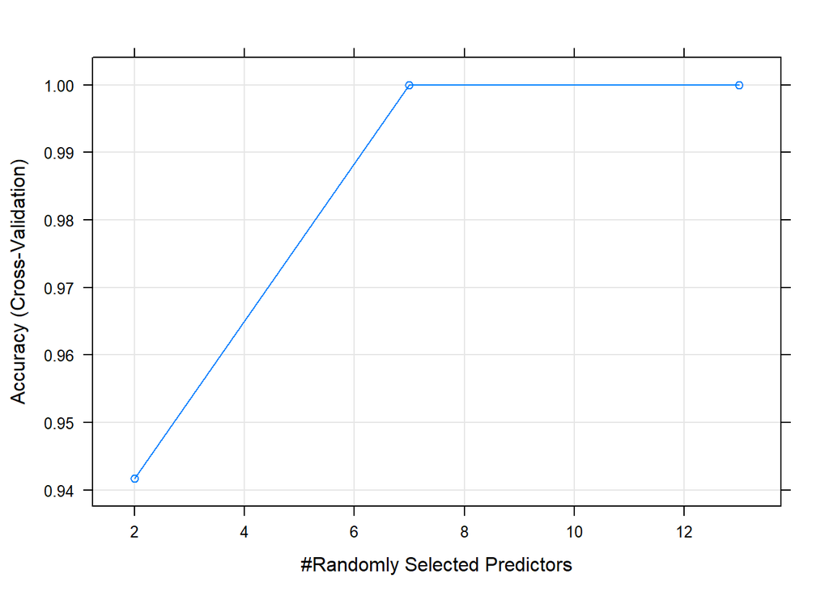

```r
rfMod <- train(ROI_Low_High~., method='rf', data=(trainingSet),
               trControl=trainControl(method='cv'), number=5)
plot(rfMod)
```

```r
predRF <- predict(rfMod, testingSet)

predDF <- data.frame(predRF, type=testingSet$ROI_Low_High)
predDF
```

```
##    predRF type
## 1    High High
## 2    High High
## 3     Low  Low
## 4     Low  Low
## 5    High High
## 6    High High
## 7    High High
## 8     Low  Low
## 9     Low  Low
## 10   High High
## 11    Low  Low
## 12    Low  Low
## 13   High High
## 14   High  Low
```

```r
sum <- sum(predRF==testingSet$ROI_Low_High)
length <- length(testingSet$ROI_Low_High)
accuracy_rfMod <- (sum/length)
accuracy_rfMod
```

```
## [1] 0.9285714
```

```r
results <- c(round(accuracy_rfMod,2), round(100,2))
results <- as.factor(results)
results <- t(data.frame(results))

colnames(results) <- colnames(predDF)
Results <- rbind(predDF, results)
Results
```

```
##         predRF type
## 1         High High
## 2         High High
## 3          Low  Low
## 4          Low  Low
## 5         High High
## 6         High High
## 7         High High
## 8          Low  Low
## 9          Low  Low
## 10        High High
## 11         Low  Low
## 12         Low  Low
## 13        High High
## 14        High  Low
## results   0.93  100
```

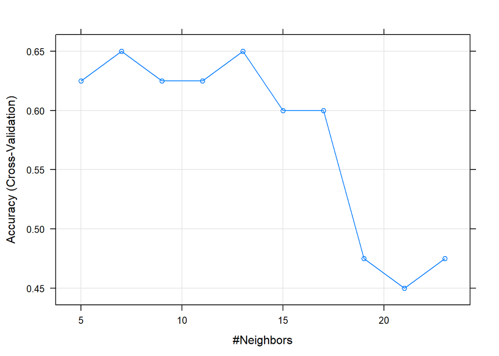

```r
knnMod <- train(ROI_Low_High ~ .,
                method='knn', preProcess=c('center','scale'),
                tuneLength=10, trControl=trainControl(method='cv'), data=trainingSet)
plot(knnMod)
```

```r
rpartMod <- train(ROI_Low_High ~ ., method='rpart', tuneLength=7, data=trainingSet)
```

```r
glmMod <- train(ROI_Low_High ~ .,
                method='glm', data=trainingSet)
```

```r
predKNN <- predict(knnMod, testingSet)
predRPART <- predict(rpartMod, testingSet)
predGLM <- predict(glmMod, testingSet)
```

```r
length=length(testingSet$ROI_Low_High)

sumKNN <- sum(predKNN==testingSet$ROI_Low_High)
sumRPart <- sum(predRPART==testingSet$ROI_Low_High)
sumGLM <- sum(predGLM==testingSet$ROI_Low_High)
```

```r
accuracy_KNN <- sumKNN/length
accuracy_RPART <- sumRPart/length
accuracy_GLM <- sumGLM/length
```

```r
predDF2 <- data.frame(predRF,predKNN,predRPART,predGLM,
                      TYPE=testingSet$ROI_Low_High)
colnames(predDF2) <- c('RandomForest','KNN','Rpart','GLM','TrueValue')

results <- c(round(accuracy_rfMod,2),
             round(accuracy_KNN,2),
             round(accuracy_RPART,2),
             round(accuracy_GLM,2),
             round(100,2))

results <- as.factor(results)
results <- t(data.frame(results))
colnames(results) <- c('RandomForest','KNN','Rpart','GLM','TrueValue')
Results <- rbind(predDF2, results)
Results
```

```
##         RandomForest  KNN Rpart  GLM TrueValue
## 1               High  Low  High  Low      High
## 2               High  Low  High High      High
## 3                Low  Low   Low  Low       Low
## 4                Low  Low   Low  Low       Low
## 5               High High  High High      High
## 6               High High  High High      High
## 7               High High  High  Low      High
## 8                Low High   Low  Low       Low
## 9                Low  Low   Low  Low       Low
## 10              High High  High High      High
## 11               Low  Low   Low  Low       Low
## 12               Low High   Low  Low       Low
## 13              High High  High High      High
## 14              High  Low  High  Low       Low
## results         0.93 0.71  0.93 0.86       100
```

Lets add in columns for each stock from the number of times the stock increased or decreased in this time span of 2007-2020, and also how many times the stock had that many days of increasing or decreasing. So that, lets say the stock increased 23 days, but from 2007-2020, the stock actually had time periods it increased 23 days 8 times. This could also be a useful feature to have about the stock. We will go back to our ROI-HandPickedStocks.Rmd file to grab these values we made for the last 36 stocks not in the set of 17 best stocks that had positive median values of daily changes when the DOW was down and unemployment was higher than the month before.

```r
aal7_gd <- aal7_decr_Days_grouped
aal7_gi <- aal7_incr_Days_grouped


arwr7_gd <- arwr7_decr_Days_grouped
arwr7_gi <- arwr7_incr_Days_grouped

c7_gd <- c7_decr_Days_grouped
c7_gi <- c7_incr_Days_grouped


cvx7_gd <- cvx7_decr_Days_grouped
cvx7_gi <- cvx7_incr_Days_grouped

epd7_gd <- epd7_decr_Days_grouped
epd7_gi <- epd7_incr_Days_grouped


f7_gd <- f7_decr_Days_grouped
f7_gi <- f7_incr_Days_grouped

ftr7_gd <- ftr7_decr_Days_grouped
ftr7_gi <- ftr7_incr_Days_grouped


hmc7_gd <- hmc7_decr_Days_grouped
hmc7_gi <- hmc7_incr_Days_grouped

hoft7_gd <- hoft7_decr_Days_grouped
hoft7_gi <- hoft7_incr_Days_grouped


hrb7_gd <- hrb7_decr_Days_grouped
hrb7_gi <- hrb7_incr_Days_grouped

hst7_gd <- hst7_decr_Days_grouped
hst7_gi <- hst7_incr_Days_grouped


ino7_gd <- ino7_decr_Days_grouped
ino7_gi <- ino7_incr_Days_grouped

jblu7_gd <- jblu7_decr_Days_grouped
jblu7_gi <- jblu7_incr_Days_grouped


kgji7_gd <- kgji7_decr_Days_grouped
kgji7_gi <- kgji7_incr_Days_grouped

kss7_gd <- kss7_decr_Days_grouped
kss7_gi <- kss7_incr_Days_grouped


luv7_gd <- luv7_decr_Days_grouped
luv7_gi <- luv7_incr_Days_grouped

m7_gd <- m7_decr_Days_grouped
m7_gi <- m7_incr_Days_grouped


mgm7_gd <- mgm7_decr_Days_grouped
mgm7_gi <- mgm7_incr_Days_grouped

msft7_gd <- msft7_decr_Days_grouped
msft7_gi <- msft7_incr_Days_grouped


nsany7_gd <- nsany7_decr_Days_grouped
nsany7_gi <- nsany7_incr_Days_grouped

nus7_gd <- nus7_decr_Days_grouped
nus7_gi <- nus7_incr_Days_grouped


oncy7_gd <- oncy7_decr_Days_grouped
oncy7_gi <- oncy7_incr_Days_grouped

rrgb7_gd <- rrgb7_decr_Days_grouped
rrgb7_gi <- rrgb7_incr_Days_grouped


s7_gd <- s7_decr_Days_grouped
s7_gi <- s7_incr_Days_grouped

sig7_gd <- sig7_decr_Days_grouped
sig7_gi <- sig7_incr_Days_grouped


t7_gd <- t7_decr_Days_grouped
t7_gi <- t7_incr_Days_grouped

tg7_gd <- tgt7_decr_Days_grouped
tgt7_gi <- tgt7_incr_Days_grouped


tm7_gd <- tm7_decr_Days_grouped
tm7_gi <- tm7_incr_Days_grouped

ubsi7_gd <- ubsi7_decr_Days_grouped
ubsi7_gi <- ubsi7_incr_Days_grouped


vz7_gd <- vz7_decr_Days_grouped
vz7_gi <- vz7_incr_Days_grouped

wfc7_gd <- wfc7_decr_Days_grouped
wfc7_gi <- wfc7_incr_Days_grouped


wm7_gd <- wm7_decr_Days_grouped
wm7_gi <- wm7_incr_Days_grouped

wwe7_gd <- wwe7_decr_Days_grouped
wwe7_gi <- wwe7_incr_Days_grouped
```

The groups by each count of cumulative sums of days that increased or decreased and counts the number of times there were that number of days that increased or decreased before changing to the opposite direction in increasing or decreasing. These values were obtained by taking the date of each instance’s stock value to the stock value 7 days earlier using the lag of the stock value with a value of 7 from the ROI-HandPickedStocks.Rmd file.

```r
ffin7_decr_Days_grouped <- countFFIN1 %>% group_by(decr_Days) %>% count(n=n())
ffin7_decr_Days_grouped <- ffin7_decr_Days_grouped[-3]
colnames(ffin7_decr_Days_grouped)[1] <- c('ffin_decr_Days')

ffin7_incr_Days_grouped <- countFFIN2 %>% group_by(incr_Days) %>% count(n=n())
ffin7_incr_Days_grouped <- ffin7_incr_Days_grouped[-3]
colnames(ffin7_incr_Days_grouped)[1] <- c('ffin_incr_Days')

ffin7_gd <- ffin7_decr_Days_grouped
ffin7_gi <- ffin7_incr_Days_grouped
```

```r
aap7_decr_Days_grouped <- countAAP1 %>% group_by(decr_Days) %>% count(n=n())
aap7_decr_Days_grouped <- aap7_decr_Days_grouped[-3]
colnames(aap7_decr_Days_grouped)[1] <- c('aap_decr_Days')

aap7_incr_Days_grouped <- countAAP2 %>% group_by(incr_Days) %>% count(n=n())
aap7_incr_Days_grouped <- aap7_incr_Days_grouped[-3]
colnames(aap7_incr_Days_grouped)[1] <- c('aap_incr_Days')

aap7_gd <- aap7_decr_Days_grouped
aap7_gi <- aap7_incr_Days_grouped
```

```r
addy7_decr_Days_grouped <- countADDYY1 %>% group_by(decr_Days) %>% count(n=n())
addy7_decr_Days_grouped <- addy7_decr_Days_grouped[-3]
colnames(addy7_decr_Days_grouped)[1] <- c('addy_decr_Days')

addy7_incr_Days_grouped <- countADDYY2 %>% group_by(incr_Days) %>% count(n=n())
addy7_incr_Days_grouped <- addy7_incr_Days_grouped[-3]
colnames(addy7_incr_Days_grouped)[1] <- c('addy_incr_Days')

addy7_gd <- addy7_decr_Days_grouped
addy7_gi <- addy7_incr_Days_grouped
```

```r
amzn7_decr_Days_grouped <- countAMZN1 %>% group_by(decr_Days) %>% count(n=n())
amzn7_decr_Days_grouped <- amzn7_decr_Days_grouped[-3]
colnames(amzn7_decr_Days_grouped)[1] <- c('amzn_decr_Days')

amzn7_incr_Days_grouped <- countAMZN2 %>% group_by(incr_Days) %>% count(n=n())
amzn7_incr_Days_grouped <- amzn7_incr_Days_grouped[-3]
colnames(amzn7_incr_Days_grouped)[1] <- c('amzn_incr_Days')

amzn7_gd <- amzn7_decr_Days_grouped
amzn7_gi <- amzn7_incr_Days_grouped
```

```r
cost7_decr_Days_grouped <- countCOST1 %>% group_by(decr_Days) %>% count(n=n())
cost7_decr_Days_grouped <- cost7_decr_Days_grouped[-3]
colnames(cost7_decr_Days_grouped)[1] <- c('cost_decr_Days')

cost7_incr_Days_grouped <- countCOST2 %>% group_by(incr_Days) %>% count(n=n())
cost7_incr_Days_grouped <- cost7_incr_Days_grouped[-3]
colnames(cost7_incr_Days_grouped)[1] <- c('cost_incr_Days')

cost7_gd <- cost7_decr_Days_grouped
cost7_gi <- cost7_incr_Days_grouped
```

```r
dltr7_decr_Days_grouped <- countDLTR1 %>% group_by(decr_Days) %>% count(n=n())
dltr7_decr_Days_grouped <- dltr7_decr_Days_grouped[-3]
colnames(dltr7_decr_Days_grouped)[1] <- c('dltr_decr_Days')

dltr7_incr_Days_grouped <- countDLTR2 %>% group_by(incr_Days) %>% count(n=n())
dltr7_incr_Days_grouped <- dltr7_incr_Days_grouped[-3]
colnames(dltr7_incr_Days_grouped)[1] <- c('dltr_incr_Days')

dltr7_gd <- dltr7_decr_Days_grouped
dltr7_gi <- dltr7_incr_Days_grouped
```

```r
goog7_decr_Days_grouped <- countGOOG1 %>% group_by(decr_Days) %>% count(n=n())
goog7_decr_Days_grouped <- goog7_decr_Days_grouped[-3]
colnames(goog7_decr_Days_grouped)[1] <- c('goog_decr_Days')

goog7_incr_Days_grouped <- countGOOG2 %>% group_by(incr_Days) %>% count(n=n())
goog7_incr_Days_grouped <- goog7_incr_Days_grouped[-3]
colnames(goog7_incr_Days_grouped)[1] <- c('goog_incr_Days')

goog7_gd <- goog7_decr_Days_grouped
goog7_gi <- goog7_incr_Days_grouped
```

```r
hd7_decr_Days_grouped <- countHD1 %>% group_by(decr_Days) %>% count(n=n())
hd7_decr_Days_grouped <- hd7_decr_Days_grouped[-3]
colnames(hd7_decr_Days_grouped)[1] <- c('hd_decr_Days')

hd7_incr_Days_grouped <- countHD2 %>% group_by(incr_Days) %>% count(n=n())
hd7_incr_Days_grouped <- hd7_incr_Days_grouped[-3]
colnames(hd7_incr_Days_grouped)[1] <- c('hd_incr_Days')

hd7_gd <- hd7_decr_Days_grouped
hd7_gi <- hd7_incr_Days_grouped
```

```r
jnj7_decr_Days_grouped <- countJNJ1 %>% group_by(decr_Days) %>% count(n=n())
jnj7_decr_Days_grouped <- jnj7_decr_Days_grouped[-3]
colnames(jnj7_decr_Days_grouped)[1] <- c('jnj_decr_Days')

jnj7_incr_Days_grouped <- countJNJ2 %>% group_by(incr_Days) %>% count(n=n())
jnj7_incr_Days_grouped <- jnj7_incr_Days_grouped[-3]
colnames(jnj7_incr_Days_grouped)[1] <- c('jnj_incr_Days')

jnj7_gd <- jnj7_decr_Days_grouped
jnj7_gi <- jnj7_incr_Days_grouped
```

```r
nflx7_decr_Days_grouped <- countNFLX1 %>% group_by(decr_Days) %>% count(n=n())
nflx7_decr_Days_grouped <- nflx7_decr_Days_grouped[-3]
colnames(nflx7_decr_Days_grouped)[1] <- c('nflx_decr_Days')

nflx7_incr_Days_grouped <- countNFLX2 %>% group_by(incr_Days) %>% count(n=n())
nflx7_incr_Days_grouped <- nflx7_incr_Days_grouped[-3]
colnames(nflx7_incr_Days_grouped)[1] <- c('nflx_incr_Days')

nflx7_gd <- nflx7_decr_Days_grouped
nflx7_gi <- nflx7_incr_Days_grouped
```

```r
nke7_decr_Days_grouped <- countNKE1 %>% group_by(decr_Days) %>% count(n=n())
nke7_decr_Days_grouped <- nke7_decr_Days_grouped[-3]
colnames(nke7_decr_Days_grouped)[1] <- c('nke_decr_Days')

nke7_incr_Days_grouped <- countNKE2 %>% group_by(incr_Days) %>% count(n=n())
nke7_incr_Days_grouped <- nke7_incr_Days_grouped[-3]
colnames(nke7_incr_Days_grouped)[1] <- c('nke_incr_Days')

nke7_gd <- nke7_decr_Days_grouped
nke7_gi <- nke7_incr_Days_grouped
```

```r
pcg7_decr_Days_grouped <- countPCG1 %>% group_by(decr_Days) %>% count(n=n())
pcg7_decr_Days_grouped <- pcg7_decr_Days_grouped[-3]
colnames(pcg7_decr_Days_grouped)[1] <- c('pcg_decr_Days')

pcg7_incr_Days_grouped <- countPCG2 %>% group_by(incr_Days) %>% count(n=n())
pcg7_incr_Days_grouped <- pcg7_incr_Days_grouped[-3]
colnames(pcg7_incr_Days_grouped)[1] <- c('pcg_incr_Days')

pcg7_gd <- pcg7_decr_Days_grouped
pcg7_gi <- pcg7_incr_Days_grouped
```

```r
rost7_decr_Days_grouped <- countROST1 %>% group_by(decr_Days) %>% count(n=n())
rost7_decr_Days_grouped <- rost7_decr_Days_grouped[-3]
colnames(rost7_decr_Days_grouped)[1] <- c('rost_decr_Days')

rost7_incr_Days_grouped <- countROST2 %>% group_by(incr_Days) %>% count(n=n())
rost7_incr_Days_grouped <- rost7_incr_Days_grouped[-3]
colnames(rost7_incr_Days_grouped)[1] <- c('rost_incr_Days')

rost7_gd <- rost7_decr_Days_grouped
rost7_gi <- rost7_incr_Days_grouped
```

```r
teva7_decr_Days_grouped <- countTEVA1 %>% group_by(decr_Days) %>% count(n=n())
teva7_decr_Days_grouped <- teva7_decr_Days_grouped[-3]
colnames(teva7_decr_Days_grouped)[1] <- c('teva_decr_Days')

teva7_incr_Days_grouped <- countTEVA2 %>% group_by(incr_Days) %>% count(n=n())
teva7_incr_Days_grouped <- teva7_incr_Days_grouped[-3]
colnames(teva7_incr_Days_grouped)[1] <- c('teva_incr_Days')

teva7_gd <- teva7_decr_Days_grouped
teva7_gi <- teva7_incr_Days_grouped
```

```r
tjx7_decr_Days_grouped <- countTJX1 %>% group_by(decr_Days) %>% count(n=n())
tjx7_decr_Days_grouped <- tjx7_decr_Days_grouped[-3]
colnames(tjx7_decr_Days_grouped)[1] <- c('tjx_decr_Days')

tjx7_incr_Days_grouped <- countTJX2 %>% group_by(incr_Days) %>% count(n=n())
tjx7_incr_Days_grouped <- tjx7_incr_Days_grouped[-3]
colnames(tjx7_incr_Days_grouped)[1] <- c('tjx_incr_Days')

tjx7_gd <- tjx7_decr_Days_grouped
tjx7_gi <- tjx7_incr_Days_grouped
```

```r
wmt7_decr_Days_grouped <- countWMT1 %>% group_by(decr_Days) %>% count(n=n())
wmt7_decr_Days_grouped <- wmt7_decr_Days_grouped[-3]
colnames(wmt7_decr_Days_grouped)[1] <- c('wmt_decr_Days')

wmt7_incr_Days_grouped <- countWMT2 %>% group_by(incr_Days) %>% count(n=n())
wmt7_incr_Days_grouped <- wmt7_incr_Days_grouped[-3]
colnames(wmt7_incr_Days_grouped)[1] <- c('wmt_incr_Days')

wmt7_gd <- wmt7_decr_Days_grouped
wmt7_gi <- wmt7_incr_Days_grouped
```

```r
xom7_decr_Days_grouped <- countXOM1 %>% group_by(decr_Days) %>% count(n=n())
xom7_decr_Days_grouped <- xom7_decr_Days_grouped[-3]
colnames(xom7_decr_Days_grouped)[1] <- c('xom_decr_Days')

xom7_incr_Days_grouped <- countXOM2 %>% group_by(incr_Days) %>% count(n=n())
xom7_incr_Days_grouped <- xom7_incr_Days_grouped[-3]
colnames(xom7_incr_Days_grouped)[1] <- c('xom_incr_Days')

xom7_gd <- xom7_decr_Days_grouped
xom7_gi <- xom7_incr_Days_grouped
```

Now that we have the grouped counts of how many times a stock in this set increased or decreased consecutively from 2007-2020. We can add these values to our dataset of ALL_52.

```r
ALL_52$MedianDecrDayGroup <- 'Median Decreasing Group'
ALL_52$MedianDecrDayCounts <- 'median N times Group Decr'

ALL_52$Q3DecrDayGroup <- '3rd Quantile Decreasing Group'
ALL_52$Q3DecrDayCounts <- '3rd Quantile N times Group Decr'

ALL_52$MaxDecrDayGroup <- 'Max Decreasing Group'
ALL_52$MaxDecrDayCounts <- 'Max N times Group Decr'

ALL_52$MedianIncrDayGroup <- 'group incr median'
ALL_52$MedianIncrDayCounts <- 'median N times Group Incr'

ALL_52$Q3IncrDayGroup <- 'group incr 3rd quantile'
ALL_52$Q3IncrDayCounts <- '3rd Quantile N times Group Incr'

ALL_52$MaxIncrDayGroup <- 'group incr max'
ALL_52$MaxIncrDayCounts <- 'Max N times Group Incr'
```

AAL

```r
#the grouped tables for the decreasing and increasing counts as sets
#where each set of counts happened one or more times
aal7_gd <- aal7_decr_Days_grouped
aal7_gi <- aal7_incr_Days_grouped

#removes the row names
row.names(aal7_gd) <- NULL
row.names(aal7_gi) <- NULL

#orders the tables by n counts of decreasing days, so indexing can be done
aal7_gd <- aal7_gd[order(aal7_gd$n),]
aal7_gi <- aal7_gi[order(aal7_gi$n),]

#the median value of counts for the number of times a stock decr in this time span
mdnaal_d <- as.numeric(floor(quantile(aal7_gd$n, probs=0.5, na.rm=TRUE)))

#the index of the median number of times a sum of decr days occurred in this time series
c1 <- ceiling(length(aal7_gd$n)/2)
mdnaal_d1 <- as.numeric(aal7_gd[c1,1])

#the 3rd quantile of counts of sets decr days in this time span from a quantile tibble
#has to be set to numeric
q3aal_d <- as.numeric(floor(quantile(aal7_gd$n, probs=0.75, na.rm=TRUE)))

#the index of the 3rd quantile, to get the decr set that occured 75% of the time in counts for this time span
c2 <- floor(length(aal7_gd$n)*.75)
q3aal_d1 <- as.numeric(aal7_gd[c2,1])

#the max value of times a set's decr days occurred in this time span
mxaal_d <- as.numeric(floor(quantile(aal7_gd$n, probs=1, na.rm=TRUE)))

#the set of decreasing days in the max counts
mxaal_d1 <- as.numeric(aal7_gd[length(aal7_gd$n),1])


#the median value of counts for the number of times a stock incr in this time span
mdnaal_i <- as.numeric(floor(quantile(aal7_gi$n, probs=0.5, na.rm=TRUE)))

#the index of the median number of times a sum of incr days occurred in this time series
c1 <- ceiling(length(aal7_gi$n)/2)
mdnaal_i1 <- as.numeric(aal7_gi[c1,1])

#the 3rd quantile of counts of sets incr days in this time span from a quantile tibble
#has to be set to numeric
q3aal_i <- as.numeric(floor(quantile(aal7_gi$n, probs=0.75, na.rm=TRUE)))

#the index of the 3rd quantile, to get the incr set that occured 75% of the time in counts for this time span
c2 <- floor(length(aal7_gi$n)*.75)
q3aal_i1 <- as.numeric(aal7_gi[c2,1])

#the max value of times a set's incr days occurred in this time span
mxaal_i <- as.numeric(floor(quantile(aal7_gi$n, probs=1, na.rm=TRUE)))

#the set of increasing days in the max counts
mxaal_i1 <- as.numeric(aal7_gi[length(aal7_gi$n),1])


aal_g <- grep('AAL', ALL_52$stock)

ALL_52[aal_g,18:29] <- c(mdnaal_d1, mdnaal_d, q3aal_d1, q3aal_d,
                         mxaal_d1, mxaal_d, mdnaal_i1, mdnaal_i,
                         q3aal_i1, q3aal_i, mxaal_i1, mxaal_i)
```

AAP

```r
#the grouped tables for the decreasing and increasing counts as sets
#where each set of counts happened one or more times
aap7_gd <- aap7_decr_Days_grouped
aap7_gi <- aap7_incr_Days_grouped

#removes the row names
row.names(aap7_gd) <- NULL
row.names(aap7_gi) <- NULL

#orders the tables by n counts of decreasing days, so indexing can be done
aap7_gd <- aap7_gd[order(aap7_gd$n),]
aap7_gi <- aap7_gi[order(aap7_gi$n),]

#the median value of counts for the number of times a stock decr in this time span
mdnaap_d <- as.numeric(floor(quantile(aap7_gd$n, probs=0.5, na.rm=TRUE)))

#the index of the median number of times a sum of decr days occurred in this time series
c1 <- ceiling(length(aap7_gd$n)/2)
mdnaap_d1 <- as.numeric(aap7_gd[c1,1])

#the 3rd quantile of counts of sets decr days in this time span from a quantile tibble
#has to be set to numeric
q3aap_d <- as.numeric(floor(quantile(aap7_gd$n, probs=0.75, na.rm=TRUE)))

#the index of the 3rd quantile, to get the decr set that occured 75% of the time in counts for this time span
c2 <- floor(length(aap7_gd$n)*.75)
q3aap_d1 <- as.numeric(aap7_gd[c2,1])

#the max value of times a set's decr days occurred in this time span
mxaap_d <- as.numeric(floor(quantile(aap7_gd$n, probs=1, na.rm=TRUE)))

#the set of decreasing days in the max counts
mxaap_d1 <- as.numeric(aap7_gd[length(aap7_gd$n),1])


#the median value of counts for the number of times a stock incr in this time span
mdnaap_i <- as.numeric(floor(quantile(aap7_gi$n, probs=0.5, na.rm=TRUE)))

#the index of the median number of times a sum of incr days occurred in this time series
c1 <- ceiling(length(aap7_gi$n)/2)
mdnaap_i1 <- as.numeric(aap7_gi[c1,1])

#the 3rd quantile of counts of sets incr days in this time span from a quantile tibble
#has to be set to numeric
q3aap_i <- as.numeric(floor(quantile(aap7_gi$n, probs=0.75, na.rm=TRUE)))

#the index of the 3rd quantile, to get the incr set that occured 75% of the time in counts for this time span
c2 <- floor(length(aap7_gi$n)*.75)
q3aap_i1 <- as.numeric(aap7_gi[c2,1])

#the max value of times a set's incr days occurred in this time span
mxaap_i <- as.numeric(floor(quantile(aap7_gi$n, probs=1, na.rm=TRUE)))

#the set of increasing days in the max counts
mxaap_i1 <- as.numeric(aap7_gi[length(aap7_gi$n),1])


aap_g <- grep('AAP', ALL_52$stock)

ALL_52[aap_g,18:29] <- c(mdnaap_d1, mdnaap_d, q3aap_d1, q3aap_d,
                         mxaap_d1, mxaap_d, mdnaap_i1, mdnaap_i,
                         q3aap_i1, q3aap_i, mxaap_i1, mxaap_i)
```

ADDY

```r
#the grouped tables for the decreasing and increasing counts as sets
#where each set of counts happened one or more times
addy7_gd <- addy7_decr_Days_grouped
addy7_gi <- addy7_incr_Days_grouped

#removes the row names
row.names(addy7_gd) <- NULL
row.names(addy7_gi) <- NULL

#orders the tables by n counts of decreasing days, so indexing can be done
addy7_gd <- addy7_gd[order(addy7_gd$n),]
addy7_gi <- addy7_gi[order(addy7_gi$n),]

#the median value of counts for the number of times a stock decr in this time span
mdnaddy_d <- as.numeric(floor(quantile(addy7_gd$n, probs=0.5, na.rm=TRUE)))

#the index of the median number of times a sum of decr days occurred in this time series
c1 <- ceiling(length(addy7_gd$n)/2)
mdnaddy_d1 <- as.numeric(addy7_gd[c1,1])

#the 3rd quantile of counts of sets decr days in this time span from a quantile tibble
#has to be set to numeric
q3addy_d <- as.numeric(floor(quantile(addy7_gd$n, probs=0.75, na.rm=TRUE)))

#the index of the 3rd quantile, to get the decr set that occured 75% of the time in counts for this time span
c2 <- floor(length(addy7_gd$n)*.75)
q3addy_d1 <- as.numeric(addy7_gd[c2,1])

#the max value of times a set's decr days occurred in this time span
mxaddy_d <- as.numeric(floor(quantile(addy7_gd$n, probs=1, na.rm=TRUE)))

#the set of decreasing days in the max counts
mxaddy_d1 <- as.numeric(addy7_gd[length(addy7_gd$n),1])


#the median value of counts for the number of times a stock incr in this time span
mdnaddy_i <- as.numeric(floor(quantile(addy7_gi$n, probs=0.5, na.rm=TRUE)))

#the index of the median number of times a sum of incr days occurred in this time series
c1 <- ceiling(length(addy7_gi$n)/2)
mdnaddy_i1 <- as.numeric(addy7_gi[c1,1])

#the 3rd quantile of counts of sets incr days in this time span from a quantile tibble
#has to be set to numeric
q3addy_i <- as.numeric(floor(quantile(addy7_gi$n, probs=0.75, na.rm=TRUE)))

#the index of the 3rd quantile, to get the incr set that occured 75% of the time in counts for this time span
c2 <- floor(length(addy7_gi$n)*.75)
q3addy_i1 <- as.numeric(addy7_gi[c2,1])

#the max value of times a set's incr days occurred in this time span
mxaddy_i <- as.numeric(floor(quantile(addy7_gi$n, probs=1, na.rm=TRUE)))

#the set of increasing days in the max counts
mxaddy_i1 <- as.numeric(addy7_gi[length(addy7_gi$n),1])


addy_g <- grep('ADDY', ALL_52$stock)

ALL_52[addy_g,18:29] <- c(mdnaddy_d1, mdnaddy_d, q3addy_d1, q3addy_d,
                         mxaddy_d1, mxaddy_d, mdnaddy_i1, mdnaddy_i,
                         q3addy_i1, q3addy_i, mxaddy_i1, mxaddy_i)
```

AMZN

```r
#the grouped tables for the decreasing and increasing counts as sets
#where each set of counts happened one or more times
amzn7_gd <- amzn7_decr_Days_grouped
amzn7_gi <- amzn7_incr_Days_grouped

#removes the row names
row.names(amzn7_gd) <- NULL
row.names(amzn7_gi) <- NULL

#orders the tables by n counts of decreasing days, so indexing can be done
amzn7_gd <- amzn7_gd[order(amzn7_gd$n),]
amzn7_gi <- amzn7_gi[order(amzn7_gi$n),]

#the median value of counts for the number of times a stock decr in this time span
mdnamzn_d <- as.numeric(floor(quantile(amzn7_gd$n, probs=0.5, na.rm=TRUE)))

#the index of the median number of times a sum of decr days occurred in this time series
c1 <- ceiling(length(amzn7_gd$n)/2)
mdnamzn_d1 <- as.numeric(amzn7_gd[c1,1])

#the 3rd quantile of counts of sets decr days in this time span from a quantile tibble
#has to be set to numeric
q3amzn_d <- as.numeric(floor(quantile(amzn7_gd$n, probs=0.75, na.rm=TRUE)))

#the index of the 3rd quantile, to get the decr set that occured 75% of the time in counts for this time span
c2 <- floor(length(amzn7_gd$n)*.75)
q3amzn_d1 <- as.numeric(amzn7_gd[c2,1])

#the max value of times a set's decr days occurred in this time span
mxamzn_d <- as.numeric(floor(quantile(amzn7_gd$n, probs=1, na.rm=TRUE)))

#the set of decreasing days in the max counts
mxamzn_d1 <- as.numeric(amzn7_gd[length(amzn7_gd$n),1])


#the median value of counts for the number of times a stock incr in this time span
mdnamzn_i <- as.numeric(floor(quantile(amzn7_gi$n, probs=0.5, na.rm=TRUE)))

#the index of the median number of times a sum of incr days occurred in this time series
c1 <- ceiling(length(amzn7_gi$n)/2)
mdnamzn_i1 <- as.numeric(amzn7_gi[c1,1])

#the 3rd quantile of counts of sets incr days in this time span from a quantile tibble
#has to be set to numeric
q3amzn_i <- as.numeric(floor(quantile(amzn7_gi$n, probs=0.75, na.rm=TRUE)))

#the index of the 3rd quantile, to get the incr set that occured 75% of the time in counts for this time span
c2 <- floor(length(amzn7_gi$n)*.75)
q3amzn_i1 <- as.numeric(amzn7_gi[c2,1])

#the max value of times a set's incr days occurred in this time span
mxamzn_i <- as.numeric(floor(quantile(amzn7_gi$n, probs=1, na.rm=TRUE)))

#the set of increasing days in the max counts
mxamzn_i1 <- as.numeric(amzn7_gi[length(amzn7_gi$n),1])


amzn_g <- grep('AMZN', ALL_52$stock)

ALL_52[amzn_g,18:29] <- c(mdnamzn_d1, mdnamzn_d, q3amzn_d1, q3amzn_d,
                         mxamzn_d1, mxamzn_d, mdnamzn_i1, mdnamzn_i,
                         q3amzn_i1, q3amzn_i, mxamzn_i1, mxamzn_i)
```

ARWR

```r
#the grouped tables for the decreasing and increasing counts as sets
#where each set of counts happened one or more times
arwr7_gd <- arwr7_decr_Days_grouped
arwr7_gi <- arwr7_incr_Days_grouped

#removes the row names
row.names(arwr7_gd) <- NULL
row.names(arwr7_gi) <- NULL

#orders the tables by n counts of decreasing days, so indexing can be done
arwr7_gd <- arwr7_gd[order(arwr7_gd$n),]
arwr7_gi <- arwr7_gi[order(arwr7_gi$n),]

#the median value of counts for the number of times a stock decr in this time span
mdnarwr_d <- as.numeric(floor(quantile(arwr7_gd$n, probs=0.5, na.rm=TRUE)))

#the index of the median number of times a sum of decr days occurred in this time series
c1 <- ceiling(length(arwr7_gd$n)/2)
mdnarwr_d1 <- as.numeric(arwr7_gd[c1,1])

#the 3rd quantile of counts of sets decr days in this time span from a quantile tibble
#has to be set to numeric
q3arwr_d <- as.numeric(floor(quantile(arwr7_gd$n, probs=0.75, na.rm=TRUE)))

#the index of the 3rd quantile, to get the decr set that occured 75% of the time in counts for this time span
c2 <- floor(length(arwr7_gd$n)*.75)
q3arwr_d1 <- as.numeric(arwr7_gd[c2,1])

#the max value of times a set's decr days occurred in this time span
mxarwr_d <- as.numeric(floor(quantile(arwr7_gd$n, probs=1, na.rm=TRUE)))

#the set of decreasing days in the max counts
mxarwr_d1 <- as.numeric(arwr7_gd[length(arwr7_gd$n),1])


#the median value of counts for the number of times a stock incr in this time span
mdnarwr_i <- as.numeric(floor(quantile(arwr7_gi$n, probs=0.5, na.rm=TRUE)))

#the index of the median number of times a sum of incr days occurred in this time series
c1 <- ceiling(length(arwr7_gi$n)/2)
mdnarwr_i1 <- as.numeric(arwr7_gi[c1,1])

#the 3rd quantile of counts of sets incr days in this time span from a quantile tibble
#has to be set to numeric
q3arwr_i <- as.numeric(floor(quantile(arwr7_gi$n, probs=0.75, na.rm=TRUE)))

#the index of the 3rd quantile, to get the incr set that occured 75% of the time in counts for this time span
c2 <- floor(length(arwr7_gi$n)*.75)
q3arwr_i1 <- as.numeric(arwr7_gi[c2,1])

#the max value of times a set's incr days occurred in this time span
mxarwr_i <- as.numeric(floor(quantile(arwr7_gi$n, probs=1, na.rm=TRUE)))

#the set of increasing days in the max counts
mxarwr_i1 <- as.numeric(arwr7_gi[length(arwr7_gi$n),1])


arwr_g <- grep('ARWR', ALL_52$stock)

ALL_52[arwr_g,18:29] <- c(mdnarwr_d1, mdnarwr_d, q3arwr_d1, q3arwr_d,
                         mxarwr_d1, mxarwr_d, mdnarwr_i1, mdnarwr_i,
                         q3arwr_i1, q3arwr_i, mxarwr_i1, mxarwr_i)
```

C

```r
#the grouped tables for the decreasing and increasing counts as sets
#where each set of counts happened one or more times
c7_gd <- c7_decr_Days_grouped
c7_gi <- c7_incr_Days_grouped

#removes the row names
row.names(c7_gd) <- NULL
row.names(c7_gi) <- NULL

#orders the tables by n counts of decreasing days, so indexing can be done
c7_gd <- c7_gd[order(c7_gd$n),]
c7_gi <- c7_gi[order(c7_gi$n),]

#the median value of counts for the number of times a stock decr in this time span
mdnc_d <- as.numeric(floor(quantile(c7_gd$n, probs=0.5, na.rm=TRUE)))

#the index of the median number of times a sum of decr days occurred in this time series
c1 <- ceiling(length(c7_gd$n)/2)
mdnc_d1 <- as.numeric(c7_gd[c1,1])

#the 3rd quantile of counts of sets decr days in this time span from a quantile tibble
#has to be set to numeric
q3c_d <- as.numeric(floor(quantile(c7_gd$n, probs=0.75, na.rm=TRUE)))

#the index of the 3rd quantile, to get the decr set that occured 75% of the time in counts for this time span
c2 <- floor(length(c7_gd$n)*.75)
q3c_d1 <- as.numeric(c7_gd[c2,1])

#the max value of times a set's decr days occurred in this time span
mxc_d <- as.numeric(floor(quantile(c7_gd$n, probs=1, na.rm=TRUE)))

#the set of decreasing days in the max counts
mxc_d1 <- as.numeric(c7_gd[length(c7_gd$n),1])


#the median value of counts for the number of times a stock incr in this time span
mdnc_i <- as.numeric(floor(quantile(c7_gi$n, probs=0.5, na.rm=TRUE)))

#the index of the median number of times a sum of incr days occurred in this time series
c1 <- ceiling(length(c7_gi$n)/2)
mdnc_i1 <- as.numeric(c7_gi[c1,1])

#the 3rd quantile of counts of sets incr days in this time span from a quantile tibble
#has to be set to numeric
q3c_i <- as.numeric(floor(quantile(c7_gi$n, probs=0.75, na.rm=TRUE)))

#the index of the 3rd quantile, to get the incr set that occured 75% of the time in counts for this time span
c2 <- floor(length(c7_gi$n)*.75)
q3c_i1 <- as.numeric(c7_gi[c2,1])

#the max value of times a set's incr days occurred in this time span
mxc_i <- as.numeric(floor(quantile(c7_gi$n, probs=1, na.rm=TRUE)))

#the set of increasing days in the max counts
mxc_i1 <- as.numeric(c7_gi[length(c7_gi$n),1])


c_g <- grep('^C$', ALL_52$stock)

ALL_52[c_g,18:29] <- c(mdnc_d1, mdnc_d, q3c_d1, q3c_d,
                         mxc_d1, mxc_d, mdnc_i1, mdnc_i,
                         q3c_i1, q3c_i, mxc_i1, mxc_i)
```

COST

```r
#the grouped tables for the decreasing and increasing counts as sets
#where each set of counts happened one or more times
cost7_gd <- cost7_decr_Days_grouped
cost7_gi <- cost7_incr_Days_grouped

#removes the row names
row.names(cost7_gd) <- NULL
row.names(cost7_gi) <- NULL

#orders the tables by n counts of decreasing days, so indexing can be done
cost7_gd <- cost7_gd[order(cost7_gd$n),]
cost7_gi <- cost7_gi[order(cost7_gi$n),]

#the median value of counts for the number of times a stock decr in this time span
mdncost_d <- as.numeric(floor(quantile(cost7_gd$n, probs=0.5, na.rm=TRUE)))

#the index of the median number of times a sum of decr days occurred in this time series
c1 <- ceiling(length(cost7_gd$n)/2)
mdncost_d1 <- as.numeric(cost7_gd[c1,1])

#the 3rd quantile of counts of sets decr days in this time span from a quantile tibble
#has to be set to numeric
q3cost_d <- as.numeric(floor(quantile(cost7_gd$n, probs=0.75, na.rm=TRUE)))

#the index of the 3rd quantile, to get the decr set that occured 75% of the time in counts for this time span
c2 <- floor(length(cost7_gd$n)*.75)
q3cost_d1 <- as.numeric(cost7_gd[c2,1])

#the max value of times a set's decr days occurred in this time span
mxcost_d <- as.numeric(floor(quantile(cost7_gd$n, probs=1, na.rm=TRUE)))

#the set of decreasing days in the max counts
mxcost_d1 <- as.numeric(cost7_gd[length(cost7_gd$n),1])


#the median value of counts for the number of times a stock incr in this time span
mdncost_i <- as.numeric(floor(quantile(cost7_gi$n, probs=0.5, na.rm=TRUE)))

#the index of the median number of times a sum of incr days occurred in this time series
c1 <- ceiling(length(cost7_gi$n)/2)
mdncost_i1 <- as.numeric(cost7_gi[c1,1])

#the 3rd quantile of counts of sets incr days in this time span from a quantile tibble
#has to be set to numeric
q3cost_i <- as.numeric(floor(quantile(cost7_gi$n, probs=0.75, na.rm=TRUE)))

#the index of the 3rd quantile, to get the incr set that occured 75% of the time in counts for this time span
c2 <- floor(length(cost7_gi$n)*.75)
q3cost_i1 <- as.numeric(cost7_gi[c2,1])

#the max value of times a set's incr days occurred in this time span
mxcost_i <- as.numeric(floor(quantile(cost7_gi$n, probs=1, na.rm=TRUE)))

#the set of increasing days in the max counts
mxcost_i1 <- as.numeric(cost7_gi[length(cost7_gi$n),1])


cost_g <- grep('COST', ALL_52$stock)

ALL_52[cost_g,18:29] <- c(mdncost_d1, mdncost_d, q3cost_d1, q3cost_d,
                         mxcost_d1, mxcost_d, mdncost_i1, mdncost_i,
                         q3cost_i1, q3cost_i, mxcost_i1, mxcost_i)
```

CVX

```r
#the grouped tables for the decreasing and increasing counts as sets
#where each set of counts happened one or more times
cvx7_gd <- cvx7_decr_Days_grouped
cvx7_gi <- cvx7_incr_Days_grouped

#removes the row names
row.names(cvx7_gd) <- NULL
row.names(cvx7_gi) <- NULL

#orders the tables by n counts of decreasing days, so indexing can be done
cvx7_gd <- cvx7_gd[order(cvx7_gd$n),]
cvx7_gi <- cvx7_gi[order(cvx7_gi$n),]

#the median value of counts for the number of times a stock decr in this time span
mdncvx_d <- as.numeric(floor(quantile(cvx7_gd$n, probs=0.5, na.rm=TRUE)))

#the index of the median number of times a sum of decr days occurred in this time series
c1 <- ceiling(length(cvx7_gd$n)/2)
mdncvx_d1 <- as.numeric(cvx7_gd[c1,1])

#the 3rd quantile of counts of sets decr days in this time span from a quantile tibble
#has to be set to numeric
q3cvx_d <- as.numeric(floor(quantile(cvx7_gd$n, probs=0.75, na.rm=TRUE)))

#the index of the 3rd quantile, to get the decr set that occured 75% of the time in counts for this time span
c2 <- floor(length(cvx7_gd$n)*.75)
q3cvx_d1 <- as.numeric(cvx7_gd[c2,1])

#the max value of times a set's decr days occurred in this time span
mxcvx_d <- as.numeric(floor(quantile(cvx7_gd$n, probs=1, na.rm=TRUE)))

#the set of decreasing days in the max counts
mxcvx_d1 <- as.numeric(cvx7_gd[length(cvx7_gd$n),1])


#the median value of counts for the number of times a stock incr in this time span
mdncvx_i <- as.numeric(floor(quantile(cvx7_gi$n, probs=0.5, na.rm=TRUE)))

#the index of the median number of times a sum of incr days occurred in this time series
c1 <- ceiling(length(cvx7_gi$n)/2)
mdncvx_i1 <- as.numeric(cvx7_gi[c1,1])

#the 3rd quantile of counts of sets incr days in this time span from a quantile tibble
#has to be set to numeric
q3cvx_i <- as.numeric(floor(quantile(cvx7_gi$n, probs=0.75, na.rm=TRUE)))

#the index of the 3rd quantile, to get the incr set that occured 75% of the time in counts for this time span
c2 <- floor(length(cvx7_gi$n)*.75)
q3cvx_i1 <- as.numeric(cvx7_gi[c2,1])

#the max value of times a set's incr days occurred in this time span
mxcvx_i <- as.numeric(floor(quantile(cvx7_gi$n, probs=1, na.rm=TRUE)))

#the set of increasing days in the max counts
mxcvx_i1 <- as.numeric(cvx7_gi[length(cvx7_gi$n),1])


cvx_g <- grep('CVX', ALL_52$stock)

ALL_52[cvx_g,18:29] <- c(mdncvx_d1, mdncvx_d, q3cvx_d1, q3cvx_d,
                         mxcvx_d1, mxcvx_d, mdncvx_i1, mdncvx_i,
                         q3cvx_i1, q3cvx_i, mxcvx_i1, mxcvx_i)
```

DLTR

```r
#the grouped tables for the decreasing and increasing counts as sets
#where each set of counts happened one or more times
dltr7_gd <- dltr7_decr_Days_grouped
dltr7_gi <- dltr7_incr_Days_grouped

#removes the row names
row.names(dltr7_gd) <- NULL
row.names(dltr7_gi) <- NULL

#orders the tables by n counts of decreasing days, so indexing can be done
dltr7_gd <- dltr7_gd[order(dltr7_gd$n),]
dltr7_gi <- dltr7_gi[order(dltr7_gi$n),]

#the median value of counts for the number of times a stock decr in this time span
mdndltr_d <- as.numeric(floor(quantile(dltr7_gd$n, probs=0.5, na.rm=TRUE)))

#the index of the median number of times a sum of decr days occurred in this time series
c1 <- ceiling(length(dltr7_gd$n)/2)
mdndltr_d1 <- as.numeric(dltr7_gd[c1,1])

#the 3rd quantile of counts of sets decr days in this time span from a quantile tibble
#has to be set to numeric
q3dltr_d <- as.numeric(floor(quantile(dltr7_gd$n, probs=0.75, na.rm=TRUE)))

#the index of the 3rd quantile, to get the decr set that occured 75% of the time in counts for this time span
c2 <- floor(length(dltr7_gd$n)*.75)
q3dltr_d1 <- as.numeric(dltr7_gd[c2,1])

#the max value of times a set's decr days occurred in this time span
mxdltr_d <- as.numeric(floor(quantile(dltr7_gd$n, probs=1, na.rm=TRUE)))

#the set of decreasing days in the max counts
mxdltr_d1 <- as.numeric(dltr7_gd[length(dltr7_gd$n),1])


#the median value of counts for the number of times a stock incr in this time span
mdndltr_i <- as.numeric(floor(quantile(dltr7_gi$n, probs=0.5, na.rm=TRUE)))

#the index of the median number of times a sum of incr days occurred in this time series
c1 <- ceiling(length(dltr7_gi$n)/2)
mdndltr_i1 <- as.numeric(dltr7_gi[c1,1])

#the 3rd quantile of counts of sets incr days in this time span from a quantile tibble
#has to be set to numeric
q3dltr_i <- as.numeric(floor(quantile(dltr7_gi$n, probs=0.75, na.rm=TRUE)))

#the index of the 3rd quantile, to get the incr set that occured 75% of the time in counts for this time span
c2 <- floor(length(dltr7_gi$n)*.75)
q3dltr_i1 <- as.numeric(dltr7_gi[c2,1])

#the max value of times a set's incr days occurred in this time span
mxdltr_i <- as.numeric(floor(quantile(dltr7_gi$n, probs=1, na.rm=TRUE)))

#the set of increasing days in the max counts
mxdltr_i1 <- as.numeric(dltr7_gi[length(dltr7_gi$n),1])


dltr_g <- grep('DLTR', ALL_52$stock)

ALL_52[dltr_g,18:29] <- c(mdndltr_d1, mdndltr_d, q3dltr_d1, q3dltr_d,
                         mxdltr_d1, mxdltr_d, mdndltr_i1, mdndltr_i,
                         q3dltr_i1, q3dltr_i, mxdltr_i1, mxdltr_i)
```

EPD

```r
#the grouped tables for the decreasing and increasing counts as sets
#where each set of counts happened one or more times
epd7_gd <- epd7_decr_Days_grouped
epd7_gi <- epd7_incr_Days_grouped

#removes the row names
row.names(epd7_gd) <- NULL
row.names(epd7_gi) <- NULL

#orders the tables by n counts of decreasing days, so indexing can be done
epd7_gd <- epd7_gd[order(epd7_gd$n),]
epd7_gi <- epd7_gi[order(epd7_gi$n),]

#the median value of counts for the number of times a stock decr in this time span
mdnepd_d <- as.numeric(floor(quantile(epd7_gd$n, probs=0.5, na.rm=TRUE)))

#the index of the median number of times a sum of decr days occurred in this time series
c1 <- ceiling(length(epd7_gd$n)/2)
mdnepd_d1 <- as.numeric(epd7_gd[c1,1])

#the 3rd quantile of counts of sets decr days in this time span from a quantile tibble
#has to be set to numeric
q3epd_d <- as.numeric(floor(quantile(epd7_gd$n, probs=0.75, na.rm=TRUE)))

#the index of the 3rd quantile, to get the decr set that occured 75% of the time in counts for this time span
c2 <- floor(length(epd7_gd$n)*.75)
q3epd_d1 <- as.numeric(epd7_gd[c2,1])

#the max value of times a set's decr days occurred in this time span
mxepd_d <- as.numeric(floor(quantile(epd7_gd$n, probs=1, na.rm=TRUE)))

#the set of decreasing days in the max counts
mxepd_d1 <- as.numeric(epd7_gd[length(epd7_gd$n),1])


#the median value of counts for the number of times a stock incr in this time span
mdnepd_i <- as.numeric(floor(quantile(epd7_gi$n, probs=0.5, na.rm=TRUE)))

#the index of the median number of times a sum of incr days occurred in this time series
c1 <- ceiling(length(epd7_gi$n)/2)
mdnepd_i1 <- as.numeric(epd7_gi[c1,1])

#the 3rd quantile of counts of sets incr days in this time span from a quantile tibble
#has to be set to numeric
q3epd_i <- as.numeric(floor(quantile(epd7_gi$n, probs=0.75, na.rm=TRUE)))

#the index of the 3rd quantile, to get the incr set that occured 75% of the time in counts for this time span
c2 <- floor(length(epd7_gi$n)*.75)
q3epd_i1 <- as.numeric(epd7_gi[c2,1])

#the max value of times a set's incr days occurred in this time span
mxepd_i <- as.numeric(floor(quantile(epd7_gi$n, probs=1, na.rm=TRUE)))

#the set of increasing days in the max counts
mxepd_i1 <- as.numeric(epd7_gi[length(epd7_gi$n),1])


epd_g <- grep('EPD', ALL_52$stock)

ALL_52[epd_g,18:29] <- c(mdnepd_d1, mdnepd_d, q3epd_d1, q3epd_d,
                         mxepd_d1, mxepd_d, mdnepd_i1, mdnepd_i,
                         q3epd_i1, q3epd_i, mxepd_i1, mxepd_i)
```

F

```r
#the grouped tables for the decreasing and increasing counts as sets
#where each set of counts happened one or more times
f7_gd <- f7_decr_Days_grouped
f7_gi <- f7_incr_Days_grouped

#removes the row names
row.names(f7_gd) <- NULL
row.names(f7_gi) <- NULL

#orders the tables by n counts of decreasing days, so indexing can be done
f7_gd <- f7_gd[order(f7_gd$n),]
f7_gi <- f7_gi[order(f7_gi$n),]

#the median value of counts for the number of times a stock decr in this time span
mdnf_d <- as.numeric(floor(quantile(f7_gd$n, probs=0.5, na.rm=TRUE)))

#the index of the median number of times a sum of decr days occurred in this time series
c1 <- ceiling(length(f7_gd$n)/2)
mdnf_d1 <- as.numeric(f7_gd[c1,1])

#the 3rd quantile of counts of sets decr days in this time span from a quantile tibble
#has to be set to numeric
q3f_d <- as.numeric(floor(quantile(f7_gd$n, probs=0.75, na.rm=TRUE)))

#the index of the 3rd quantile, to get the decr set that occured 75% of the time in counts for this time span
c2 <- floor(length(f7_gd$n)*.75)
q3f_d1 <- as.numeric(f7_gd[c2,1])

#the max value of times a set's decr days occurred in this time span
mxf_d <- as.numeric(floor(quantile(f7_gd$n, probs=1, na.rm=TRUE)))

#the set of decreasing days in the max counts
mxf_d1 <- as.numeric(f7_gd[length(f7_gd$n),1])


#the median value of counts for the number of times a stock incr in this time span
mdnf_i <- as.numeric(floor(quantile(f7_gi$n, probs=0.5, na.rm=TRUE)))

#the index of the median number of times a sum of incr days occurred in this time series
c1 <- ceiling(length(f7_gi$n)/2)
mdnf_i1 <- as.numeric(f7_gi[c1,1])

#the 3rd quantile of counts of sets incr days in this time span from a quantile tibble
#has to be set to numeric
q3f_i <- as.numeric(floor(quantile(f7_gi$n, probs=0.75, na.rm=TRUE)))

#the index of the 3rd quantile, to get the incr set that occured 75% of the time in counts for this time span
c2 <- floor(length(f7_gi$n)*.75)
q3f_i1 <- as.numeric(f7_gi[c2,1])

#the max value of times a set's incr days occurred in this time span
mxf_i <- as.numeric(floor(quantile(f7_gi$n, probs=1, na.rm=TRUE)))

#the set of increasing days in the max counts
mxf_i1 <- as.numeric(f7_gi[length(f7_gi$n),1])


f_g <- grep('^F$', ALL_52$stock)

ALL_52[f_g,18:29] <- c(mdnf_d1, mdnf_d, q3f_d1, q3f_d,
                         mxf_d1, mxf_d, mdnf_i1, mdnf_i,
                         q3f_i1, q3f_i, mxf_i1, mxf_i)
```

FFIN

```r
#the grouped tables for the decreasing and increasing counts as sets
#where each set of counts happened one or more times
ffin7_gd <- ffin7_decr_Days_grouped
ffin7_gi <- ffin7_incr_Days_grouped

#removes the row names
row.names(ffin7_gd) <- NULL
row.names(ffin7_gi) <- NULL

#orders the tables by n counts of decreasing days, so indexing can be done
ffin7_gd <- ffin7_gd[order(ffin7_gd$n),]
ffin7_gi <- ffin7_gi[order(ffin7_gi$n),]

#the median value of counts for the number of times a stock decr in this time span
mdnffin_d <- as.numeric(floor(quantile(ffin7_gd$n, probs=0.5, na.rm=TRUE)))

#the index of the median number of times a sum of decr days occurred in this time series
c1 <- ceiling(length(ffin7_gd$n)/2)
mdnffin_d1 <- as.numeric(ffin7_gd[c1,1])

#the 3rd quantile of counts of sets decr days in this time span from a quantile tibble
#has to be set to numeric
q3ffin_d <- as.numeric(floor(quantile(ffin7_gd$n, probs=0.75, na.rm=TRUE)))

#the index of the 3rd quantile, to get the decr set that occured 75% of the time in counts for this time span
c2 <- floor(length(ffin7_gd$n)*.75)
q3ffin_d1 <- as.numeric(ffin7_gd[c2,1])

#the max value of times a set's decr days occurred in this time span
mxffin_d <- as.numeric(floor(quantile(ffin7_gd$n, probs=1, na.rm=TRUE)))

#the set of decreasing days in the max counts
mxffin_d1 <- as.numeric(ffin7_gd[length(ffin7_gd$n),1])


#the median value of counts for the number of times a stock incr in this time span
mdnffin_i <- as.numeric(floor(quantile(ffin7_gi$n, probs=0.5, na.rm=TRUE)))

#the index of the median number of times a sum of incr days occurred in this time series
c1 <- ceiling(length(ffin7_gi$n)/2)
mdnffin_i1 <- as.numeric(ffin7_gi[c1,1])

#the 3rd quantile of counts of sets incr days in this time span from a quantile tibble
#has to be set to numeric
q3ffin_i <- as.numeric(floor(quantile(ffin7_gi$n, probs=0.75, na.rm=TRUE)))

#the index of the 3rd quantile, to get the incr set that occured 75% of the time in counts for this time span
c2 <- floor(length(ffin7_gi$n)*.75)
q3ffin_i1 <- as.numeric(ffin7_gi[c2,1])

#the max value of times a set's incr days occurred in this time span
mxffin_i <- as.numeric(floor(quantile(ffin7_gi$n, probs=1, na.rm=TRUE)))

#the set of increasing days in the max counts
mxffin_i1 <- as.numeric(ffin7_gi[length(ffin7_gi$n),1])


ffin_g <- grep('FFIN', ALL_52$stock)

ALL_52[ffin_g,18:29] <- c(mdnffin_d1, mdnffin_d, q3ffin_d1, q3ffin_d,
                         mxffin_d1, mxffin_d, mdnffin_i1, mdnffin_i,
                         q3ffin_i1, q3ffin_i, mxffin_i1, mxffin_i)
```

FTR

```r
#the grouped tables for the decreasing and increasing counts as sets
#where each set of counts happened one or more times
ftr7_gd <- ftr7_decr_Days_grouped
ftr7_gi <- ftr7_incr_Days_grouped

#removes the row names
row.names(ftr7_gd) <- NULL
row.names(ftr7_gi) <- NULL

#orders the tables by n counts of decreasing days, so indexing can be done
ftr7_gd <- ftr7_gd[order(ftr7_gd$n),]
ftr7_gi <- ftr7_gi[order(ftr7_gi$n),]

#the median value of counts for the number of times a stock decr in this time span
mdnftr_d <- as.numeric(floor(quantile(ftr7_gd$n, probs=0.5, na.rm=TRUE)))

#the index of the median number of times a sum of decr days occurred in this time series
c1 <- ceiling(length(ftr7_gd$n)/2)
mdnftr_d1 <- as.numeric(ftr7_gd[c1,1])

#the 3rd quantile of counts of sets decr days in this time span from a quantile tibble
#has to be set to numeric
q3ftr_d <- as.numeric(floor(quantile(ftr7_gd$n, probs=0.75, na.rm=TRUE)))

#the index of the 3rd quantile, to get the decr set that occured 75% of the time in counts for this time span
c2 <- floor(length(ftr7_gd$n)*.75)
q3ftr_d1 <- as.numeric(ftr7_gd[c2,1])

#the max value of times a set's decr days occurred in this time span
mxftr_d <- as.numeric(floor(quantile(ftr7_gd$n, probs=1, na.rm=TRUE)))

#the set of decreasing days in the max counts
mxftr_d1 <- as.numeric(ftr7_gd[length(ftr7_gd$n),1])


#the median value of counts for the number of times a stock incr in this time span
mdnftr_i <- as.numeric(floor(quantile(ftr7_gi$n, probs=0.5, na.rm=TRUE)))

#the index of the median number of times a sum of incr days occurred in this time series
c1 <- ceiling(length(ftr7_gi$n)/2)
mdnftr_i1 <- as.numeric(ftr7_gi[c1,1])

#the 3rd quantile of counts of sets incr days in this time span from a quantile tibble
#has to be set to numeric
q3ftr_i <- as.numeric(floor(quantile(ftr7_gi$n, probs=0.75, na.rm=TRUE)))

#the index of the 3rd quantile, to get the incr set that occured 75% of the time in counts for this time span
c2 <- floor(length(ftr7_gi$n)*.75)
q3ftr_i1 <- as.numeric(ftr7_gi[c2,1])

#the max value of times a set's incr days occurred in this time span
mxftr_i <- as.numeric(floor(quantile(ftr7_gi$n, probs=1, na.rm=TRUE)))

#the set of increasing days in the max counts
mxftr_i1 <- as.numeric(ftr7_gi[length(ftr7_gi$n),1])


ftr_g <- grep('FTR', ALL_52$stock)

ALL_52[ftr_g,18:29] <- c(mdnftr_d1, mdnftr_d, q3ftr_d1, q3ftr_d,
                         mxftr_d1, mxftr_d, mdnftr_i1, mdnftr_i,
                         q3ftr_i1, q3ftr_i, mxftr_i1, mxftr_i)
```

GOOG

```r
#the grouped tables for the decreasing and increasing counts as sets
#where each set of counts happened one or more times
goog7_gd <- goog7_decr_Days_grouped
goog7_gi <- goog7_incr_Days_grouped

#removes the row names
row.names(goog7_gd) <- NULL
row.names(goog7_gi) <- NULL

#orders the tables by n counts of decreasing days, so indexing can be done
goog7_gd <- goog7_gd[order(goog7_gd$n),]
goog7_gi <- goog7_gi[order(goog7_gi$n),]

#the median value of counts for the number of times a stock decr in this time span
mdngoog_d <- as.numeric(floor(quantile(goog7_gd$n, probs=0.5, na.rm=TRUE)))

#the index of the median number of times a sum of decr days occurred in this time series
c1 <- ceiling(length(goog7_gd$n)/2)
mdngoog_d1 <- as.numeric(goog7_gd[c1,1])

#the 3rd quantile of counts of sets decr days in this time span from a quantile tibble
#has to be set to numeric
q3goog_d <- as.numeric(floor(quantile(goog7_gd$n, probs=0.75, na.rm=TRUE)))

#the index of the 3rd quantile, to get the decr set that occured 75% of the time in counts for this time span
c2 <- floor(length(goog7_gd$n)*.75)
q3goog_d1 <- as.numeric(goog7_gd[c2,1])

#the max value of times a set's decr days occurred in this time span
mxgoog_d <- as.numeric(floor(quantile(goog7_gd$n, probs=1, na.rm=TRUE)))

#the set of decreasing days in the max counts
mxgoog_d1 <- as.numeric(goog7_gd[length(goog7_gd$n),1])


#the median value of counts for the number of times a stock incr in this time span
mdngoog_i <- as.numeric(floor(quantile(goog7_gi$n, probs=0.5, na.rm=TRUE)))

#the index of the median number of times a sum of incr days occurred in this time series
c1 <- ceiling(length(goog7_gi$n)/2)
mdngoog_i1 <- as.numeric(goog7_gi[c1,1])

#the 3rd quantile of counts of sets incr days in this time span from a quantile tibble
#has to be set to numeric
q3goog_i <- as.numeric(floor(quantile(goog7_gi$n, probs=0.75, na.rm=TRUE)))

#the index of the 3rd quantile, to get the incr set that occured 75% of the time in counts for this time span
c2 <- floor(length(goog7_gi$n)*.75)
q3goog_i1 <- as.numeric(goog7_gi[c2,1])

#the max value of times a set's incr days occurred in this time span
mxgoog_i <- as.numeric(floor(quantile(goog7_gi$n, probs=1, na.rm=TRUE)))

#the set of increasing days in the max counts
mxgoog_i1 <- as.numeric(goog7_gi[length(goog7_gi$n),1])


goog_g <- grep('GOOG', ALL_52$stock)

ALL_52[goog_g,18:29] <- c(mdngoog_d1, mdngoog_d, q3goog_d1, q3goog_d,
                         mxgoog_d1, mxgoog_d, mdngoog_i1, mdngoog_i,
                         q3goog_i1, q3goog_i, mxgoog_i1, mxgoog_i)
```

HD

```r
#the grouped tables for the decreasing and increasing counts as sets
#where each set of counts happened one or more times
hd7_gd <- hd7_decr_Days_grouped
hd7_gi <- hd7_incr_Days_grouped

#removes the row names
row.names(hd7_gd) <- NULL
row.names(hd7_gi) <- NULL

#orders the tables by n counts of decreasing days, so indexing can be done
hd7_gd <- hd7_gd[order(hd7_gd$n),]
hd7_gi <- hd7_gi[order(hd7_gi$n),]

#the median value of counts for the number of times a stock decr in this time span
mdnhd_d <- as.numeric(floor(quantile(hd7_gd$n, probs=0.5, na.rm=TRUE)))

#the index of the median number of times a sum of decr days occurred in this time series
c1 <- ceiling(length(hd7_gd$n)/2)
mdnhd_d1 <- as.numeric(hd7_gd[c1,1])

#the 3rd quantile of counts of sets decr days in this time span from a quantile tibble
#has to be set to numeric
q3hd_d <- as.numeric(floor(quantile(hd7_gd$n, probs=0.75, na.rm=TRUE)))

#the index of the 3rd quantile, to get the decr set that occured 75% of the time in counts for this time span
c2 <- floor(length(hd7_gd$n)*.75)
q3hd_d1 <- as.numeric(hd7_gd[c2,1])

#the max value of times a set's decr days occurred in this time span
mxhd_d <- as.numeric(floor(quantile(hd7_gd$n, probs=1, na.rm=TRUE)))

#the set of decreasing days in the max counts
mxhd_d1 <- as.numeric(hd7_gd[length(hd7_gd$n),1])


#the median value of counts for the number of times a stock incr in this time span
mdnhd_i <- as.numeric(floor(quantile(hd7_gi$n, probs=0.5, na.rm=TRUE)))

#the index of the median number of times a sum of incr days occurred in this time series
c1 <- ceiling(length(hd7_gi$n)/2)
mdnhd_i1 <- as.numeric(hd7_gi[c1,1])

#the 3rd quantile of counts of sets incr days in this time span from a quantile tibble
#has to be set to numeric
q3hd_i <- as.numeric(floor(quantile(hd7_gi$n, probs=0.75, na.rm=TRUE)))

#the index of the 3rd quantile, to get the incr set that occured 75% of the time in counts for this time span
c2 <- floor(length(hd7_gi$n)*.75)
q3hd_i1 <- as.numeric(hd7_gi[c2,1])

#the max value of times a set's incr days occurred in this time span
mxhd_i <- as.numeric(floor(quantile(hd7_gi$n, probs=1, na.rm=TRUE)))

#the set of increasing days in the max counts
mxhd_i1 <- as.numeric(hd7_gi[length(hd7_gi$n),1])


hd_g <- grep('HD', ALL_52$stock)

ALL_52[hd_g,18:29] <- c(mdnhd_d1, mdnhd_d, q3hd_d1, q3hd_d,
                         mxhd_d1, mxhd_d, mdnhd_i1, mdnhd_i,
                         q3hd_i1, q3hd_i, mxhd_i1, mxhd_i)
```

HMC

```r
#the grouped tables for the decreasing and increasing counts as sets
#where each set of counts happened one or more times
hmc7_gd <- hmc7_decr_Days_grouped
hmc7_gi <- hmc7_incr_Days_grouped

#removes the row names
row.names(hmc7_gd) <- NULL
row.names(hmc7_gi) <- NULL

#orders the tables by n counts of decreasing days, so indexing can be done
hmc7_gd <- hmc7_gd[order(hmc7_gd$n),]
hmc7_gi <- hmc7_gi[order(hmc7_gi$n),]

#the median value of counts for the number of times a stock decr in this time span
mdnhmc_d <- as.numeric(floor(quantile(hmc7_gd$n, probs=0.5, na.rm=TRUE)))

#the index of the median number of times a sum of decr days occurred in this time series
c1 <- ceiling(length(hmc7_gd$n)/2)
mdnhmc_d1 <- as.numeric(hmc7_gd[c1,1])

#the 3rd quantile of counts of sets decr days in this time span from a quantile tibble
#has to be set to numeric
q3hmc_d <- as.numeric(floor(quantile(hmc7_gd$n, probs=0.75, na.rm=TRUE)))

#the index of the 3rd quantile, to get the decr set that occured 75% of the time in counts for this time span
c2 <- floor(length(hmc7_gd$n)*.75)
q3hmc_d1 <- as.numeric(hmc7_gd[c2,1])

#the max value of times a set's decr days occurred in this time span
mxhmc_d <- as.numeric(floor(quantile(hmc7_gd$n, probs=1, na.rm=TRUE)))

#the set of decreasing days in the max counts
mxhmc_d1 <- as.numeric(hmc7_gd[length(hmc7_gd$n),1])


#the median value of counts for the number of times a stock incr in this time span
mdnhmc_i <- as.numeric(floor(quantile(hmc7_gi$n, probs=0.5, na.rm=TRUE)))

#the index of the median number of times a sum of incr days occurred in this time series
c1 <- ceiling(length(hmc7_gi$n)/2)
mdnhmc_i1 <- as.numeric(hmc7_gi[c1,1])

#the 3rd quantile of counts of sets incr days in this time span from a quantile tibble
#has to be set to numeric
q3hmc_i <- as.numeric(floor(quantile(hmc7_gi$n, probs=0.75, na.rm=TRUE)))

#the index of the 3rd quantile, to get the incr set that occured 75% of the time in counts for this time span
c2 <- floor(length(hmc7_gi$n)*.75)
q3hmc_i1 <- as.numeric(hmc7_gi[c2,1])

#the max value of times a set's incr days occurred in this time span
mxhmc_i <- as.numeric(floor(quantile(hmc7_gi$n, probs=1, na.rm=TRUE)))

#the set of increasing days in the max counts
mxhmc_i1 <- as.numeric(hmc7_gi[length(hmc7_gi$n),1])


hmc_g <- grep('HMC', ALL_52$stock)

ALL_52[hmc_g,18:29] <- c(mdnhmc_d1, mdnhmc_d, q3hmc_d1, q3hmc_d,
                         mxhmc_d1, mxhmc_d, mdnhmc_i1, mdnhmc_i,
                         q3hmc_i1, q3hmc_i, mxhmc_i1, mxhmc_i)
```

HOFT

```r
#the grouped tables for the decreasing and increasing counts as sets
#where each set of counts happened one or more times
hoft7_gd <- hoft7_decr_Days_grouped
hoft7_gi <- hoft7_incr_Days_grouped

#removes the row names
row.names(hoft7_gd) <- NULL
row.names(hoft7_gi) <- NULL

#orders the tables by n counts of decreasing days, so indexing can be done
hoft7_gd <- hoft7_gd[order(hoft7_gd$n),]
hoft7_gi <- hoft7_gi[order(hoft7_gi$n),]

#the median value of counts for the number of times a stock decr in this time span
mdnhoft_d <- as.numeric(floor(quantile(hoft7_gd$n, probs=0.5, na.rm=TRUE)))

#the index of the median number of times a sum of decr days occurred in this time series
c1 <- ceiling(length(hoft7_gd$n)/2)
mdnhoft_d1 <- as.numeric(hoft7_gd[c1,1])

#the 3rd quantile of counts of sets decr days in this time span from a quantile tibble
#has to be set to numeric
q3hoft_d <- as.numeric(floor(quantile(hoft7_gd$n, probs=0.75, na.rm=TRUE)))

#the index of the 3rd quantile, to get the decr set that occured 75% of the time in counts for this time span
c2 <- floor(length(hoft7_gd$n)*.75)
q3hoft_d1 <- as.numeric(hoft7_gd[c2,1])

#the max value of times a set's decr days occurred in this time span
mxhoft_d <- as.numeric(floor(quantile(hoft7_gd$n, probs=1, na.rm=TRUE)))

#the set of decreasing days in the max counts
mxhoft_d1 <- as.numeric(hoft7_gd[length(hoft7_gd$n),1])


#the median value of counts for the number of times a stock incr in this time span
mdnhoft_i <- as.numeric(floor(quantile(hoft7_gi$n, probs=0.5, na.rm=TRUE)))

#the index of the median number of times a sum of incr days occurred in this time series
c1 <- ceiling(length(hoft7_gi$n)/2)
mdnhoft_i1 <- as.numeric(hoft7_gi[c1,1])

#the 3rd quantile of counts of sets incr days in this time span from a quantile tibble
#has to be set to numeric
q3hoft_i <- as.numeric(floor(quantile(hoft7_gi$n, probs=0.75, na.rm=TRUE)))

#the index of the 3rd quantile, to get the incr set that occured 75% of the time in counts for this time span
c2 <- floor(length(hoft7_gi$n)*.75)
q3hoft_i1 <- as.numeric(hoft7_gi[c2,1])

#the max value of times a set's incr days occurred in this time span
mxhoft_i <- as.numeric(floor(quantile(hoft7_gi$n, probs=1, na.rm=TRUE)))

#the set of increasing days in the max counts
mxhoft_i1 <- as.numeric(hoft7_gi[length(hoft7_gi$n),1])


hoft_g <- grep('HOFT', ALL_52$stock)

ALL_52[hoft_g,18:29] <- c(mdnhoft_d1, mdnhoft_d, q3hoft_d1, q3hoft_d,
                         mxhoft_d1, mxhoft_d, mdnhoft_i1, mdnhoft_i,
                         q3hoft_i1, q3hoft_i, mxhoft_i1, mxhoft_i)
```

HRB

```r
#the grouped tables for the decreasing and increasing counts as sets
#where each set of counts happened one or more times
hrb7_gd <- hrb7_decr_Days_grouped
hrb7_gi <- hrb7_incr_Days_grouped

#removes the row names
row.names(hrb7_gd) <- NULL
row.names(hrb7_gi) <- NULL

#orders the tables by n counts of decreasing days, so indexing can be done
hrb7_gd <- hrb7_gd[order(hrb7_gd$n),]
hrb7_gi <- hrb7_gi[order(hrb7_gi$n),]

#the median value of counts for the number of times a stock decr in this time span
mdnhrb_d <- as.numeric(floor(quantile(hrb7_gd$n, probs=0.5, na.rm=TRUE)))

#the index of the median number of times a sum of decr days occurred in this time series
c1 <- ceiling(length(hrb7_gd$n)/2)
mdnhrb_d1 <- as.numeric(hrb7_gd[c1,1])

#the 3rd quantile of counts of sets decr days in this time span from a quantile tibble
#has to be set to numeric
q3hrb_d <- as.numeric(floor(quantile(hrb7_gd$n, probs=0.75, na.rm=TRUE)))

#the index of the 3rd quantile, to get the decr set that occured 75% of the time in counts for this time span
c2 <- floor(length(hrb7_gd$n)*.75)
q3hrb_d1 <- as.numeric(hrb7_gd[c2,1])

#the max value of times a set's decr days occurred in this time span
mxhrb_d <- as.numeric(floor(quantile(hrb7_gd$n, probs=1, na.rm=TRUE)))

#the set of decreasing days in the max counts
mxhrb_d1 <- as.numeric(hrb7_gd[length(hrb7_gd$n),1])


#the median value of counts for the number of times a stock incr in this time span
mdnhrb_i <- as.numeric(floor(quantile(hrb7_gi$n, probs=0.5, na.rm=TRUE)))

#the index of the median number of times a sum of incr days occurred in this time series
c1 <- ceiling(length(hrb7_gi$n)/2)
mdnhrb_i1 <- as.numeric(hrb7_gi[c1,1])

#the 3rd quantile of counts of sets incr days in this time span from a quantile tibble
#has to be set to numeric
q3hrb_i <- as.numeric(floor(quantile(hrb7_gi$n, probs=0.75, na.rm=TRUE)))

#the index of the 3rd quantile, to get the incr set that occured 75% of the time in counts for this time span
c2 <- floor(length(hrb7_gi$n)*.75)
q3hrb_i1 <- as.numeric(hrb7_gi[c2,1])

#the max value of times a set's incr days occurred in this time span
mxhrb_i <- as.numeric(floor(quantile(hrb7_gi$n, probs=1, na.rm=TRUE)))

#the set of increasing days in the max counts
mxhrb_i1 <- as.numeric(hrb7_gi[length(hrb7_gi$n),1])


hrb_g <- grep('HRB', ALL_52$stock)

ALL_52[hrb_g,18:29] <- c(mdnhrb_d1, mdnhrb_d, q3hrb_d1, q3hrb_d,
                         mxhrb_d1, mxhrb_d, mdnhrb_i1, mdnhrb_i,
                         q3hrb_i1, q3hrb_i, mxhrb_i1, mxhrb_i)
```

HST

```r
#the grouped tables for the decreasing and increasing counts as sets
#where each set of counts happened one or more times
hst7_gd <- hst7_decr_Days_grouped
hst7_gi <- hst7_incr_Days_grouped

#removes the row names
row.names(hst7_gd) <- NULL
row.names(hst7_gi) <- NULL

#orders the tables by n counts of decreasing days, so indexing can be done
hst7_gd <- hst7_gd[order(hst7_gd$n),]
hst7_gi <- hst7_gi[order(hst7_gi$n),]

#the median value of counts for the number of times a stock decr in this time span
mdnhst_d <- as.numeric(floor(quantile(hst7_gd$n, probs=0.5, na.rm=TRUE)))

#the index of the median number of times a sum of decr days occurred in this time series
c1 <- ceiling(length(hst7_gd$n)/2)
mdnhst_d1 <- as.numeric(hst7_gd[c1,1])

#the 3rd quantile of counts of sets decr days in this time span from a quantile tibble
#has to be set to numeric
q3hst_d <- as.numeric(floor(quantile(hst7_gd$n, probs=0.75, na.rm=TRUE)))

#the index of the 3rd quantile, to get the decr set that occured 75% of the time in counts for this time span
c2 <- floor(length(hst7_gd$n)*.75)
q3hst_d1 <- as.numeric(hst7_gd[c2,1])

#the max value of times a set's decr days occurred in this time span
mxhst_d <- as.numeric(floor(quantile(hst7_gd$n, probs=1, na.rm=TRUE)))

#the set of decreasing days in the max counts
mxhst_d1 <- as.numeric(hst7_gd[length(hst7_gd$n),1])


#the median value of counts for the number of times a stock incr in this time span
mdnhst_i <- as.numeric(floor(quantile(hst7_gi$n, probs=0.5, na.rm=TRUE)))

#the index of the median number of times a sum of incr days occurred in this time series
c1 <- ceiling(length(hst7_gi$n)/2)
mdnhst_i1 <- as.numeric(hst7_gi[c1,1])

#the 3rd quantile of counts of sets incr days in this time span from a quantile tibble
#has to be set to numeric
q3hst_i <- as.numeric(floor(quantile(hst7_gi$n, probs=0.75, na.rm=TRUE)))

#the index of the 3rd quantile, to get the incr set that occured 75% of the time in counts for this time span
c2 <- floor(length(hst7_gi$n)*.75)
q3hst_i1 <- as.numeric(hst7_gi[c2,1])

#the max value of times a set's incr days occurred in this time span
mxhst_i <- as.numeric(floor(quantile(hst7_gi$n, probs=1, na.rm=TRUE)))

#the set of increasing days in the max counts
mxhst_i1 <- as.numeric(hst7_gi[length(hst7_gi$n),1])


hst_g <- grep('HST', ALL_52$stock)

ALL_52[hst_g,18:29] <- c(mdnhst_d1, mdnhst_d, q3hst_d1, q3hst_d,
                         mxhst_d1, mxhst_d, mdnhst_i1, mdnhst_i,
                         q3hst_i1, q3hst_i, mxhst_i1, mxhst_i)
```

INO

```r
#the grouped tables for the decreasing and increasing counts as sets
#where each set of counts happened one or more times
ino7_gd <- ino7_decr_Days_grouped
ino7_gi <- ino7_incr_Days_grouped

#removes the row names
row.names(ino7_gd) <- NULL
row.names(ino7_gi) <- NULL

#orders the tables by n counts of decreasing days, so indexing can be done
ino7_gd <- ino7_gd[order(ino7_gd$n),]
ino7_gi <- ino7_gi[order(ino7_gi$n),]

#the median value of counts for the number of times a stock decr in this time span
mdnino_d <- as.numeric(floor(quantile(ino7_gd$n, probs=0.5, na.rm=TRUE)))

#the index of the median number of times a sum of decr days occurred in this time series
c1 <- ceiling(length(ino7_gd$n)/2)
mdnino_d1 <- as.numeric(ino7_gd[c1,1])

#the 3rd quantile of counts of sets decr days in this time span from a quantile tibble
#has to be set to numeric
q3ino_d <- as.numeric(floor(quantile(ino7_gd$n, probs=0.75, na.rm=TRUE)))

#the index of the 3rd quantile, to get the decr set that occured 75% of the time in counts for this time span
c2 <- floor(length(ino7_gd$n)*.75)
q3ino_d1 <- as.numeric(ino7_gd[c2,1])

#the max value of times a set's decr days occurred in this time span
mxino_d <- as.numeric(floor(quantile(ino7_gd$n, probs=1, na.rm=TRUE)))

#the set of decreasing days in the max counts
mxino_d1 <- as.numeric(ino7_gd[length(ino7_gd$n),1])


#the median value of counts for the number of times a stock incr in this time span
mdnino_i <- as.numeric(floor(quantile(ino7_gi$n, probs=0.5, na.rm=TRUE)))

#the index of the median number of times a sum of incr days occurred in this time series
c1 <- ceiling(length(ino7_gi$n)/2)
mdnino_i1 <- as.numeric(ino7_gi[c1,1])

#the 3rd quantile of counts of sets incr days in this time span from a quantile tibble
#has to be set to numeric
q3ino_i <- as.numeric(floor(quantile(ino7_gi$n, probs=0.75, na.rm=TRUE)))

#the index of the 3rd quantile, to get the incr set that occured 75% of the time in counts for this time span
c2 <- floor(length(ino7_gi$n)*.75)
q3ino_i1 <- as.numeric(ino7_gi[c2,1])

#the max value of times a set's incr days occurred in this time span
mxino_i <- as.numeric(floor(quantile(ino7_gi$n, probs=1, na.rm=TRUE)))

#the set of increasing days in the max counts
mxino_i1 <- as.numeric(ino7_gi[length(ino7_gi$n),1])


ino_g <- grep('INO', ALL_52$stock)

ALL_52[ino_g,18:29] <- c(mdnino_d1, mdnino_d, q3ino_d1, q3ino_d,
                         mxino_d1, mxino_d, mdnino_i1, mdnino_i,
                         q3ino_i1, q3ino_i, mxino_i1, mxino_i)
```

JBLU

```r
#the grouped tables for the decreasing and increasing counts as sets
#where each set of counts happened one or more times
jblu7_gd <- jblu7_decr_Days_grouped
jblu7_gi <- jblu7_incr_Days_grouped

#removes the row names
row.names(jblu7_gd) <- NULL
row.names(jblu7_gi) <- NULL

#orders the tables by n counts of decreasing days, so indexing can be done
jblu7_gd <- jblu7_gd[order(jblu7_gd$n),]
jblu7_gi <- jblu7_gi[order(jblu7_gi$n),]

#the median value of counts for the number of times a stock decr in this time span
mdnjblu_d <- as.numeric(floor(quantile(jblu7_gd$n, probs=0.5, na.rm=TRUE)))

#the index of the median number of times a sum of decr days occurred in this time series
c1 <- ceiling(length(jblu7_gd$n)/2)
mdnjblu_d1 <- as.numeric(jblu7_gd[c1,1])

#the 3rd quantile of counts of sets decr days in this time span from a quantile tibble
#has to be set to numeric
q3jblu_d <- as.numeric(floor(quantile(jblu7_gd$n, probs=0.75, na.rm=TRUE)))

#the index of the 3rd quantile, to get the decr set that occured 75% of the time in counts for this time span
c2 <- floor(length(jblu7_gd$n)*.75)
q3jblu_d1 <- as.numeric(jblu7_gd[c2,1])

#the max value of times a set's decr days occurred in this time span
mxjblu_d <- as.numeric(floor(quantile(jblu7_gd$n, probs=1, na.rm=TRUE)))

#the set of decreasing days in the max counts
mxjblu_d1 <- as.numeric(jblu7_gd[length(jblu7_gd$n),1])


#the median value of counts for the number of times a stock incr in this time span
mdnjblu_i <- as.numeric(floor(quantile(jblu7_gi$n, probs=0.5, na.rm=TRUE)))

#the index of the median number of times a sum of incr days occurred in this time series
c1 <- ceiling(length(jblu7_gi$n)/2)
mdnjblu_i1 <- as.numeric(jblu7_gi[c1,1])

#the 3rd quantile of counts of sets incr days in this time span from a quantile tibble
#has to be set to numeric
q3jblu_i <- as.numeric(floor(quantile(jblu7_gi$n, probs=0.75, na.rm=TRUE)))

#the index of the 3rd quantile, to get the incr set that occured 75% of the time in counts for this time span
c2 <- floor(length(jblu7_gi$n)*.75)
q3jblu_i1 <- as.numeric(jblu7_gi[c2,1])

#the max value of times a set's incr days occurred in this time span
mxjblu_i <- as.numeric(floor(quantile(jblu7_gi$n, probs=1, na.rm=TRUE)))

#the set of increasing days in the max counts
mxjblu_i1 <- as.numeric(jblu7_gi[length(jblu7_gi$n),1])


jblu_g <- grep('JBLU', ALL_52$stock)

ALL_52[jblu_g,18:29] <- c(mdnjblu_d1, mdnjblu_d, q3jblu_d1, q3jblu_d,
                         mxjblu_d1, mxjblu_d, mdnjblu_i1, mdnjblu_i,
                         q3jblu_i1, q3jblu_i, mxjblu_i1, mxjblu_i)
```

JNJ

```r
#the grouped tables for the decreasing and increasing counts as sets
#where each set of counts happened one or more times
jnj7_gd <- jnj7_decr_Days_grouped
jnj7_gi <- jnj7_incr_Days_grouped

#removes the row names
row.names(jnj7_gd) <- NULL
row.names(jnj7_gi) <- NULL

#orders the tables by n counts of decreasing days, so indexing can be done
jnj7_gd <- jnj7_gd[order(jnj7_gd$n),]
jnj7_gi <- jnj7_gi[order(jnj7_gi$n),]

#the median value of counts for the number of times a stock decr in this time span
mdnjnj_d <- as.numeric(floor(quantile(jnj7_gd$n, probs=0.5, na.rm=TRUE)))

#the index of the median number of times a sum of decr days occurred in this time series
c1 <- ceiling(length(jnj7_gd$n)/2)
mdnjnj_d1 <- as.numeric(jnj7_gd[c1,1])

#the 3rd quantile of counts of sets decr days in this time span from a quantile tibble
#has to be set to numeric
q3jnj_d <- as.numeric(floor(quantile(jnj7_gd$n, probs=0.75, na.rm=TRUE)))

#the index of the 3rd quantile, to get the decr set that occured 75% of the time in counts for this time span
c2 <- floor(length(jnj7_gd$n)*.75)
q3jnj_d1 <- as.numeric(jnj7_gd[c2,1])

#the max value of times a set's decr days occurred in this time span
mxjnj_d <- as.numeric(floor(quantile(jnj7_gd$n, probs=1, na.rm=TRUE)))

#the set of decreasing days in the max counts
mxjnj_d1 <- as.numeric(jnj7_gd[length(jnj7_gd$n),1])


#the median value of counts for the number of times a stock incr in this time span
mdnjnj_i <- as.numeric(floor(quantile(jnj7_gi$n, probs=0.5, na.rm=TRUE)))

#the index of the median number of times a sum of incr days occurred in this time series
c1 <- ceiling(length(jnj7_gi$n)/2)
mdnjnj_i1 <- as.numeric(jnj7_gi[c1,1])

#the 3rd quantile of counts of sets incr days in this time span from a quantile tibble
#has to be set to numeric
q3jnj_i <- as.numeric(floor(quantile(jnj7_gi$n, probs=0.75, na.rm=TRUE)))

#the index of the 3rd quantile, to get the incr set that occured 75% of the time in counts for this time span
c2 <- floor(length(jnj7_gi$n)*.75)
q3jnj_i1 <- as.numeric(jnj7_gi[c2,1])

#the max value of times a set's incr days occurred in this time span
mxjnj_i <- as.numeric(floor(quantile(jnj7_gi$n, probs=1, na.rm=TRUE)))

#the set of increasing days in the max counts
mxjnj_i1 <- as.numeric(jnj7_gi[length(jnj7_gi$n),1])


jnj_g <- grep('JNJ', ALL_52$stock)

ALL_52[jnj_g,18:29] <- c(mdnjnj_d1, mdnjnj_d, q3jnj_d1, q3jnj_d,
                         mxjnj_d1, mxjnj_d, mdnjnj_i1, mdnjnj_i,
                         q3jnj_i1, q3jnj_i, mxjnj_i1, mxjnj_i)
```

JPM

```r
#the grouped tables for the decreasing and increasing counts as sets
#where each set of counts happened one or more times
jpm7_gd <- jpm7_decr_Days_grouped
jpm7_gi <- jpm7_incr_Days_grouped

#removes the row names
row.names(jpm7_gd) <- NULL
row.names(jpm7_gi) <- NULL

#orders the tables by n counts of decreasing days, so indexing can be done
jpm7_gd <- jpm7_gd[order(jpm7_gd$n),]
jpm7_gi <- jpm7_gi[order(jpm7_gi$n),]

#the median value of counts for the number of times a stock decr in this time span
mdnjpm_d <- as.numeric(floor(quantile(jpm7_gd$n, probs=0.5, na.rm=TRUE)))

#the index of the median number of times a sum of decr days occurred in this time series
c1 <- ceiling(length(jpm7_gd$n)/2)
mdnjpm_d1 <- as.numeric(jpm7_gd[c1,1])

#the 3rd quantile of counts of sets decr days in this time span from a quantile tibble
#has to be set to numeric
q3jpm_d <- as.numeric(floor(quantile(jpm7_gd$n, probs=0.75, na.rm=TRUE)))

#the index of the 3rd quantile, to get the decr set that occured 75% of the time in counts for this time span
c2 <- floor(length(jpm7_gd$n)*.75)
q3jpm_d1 <- as.numeric(jpm7_gd[c2,1])

#the max value of times a set's decr days occurred in this time span
mxjpm_d <- as.numeric(floor(quantile(jpm7_gd$n, probs=1, na.rm=TRUE)))

#the set of decreasing days in the max counts
mxjpm_d1 <- as.numeric(jpm7_gd[length(jpm7_gd$n),1])


#the median value of counts for the number of times a stock incr in this time span
mdnjpm_i <- as.numeric(floor(quantile(jpm7_gi$n, probs=0.5, na.rm=TRUE)))

#the index of the median number of times a sum of incr days occurred in this time series
c1 <- ceiling(length(jpm7_gi$n)/2)
mdnjpm_i1 <- as.numeric(jpm7_gi[c1,1])

#the 3rd quantile of counts of sets incr days in this time span from a quantile tibble
#has to be set to numeric
q3jpm_i <- as.numeric(floor(quantile(jpm7_gi$n, probs=0.75, na.rm=TRUE)))

#the index of the 3rd quantile, to get the incr set that occured 75% of the time in counts for this time span
c2 <- floor(length(jpm7_gi$n)*.75)
q3jpm_i1 <- as.numeric(jpm7_gi[c2,1])

#the max value of times a set's incr days occurred in this time span
mxjpm_i <- as.numeric(floor(quantile(jpm7_gi$n, probs=1, na.rm=TRUE)))

#the set of increasing days in the max counts
mxjpm_i1 <- as.numeric(jpm7_gi[length(jpm7_gi$n),1])


jpm_g <- grep('JPM', ALL_52$stock)

ALL_52[jpm_g,18:29] <- c(mdnjpm_d1, mdnjpm_d, q3jpm_d1, q3jpm_d,
                         mxjpm_d1, mxjpm_d, mdnjpm_i1, mdnjpm_i,
                         q3jpm_i1, q3jpm_i, mxjpm_i1, mxjpm_i)
```

JWN

```r
#the grouped tables for the decreasing and increasing counts as sets
#where each set of counts happened one or more times
jwn7_gd <- jwn7_decr_Days_grouped
jwn7_gi <- jwn7_incr_Days_grouped

#removes the row names
row.names(jwn7_gd) <- NULL
row.names(jwn7_gi) <- NULL

#orders the tables by n counts of decreasing days, so indexing can be done
jwn7_gd <- jwn7_gd[order(jwn7_gd$n),]
jwn7_gi <- jwn7_gi[order(jwn7_gi$n),]

#the median value of counts for the number of times a stock decr in this time span
mdnjwn_d <- as.numeric(floor(quantile(jwn7_gd$n, probs=0.5, na.rm=TRUE)))

#the index of the median number of times a sum of decr days occurred in this time series
c1 <- ceiling(length(jwn7_gd$n)/2)
mdnjwn_d1 <- as.numeric(jwn7_gd[c1,1])

#the 3rd quantile of counts of sets decr days in this time span from a quantile tibble
#has to be set to numeric
q3jwn_d <- as.numeric(floor(quantile(jwn7_gd$n, probs=0.75, na.rm=TRUE)))

#the index of the 3rd quantile, to get the decr set that occured 75% of the time in counts for this time span
c2 <- floor(length(jwn7_gd$n)*.75)
q3jwn_d1 <- as.numeric(jwn7_gd[c2,1])

#the max value of times a set's decr days occurred in this time span
mxjwn_d <- as.numeric(floor(quantile(jwn7_gd$n, probs=1, na.rm=TRUE)))

#the set of decreasing days in the max counts
mxjwn_d1 <- as.numeric(jwn7_gd[length(jwn7_gd$n),1])


#the median value of counts for the number of times a stock incr in this time span
mdnjwn_i <- as.numeric(floor(quantile(jwn7_gi$n, probs=0.5, na.rm=TRUE)))

#the index of the median number of times a sum of incr days occurred in this time series
c1 <- ceiling(length(jwn7_gi$n)/2)
mdnjwn_i1 <- as.numeric(jwn7_gi[c1,1])

#the 3rd quantile of counts of sets incr days in this time span from a quantile tibble
#has to be set to numeric
q3jwn_i <- as.numeric(floor(quantile(jwn7_gi$n, probs=0.75, na.rm=TRUE)))

#the index of the 3rd quantile, to get the incr set that occured 75% of the time in counts for this time span
c2 <- floor(length(jwn7_gi$n)*.75)
q3jwn_i1 <- as.numeric(jwn7_gi[c2,1])

#the max value of times a set's incr days occurred in this time span
mxjwn_i <- as.numeric(floor(quantile(jwn7_gi$n, probs=1, na.rm=TRUE)))

#the set of increasing days in the max counts
mxjwn_i1 <- as.numeric(jwn7_gi[length(jwn7_gi$n),1])


jwn_g <- grep('JWN', ALL_52$stock)

ALL_52[jwn_g,18:29] <- c(mdnjwn_d1, mdnjwn_d, q3jwn_d1, q3jwn_d,
                         mxjwn_d1, mxjwn_d, mdnjwn_i1, mdnjwn_i,
                         q3jwn_i1, q3jwn_i, mxjwn_i1, mxjwn_i)
```

KGJI

```r
#the grouped tables for the decreasing and increasing counts as sets
#where each set of counts happened one or more times
kgji7_gd <- kgji7_decr_Days_grouped
kgji7_gi <- kgji7_incr_Days_grouped

#removes the row names
row.names(kgji7_gd) <- NULL
row.names(kgji7_gi) <- NULL

#orders the tables by n counts of decreasing days, so indexing can be done
kgji7_gd <- kgji7_gd[order(kgji7_gd$n),]
kgji7_gi <- kgji7_gi[order(kgji7_gi$n),]

#the median value of counts for the number of times a stock decr in this time span
mdnkgji_d <- as.numeric(floor(quantile(kgji7_gd$n, probs=0.5, na.rm=TRUE)))

#the index of the median number of times a sum of decr days occurred in this time series
c1 <- ceiling(length(kgji7_gd$n)/2)
mdnkgji_d1 <- as.numeric(kgji7_gd[c1,1])

#the 3rd quantile of counts of sets decr days in this time span from a quantile tibble
#has to be set to numeric
q3kgji_d <- as.numeric(floor(quantile(kgji7_gd$n, probs=0.75, na.rm=TRUE)))

#the index of the 3rd quantile, to get the decr set that occured 75% of the time in counts for this time span
c2 <- floor(length(kgji7_gd$n)*.75)
q3kgji_d1 <- as.numeric(kgji7_gd[c2,1])

#the max value of times a set's decr days occurred in this time span
mxkgji_d <- as.numeric(floor(quantile(kgji7_gd$n, probs=1, na.rm=TRUE)))

#the set of decreasing days in the max counts
mxkgji_d1 <- as.numeric(kgji7_gd[length(kgji7_gd$n),1])


#the median value of counts for the number of times a stock incr in this time span
mdnkgji_i <- as.numeric(floor(quantile(kgji7_gi$n, probs=0.5, na.rm=TRUE)))

#the index of the median number of times a sum of incr days occurred in this time series
c1 <- ceiling(length(kgji7_gi$n)/2)
mdnkgji_i1 <- as.numeric(kgji7_gi[c1,1])

#the 3rd quantile of counts of sets incr days in this time span from a quantile tibble
#has to be set to numeric
q3kgji_i <- as.numeric(floor(quantile(kgji7_gi$n, probs=0.75, na.rm=TRUE)))

#the index of the 3rd quantile, to get the incr set that occured 75% of the time in counts for this time span
c2 <- floor(length(kgji7_gi$n)*.75)
q3kgji_i1 <- as.numeric(kgji7_gi[c2,1])

#the max value of times a set's incr days occurred in this time span
mxkgji_i <- as.numeric(floor(quantile(kgji7_gi$n, probs=1, na.rm=TRUE)))

#the set of increasing days in the max counts
mxkgji_i1 <- as.numeric(kgji7_gi[length(kgji7_gi$n),1])


kgji_g <- grep('KGJI', ALL_52$stock)

ALL_52[kgji_g,18:29] <- c(mdnkgji_d1, mdnkgji_d, q3kgji_d1, q3kgji_d,
                         mxkgji_d1, mxkgji_d, mdnkgji_i1, mdnkgji_i,
                         q3kgji_i1, q3kgji_i, mxkgji_i1, mxkgji_i)
```

KSS

```r
#the grouped tables for the decreasing and increasing counts as sets
#where each set of counts happened one or more times
kss7_gd <- kss7_decr_Days_grouped
kss7_gi <- kss7_incr_Days_grouped

#removes the row names
row.names(kss7_gd) <- NULL
row.names(kss7_gi) <- NULL

#orders the tables by n counts of decreasing days, so indexing can be done
kss7_gd <- kss7_gd[order(kss7_gd$n),]
kss7_gi <- kss7_gi[order(kss7_gi$n),]

#the median value of counts for the number of times a stock decr in this time span
mdnkss_d <- as.numeric(floor(quantile(kss7_gd$n, probs=0.5, na.rm=TRUE)))

#the index of the median number of times a sum of decr days occurred in this time series
c1 <- ceiling(length(kss7_gd$n)/2)
mdnkss_d1 <- as.numeric(kss7_gd[c1,1])

#the 3rd quantile of counts of sets decr days in this time span from a quantile tibble
#has to be set to numeric
q3kss_d <- as.numeric(floor(quantile(kss7_gd$n, probs=0.75, na.rm=TRUE)))

#the index of the 3rd quantile, to get the decr set that occured 75% of the time in counts for this time span
c2 <- floor(length(kss7_gd$n)*.75)
q3kss_d1 <- as.numeric(kss7_gd[c2,1])

#the max value of times a set's decr days occurred in this time span
mxkss_d <- as.numeric(floor(quantile(kss7_gd$n, probs=1, na.rm=TRUE)))

#the set of decreasing days in the max counts
mxkss_d1 <- as.numeric(kss7_gd[length(kss7_gd$n),1])


#the median value of counts for the number of times a stock incr in this time span
mdnkss_i <- as.numeric(floor(quantile(kss7_gi$n, probs=0.5, na.rm=TRUE)))

#the index of the median number of times a sum of incr days occurred in this time series
c1 <- ceiling(length(kss7_gi$n)/2)
mdnkss_i1 <- as.numeric(kss7_gi[c1,1])

#the 3rd quantile of counts of sets incr days in this time span from a quantile tibble
#has to be set to numeric
q3kss_i <- as.numeric(floor(quantile(kss7_gi$n, probs=0.75, na.rm=TRUE)))

#the index of the 3rd quantile, to get the incr set that occured 75% of the time in counts for this time span
c2 <- floor(length(kss7_gi$n)*.75)
q3kss_i1 <- as.numeric(kss7_gi[c2,1])

#the max value of times a set's incr days occurred in this time span
mxkss_i <- as.numeric(floor(quantile(kss7_gi$n, probs=1, na.rm=TRUE)))

#the set of increasing days in the max counts
mxkss_i1 <- as.numeric(kss7_gi[length(kss7_gi$n),1])


kss_g <- grep('KSS', ALL_52$stock)

ALL_52[kss_g,18:29] <- c(mdnkss_d1, mdnkss_d, q3kss_d1, q3kss_d,
                         mxkss_d1, mxkss_d, mdnkss_i1, mdnkss_i,
                         q3kss_i1, q3kss_i, mxkss_i1, mxkss_i)
```

LUV

```r
#the grouped tables for the decreasing and increasing counts as sets
#where each set of counts happened one or more times
luv7_gd <- luv7_decr_Days_grouped
luv7_gi <- luv7_incr_Days_grouped

#removes the row names
row.names(luv7_gd) <- NULL
row.names(luv7_gi) <- NULL

#orders the tables by n counts of decreasing days, so indexing can be done
luv7_gd <- luv7_gd[order(luv7_gd$n),]
luv7_gi <- luv7_gi[order(luv7_gi$n),]

#the median value of counts for the number of times a stock decr in this time span
mdnluv_d <- as.numeric(floor(quantile(luv7_gd$n, probs=0.5, na.rm=TRUE)))

#the index of the median number of times a sum of decr days occurred in this time series
c1 <- ceiling(length(luv7_gd$n)/2)
mdnluv_d1 <- as.numeric(luv7_gd[c1,1])

#the 3rd quantile of counts of sets decr days in this time span from a quantile tibble
#has to be set to numeric
q3luv_d <- as.numeric(floor(quantile(luv7_gd$n, probs=0.75, na.rm=TRUE)))

#the index of the 3rd quantile, to get the decr set that occured 75% of the time in counts for this time span
c2 <- floor(length(luv7_gd$n)*.75)
q3luv_d1 <- as.numeric(luv7_gd[c2,1])

#the max value of times a set's decr days occurred in this time span
mxluv_d <- as.numeric(floor(quantile(luv7_gd$n, probs=1, na.rm=TRUE)))

#the set of decreasing days in the max counts
mxluv_d1 <- as.numeric(luv7_gd[length(luv7_gd$n),1])


#the median value of counts for the number of times a stock incr in this time span
mdnluv_i <- as.numeric(floor(quantile(luv7_gi$n, probs=0.5, na.rm=TRUE)))

#the index of the median number of times a sum of incr days occurred in this time series
c1 <- ceiling(length(luv7_gi$n)/2)
mdnluv_i1 <- as.numeric(luv7_gi[c1,1])

#the 3rd quantile of counts of sets incr days in this time span from a quantile tibble
#has to be set to numeric
q3luv_i <- as.numeric(floor(quantile(luv7_gi$n, probs=0.75, na.rm=TRUE)))

#the index of the 3rd quantile, to get the incr set that occured 75% of the time in counts for this time span
c2 <- floor(length(luv7_gi$n)*.75)
q3luv_i1 <- as.numeric(luv7_gi[c2,1])

#the max value of times a set's incr days occurred in this time span
mxluv_i <- as.numeric(floor(quantile(luv7_gi$n, probs=1, na.rm=TRUE)))

#the set of increasing days in the max counts
mxluv_i1 <- as.numeric(luv7_gi[length(luv7_gi$n),1])


luv_g <- grep('LUV', ALL_52$stock)

ALL_52[luv_g,18:29] <- c(mdnluv_d1, mdnluv_d, q3luv_d1, q3luv_d,
                         mxluv_d1, mxluv_d, mdnluv_i1, mdnluv_i,
                         q3luv_i1, q3luv_i, mxluv_i1, mxluv_i)
```

M

```r
#the grouped tables for the decreasing and increasing counts as sets
#where each set of counts happened one or more times
m7_gd <- m7_decr_Days_grouped
m7_gi <- m7_incr_Days_grouped

#removes the row names
row.names(m7_gd) <- NULL
row.names(m7_gi) <- NULL

#orders the tables by n counts of decreasing days, so indexing can be done
m7_gd <- m7_gd[order(m7_gd$n),]
m7_gi <- m7_gi[order(m7_gi$n),]

#the median value of counts for the number of times a stock decr in this time span
mdnm_d <- as.numeric(floor(quantile(m7_gd$n, probs=0.5, na.rm=TRUE)))

#the index of the median number of times a sum of decr days occurred in this time series
c1 <- ceiling(length(m7_gd$n)/2)
mdnm_d1 <- as.numeric(m7_gd[c1,1])

#the 3rd quantile of counts of sets decr days in this time span from a quantile tibble
#has to be set to numeric
q3m_d <- as.numeric(floor(quantile(m7_gd$n, probs=0.75, na.rm=TRUE)))

#the index of the 3rd quantile, to get the decr set that occured 75% of the time in counts for this time span
c2 <- floor(length(m7_gd$n)*.75)
q3m_d1 <- as.numeric(m7_gd[c2,1])

#the max value of times a set's decr days occurred in this time span
mxm_d <- as.numeric(floor(quantile(m7_gd$n, probs=1, na.rm=TRUE)))

#the set of decreasing days in the max counts
mxm_d1 <- as.numeric(m7_gd[length(m7_gd$n),1])


#the median value of counts for the number of times a stock incr in this time span
mdnm_i <- as.numeric(floor(quantile(m7_gi$n, probs=0.5, na.rm=TRUE)))

#the index of the median number of times a sum of incr days occurred in this time series
c1 <- ceiling(length(m7_gi$n)/2)
mdnm_i1 <- as.numeric(m7_gi[c1,1])

#the 3rd quantile of counts of sets incr days in this time span from a quantile tibble
#has to be set to numeric
q3m_i <- as.numeric(floor(quantile(m7_gi$n, probs=0.75, na.rm=TRUE)))

#the index of the 3rd quantile, to get the incr set that occured 75% of the time in counts for this time span
c2 <- floor(length(m7_gi$n)*.75)
q3m_i1 <- as.numeric(m7_gi[c2,1])

#the max value of times a set's incr days occurred in this time span
mxm_i <- as.numeric(floor(quantile(m7_gi$n, probs=1, na.rm=TRUE)))

#the set of increasing days in the max counts
mxm_i1 <- as.numeric(m7_gi[length(m7_gi$n),1])


m_g <- grep('^M$', ALL_52$stock)

ALL_52[m_g,18:29] <- c(mdnm_d1, mdnm_d, q3m_d1, q3m_d,
                         mxm_d1, mxm_d, mdnm_i1, mdnm_i,
                         q3m_i1, q3m_i, mxm_i1, mxm_i)
```

MGM

```r
#the grouped tables for the decreasing and increasing counts as sets
#where each set of counts happened one or more times
mgm7_gd <- mgm7_decr_Days_grouped
mgm7_gi <- mgm7_incr_Days_grouped

#removes the row names
row.names(mgm7_gd) <- NULL
row.names(mgm7_gi) <- NULL

#orders the tables by n counts of decreasing days, so indexing can be done
mgm7_gd <- mgm7_gd[order(mgm7_gd$n),]
mgm7_gi <- mgm7_gi[order(mgm7_gi$n),]

#the median value of counts for the number of times a stock decr in this time span
mdnmgm_d <- as.numeric(floor(quantile(mgm7_gd$n, probs=0.5, na.rm=TRUE)))

#the index of the median number of times a sum of decr days occurred in this time series
c1 <- ceiling(length(mgm7_gd$n)/2)
mdnmgm_d1 <- as.numeric(mgm7_gd[c1,1])

#the 3rd quantile of counts of sets decr days in this time span from a quantile tibble
#has to be set to numeric
q3mgm_d <- as.numeric(floor(quantile(mgm7_gd$n, probs=0.75, na.rm=TRUE)))

#the index of the 3rd quantile, to get the decr set that occured 75% of the time in counts for this time span
c2 <- floor(length(mgm7_gd$n)*.75)
q3mgm_d1 <- as.numeric(mgm7_gd[c2,1])

#the max value of times a set's decr days occurred in this time span
mxmgm_d <- as.numeric(floor(quantile(mgm7_gd$n, probs=1, na.rm=TRUE)))

#the set of decreasing days in the max counts
mxmgm_d1 <- as.numeric(mgm7_gd[length(mgm7_gd$n),1])


#the median value of counts for the number of times a stock incr in this time span
mdnmgm_i <- as.numeric(floor(quantile(mgm7_gi$n, probs=0.5, na.rm=TRUE)))

#the index of the median number of times a sum of incr days occurred in this time series
c1 <- ceiling(length(mgm7_gi$n)/2)
mdnmgm_i1 <- as.numeric(mgm7_gi[c1,1])

#the 3rd quantile of counts of sets incr days in this time span from a quantile tibble
#has to be set to numeric
q3mgm_i <- as.numeric(floor(quantile(mgm7_gi$n, probs=0.75, na.rm=TRUE)))

#the index of the 3rd quantile, to get the incr set that occured 75% of the time in counts for this time span
c2 <- floor(length(mgm7_gi$n)*.75)
q3mgm_i1 <- as.numeric(mgm7_gi[c2,1])

#the max value of times a set's incr days occurred in this time span
mxmgm_i <- as.numeric(floor(quantile(mgm7_gi$n, probs=1, na.rm=TRUE)))

#the set of increasing days in the max counts
mxmgm_i1 <- as.numeric(mgm7_gi[length(mgm7_gi$n),1])


mgm_g <- grep('MGM', ALL_52$stock)

ALL_52[mgm_g,18:29] <- c(mdnmgm_d1, mdnmgm_d, q3mgm_d1, q3mgm_d,
                         mxmgm_d1, mxmgm_d, mdnmgm_i1, mdnmgm_i,
                         q3mgm_i1, q3mgm_i, mxmgm_i1, mxmgm_i)
```

MSFT

```r
#the grouped tables for the decreasing and increasing counts as sets
#where each set of counts happened one or more times
msft7_gd <- msft7_decr_Days_grouped
msft7_gi <- msft7_incr_Days_grouped

#removes the row names
row.names(msft7_gd) <- NULL
row.names(msft7_gi) <- NULL

#orders the tables by n counts of decreasing days, so indexing can be done
msft7_gd <- msft7_gd[order(msft7_gd$n),]
msft7_gi <- msft7_gi[order(msft7_gi$n),]

#the median value of counts for the number of times a stock decr in this time span
mdnmsft_d <- as.numeric(floor(quantile(msft7_gd$n, probs=0.5, na.rm=TRUE)))

#the index of the median number of times a sum of decr days occurred in this time series
c1 <- ceiling(length(msft7_gd$n)/2)
mdnmsft_d1 <- as.numeric(msft7_gd[c1,1])

#the 3rd quantile of counts of sets decr days in this time span from a quantile tibble
#has to be set to numeric
q3msft_d <- as.numeric(floor(quantile(msft7_gd$n, probs=0.75, na.rm=TRUE)))

#the index of the 3rd quantile, to get the decr set that occured 75% of the time in counts for this time span
c2 <- floor(length(msft7_gd$n)*.75)
q3msft_d1 <- as.numeric(msft7_gd[c2,1])

#the max value of times a set's decr days occurred in this time span
mxmsft_d <- as.numeric(floor(quantile(msft7_gd$n, probs=1, na.rm=TRUE)))

#the set of decreasing days in the max counts
mxmsft_d1 <- as.numeric(msft7_gd[length(msft7_gd$n),1])


#the median value of counts for the number of times a stock incr in this time span
mdnmsft_i <- as.numeric(floor(quantile(msft7_gi$n, probs=0.5, na.rm=TRUE)))

#the index of the median number of times a sum of incr days occurred in this time series
c1 <- ceiling(length(msft7_gi$n)/2)
mdnmsft_i1 <- as.numeric(msft7_gi[c1,1])

#the 3rd quantile of counts of sets incr days in this time span from a quantile tibble
#has to be set to numeric
q3msft_i <- as.numeric(floor(quantile(msft7_gi$n, probs=0.75, na.rm=TRUE)))

#the index of the 3rd quantile, to get the incr set that occured 75% of the time in counts for this time span
c2 <- floor(length(msft7_gi$n)*.75)
q3msft_i1 <- as.numeric(msft7_gi[c2,1])

#the max value of times a set's incr days occurred in this time span
mxmsft_i <- as.numeric(floor(quantile(msft7_gi$n, probs=1, na.rm=TRUE)))

#the set of increasing days in the max counts
mxmsft_i1 <- as.numeric(msft7_gi[length(msft7_gi$n),1])


msft_g <- grep('MSFT', ALL_52$stock)

ALL_52[msft_g,18:29] <- c(mdnmsft_d1, mdnmsft_d, q3msft_d1, q3msft_d,
                         mxmsft_d1, mxmsft_d, mdnmsft_i1, mdnmsft_i,
                         q3msft_i1, q3msft_i, mxmsft_i1, mxmsft_i)
```

NFLX

```r
#the grouped tables for the decreasing and increasing counts as sets
#where each set of counts happened one or more times
nflx7_gd <- nflx7_decr_Days_grouped
nflx7_gi <- nflx7_incr_Days_grouped

#removes the row names
row.names(nflx7_gd) <- NULL
row.names(nflx7_gi) <- NULL

#orders the tables by n counts of decreasing days, so indexing can be done
nflx7_gd <- nflx7_gd[order(nflx7_gd$n),]
nflx7_gi <- nflx7_gi[order(nflx7_gi$n),]

#the median value of counts for the number of times a stock decr in this time span
mdnnflx_d <- as.numeric(floor(quantile(nflx7_gd$n, probs=0.5, na.rm=TRUE)))

#the index of the median number of times a sum of decr days occurred in this time series
c1 <- ceiling(length(nflx7_gd$n)/2)
mdnnflx_d1 <- as.numeric(nflx7_gd[c1,1])

#the 3rd quantile of counts of sets decr days in this time span from a quantile tibble
#has to be set to numeric
q3nflx_d <- as.numeric(floor(quantile(nflx7_gd$n, probs=0.75, na.rm=TRUE)))

#the index of the 3rd quantile, to get the decr set that occured 75% of the time in counts for this time span
c2 <- floor(length(nflx7_gd$n)*.75)
q3nflx_d1 <- as.numeric(nflx7_gd[c2,1])

#the max value of times a set's decr days occurred in this time span
mxnflx_d <- as.numeric(floor(quantile(nflx7_gd$n, probs=1, na.rm=TRUE)))

#the set of decreasing days in the max counts
mxnflx_d1 <- as.numeric(nflx7_gd[length(nflx7_gd$n),1])


#the median value of counts for the number of times a stock incr in this time span
mdnnflx_i <- as.numeric(floor(quantile(nflx7_gi$n, probs=0.5, na.rm=TRUE)))

#the index of the median number of times a sum of incr days occurred in this time series
c1 <- ceiling(length(nflx7_gi$n)/2)
mdnnflx_i1 <- as.numeric(nflx7_gi[c1,1])

#the 3rd quantile of counts of sets incr days in this time span from a quantile tibble
#has to be set to numeric
q3nflx_i <- as.numeric(floor(quantile(nflx7_gi$n, probs=0.75, na.rm=TRUE)))

#the index of the 3rd quantile, to get the incr set that occured 75% of the time in counts for this time span
c2 <- floor(length(nflx7_gi$n)*.75)
q3nflx_i1 <- as.numeric(nflx7_gi[c2,1])

#the max value of times a set's incr days occurred in this time span
mxnflx_i <- as.numeric(floor(quantile(nflx7_gi$n, probs=1, na.rm=TRUE)))

#the set of increasing days in the max counts
mxnflx_i1 <- as.numeric(nflx7_gi[length(nflx7_gi$n),1])


nflx_g <- grep('NFLX', ALL_52$stock)

ALL_52[nflx_g,18:29] <- c(mdnnflx_d1, mdnnflx_d, q3nflx_d1, q3nflx_d,
                         mxnflx_d1, mxnflx_d, mdnnflx_i1, mdnnflx_i,
                         q3nflx_i1, q3nflx_i, mxnflx_i1, mxnflx_i)
```

NKE

```r
#the grouped tables for the decreasing and increasing counts as sets
#where each set of counts happened one or more times
nke7_gd <- nke7_decr_Days_grouped
nke7_gi <- nke7_incr_Days_grouped

#removes the row names
row.names(nke7_gd) <- NULL
row.names(nke7_gi) <- NULL

#orders the tables by n counts of decreasing days, so indexing can be done
nke7_gd <- nke7_gd[order(nke7_gd$n),]
nke7_gi <- nke7_gi[order(nke7_gi$n),]

#the median value of counts for the number of times a stock decr in this time span
mdnnke_d <- as.numeric(floor(quantile(nke7_gd$n, probs=0.5, na.rm=TRUE)))

#the index of the median number of times a sum of decr days occurred in this time series
c1 <- ceiling(length(nke7_gd$n)/2)
mdnnke_d1 <- as.numeric(nke7_gd[c1,1])

#the 3rd quantile of counts of sets decr days in this time span from a quantile tibble
#has to be set to numeric
q3nke_d <- as.numeric(floor(quantile(nke7_gd$n, probs=0.75, na.rm=TRUE)))

#the index of the 3rd quantile, to get the decr set that occured 75% of the time in counts for this time span
c2 <- floor(length(nke7_gd$n)*.75)
q3nke_d1 <- as.numeric(nke7_gd[c2,1])

#the max value of times a set's decr days occurred in this time span
mxnke_d <- as.numeric(floor(quantile(nke7_gd$n, probs=1, na.rm=TRUE)))

#the set of decreasing days in the max counts
mxnke_d1 <- as.numeric(nke7_gd[length(nke7_gd$n),1])


#the median value of counts for the number of times a stock incr in this time span
mdnnke_i <- as.numeric(floor(quantile(nke7_gi$n, probs=0.5, na.rm=TRUE)))

#the index of the median number of times a sum of incr days occurred in this time series
c1 <- ceiling(length(nke7_gi$n)/2)
mdnnke_i1 <- as.numeric(nke7_gi[c1,1])

#the 3rd quantile of counts of sets incr days in this time span from a quantile tibble
#has to be set to numeric
q3nke_i <- as.numeric(floor(quantile(nke7_gi$n, probs=0.75, na.rm=TRUE)))

#the index of the 3rd quantile, to get the incr set that occured 75% of the time in counts for this time span
c2 <- floor(length(nke7_gi$n)*.75)
q3nke_i1 <- as.numeric(nke7_gi[c2,1])

#the max value of times a set's incr days occurred in this time span
mxnke_i <- as.numeric(floor(quantile(nke7_gi$n, probs=1, na.rm=TRUE)))

#the set of increasing days in the max counts
mxnke_i1 <- as.numeric(nke7_gi[length(nke7_gi$n),1])


nke_g <- grep('NKE', ALL_52$stock)

ALL_52[nke_g,18:29] <- c(mdnnke_d1, mdnnke_d, q3nke_d1, q3nke_d,
                         mxnke_d1, mxnke_d, mdnnke_i1, mdnnke_i,
                         q3nke_i1, q3nke_i, mxnke_i1, mxnke_i)
```

NSANY

```r
#the grouped tables for the decreasing and increasing counts as sets
#where each set of counts happened one or more times
nsany7_gd <- nsany7_decr_Days_grouped
nsany7_gi <- nsany7_incr_Days_grouped

#removes the row names
row.names(nsany7_gd) <- NULL
row.names(nsany7_gi) <- NULL

#orders the tables by n counts of decreasing days, so indexing can be done
nsany7_gd <- nsany7_gd[order(nsany7_gd$n),]
nsany7_gi <- nsany7_gi[order(nsany7_gi$n),]

#the median value of counts for the number of times a stock decr in this time span
mdnnsany_d <- as.numeric(floor(quantile(nsany7_gd$n, probs=0.5, na.rm=TRUE)))

#the index of the median number of times a sum of decr days occurred in this time series
c1 <- ceiling(length(nsany7_gd$n)/2)
mdnnsany_d1 <- as.numeric(nsany7_gd[c1,1])

#the 3rd quantile of counts of sets decr days in this time span from a quantile tibble
#has to be set to numeric
q3nsany_d <- as.numeric(floor(quantile(nsany7_gd$n, probs=0.75, na.rm=TRUE)))

#the index of the 3rd quantile, to get the decr set that occured 75% of the time in counts for this time span
c2 <- floor(length(nsany7_gd$n)*.75)
q3nsany_d1 <- as.numeric(nsany7_gd[c2,1])

#the max value of times a set's decr days occurred in this time span
mxnsany_d <- as.numeric(floor(quantile(nsany7_gd$n, probs=1, na.rm=TRUE)))

#the set of decreasing days in the max counts
mxnsany_d1 <- as.numeric(nsany7_gd[length(nsany7_gd$n),1])


#the median value of counts for the number of times a stock incr in this time span
mdnnsany_i <- as.numeric(floor(quantile(nsany7_gi$n, probs=0.5, na.rm=TRUE)))

#the index of the median number of times a sum of incr days occurred in this time series
c1 <- ceiling(length(nsany7_gi$n)/2)
mdnnsany_i1 <- as.numeric(nsany7_gi[c1,1])

#the 3rd quantile of counts of sets incr days in this time span from a quantile tibble
#has to be set to numeric
q3nsany_i <- as.numeric(floor(quantile(nsany7_gi$n, probs=0.75, na.rm=TRUE)))

#the index of the 3rd quantile, to get the incr set that occured 75% of the time in counts for this time span
c2 <- floor(length(nsany7_gi$n)*.75)
q3nsany_i1 <- as.numeric(nsany7_gi[c2,1])

#the max value of times a set's incr days occurred in this time span
mxnsany_i <- as.numeric(floor(quantile(nsany7_gi$n, probs=1, na.rm=TRUE)))

#the set of increasing days in the max counts
mxnsany_i1 <- as.numeric(nsany7_gi[length(nsany7_gi$n),1])


nsany_g <- grep('NSANY', ALL_52$stock)

ALL_52[nsany_g,18:29] <- c(mdnnsany_d1, mdnnsany_d, q3nsany_d1, q3nsany_d,
                         mxnsany_d1, mxnsany_d, mdnnsany_i1, mdnnsany_i,
                         q3nsany_i1, q3nsany_i, mxnsany_i1, mxnsany_i)
```

NUS

```r
#the grouped tables for the decreasing and increasing counts as sets
#where each set of counts happened one or more times
nus7_gd <- nus7_decr_Days_grouped
nus7_gi <- nus7_incr_Days_grouped

#removes the row names
row.names(nus7_gd) <- NULL
row.names(nus7_gi) <- NULL

#orders the tables by n counts of decreasing days, so indexing can be done
nus7_gd <- nus7_gd[order(nus7_gd$n),]
nus7_gi <- nus7_gi[order(nus7_gi$n),]

#the median value of counts for the number of times a stock decr in this time span
mdnnus_d <- as.numeric(floor(quantile(nus7_gd$n, probs=0.5, na.rm=TRUE)))

#the index of the median number of times a sum of decr days occurred in this time series
c1 <- ceiling(length(nus7_gd$n)/2)
mdnnus_d1 <- as.numeric(nus7_gd[c1,1])

#the 3rd quantile of counts of sets decr days in this time span from a quantile tibble
#has to be set to numeric
q3nus_d <- as.numeric(floor(quantile(nus7_gd$n, probs=0.75, na.rm=TRUE)))

#the index of the 3rd quantile, to get the decr set that occured 75% of the time in counts for this time span
c2 <- floor(length(nus7_gd$n)*.75)
q3nus_d1 <- as.numeric(nus7_gd[c2,1])

#the max value of times a set's decr days occurred in this time span
mxnus_d <- as.numeric(floor(quantile(nus7_gd$n, probs=1, na.rm=TRUE)))

#the set of decreasing days in the max counts
mxnus_d1 <- as.numeric(nus7_gd[length(nus7_gd$n),1])


#the median value of counts for the number of times a stock incr in this time span
mdnnus_i <- as.numeric(floor(quantile(nus7_gi$n, probs=0.5, na.rm=TRUE)))

#the index of the median number of times a sum of incr days occurred in this time series
c1 <- ceiling(length(nus7_gi$n)/2)
mdnnus_i1 <- as.numeric(nus7_gi[c1,1])

#the 3rd quantile of counts of sets incr days in this time span from a quantile tibble
#has to be set to numeric
q3nus_i <- as.numeric(floor(quantile(nus7_gi$n, probs=0.75, na.rm=TRUE)))

#the index of the 3rd quantile, to get the incr set that occured 75% of the time in counts for this time span
c2 <- floor(length(nus7_gi$n)*.75)
q3nus_i1 <- as.numeric(nus7_gi[c2,1])

#the max value of times a set's incr days occurred in this time span
mxnus_i <- as.numeric(floor(quantile(nus7_gi$n, probs=1, na.rm=TRUE)))

#the set of increasing days in the max counts
mxnus_i1 <- as.numeric(nus7_gi[length(nus7_gi$n),1])


nus_g <- grep('NUS', ALL_52$stock)

ALL_52[nus_g,18:29] <- c(mdnnus_d1, mdnnus_d, q3nus_d1, q3nus_d,
                         mxnus_d1, mxnus_d, mdnnus_i1, mdnnus_i,
                         q3nus_i1, q3nus_i, mxnus_i1, mxnus_i)
```

ONCY

```r
#the grouped tables for the decreasing and increasing counts as sets
#where each set of counts happened one or more times
oncy7_gd <- oncy7_decr_Days_grouped
oncy7_gi <- oncy7_incr_Days_grouped

#removes the row names
row.names(oncy7_gd) <- NULL
row.names(oncy7_gi) <- NULL

#orders the tables by n counts of decreasing days, so indexing can be done
oncy7_gd <- oncy7_gd[order(oncy7_gd$n),]
oncy7_gi <- oncy7_gi[order(oncy7_gi$n),]

#the median value of counts for the number of times a stock decr in this time span
mdnoncy_d <- as.numeric(floor(quantile(oncy7_gd$n, probs=0.5, na.rm=TRUE)))

#the index of the median number of times a sum of decr days occurred in this time series
c1 <- ceiling(length(oncy7_gd$n)/2)
mdnoncy_d1 <- as.numeric(oncy7_gd[c1,1])

#the 3rd quantile of counts of sets decr days in this time span from a quantile tibble
#has to be set to numeric
q3oncy_d <- as.numeric(floor(quantile(oncy7_gd$n, probs=0.75, na.rm=TRUE)))

#the index of the 3rd quantile, to get the decr set that occured 75% of the time in counts for this time span
c2 <- floor(length(oncy7_gd$n)*.75)
q3oncy_d1 <- as.numeric(oncy7_gd[c2,1])

#the max value of times a set's decr days occurred in this time span
mxoncy_d <- as.numeric(floor(quantile(oncy7_gd$n, probs=1, na.rm=TRUE)))

#the set of decreasing days in the max counts
mxoncy_d1 <- as.numeric(oncy7_gd[length(oncy7_gd$n),1])


#the median value of counts for the number of times a stock incr in this time span
mdnoncy_i <- as.numeric(floor(quantile(oncy7_gi$n, probs=0.5, na.rm=TRUE)))

#the index of the median number of times a sum of incr days occurred in this time series
c1 <- ceiling(length(oncy7_gi$n)/2)
mdnoncy_i1 <- as.numeric(oncy7_gi[c1,1])

#the 3rd quantile of counts of sets incr days in this time span from a quantile tibble
#has to be set to numeric
q3oncy_i <- as.numeric(floor(quantile(oncy7_gi$n, probs=0.75, na.rm=TRUE)))

#the index of the 3rd quantile, to get the incr set that occured 75% of the time in counts for this time span
c2 <- floor(length(oncy7_gi$n)*.75)
q3oncy_i1 <- as.numeric(oncy7_gi[c2,1])

#the max value of times a set's incr days occurred in this time span
mxoncy_i <- as.numeric(floor(quantile(oncy7_gi$n, probs=1, na.rm=TRUE)))

#the set of increasing days in the max counts
mxoncy_i1 <- as.numeric(oncy7_gi[length(oncy7_gi$n),1])


oncy_g <- grep('ONCY', ALL_52$stock)

ALL_52[oncy_g,18:29] <- c(mdnoncy_d1, mdnoncy_d, q3oncy_d1, q3oncy_d,
                         mxoncy_d1, mxoncy_d, mdnoncy_i1, mdnoncy_i,
                         q3oncy_i1, q3oncy_i, mxoncy_i1, mxoncy_i)
```

PCG

```r
#the grouped tables for the decreasing and increasing counts as sets
#where each set of counts happened one or more times
pcg7_gd <- pcg7_decr_Days_grouped
pcg7_gi <- pcg7_incr_Days_grouped

#removes the row names
row.names(pcg7_gd) <- NULL
row.names(pcg7_gi) <- NULL

#orders the tables by n counts of decreasing days, so indexing can be done
pcg7_gd <- pcg7_gd[order(pcg7_gd$n),]
pcg7_gi <- pcg7_gi[order(pcg7_gi$n),]

#the median value of counts for the number of times a stock decr in this time span
mdnpcg_d <- as.numeric(floor(quantile(pcg7_gd$n, probs=0.5, na.rm=TRUE)))

#the index of the median number of times a sum of decr days occurred in this time series
c1 <- ceiling(length(pcg7_gd$n)/2)
mdnpcg_d1 <- as.numeric(pcg7_gd[c1,1])

#the 3rd quantile of counts of sets decr days in this time span from a quantile tibble
#has to be set to numeric
q3pcg_d <- as.numeric(floor(quantile(pcg7_gd$n, probs=0.75, na.rm=TRUE)))

#the index of the 3rd quantile, to get the decr set that occured 75% of the time in counts for this time span
c2 <- floor(length(pcg7_gd$n)*.75)
q3pcg_d1 <- as.numeric(pcg7_gd[c2,1])

#the max value of times a set's decr days occurred in this time span
mxpcg_d <- as.numeric(floor(quantile(pcg7_gd$n, probs=1, na.rm=TRUE)))

#the set of decreasing days in the max counts
mxpcg_d1 <- as.numeric(pcg7_gd[length(pcg7_gd$n),1])


#the median value of counts for the number of times a stock incr in this time span
mdnpcg_i <- as.numeric(floor(quantile(pcg7_gi$n, probs=0.5, na.rm=TRUE)))

#the index of the median number of times a sum of incr days occurred in this time series
c1 <- ceiling(length(pcg7_gi$n)/2)
mdnpcg_i1 <- as.numeric(pcg7_gi[c1,1])

#the 3rd quantile of counts of sets incr days in this time span from a quantile tibble
#has to be set to numeric
q3pcg_i <- as.numeric(floor(quantile(pcg7_gi$n, probs=0.75, na.rm=TRUE)))

#the index of the 3rd quantile, to get the incr set that occured 75% of the time in counts for this time span
c2 <- floor(length(pcg7_gi$n)*.75)
q3pcg_i1 <- as.numeric(pcg7_gi[c2,1])

#the max value of times a set's incr days occurred in this time span
mxpcg_i <- as.numeric(floor(quantile(pcg7_gi$n, probs=1, na.rm=TRUE)))

#the set of increasing days in the max counts
mxpcg_i1 <- as.numeric(pcg7_gi[length(pcg7_gi$n),1])


pcg_g <- grep('PCG', ALL_52$stock)

ALL_52[pcg_g,18:29] <- c(mdnpcg_d1, mdnpcg_d, q3pcg_d1, q3pcg_d,
                         mxpcg_d1, mxpcg_d, mdnpcg_i1, mdnpcg_i,
                         q3pcg_i1, q3pcg_i, mxpcg_i1, mxpcg_i)
```

ROST

```r
#the grouped tables for the decreasing and increasing counts as sets
#where each set of counts happened one or more times
rost7_gd <- rost7_decr_Days_grouped
rost7_gi <- rost7_incr_Days_grouped

#removes the row names
row.names(rost7_gd) <- NULL
row.names(rost7_gi) <- NULL

#orders the tables by n counts of decreasing days, so indexing can be done
rost7_gd <- rost7_gd[order(rost7_gd$n),]
rost7_gi <- rost7_gi[order(rost7_gi$n),]

#the median value of counts for the number of times a stock decr in this time span
mdnrost_d <- as.numeric(floor(quantile(rost7_gd$n, probs=0.5, na.rm=TRUE)))

#the index of the median number of times a sum of decr days occurred in this time series
c1 <- ceiling(length(rost7_gd$n)/2)
mdnrost_d1 <- as.numeric(rost7_gd[c1,1])

#the 3rd quantile of counts of sets decr days in this time span from a quantile tibble
#has to be set to numeric
q3rost_d <- as.numeric(floor(quantile(rost7_gd$n, probs=0.75, na.rm=TRUE)))

#the index of the 3rd quantile, to get the decr set that occured 75% of the time in counts for this time span
c2 <- floor(length(rost7_gd$n)*.75)
q3rost_d1 <- as.numeric(rost7_gd[c2,1])

#the max value of times a set's decr days occurred in this time span
mxrost_d <- as.numeric(floor(quantile(rost7_gd$n, probs=1, na.rm=TRUE)))

#the set of decreasing days in the max counts
mxrost_d1 <- as.numeric(rost7_gd[length(rost7_gd$n),1])


#the median value of counts for the number of times a stock incr in this time span
mdnrost_i <- as.numeric(floor(quantile(rost7_gi$n, probs=0.5, na.rm=TRUE)))

#the index of the median number of times a sum of incr days occurred in this time series
c1 <- ceiling(length(rost7_gi$n)/2)
mdnrost_i1 <- as.numeric(rost7_gi[c1,1])

#the 3rd quantile of counts of sets incr days in this time span from a quantile tibble
#has to be set to numeric
q3rost_i <- as.numeric(floor(quantile(rost7_gi$n, probs=0.75, na.rm=TRUE)))

#the index of the 3rd quantile, to get the incr set that occured 75% of the time in counts for this time span
c2 <- floor(length(rost7_gi$n)*.75)
q3rost_i1 <- as.numeric(rost7_gi[c2,1])

#the max value of times a set's incr days occurred in this time span
mxrost_i <- as.numeric(floor(quantile(rost7_gi$n, probs=1, na.rm=TRUE)))

#the set of increasing days in the max counts
mxrost_i1 <- as.numeric(rost7_gi[length(rost7_gi$n),1])


rost_g <- grep('ROST', ALL_52$stock)

ALL_52[rost_g,18:29] <- c(mdnrost_d1, mdnrost_d, q3rost_d1, q3rost_d,
                         mxrost_d1, mxrost_d, mdnrost_i1, mdnrost_i,
                         q3rost_i1, q3rost_i, mxrost_i1, mxrost_i)
```

RRGB

```r
#the grouped tables for the decreasing and increasing counts as sets
#where each set of counts happened one or more times
rrgb7_gd <- rrgb7_decr_Days_grouped
rrgb7_gi <- rrgb7_incr_Days_grouped

#removes the row names
row.names(rrgb7_gd) <- NULL
row.names(rrgb7_gi) <- NULL

#orders the tables by n counts of decreasing days, so indexing can be done
rrgb7_gd <- rrgb7_gd[order(rrgb7_gd$n),]
rrgb7_gi <- rrgb7_gi[order(rrgb7_gi$n),]

#the median value of counts for the number of times a stock decr in this time span
mdnrrgb_d <- as.numeric(floor(quantile(rrgb7_gd$n, probs=0.5, na.rm=TRUE)))

#the index of the median number of times a sum of decr days occurred in this time series
c1 <- ceiling(length(rrgb7_gd$n)/2)
mdnrrgb_d1 <- as.numeric(rrgb7_gd[c1,1])

#the 3rd quantile of counts of sets decr days in this time span from a quantile tibble
#has to be set to numeric
q3rrgb_d <- as.numeric(floor(quantile(rrgb7_gd$n, probs=0.75, na.rm=TRUE)))

#the index of the 3rd quantile, to get the decr set that occured 75% of the time in counts for this time span
c2 <- floor(length(rrgb7_gd$n)*.75)
q3rrgb_d1 <- as.numeric(rrgb7_gd[c2,1])

#the max value of times a set's decr days occurred in this time span
mxrrgb_d <- as.numeric(floor(quantile(rrgb7_gd$n, probs=1, na.rm=TRUE)))

#the set of decreasing days in the max counts
mxrrgb_d1 <- as.numeric(rrgb7_gd[length(rrgb7_gd$n),1])


#the median value of counts for the number of times a stock incr in this time span
mdnrrgb_i <- as.numeric(floor(quantile(rrgb7_gi$n, probs=0.5, na.rm=TRUE)))

#the index of the median number of times a sum of incr days occurred in this time series
c1 <- ceiling(length(rrgb7_gi$n)/2)
mdnrrgb_i1 <- as.numeric(rrgb7_gi[c1,1])

#the 3rd quantile of counts of sets incr days in this time span from a quantile tibble
#has to be set to numeric
q3rrgb_i <- as.numeric(floor(quantile(rrgb7_gi$n, probs=0.75, na.rm=TRUE)))

#the index of the 3rd quantile, to get the incr set that occured 75% of the time in counts for this time span
c2 <- floor(length(rrgb7_gi$n)*.75)
q3rrgb_i1 <- as.numeric(rrgb7_gi[c2,1])

#the max value of times a set's incr days occurred in this time span
mxrrgb_i <- as.numeric(floor(quantile(rrgb7_gi$n, probs=1, na.rm=TRUE)))

#the set of increasing days in the max counts
mxrrgb_i1 <- as.numeric(rrgb7_gi[length(rrgb7_gi$n),1])


rrgb_g <- grep('RRGB', ALL_52$stock)

ALL_52[rrgb_g,18:29] <- c(mdnrrgb_d1, mdnrrgb_d, q3rrgb_d1, q3rrgb_d,
                         mxrrgb_d1, mxrrgb_d, mdnrrgb_i1, mdnrrgb_i,
                         q3rrgb_i1, q3rrgb_i, mxrrgb_i1, mxrrgb_i)
```

S

```r
#the grouped tables for the decreasing and increasing counts as sets
#where each set of counts happened one or more times
s7_gd <- s7_decr_Days_grouped
s7_gi <- s7_incr_Days_grouped

#removes the row names
row.names(s7_gd) <- NULL
row.names(s7_gi) <- NULL

#orders the tables by n counts of decreasing days, so indexing can be done
s7_gd <- s7_gd[order(s7_gd$n),]
s7_gi <- s7_gi[order(s7_gi$n),]

#the median value of counts for the number of times a stock decr in this time span
mdns_d <- as.numeric(floor(quantile(s7_gd$n, probs=0.5, na.rm=TRUE)))

#the index of the median number of times a sum of decr days occurred in this time series
c1 <- ceiling(length(s7_gd$n)/2)
mdns_d1 <- as.numeric(s7_gd[c1,1])

#the 3rd quantile of counts of sets decr days in this time span from a quantile tibble
#has to be set to numeric
q3s_d <- as.numeric(floor(quantile(s7_gd$n, probs=0.75, na.rm=TRUE)))

#the index of the 3rd quantile, to get the decr set that occured 75% of the time in counts for this time span
c2 <- floor(length(s7_gd$n)*.75)
q3s_d1 <- as.numeric(s7_gd[c2,1])

#the max value of times a set's decr days occurred in this time span
mxs_d <- as.numeric(floor(quantile(s7_gd$n, probs=1, na.rm=TRUE)))

#the set of decreasing days in the max counts
mxs_d1 <- as.numeric(s7_gd[length(s7_gd$n),1])


#the median value of counts for the number of times a stock incr in this time span
mdns_i <- as.numeric(floor(quantile(s7_gi$n, probs=0.5, na.rm=TRUE)))

#the index of the median number of times a sum of incr days occurred in this time series
c1 <- ceiling(length(s7_gi$n)/2)
mdns_i1 <- as.numeric(s7_gi[c1,1])

#the 3rd quantile of counts of sets incr days in this time span from a quantile tibble
#has to be set to numeric
q3s_i <- as.numeric(floor(quantile(s7_gi$n, probs=0.75, na.rm=TRUE)))

#the index of the 3rd quantile, to get the incr set that occured 75% of the time in counts for this time span
c2 <- floor(length(s7_gi$n)*.75)
q3s_i1 <- as.numeric(s7_gi[c2,1])

#the max value of times a set's incr days occurred in this time span
mxs_i <- as.numeric(floor(quantile(s7_gi$n, probs=1, na.rm=TRUE)))

#the set of increasing days in the max counts
mxs_i1 <- as.numeric(s7_gi[length(s7_gi$n),1])


s_g <- grep('S$', ALL_52$stock)

ALL_52[s_g,18:29] <- c(mdns_d1, mdns_d, q3s_d1, q3s_d,
                         mxs_d1, mxs_d, mdns_i1, mdns_i,
                         q3s_i1, q3s_i, mxs_i1, mxs_i)
```

SIG

```r
#the grouped tables for the decreasing and increasing counts as sets
#where each set of counts happened one or more times
sig7_gd <- sig7_decr_Days_grouped
sig7_gi <- sig7_incr_Days_grouped

#removes the row names
row.names(sig7_gd) <- NULL
row.names(sig7_gi) <- NULL

#orders the tables by n counts of decreasing days, so indexing can be done
sig7_gd <- sig7_gd[order(sig7_gd$n),]
sig7_gi <- sig7_gi[order(sig7_gi$n),]

#the median value of counts for the number of times a stock decr in this time span
mdnsig_d <- as.numeric(floor(quantile(sig7_gd$n, probs=0.5, na.rm=TRUE)))

#the index of the median number of times a sum of decr days occurred in this time series
c1 <- ceiling(length(sig7_gd$n)/2)
mdnsig_d1 <- as.numeric(sig7_gd[c1,1])

#the 3rd quantile of counts of sets decr days in this time span from a quantile tibble
#has to be set to numeric
q3sig_d <- as.numeric(floor(quantile(sig7_gd$n, probs=0.75, na.rm=TRUE)))

#the index of the 3rd quantile, to get the decr set that occured 75% of the time in counts for this time span
c2 <- floor(length(sig7_gd$n)*.75)
q3sig_d1 <- as.numeric(sig7_gd[c2,1])

#the max value of times a set's decr days occurred in this time span
mxsig_d <- as.numeric(floor(quantile(sig7_gd$n, probs=1, na.rm=TRUE)))

#the set of decreasing days in the max counts
mxsig_d1 <- as.numeric(sig7_gd[length(sig7_gd$n),1])


#the median value of counts for the number of times a stock incr in this time span
mdnsig_i <- as.numeric(floor(quantile(sig7_gi$n, probs=0.5, na.rm=TRUE)))

#the index of the median number of times a sum of incr days occurred in this time series
c1 <- ceiling(length(sig7_gi$n)/2)
mdnsig_i1 <- as.numeric(sig7_gi[c1,1])

#the 3rd quantile of counts of sets incr days in this time span from a quantile tibble
#has to be set to numeric
q3sig_i <- as.numeric(floor(quantile(sig7_gi$n, probs=0.75, na.rm=TRUE)))

#the index of the 3rd quantile, to get the incr set that occured 75% of the time in counts for this time span
c2 <- floor(length(sig7_gi$n)*.75)
q3sig_i1 <- as.numeric(sig7_gi[c2,1])

#the max value of times a set's incr days occurred in this time span
mxsig_i <- as.numeric(floor(quantile(sig7_gi$n, probs=1, na.rm=TRUE)))

#the set of increasing days in the max counts
mxsig_i1 <- as.numeric(sig7_gi[length(sig7_gi$n),1])


sig_g <- grep('SIG', ALL_52$stock)

ALL_52[sig_g,18:29] <- c(mdnsig_d1, mdnsig_d, q3sig_d1, q3sig_d,
                         mxsig_d1, mxsig_d, mdnsig_i1, mdnsig_i,
                         q3sig_i1, q3sig_i, mxsig_i1, mxsig_i)
```

T

```r
#the grouped tables for the decreasing and increasing counts as sets
#where each set of counts happened one or more times
t7_gd <- t7_decr_Days_grouped
t7_gi <- t7_incr_Days_grouped

#removes the row names
row.names(t7_gd) <- NULL
row.names(t7_gi) <- NULL

#orders the tables by n counts of decreasing days, so indexing can be done
t7_gd <- t7_gd[order(t7_gd$n),]
t7_gi <- t7_gi[order(t7_gi$n),]

#the median value of counts for the number of times a stock decr in this time span
mdnt_d <- as.numeric(floor(quantile(t7_gd$n, probs=0.5, na.rm=TRUE)))

#the index of the median number of times a sum of decr days occurred in this time series
c1 <- ceiling(length(t7_gd$n)/2)
mdnt_d1 <- as.numeric(t7_gd[c1,1])

#the 3rd quantile of counts of sets decr days in this time span from a quantile tibble
#has to be set to numeric
q3t_d <- as.numeric(floor(quantile(t7_gd$n, probs=0.75, na.rm=TRUE)))

#the index of the 3rd quantile, to get the decr set that occured 75% of the time in counts for this time span
c2 <- floor(length(t7_gd$n)*.75)
q3t_d1 <- as.numeric(t7_gd[c2,1])

#the max value of times a set's decr days occurred in this time span
mxt_d <- as.numeric(floor(quantile(t7_gd$n, probs=1, na.rm=TRUE)))

#the set of decreasing days in the max counts
mxt_d1 <- as.numeric(t7_gd[length(t7_gd$n),1])


#the median value of counts for the number of times a stock incr in this time span
mdnt_i <- as.numeric(floor(quantile(t7_gi$n, probs=0.5, na.rm=TRUE)))

#the index of the median number of times a sum of incr days occurred in this time series
c1 <- ceiling(length(t7_gi$n)/2)
mdnt_i1 <- as.numeric(t7_gi[c1,1])

#the 3rd quantile of counts of sets incr days in this time span from a quantile tibble
#has to be set to numeric
q3t_i <- as.numeric(floor(quantile(t7_gi$n, probs=0.75, na.rm=TRUE)))

#the index of the 3rd quantile, to get the incr set that occured 75% of the time in counts for this time span
c2 <- floor(length(t7_gi$n)*.75)
q3t_i1 <- as.numeric(t7_gi[c2,1])

#the max value of times a set's incr days occurred in this time span
mxt_i <- as.numeric(floor(quantile(t7_gi$n, probs=1, na.rm=TRUE)))

#the set of increasing days in the max counts
mxt_i1 <- as.numeric(t7_gi[length(t7_gi$n),1])


t_g <- grep('^T$', ALL_52$stock)

ALL_52[t_g,18:29] <- c(mdnt_d1, mdnt_d, q3t_d1, q3t_d,
                         mxt_d1, mxt_d, mdnt_i1, mdnt_i,
                         q3t_i1, q3t_i, mxt_i1, mxt_i)
```

TEVA

```r
#the grouped tables for the decreasing and increasing counts as sets
#where each set of counts happened one or more times
teva7_gd <- teva7_decr_Days_grouped
teva7_gi <- teva7_incr_Days_grouped

#removes the row names
row.names(teva7_gd) <- NULL
row.names(teva7_gi) <- NULL

#orders the tables by n counts of decreasing days, so indexing can be done
teva7_gd <- teva7_gd[order(teva7_gd$n),]
teva7_gi <- teva7_gi[order(teva7_gi$n),]

#the median value of counts for the number of times a stock decr in this time span
mdnteva_d <- as.numeric(floor(quantile(teva7_gd$n, probs=0.5, na.rm=TRUE)))

#the index of the median number of times a sum of decr days occurred in this time series
c1 <- ceiling(length(teva7_gd$n)/2)
mdnteva_d1 <- as.numeric(teva7_gd[c1,1])

#the 3rd quantile of counts of sets decr days in this time span from a quantile tibble
#has to be set to numeric
q3teva_d <- as.numeric(floor(quantile(teva7_gd$n, probs=0.75, na.rm=TRUE)))

#the index of the 3rd quantile, to get the decr set that occured 75% of the time in counts for this time span
c2 <- floor(length(teva7_gd$n)*.75)
q3teva_d1 <- as.numeric(teva7_gd[c2,1])

#the max value of times a set's decr days occurred in this time span
mxteva_d <- as.numeric(floor(quantile(teva7_gd$n, probs=1, na.rm=TRUE)))

#the set of decreasing days in the max counts
mxteva_d1 <- as.numeric(teva7_gd[length(teva7_gd$n),1])


#the median value of counts for the number of times a stock incr in this time span
mdnteva_i <- as.numeric(floor(quantile(teva7_gi$n, probs=0.5, na.rm=TRUE)))

#the index of the median number of times a sum of incr days occurred in this time series
c1 <- ceiling(length(teva7_gi$n)/2)
mdnteva_i1 <- as.numeric(teva7_gi[c1,1])

#the 3rd quantile of counts of sets incr days in this time span from a quantile tibble
#has to be set to numeric
q3teva_i <- as.numeric(floor(quantile(teva7_gi$n, probs=0.75, na.rm=TRUE)))

#the index of the 3rd quantile, to get the incr set that occured 75% of the time in counts for this time span
c2 <- floor(length(teva7_gi$n)*.75)
q3teva_i1 <- as.numeric(teva7_gi[c2,1])

#the max value of times a set's incr days occurred in this time span
mxteva_i <- as.numeric(floor(quantile(teva7_gi$n, probs=1, na.rm=TRUE)))

#the set of increasing days in the max counts
mxteva_i1 <- as.numeric(teva7_gi[length(teva7_gi$n),1])


teva_g <- grep('TEVA', ALL_52$stock)

ALL_52[teva_g,18:29] <- c(mdnteva_d1, mdnteva_d, q3teva_d1, q3teva_d,
                         mxteva_d1, mxteva_d, mdnteva_i1, mdnteva_i,
                         q3teva_i1, q3teva_i, mxteva_i1, mxteva_i)
```

TGT

```r
#the grouped tables for the decreasing and increasing counts as sets
#where each set of counts happened one or more times
tgt7_gd <- tgt7_decr_Days_grouped
tgt7_gi <- tgt7_incr_Days_grouped

#removes the row names
row.names(tgt7_gd) <- NULL
row.names(tgt7_gi) <- NULL

#orders the tables by n counts of decreasing days, so indexing can be done
tgt7_gd <- tgt7_gd[order(tgt7_gd$n),]
tgt7_gi <- tgt7_gi[order(tgt7_gi$n),]

#the median value of counts for the number of times a stock decr in this time span
mdntgt_d <- as.numeric(floor(quantile(tgt7_gd$n, probs=0.5, na.rm=TRUE)))

#the index of the median number of times a sum of decr days occurred in this time series
c1 <- ceiling(length(tgt7_gd$n)/2)
mdntgt_d1 <- as.numeric(tgt7_gd[c1,1])

#the 3rd quantile of counts of sets decr days in this time span from a quantile tibble
#has to be set to numeric
q3tgt_d <- as.numeric(floor(quantile(tgt7_gd$n, probs=0.75, na.rm=TRUE)))

#the index of the 3rd quantile, to get the decr set that occured 75% of the time in counts for this time span
c2 <- floor(length(tgt7_gd$n)*.75)
q3tgt_d1 <- as.numeric(tgt7_gd[c2,1])

#the max value of times a set's decr days occurred in this time span
mxtgt_d <- as.numeric(floor(quantile(tgt7_gd$n, probs=1, na.rm=TRUE)))

#the set of decreasing days in the max counts
mxtgt_d1 <- as.numeric(tgt7_gd[length(tgt7_gd$n),1])


#the median value of counts for the number of times a stock incr in this time span
mdntgt_i <- as.numeric(floor(quantile(tgt7_gi$n, probs=0.5, na.rm=TRUE)))

#the index of the median number of times a sum of incr days occurred in this time series
c1 <- ceiling(length(tgt7_gi$n)/2)
mdntgt_i1 <- as.numeric(tgt7_gi[c1,1])

#the 3rd quantile of counts of sets incr days in this time span from a quantile tibble
#has to be set to numeric
q3tgt_i <- as.numeric(floor(quantile(tgt7_gi$n, probs=0.75, na.rm=TRUE)))

#the index of the 3rd quantile, to get the incr set that occured 75% of the time in counts for this time span
c2 <- floor(length(tgt7_gi$n)*.75)
q3tgt_i1 <- as.numeric(tgt7_gi[c2,1])

#the max value of times a set's incr days occurred in this time span
mxtgt_i <- as.numeric(floor(quantile(tgt7_gi$n, probs=1, na.rm=TRUE)))

#the set of increasing days in the max counts
mxtgt_i1 <- as.numeric(tgt7_gi[length(tgt7_gi$n),1])


tgt_g <- grep('TGT', ALL_52$stock)

ALL_52[tgt_g,18:29] <- c(mdntgt_d1, mdntgt_d, q3tgt_d1, q3tgt_d,
                         mxtgt_d1, mxtgt_d, mdntgt_i1, mdntgt_i,
                         q3tgt_i1, q3tgt_i, mxtgt_i1, mxtgt_i)
```

TJX

```r
#the grouped tables for the decreasing and increasing counts as sets
#where each set of counts happened one or more times
tjx7_gd <- tjx7_decr_Days_grouped
tjx7_gi <- tjx7_incr_Days_grouped

#removes the row names
row.names(tjx7_gd) <- NULL
row.names(tjx7_gi) <- NULL

#orders the tables by n counts of decreasing days, so indexing can be done
tjx7_gd <- tjx7_gd[order(tjx7_gd$n),]
tjx7_gi <- tjx7_gi[order(tjx7_gi$n),]

#the median value of counts for the number of times a stock decr in this time span
mdntjx_d <- as.numeric(floor(quantile(tjx7_gd$n, probs=0.5, na.rm=TRUE)))

#the index of the median number of times a sum of decr days occurred in this time series
c1 <- ceiling(length(tjx7_gd$n)/2)
mdntjx_d1 <- as.numeric(tjx7_gd[c1,1])

#the 3rd quantile of counts of sets decr days in this time span from a quantile tibble
#has to be set to numeric
q3tjx_d <- as.numeric(floor(quantile(tjx7_gd$n, probs=0.75, na.rm=TRUE)))

#the index of the 3rd quantile, to get the decr set that occured 75% of the time in counts for this time span
c2 <- floor(length(tjx7_gd$n)*.75)
q3tjx_d1 <- as.numeric(tjx7_gd[c2,1])

#the max value of times a set's decr days occurred in this time span
mxtjx_d <- as.numeric(floor(quantile(tjx7_gd$n, probs=1, na.rm=TRUE)))

#the set of decreasing days in the max counts
mxtjx_d1 <- as.numeric(tjx7_gd[length(tjx7_gd$n),1])


#the median value of counts for the number of times a stock incr in this time span
mdntjx_i <- as.numeric(floor(quantile(tjx7_gi$n, probs=0.5, na.rm=TRUE)))

#the index of the median number of times a sum of incr days occurred in this time series
c1 <- ceiling(length(tjx7_gi$n)/2)
mdntjx_i1 <- as.numeric(tjx7_gi[c1,1])

#the 3rd quantile of counts of sets incr days in this time span from a quantile tibble
#has to be set to numeric
q3tjx_i <- as.numeric(floor(quantile(tjx7_gi$n, probs=0.75, na.rm=TRUE)))

#the index of the 3rd quantile, to get the incr set that occured 75% of the time in counts for this time span
c2 <- floor(length(tjx7_gi$n)*.75)
q3tjx_i1 <- as.numeric(tjx7_gi[c2,1])

#the max value of times a set's incr days occurred in this time span
mxtjx_i <- as.numeric(floor(quantile(tjx7_gi$n, probs=1, na.rm=TRUE)))

#the set of increasing days in the max counts
mxtjx_i1 <- as.numeric(tjx7_gi[length(tjx7_gi$n),1])


tjx_g <- grep('TJX', ALL_52$stock)

ALL_52[tjx_g,18:29] <- c(mdntjx_d1, mdntjx_d, q3tjx_d1, q3tjx_d,
                         mxtjx_d1, mxtjx_d, mdntjx_i1, mdntjx_i,
                         q3tjx_i1, q3tjx_i, mxtjx_i1, mxtjx_i)
```

TM

```r
#the grouped tables for the decreasing and increasing counts as sets
#where each set of counts happened one or more times
tm7_gd <- tm7_decr_Days_grouped
tm7_gi <- tm7_incr_Days_grouped

#removes the row names
row.names(tm7_gd) <- NULL
row.names(tm7_gi) <- NULL

#orders the tables by n counts of decreasing days, so indexing can be done
tm7_gd <- tm7_gd[order(tm7_gd$n),]
tm7_gi <- tm7_gi[order(tm7_gi$n),]

#the median value of counts for the number of times a stock decr in this time span
mdntm_d <- as.numeric(floor(quantile(tm7_gd$n, probs=0.5, na.rm=TRUE)))

#the index of the median number of times a sum of decr days occurred in this time series
c1 <- ceiling(length(tm7_gd$n)/2)
mdntm_d1 <- as.numeric(tm7_gd[c1,1])

#the 3rd quantile of counts of sets decr days in this time span from a quantile tibble
#has to be set to numeric
q3tm_d <- as.numeric(floor(quantile(tm7_gd$n, probs=0.75, na.rm=TRUE)))

#the index of the 3rd quantile, to get the decr set that occured 75% of the time in counts for this time span
c2 <- floor(length(tm7_gd$n)*.75)
q3tm_d1 <- as.numeric(tm7_gd[c2,1])

#the max value of times a set's decr days occurred in this time span
mxtm_d <- as.numeric(floor(quantile(tm7_gd$n, probs=1, na.rm=TRUE)))

#the set of decreasing days in the max counts
mxtm_d1 <- as.numeric(tm7_gd[length(tm7_gd$n),1])


#the median value of counts for the number of times a stock incr in this time span
mdntm_i <- as.numeric(floor(quantile(tm7_gi$n, probs=0.5, na.rm=TRUE)))

#the index of the median number of times a sum of incr days occurred in this time series
c1 <- ceiling(length(tm7_gi$n)/2)
mdntm_i1 <- as.numeric(tm7_gi[c1,1])

#the 3rd quantile of counts of sets incr days in this time span from a quantile tibble
#has to be set to numeric
q3tm_i <- as.numeric(floor(quantile(tm7_gi$n, probs=0.75, na.rm=TRUE)))

#the index of the 3rd quantile, to get the incr set that occured 75% of the time in counts for this time span
c2 <- floor(length(tm7_gi$n)*.75)
q3tm_i1 <- as.numeric(tm7_gi[c2,1])

#the max value of times a set's incr days occurred in this time span
mxtm_i <- as.numeric(floor(quantile(tm7_gi$n, probs=1, na.rm=TRUE)))

#the set of increasing days in the max counts
mxtm_i1 <- as.numeric(tm7_gi[length(tm7_gi$n),1])


tm_g <- grep('^TM$', ALL_52$stock)

ALL_52[tm_g,18:29] <- c(mdntm_d1, mdntm_d, q3tm_d1, q3tm_d,
                         mxtm_d1, mxtm_d, mdntm_i1, mdntm_i,
                         q3tm_i1, q3tm_i, mxtm_i1, mxtm_i)
```

UBSI

```r
#the grouped tables for the decreasing and increasing counts as sets
#where each set of counts happened one or more times
ubsi7_gd <- ubsi7_decr_Days_grouped
ubsi7_gi <- ubsi7_incr_Days_grouped

#removes the row names
row.names(ubsi7_gd) <- NULL
row.names(ubsi7_gi) <- NULL

#orders the tables by n counts of decreasing days, so indexing can be done
ubsi7_gd <- ubsi7_gd[order(ubsi7_gd$n),]
ubsi7_gi <- ubsi7_gi[order(ubsi7_gi$n),]

#the median value of counts for the number of times a stock decr in this time span
mdnubsi_d <- as.numeric(floor(quantile(ubsi7_gd$n, probs=0.5, na.rm=TRUE)))

#the index of the median number of times a sum of decr days occurred in this time series
c1 <- ceiling(length(ubsi7_gd$n)/2)
mdnubsi_d1 <- as.numeric(ubsi7_gd[c1,1])

#the 3rd quantile of counts of sets decr days in this time span from a quantile tibble
#has to be set to numeric
q3ubsi_d <- as.numeric(floor(quantile(ubsi7_gd$n, probs=0.75, na.rm=TRUE)))

#the index of the 3rd quantile, to get the decr set that occured 75% of the time in counts for this time span
c2 <- floor(length(ubsi7_gd$n)*.75)
q3ubsi_d1 <- as.numeric(ubsi7_gd[c2,1])

#the max value of times a set's decr days occurred in this time span
mxubsi_d <- as.numeric(floor(quantile(ubsi7_gd$n, probs=1, na.rm=TRUE)))

#the set of decreasing days in the max counts
mxubsi_d1 <- as.numeric(ubsi7_gd[length(ubsi7_gd$n),1])


#the median value of counts for the number of times a stock incr in this time span
mdnubsi_i <- as.numeric(floor(quantile(ubsi7_gi$n, probs=0.5, na.rm=TRUE)))

#the index of the median number of times a sum of incr days occurred in this time series
c1 <- ceiling(length(ubsi7_gi$n)/2)
mdnubsi_i1 <- as.numeric(ubsi7_gi[c1,1])

#the 3rd quantile of counts of sets incr days in this time span from a quantile tibble
#has to be set to numeric
q3ubsi_i <- as.numeric(floor(quantile(ubsi7_gi$n, probs=0.75, na.rm=TRUE)))

#the index of the 3rd quantile, to get the incr set that occured 75% of the time in counts for this time span
c2 <- floor(length(ubsi7_gi$n)*.75)
q3ubsi_i1 <- as.numeric(ubsi7_gi[c2,1])

#the max value of times a set's incr days occurred in this time span
mxubsi_i <- as.numeric(floor(quantile(ubsi7_gi$n, probs=1, na.rm=TRUE)))

#the set of increasing days in the max counts
mxubsi_i1 <- as.numeric(ubsi7_gi[length(ubsi7_gi$n),1])


ubsi_g <- grep('UBSI', ALL_52$stock)

ALL_52[ubsi_g,18:29] <- c(mdnubsi_d1, mdnubsi_d, q3ubsi_d1, q3ubsi_d,
                         mxubsi_d1, mxubsi_d, mdnubsi_i1, mdnubsi_i,
                         q3ubsi_i1, q3ubsi_i, mxubsi_i1, mxubsi_i)
```

VZ

```r
#the grouped tables for the decreasing and increasing counts as sets
#where each set of counts happened one or more times
vz7_gd <- vz7_decr_Days_grouped
vz7_gi <- vz7_incr_Days_grouped

#removes the row names
row.names(vz7_gd) <- NULL
row.names(vz7_gi) <- NULL

#orders the tables by n counts of decreasing days, so indexing can be done
vz7_gd <- vz7_gd[order(vz7_gd$n),]
vz7_gi <- vz7_gi[order(vz7_gi$n),]

#the median value of counts for the number of times a stock decr in this time span
mdnvz_d <- as.numeric(floor(quantile(vz7_gd$n, probs=0.5, na.rm=TRUE)))

#the index of the median number of times a sum of decr days occurred in this time series
c1 <- ceiling(length(vz7_gd$n)/2)
mdnvz_d1 <- as.numeric(vz7_gd[c1,1])

#the 3rd quantile of counts of sets decr days in this time span from a quantile tibble
#has to be set to numeric
q3vz_d <- as.numeric(floor(quantile(vz7_gd$n, probs=0.75, na.rm=TRUE)))

#the index of the 3rd quantile, to get the decr set that occured 75% of the time in counts for this time span
c2 <- floor(length(vz7_gd$n)*.75)
q3vz_d1 <- as.numeric(vz7_gd[c2,1])

#the max value of times a set's decr days occurred in this time span
mxvz_d <- as.numeric(floor(quantile(vz7_gd$n, probs=1, na.rm=TRUE)))

#the set of decreasing days in the max counts
mxvz_d1 <- as.numeric(vz7_gd[length(vz7_gd$n),1])


#the median value of counts for the number of times a stock incr in this time span
mdnvz_i <- as.numeric(floor(quantile(vz7_gi$n, probs=0.5, na.rm=TRUE)))

#the index of the median number of times a sum of incr days occurred in this time series
c1 <- ceiling(length(vz7_gi$n)/2)
mdnvz_i1 <- as.numeric(vz7_gi[c1,1])

#the 3rd quantile of counts of sets incr days in this time span from a quantile tibble
#has to be set to numeric
q3vz_i <- as.numeric(floor(quantile(vz7_gi$n, probs=0.75, na.rm=TRUE)))

#the index of the 3rd quantile, to get the incr set that occured 75% of the time in counts for this time span
c2 <- floor(length(vz7_gi$n)*.75)
q3vz_i1 <- as.numeric(vz7_gi[c2,1])

#the max value of times a set's incr days occurred in this time span
mxvz_i <- as.numeric(floor(quantile(vz7_gi$n, probs=1, na.rm=TRUE)))

#the set of increasing days in the max counts
mxvz_i1 <- as.numeric(vz7_gi[length(vz7_gi$n),1])


vz_g <- grep('VZ', ALL_52$stock)

ALL_52[vz_g,18:29] <- c(mdnvz_d1, mdnvz_d, q3vz_d1, q3vz_d,
                         mxvz_d1, mxvz_d, mdnvz_i1, mdnvz_i,
                         q3vz_i1, q3vz_i, mxvz_i1, mxvz_i)
```

WFC

```r
#the grouped tables for the decreasing and increasing counts as sets
#where each set of counts happened one or more times
wfc7_gd <- wfc7_decr_Days_grouped
wfc7_gi <- wfc7_incr_Days_grouped

#removes the row names
row.names(wfc7_gd) <- NULL
row.names(wfc7_gi) <- NULL

#orders the tables by n counts of decreasing days, so indexing can be done
wfc7_gd <- wfc7_gd[order(wfc7_gd$n),]
wfc7_gi <- wfc7_gi[order(wfc7_gi$n),]

#the median value of counts for the number of times a stock decr in this time span
mdnwfc_d <- as.numeric(floor(quantile(wfc7_gd$n, probs=0.5, na.rm=TRUE)))

#the index of the median number of times a sum of decr days occurred in this time series
c1 <- ceiling(length(wfc7_gd$n)/2)
mdnwfc_d1 <- as.numeric(wfc7_gd[c1,1])

#the 3rd quantile of counts of sets decr days in this time span from a quantile tibble
#has to be set to numeric
q3wfc_d <- as.numeric(floor(quantile(wfc7_gd$n, probs=0.75, na.rm=TRUE)))

#the index of the 3rd quantile, to get the decr set that occured 75% of the time in counts for this time span
c2 <- floor(length(wfc7_gd$n)*.75)
q3wfc_d1 <- as.numeric(wfc7_gd[c2,1])

#the max value of times a set's decr days occurred in this time span
mxwfc_d <- as.numeric(floor(quantile(wfc7_gd$n, probs=1, na.rm=TRUE)))

#the set of decreasing days in the max counts
mxwfc_d1 <- as.numeric(wfc7_gd[length(wfc7_gd$n),1])


#the median value of counts for the number of times a stock incr in this time span
mdnwfc_i <- as.numeric(floor(quantile(wfc7_gi$n, probs=0.5, na.rm=TRUE)))

#the index of the median number of times a sum of incr days occurred in this time series
c1 <- ceiling(length(wfc7_gi$n)/2)
mdnwfc_i1 <- as.numeric(wfc7_gi[c1,1])

#the 3rd quantile of counts of sets incr days in this time span from a quantile tibble
#has to be set to numeric
q3wfc_i <- as.numeric(floor(quantile(wfc7_gi$n, probs=0.75, na.rm=TRUE)))

#the index of the 3rd quantile, to get the incr set that occured 75% of the time in counts for this time span
c2 <- floor(length(wfc7_gi$n)*.75)
q3wfc_i1 <- as.numeric(wfc7_gi[c2,1])

#the max value of times a set's incr days occurred in this time span
mxwfc_i <- as.numeric(floor(quantile(wfc7_gi$n, probs=1, na.rm=TRUE)))

#the set of increasing days in the max counts
mxwfc_i1 <- as.numeric(wfc7_gi[length(wfc7_gi$n),1])


wfc_g <- grep('WFC', ALL_52$stock)

ALL_52[wfc_g,18:29] <- c(mdnwfc_d1, mdnwfc_d, q3wfc_d1, q3wfc_d,
                         mxwfc_d1, mxwfc_d, mdnwfc_i1, mdnwfc_i,
                         q3wfc_i1, q3wfc_i, mxwfc_i1, mxwfc_i)
```

WM

```r
#the grouped tables for the decreasing and increasing counts as sets
#where each set of counts happened one or more times
wm7_gd <- wm7_decr_Days_grouped
wm7_gi <- wm7_incr_Days_grouped

#removes the row names
row.names(wm7_gd) <- NULL
row.names(wm7_gi) <- NULL

#orders the tables by n counts of decreasing days, so indexing can be done
wm7_gd <- wm7_gd[order(wm7_gd$n),]
wm7_gi <- wm7_gi[order(wm7_gi$n),]

#the median value of counts for the number of times a stock decr in this time span
mdnwm_d <- as.numeric(floor(quantile(wm7_gd$n, probs=0.5, na.rm=TRUE)))

#the index of the median number of times a sum of decr days occurred in this time series
c1 <- ceiling(length(wm7_gd$n)/2)
mdnwm_d1 <- as.numeric(wm7_gd[c1,1])

#the 3rd quantile of counts of sets decr days in this time span from a quantile tibble
#has to be set to numeric
q3wm_d <- as.numeric(floor(quantile(wm7_gd$n, probs=0.75, na.rm=TRUE)))

#the index of the 3rd quantile, to get the decr set that occured 75% of the time in counts for this time span
c2 <- floor(length(wm7_gd$n)*.75)
q3wm_d1 <- as.numeric(wm7_gd[c2,1])

#the max value of times a set's decr days occurred in this time span
mxwm_d <- as.numeric(floor(quantile(wm7_gd$n, probs=1, na.rm=TRUE)))

#the set of decreasing days in the max counts
mxwm_d1 <- as.numeric(wm7_gd[length(wm7_gd$n),1])


#the median value of counts for the number of times a stock incr in this time span
mdnwm_i <- as.numeric(floor(quantile(wm7_gi$n, probs=0.5, na.rm=TRUE)))

#the index of the median number of times a sum of incr days occurred in this time series
c1 <- ceiling(length(wm7_gi$n)/2)
mdnwm_i1 <- as.numeric(wm7_gi[c1,1])

#the 3rd quantile of counts of sets incr days in this time span from a quantile tibble
#has to be set to numeric
q3wm_i <- as.numeric(floor(quantile(wm7_gi$n, probs=0.75, na.rm=TRUE)))

#the index of the 3rd quantile, to get the incr set that occured 75% of the time in counts for this time span
c2 <- floor(length(wm7_gi$n)*.75)
q3wm_i1 <- as.numeric(wm7_gi[c2,1])

#the max value of times a set's incr days occurred in this time span
mxwm_i <- as.numeric(floor(quantile(wm7_gi$n, probs=1, na.rm=TRUE)))

#the set of increasing days in the max counts
mxwm_i1 <- as.numeric(wm7_gi[length(wm7_gi$n),1])


wm_g <- grep('^WM$', ALL_52$stock)

ALL_52[wm_g,18:29] <- c(mdnwm_d1, mdnwm_d, q3wm_d1, q3wm_d,
                         mxwm_d1, mxwm_d, mdnwm_i1, mdnwm_i,
                         q3wm_i1, q3wm_i, mxwm_i1, mxwm_i)
```

WMT

```r
#the grouped tables for the decreasing and increasing counts as sets
#where each set of counts happened one or more times
wmt7_gd <- wmt7_decr_Days_grouped
wmt7_gi <- wmt7_incr_Days_grouped

#removes the row names
row.names(wmt7_gd) <- NULL
row.names(wmt7_gi) <- NULL

#orders the tables by n counts of decreasing days, so indexing can be done
wmt7_gd <- wmt7_gd[order(wmt7_gd$n),]
wmt7_gi <- wmt7_gi[order(wmt7_gi$n),]

#the median value of counts for the number of times a stock decr in this time span
mdnwmt_d <- as.numeric(floor(quantile(wmt7_gd$n, probs=0.5, na.rm=TRUE)))

#the index of the median number of times a sum of decr days occurred in this time series
c1 <- ceiling(length(wmt7_gd$n)/2)
mdnwmt_d1 <- as.numeric(wmt7_gd[c1,1])

#the 3rd quantile of counts of sets decr days in this time span from a quantile tibble
#has to be set to numeric
q3wmt_d <- as.numeric(floor(quantile(wmt7_gd$n, probs=0.75, na.rm=TRUE)))

#the index of the 3rd quantile, to get the decr set that occured 75% of the time in counts for this time span
c2 <- floor(length(wmt7_gd$n)*.75)
q3wmt_d1 <- as.numeric(wmt7_gd[c2,1])

#the max value of times a set's decr days occurred in this time span
mxwmt_d <- as.numeric(floor(quantile(wmt7_gd$n, probs=1, na.rm=TRUE)))

#the set of decreasing days in the max counts
mxwmt_d1 <- as.numeric(wmt7_gd[length(wmt7_gd$n),1])


#the median value of counts for the number of times a stock incr in this time span
mdnwmt_i <- as.numeric(floor(quantile(wmt7_gi$n, probs=0.5, na.rm=TRUE)))

#the index of the median number of times a sum of incr days occurred in this time series
c1 <- ceiling(length(wmt7_gi$n)/2)
mdnwmt_i1 <- as.numeric(wmt7_gi[c1,1])

#the 3rd quantile of counts of sets incr days in this time span from a quantile tibble
#has to be set to numeric
q3wmt_i <- as.numeric(floor(quantile(wmt7_gi$n, probs=0.75, na.rm=TRUE)))

#the index of the 3rd quantile, to get the incr set that occured 75% of the time in counts for this time span
c2 <- floor(length(wmt7_gi$n)*.75)
q3wmt_i1 <- as.numeric(wmt7_gi[c2,1])

#the max value of times a set's incr days occurred in this time span
mxwmt_i <- as.numeric(floor(quantile(wmt7_gi$n, probs=1, na.rm=TRUE)))

#the set of increasing days in the max counts
mxwmt_i1 <- as.numeric(wmt7_gi[length(wmt7_gi$n),1])


wmt_g <- grep('WMT$', ALL_52$stock)

ALL_52[wmt_g,18:29] <- c(mdnwmt_d1, mdnwmt_d, q3wmt_d1, q3wmt_d,
                         mxwmt_d1, mxwmt_d, mdnwmt_i1, mdnwmt_i,
                         q3wmt_i1, q3wmt_i, mxwmt_i1, mxwmt_i)
```

WWE

```r
#the grouped tables for the decreasing and increasing counts as sets
#where each set of counts happened one or more times
wwe7_gd <- wwe7_decr_Days_grouped
wwe7_gi <- wwe7_incr_Days_grouped

#removes the row names
row.names(wwe7_gd) <- NULL
row.names(wwe7_gi) <- NULL

#orders the tables by n counts of decreasing days, so indexing can be done
wwe7_gd <- wwe7_gd[order(wwe7_gd$n),]
wwe7_gi <- wwe7_gi[order(wwe7_gi$n),]

#the median value of counts for the number of times a stock decr in this time span
mdnwwe_d <- as.numeric(floor(quantile(wwe7_gd$n, probs=0.5, na.rm=TRUE)))

#the index of the median number of times a sum of decr days occurred in this time series
c1 <- ceiling(length(wwe7_gd$n)/2)
mdnwwe_d1 <- as.numeric(wwe7_gd[c1,1])

#the 3rd quantile of counts of sets decr days in this time span from a quantile tibble
#has to be set to numeric
q3wwe_d <- as.numeric(floor(quantile(wwe7_gd$n, probs=0.75, na.rm=TRUE)))

#the index of the 3rd quantile, to get the decr set that occured 75% of the time in counts for this time span
c2 <- floor(length(wwe7_gd$n)*.75)
q3wwe_d1 <- as.numeric(wwe7_gd[c2,1])

#the max value of times a set's decr days occurred in this time span
mxwwe_d <- as.numeric(floor(quantile(wwe7_gd$n, probs=1, na.rm=TRUE)))

#the set of decreasing days in the max counts
mxwwe_d1 <- as.numeric(wwe7_gd[length(wwe7_gd$n),1])


#the median value of counts for the number of times a stock incr in this time span
mdnwwe_i <- as.numeric(floor(quantile(wwe7_gi$n, probs=0.5, na.rm=TRUE)))

#the index of the median number of times a sum of incr days occurred in this time series
c1 <- ceiling(length(wwe7_gi$n)/2)
mdnwwe_i1 <- as.numeric(wwe7_gi[c1,1])

#the 3rd quantile of counts of sets incr days in this time span from a quantile tibble
#has to be set to numeric
q3wwe_i <- as.numeric(floor(quantile(wwe7_gi$n, probs=0.75, na.rm=TRUE)))

#the index of the 3rd quantile, to get the incr set that occured 75% of the time in counts for this time span
c2 <- floor(length(wwe7_gi$n)*.75)
q3wwe_i1 <- as.numeric(wwe7_gi[c2,1])

#the max value of times a set's incr days occurred in this time span
mxwwe_i <- as.numeric(floor(quantile(wwe7_gi$n, probs=1, na.rm=TRUE)))

#the set of increasing days in the max counts
mxwwe_i1 <- as.numeric(wwe7_gi[length(wwe7_gi$n),1])


wwe_g <- grep('WWE', ALL_52$stock)

ALL_52[wwe_g,18:29] <- c(mdnwwe_d1, mdnwwe_d, q3wwe_d1, q3wwe_d,
                         mxwwe_d1, mxwwe_d, mdnwwe_i1, mdnwwe_i,
                         q3wwe_i1, q3wwe_i, mxwwe_i1, mxwwe_i)
```

XOM

```r
#the grouped tables for the decreasing and increasing counts as sets
#where each set of counts happened one or more times
xom7_gd <- xom7_decr_Days_grouped
xom7_gi <- xom7_incr_Days_grouped

#removes the row names
row.names(xom7_gd) <- NULL
row.names(xom7_gi) <- NULL

#orders the tables by n counts of decreasing days, so indexing can be done
xom7_gd <- xom7_gd[order(xom7_gd$n),]
xom7_gi <- xom7_gi[order(xom7_gi$n),]

#the median value of counts for the number of times a stock decr in this time span
mdnxom_d <- as.numeric(floor(quantile(xom7_gd$n, probs=0.5, na.rm=TRUE)))

#the index of the median number of times a sum of decr days occurred in this time series
c1 <- ceiling(length(xom7_gd$n)/2)
mdnxom_d1 <- as.numeric(xom7_gd[c1,1])

#the 3rd quantile of counts of sets decr days in this time span from a quantile tibble
#has to be set to numeric
q3xom_d <- as.numeric(floor(quantile(xom7_gd$n, probs=0.75, na.rm=TRUE)))

#the index of the 3rd quantile, to get the decr set that occured 75% of the time in counts for this time span
c2 <- floor(length(xom7_gd$n)*.75)
q3xom_d1 <- as.numeric(xom7_gd[c2,1])

#the max value of times a set's decr days occurred in this time span
mxxom_d <- as.numeric(floor(quantile(xom7_gd$n, probs=1, na.rm=TRUE)))

#the set of decreasing days in the max counts
mxxom_d1 <- as.numeric(xom7_gd[length(xom7_gd$n),1])


#the median value of counts for the number of times a stock incr in this time span
mdnxom_i <- as.numeric(floor(quantile(xom7_gi$n, probs=0.5, na.rm=TRUE)))

#the index of the median number of times a sum of incr days occurred in this time series
c1 <- ceiling(length(xom7_gi$n)/2)
mdnxom_i1 <- as.numeric(xom7_gi[c1,1])

#the 3rd quantile of counts of sets incr days in this time span from a quantile tibble
#has to be set to numeric
q3xom_i <- as.numeric(floor(quantile(xom7_gi$n, probs=0.75, na.rm=TRUE)))

#the index of the 3rd quantile, to get the incr set that occured 75% of the time in counts for this time span
c2 <- floor(length(xom7_gi$n)*.75)
q3xom_i1 <- as.numeric(xom7_gi[c2,1])

#the max value of times a set's incr days occurred in this time span
mxxom_i <- as.numeric(floor(quantile(xom7_gi$n, probs=1, na.rm=TRUE)))

#the set of increasing days in the max counts
mxxom_i1 <- as.numeric(xom7_gi[length(xom7_gi$n),1])


xom_g <- grep('XOM', ALL_52$stock)

ALL_52[xom_g,18:29] <- c(mdnxom_d1, mdnxom_d, q3xom_d1, q3xom_d,
                         mxxom_d1, mxxom_d, mdnxom_i1, mdnxom_i,
                         q3xom_i1, q3xom_i, mxxom_i1, mxxom_i)
```

Write this file out to csv.

```r
write.csv(ALL_52, 'ALL_52_L7_grouped_counts.csv', row.names=TRUE)
```